# 目录

### 7.1.3. 何时调用 project()

### 7.1.3. When To Call project()

有时会出现这样的问题：是否需要在子目录的`CMakeLists.txt`文件中 调用`project() 函数`？大多数情况下，这样做既没有必要也不可取，但并非完全禁止。唯一必须调用`project()`的地方是根目录下的 `CMakeLists.txt`文件。CMake 在读取根目录下的`CMakeLists.txt`文件时，会扫描该文件的内容，查找对`project()`的调用。如果没有找到，CMake 会发出警告，并在内部插入一个启用默认 C 和 C++ 语言的`project()`调用。项目不应该依赖这种机制，而应该始终显式地调用 `project()函数。请注意，仅仅通过包装函数或通过``add_subdirectory()`或`include()`读取的文件来调用`project()`是不够的，根目录下的 `CMakeLists.txt`文件必须*直接调用*`project()`函数。

A question that sometimes arises is whether to call `project()` in the `CMakeLists.txt` files of subdirectories. In most cases, it is not necessary or desirable to do so, but it is permitted. The only place where `project()` must be called is the top-most `CMakeLists.txt` file. Upon reading the top level `CMakeLists.txt` file, CMake scans that file’s contents looking for a call to `project()`. If no such call is found, CMake will issue a warning and insert an internal call to `project()` with the default C and C++ languages enabled. Projects should never rely on this mechanism, they should always explicitly call `project()` themselves. Note that it is not enough to call `project()` through a wrapper function or via a file read in via `add_subdirectory()` or `include()`, the top level `CMakeLists.txt` file must call `project()` *directly*.

在子目录中调用`project()`通常不会造成任何损害，但可能会导致 CMake 生成额外的文件。大多数情况下，这些额外的`project()`调用和生成的文件只是无关紧要的，但在某些情况下它们可能很有用。使用 Visual Studio 项目生成器时，每个`project()`命令都会创建一个关联的解决方案文件。通常，开发人员会加载与最顶层的`project()`调用对应的解决方案文件（该解决方案文件位于构建目录的根目录）。这个顶层解决方案文件包含项目中的所有目标。而对于子目录中的任何`project()`调用生成的解决方案文件，则会包含一个更精简的视图，其中仅包含该目录及其子目录中的目标，以及它们所依赖的构建目录中的其他目标。开发人员可以加载这些子解决方案而不是顶层解决方案，从而获得更精简的项目视图，使他们能够专注于目标集合的较小子集。对于包含大量目标的大型项目，这尤其有用。

Calling `project()` in subdirectories typically does no harm, but it may result in CMake having to generate extra files. For the most part, these extra `project()` calls and generated files are just noise, but in some cases they can be useful. When using a Visual Studio project generator, each `project()` command results in the creation of an associated solution file. Normally, the developer would load the solution file corresponding to the top-most `project()` call (that solution file will be at the top of the build directory). This top level solution file contains all the targets in the project. The solution files generated for any `project()` calls within subdirectories will contain a more trimmed down view, containing just the targets from that directory scope and below, plus any other targets from the rest of the build that they depend on. Developers can load these sub-solutions instead of the top level one for a more trimmed-down view of the project, allowing them to focus on a smaller subset of the set of targets. For very large projects with many targets, this can be especially useful.

Xcode 生成器的工作方式类似，每次调用`project()`函数都会创建一个 Xcode 项目。这些 Xcode 项目可以加载以显示类似的精简视图，但与 Visual Studio 生成器不同的是，它们不包含构建目录范围之外或更底层目标所需的逻辑。开发人员需要负责确保精简视图之外所需的任何内容都已构建完成。实际上，这意味着在切换到精简的 Xcode 项目之前，可能需要先加载并构建顶层项目。

The Xcode generator behaves in a similar way, creating an Xcode project for each `project()` call. These Xcode projects can be loaded for a similar trimmed down view, but unlike for Visual Studio generators, they do not include the logic for building targets from outside of that directory scope or below. The developer is responsible for ensuring that anything required from outside of that trimmed down view has been built already. In practice, this means the top level project likely needs to be loaded and built first before switching to the trimmed down Xcode project.

## 7.2. include()

## 7.2. include()

CMake 提供的另一种从其他目录引入内容的方法是`include()`命令，它有两种形式：

The other method CMake provides for pulling in content from other directories is the `include()` command, which has the following two forms:

```
include(fileName
    [OPTIONAL] [RESULT_VARIABLE myVar] [NO_POLICY_SCOPE]
)
include(module
    [OPTIONAL] [RESULT_VARIABLE myVar] [NO_POLICY_SCOPE]
)
```

`第一种形式与add_subdirectory()`有些类似，但存在一些重要的区别：

The first form is somewhat analogous to `add_subdirectory()`, but there are important differences:

- `include()` 函数需要一个文件名作为参数，而 `add_subdirectory()`函数需要一个目录作为参数，并在该目录下查找`CMakeLists.txt文件。传递给``include()` 函数的文件名通常带有`.cmake`扩展名，但也可以包含任何名称。
- `include()` expects the name of a file to read in, whereas `add_subdirectory()` expects a directory and will look for a `CMakeLists.txt` file within that directory. The file name passed to `include()` typically has the extension `.cmake`, but it can be anything.
- `include()`不会引入新的变量作用域，而 `add_subdirectory()`会。
- `include()` does not introduce a new variable scope, whereas `add_subdirectory()` does.
- 默认情况下，这两个命令都会引入新的策略范围，但可以使用`NO_POLICY_SCOPE选项告诉``include()` 命令不要这样做（`add_subdirectory()`命令没有此选项）。有关策略范围处理的更多详细信息，请参阅第 12 章*“策略” 。*
- Both commands introduce a new policy scope by default, but the `include()` command can be told not to do so with the `NO_POLICY_SCOPE` option (`add_subdirectory()` has no such option). See Chapter 12, *Policies* for further details on policy scope handling.
- `当处理由include()函数指定的文件时，``CMAKE_CURRENT_SOURCE_DIR`和`CMAKE_CURRENT_BINARY_DIR`变量的值 不会改变；而当使用`add_subdirectory()`函数时，这两个变量的值会改变。稍后将对此进行更详细的讨论。
- The value of the `CMAKE_CURRENT_SOURCE_DIR` and `CMAKE_CURRENT_BINARY_DIR` variables do not change when processing the file named by `include()`, whereas they do change for `add_subdirectory()`. This will be discussed in more detail shortly.

`include()`命令的第二种形式用途完全不同。它用于加载指定的*模块，这在*第 11 章*“模块”*中有详细介绍 。除了第一点之外，上述所有要点也适用于这种第二种形式。

The second form of the `include()` command serves an entirely different purpose. It is used to load the named *module*, a topic covered in depth in Chapter 11, *Modules*. All but the first of the above points also hold true for this second form.

`由于调用include()时``CMAKE_CURRENT_SOURCE_DIR`的值不会改变 ，因此被包含的文件可能难以确定自身所在的目录。CMAKE_CURRENT_SOURCE_DIR`存储的是调用``include()`的文件所在位置，而不是包含被包含文件的目录。此外，与`add_subdirectory()`中`fileName`始终为`CMakeLists.txt不同，使用``include()`时文件名可以是任意值，因此被包含的文件可能难以确定自身的文件名。为了解决此类问题，CMake 提供了一组额外的变量：

Since the value of `CMAKE_CURRENT_SOURCE_DIR` does not change when `include()` is called, it may seem difficult for the included file to work out the directory in which it resides. `CMAKE_CURRENT_SOURCE_DIR` will contain the location of the file from where `include()` was called, not the directory containing the included file. Furthermore, unlike `add_subdirectory()` where the `fileName` will always be `CMakeLists.txt`, the name of the file can be anything when using `include()`, so it can be difficult for the included file to determine its own name. To address situations like these, CMake provides an additional set of variables:

**`CMAKE_CURRENT_LIST_DIR`**

**`CMAKE_CURRENT_LIST_DIR`**

`与CMAKE_CURRENT_SOURCE_DIR`类似，但它*会*在处理包含的文件时更新。无论文件是如何添加到构建中的，当需要指定当前正在处理的文件的目录时，都应该使用此变量。它始终保存绝对路径。

Analogous to `CMAKE_CURRENT_SOURCE_DIR` except it *will* be updated when processing the included file. This is the variable to use where the directory of the current file being processed is required, no matter how it has been added to the build. It will always hold an absolute path.

**`CMAKE_CURRENT_LIST_FILE`**

**`CMAKE_CURRENT_LIST_FILE`**

始终显示当前正在处理的文件名。它始终包含文件的绝对路径，而不仅仅是文件名。

Always gives the name of the file currently being processed. It always holds an absolute path to the file, not just the file name.

**`CMAKE_CURRENT_LIST_LINE`**

**`CMAKE_CURRENT_LIST_LINE`**

保存当前正在处理的文件的行号。此变量很少用到，但在某些调试场景中可能很有用。

Holds the line number of the file currently being processed. This variable is rarely needed, but may prove useful in some debugging scenarios.

需要注意的是，以上三个变量适用于CMake 处理的*任何文件，而不仅仅是通过*`include() 命令引入的文件。即使对于通过``add_subdirectory()`引入的`CMakeLists.txt`文件，它们的值也与上述相同，在这种情况下，`CMAKE_CURRENT_LIST_DIR 的值将与``CMAKE_CURRENT_SOURCE_DIR 的` 值相同。以下示例演示了这种行为：

It is important to note that the above three variables work for *any* file being processed by CMake, not just those pulled in by an `include()` command. They have the same values as described above even for a `CMakeLists.txt` file pulled in via `add_subdirectory()`, in which case `CMAKE_CURRENT_LIST_DIR` would have the same value as `CMAKE_CURRENT_SOURCE_DIR`. The following example demonstrates the behavior:

CMakeLists.txt

```
add_subdirectory(subdir)
message("")
include(subdir/CMakeLists.txt)
```

子目录/CMakeLists.txt

```
message("CMAKE_CURRENT_SOURCE_DIR = ${CMAKE_CURRENT_SOURCE_DIR}")
message("CMAKE_CURRENT_BINARY_DIR = ${CMAKE_CURRENT_BINARY_DIR}")
message("CMAKE_CURRENT_LIST_DIR   = ${CMAKE_CURRENT_LIST_DIR}")
message("CMAKE_CURRENT_LIST_FILE  = ${CMAKE_CURRENT_LIST_FILE}")
message("CMAKE_CURRENT_LIST_LINE  = ${CMAKE_CURRENT_LIST_LINE}")
```

这将产生如下输出：

This produces output like the following:

```
CMAKE_CURRENT_SOURCE_DIR = /somewhere/src/subdir
CMAKE_CURRENT_BINARY_DIR = /somewhere/build/subdir
CMAKE_CURRENT_LIST_DIR = /somewhere/src/subdir
CMAKE_CURRENT_LIST_FILE = /somewhere/src/subdir/CMakeLists.txt
CMAKE_CURRENT_LIST_LINE = 5

CMAKE_CURRENT_SOURCE_DIR = /somewhere/src
CMAKE_CURRENT_BINARY_DIR = /somewhere/build
CMAKE_CURRENT_LIST_DIR = /somewhere/src/subdir
CMAKE_CURRENT_LIST_FILE = /somewhere/src/subdir/CMakeLists.txt
CMAKE_CURRENT_LIST_LINE = 5
```

上述示例还突显了 `include()`命令的另一个有趣特性。它可以用来包含之前已包含在构建过程中的文件的内容。如果一个大型复杂项目的不同子目录都想使用项目公共区域中某个文件中的 CMake 代码，它们可以各自独立地`使用 include() 命令包含`该文件。

The above example also highlights another interesting characteristic of the `include()` command. It can be used to include content from a file which has already been included in the build previously. If different subdirectories of a large, complex project both want to make use of CMake code in some file in a common area of the project, they may both `include()` that file independently.

## 7.3. 项目相关变量

## 7.3. Project-relative Variables

正如后续章节将要看到的，在各种情况下都需要构建相对于源代码目录或构建目录中某个位置的路径。例如，假设一个项目需要构建一个指向其顶层源代码目录中某个文件的路径。根据7.1.1 节“源代码和二进制目录变量”，`CMAKE_SOURCE_DIR`似乎是一个合适的选择，它允许使用类似`${CMAKE_SOURCE_DIR}/someFile`这样的路径。但是，如果该项目之后通过`add_subdirectory()函数被合并到另一个父项目中，会发生什么情况呢？它可以被用作 Git 子模块``，或者使用`第 28 章“*外部内容”*和第 29 章*“项目组织”*中讨论的技术按需获取。原本位于原始项目源代码树顶部的位置现在变成了父项目源代码树中的一个子目录。CMAKE_SOURCE_DIR 现在指向*父*项目的顶部，因此文件路径将指向错误的目录。`CMAKE_BINARY_DIR`也存在类似的陷阱。

As will be seen in later chapters, there are various scenarios where paths relative to a location in the source or build directory need to be constructed. Consider one such example where a project needs to construct a path to a file that resides in its top level source directory. From Section 7.1.1, “Source And Binary Directory Variables”, `CMAKE_SOURCE_DIR` seems to be a natural fit, allowing a path like `${CMAKE_SOURCE_DIR}/someFile` to be used. But consider what happens if that project is later incorporated into another parent project by bringing it into the parent build via `add_subdirectory()`. It could be used as a git submodule or fetched on demand using one of the techniques discussed in Chapter 28, *External Content* and Chapter 29, *Project Organization*. What used to be the top of the original project’s source tree is now a subdirectory within the parent project’s source tree. `CMAKE_SOURCE_DIR` now points to the top of the *parent* project, so the file path will be pointing to the wrong directory. A similar trap exists for `CMAKE_BINARY_DIR`.

上述情况在在线教程和旧项目中出现的频率出乎意料地高，但其实很容易避免。project `()` 命令会设置一些变量，从而提供一种更稳健的方式来定义相对于目录层次结构中位置的路径。在至少调用一次`project()`后，以下变量将可用：

The above scenario is encountered surprisingly often in online tutorials and older projects, but it can be easily avoided. The `project()` command sets some variables that provide a much more robust way of defining paths relative to locations in the directory hierarchy. The following variables will be available after `project()` has been called at least once:

**`项目源目录`**

**`PROJECT_SOURCE_DIR`**

当前作用域或任何父作用域中最近一次调用`project() 函数`的源目录。项目名称（即传递给 `project()` 命令的第一个参数）无关紧要。

The source directory of the most recent call to `project()` in the current scope or any parent scope. The name of the project (i.e. the first argument given to the `project()` command) is not relevant.

**`项目二进制目录`**

**`PROJECT_BINARY_DIR`**

`与PROJECT_SOURCE_DIR`定义的源目录对应的构建目录 。

The build directory corresponding to the source directory defined by `PROJECT_SOURCE_DIR`.

**`项目名称_源目录`**

**`projectName_SOURCE_DIR`**

当前作用域或任何父作用域中最近一次调用`project(projectName)的源目录。与``PROJECT_SOURCE_DIR不同，此参数与特定的项目名称绑定，因此与特定的``project()`调用绑定。

The source directory of the most recent call to `project(projectName)` in the current scope or any parent scope. Unlike `PROJECT_SOURCE_DIR`, this is tied to a specific project name and therefore to a particular call to `project()`.

**`项目名称_二进制目录`**

**`projectName_BINARY_DIR`**

`与projectName_SOURCE_DIR`定义的源目录对应的构建目录 。

The build directory corresponding to the source directory defined by `projectName_SOURCE_DIR`.

以下示例演示了如何使用这些变量（ `…_BINARY_DIR变量遵循与所示的``…_SOURCE_DIR`变量类似的模式 ）。

The following example demonstrates how these variables can be used (the `…_BINARY_DIR` variables follow a similar pattern to the `…_SOURCE_DIR` variables shown).

CMakeLists.txt

```
cmake_minimum_required(VERSION 3.0)
project(topLevel)

message("Top level:")
message("  PROJECT_SOURCE_DIR  = ${PROJECT_SOURCE_DIR}")
message("  topLevel_SOURCE_DIR = ${topLevel_SOURCE_DIR}")

add_subdirectory(child)
```

child/CMakeLists.txt

```
message("Child:")
message("  PROJECT_SOURCE_DIR (before) = ${PROJECT_SOURCE_DIR}")

project(child)

message("  PROJECT_SOURCE_DIR (after)  = ${PROJECT_SOURCE_DIR}")
message("  child_SOURCE_DIR            = ${child_SOURCE_DIR}")

add_subdirectory(grandchild)
```

子/孙子/CMakeLists.txt

```
message("Grandchild:")
message("  PROJECT_SOURCE_DIR  = ${PROJECT_SOURCE_DIR}")
message("  child_SOURCE_DIR    = ${child_SOURCE_DIR}")
message("  topLevel_SOURCE_DIR = ${topLevel_SOURCE_DIR}")
```

在该项目层级结构的顶层运行`cmake将产生类似如下的输出：`

Running `cmake` on the top level of this project hierarchy would give output similar to the following:

```
最高级别：
  PROJECT_SOURCE_DIR = /somewhere/src
  topLevel_SOURCE_DIR = /somewhere/src
孩子：
  PROJECT_SOURCE_DIR（之前）= /somewhere/src
  PROJECT_SOURCE_DIR（之后）= /somewhere/src/child
  child_SOURCE_DIR = /somewhere/src/child
孙子/孙女：
  PROJECT_SOURCE_DIR = /somewhere/src/child
  child_SOURCE_DIR = /somewhere/src/child
  topLevel_SOURCE_DIR = /somewhere/src
```

上述示例展示了项目相关变量的多功能性。它们可以从目录层次结构的任何位置使用，从而可靠地引用项目中的任何其他目录。对于本节开头讨论的场景，使用 `${PROJECT_SOURCE_DIR}/someFile`或`${projectName_SOURCE_DIR}/someFile` 而不是`${CMAKE_SOURCE_DIR}/someFile可以确保``someFile`的路径 正确，无论项目是独立构建还是被集成到更大的项目层次结构中。

The above example shows the versatility of the project-related variables. They can be used from any part of the directory hierarchy to robustly refer to any other directory in the project. For the scenario discussed at the start of this section, using `${PROJECT_SOURCE_DIR}/someFile` or perhaps `${projectName_SOURCE_DIR}/someFile` instead of `${CMAKE_SOURCE_DIR}/someFile` would ensure that the path to `someFile` would be correct, regardless of whether the project is being built stand-alone or being incorporated into a larger project hierarchy.

某些层级式构建安排允许项目既可以独立构建，也可以作为更大的父项目的一部分进行构建（参见第 28.2 节“FetchContent” ）。项目的某些部分只有在构建的顶层才有意义，例如设置打包支持。项目可以通过比较`CMAKE_SOURCE_DIR`和`CMAKE_CURRENT_SOURCE_DIR`的值来检测它是否位于顶层 。如果它们相同，则当前目录范围必定是源代码树的顶层。

Some hierarchical build arrangements allow a project to be built either stand-alone or as part of a larger parent project (see Section 28.2, “FetchContent”). Some parts of the project might only make sense if it is the top of the build, such as setting up packaging support. A project can detect whether it is the top level by comparing the value of `CMAKE_SOURCE_DIR` with `CMAKE_CURRENT_SOURCE_DIR`. If they are the same, then the current directory scope must be the top level of the source tree.

```
if(CMAKE_CURRENT_SOURCE_DIR STREQUAL CMAKE_SOURCE_DIR)
    add_subdirectory(packaging)
endif()
```

上述技术受所有 CMake 版本支持，是一种非常常见的模式。在 CMake 3.21 或更高版本中，提供了一个专门的`PROJECT_IS_TOP_LEVEL`变量，可以实现相同的结果，但其意图更加清晰：

The above technique is supported by all versions of CMake and is a very common pattern. With CMake 3.21 or later, a dedicated `PROJECT_IS_TOP_LEVEL` variable is provided which can achieve the same result, but is clearer in its intent:

```
# Requires CMake 3.21 or later
if(PROJECT_IS_TOP_LEVEL)
    add_subdirectory(packaging)
endif()
```

如果在当前目录或更高级别的目录中，最近一次对 `project()`的调用发生在顶层 `CMakeLists.txt文件中，则``PROJECT_IS_TOP_LEVEL`的值为true。CMake 3.21 及更高版本还定义了一个类似的变量 `<projectName>_IS_TOP_LEVEL ，每次调用``project()`时都会更新该变量。它被创建为缓存变量，因此可以从任何目录范围内读取。 `<projectName>对应于``目标 project()`命令的名称。当当前目录和目标项目目录之间可能存在多次`project()`调用时，此替代变量非常有用 。

The value of `PROJECT_IS_TOP_LEVEL` will be true if the most recent call to `project()` in the current directory scope or above was in the top level `CMakeLists.txt` file. A similar variable, `<projectName>_IS_TOP_LEVEL`, is also defined by CMake 3.21 or later for every call to `project()`. It is created as a cache variable, so it can be read from any directory scope. `<projectName>` corresponds to the name given to the `project()` command of interest. This alternative variable is useful when there may be intervening calls to `project()` between the current scope and the scope of the project of interest.

## 7.4. 提前结束处理

## 7.4. Ending Processing Early

有时，项目可能需要停止处理当前文件的剩余部分，并将控制权返回给调用者。return `()` 命令正是用于此目的，但请注意，它不能向调用者返回任何值。它的唯一作用是结束当前作用域的处理。如果不是在函数内部调用，`return()会结束当前文件的处理，无论该文件是通过``include()`还是`add_subdirectory()`引入的 。在函数内部调用`return()`的效果在8.4 节“作用域”中进行了详细介绍，其中特别关注了一个可能导致意外从当前文件返回的常见错误。

There can be occasions where a project may want to stop processing the remainder of the current file and return control back to the caller. The `return()` command can be used for exactly this purpose, but note that it cannot return a value to the caller. Its only effect is to end processing of the current scope. If not called from inside a function, `return()` ends processing of the current file regardless of whether it was brought in via `include()` or `add_subdirectory()`. The effect of calling `return()` inside a function is covered in Section 8.4, “Scope”, including special attention for a common mistake that can result in returning from the current file unintentionally.

如前所述，项目的不同部分可能从多个位置引用同一个文件。有时需要检查这种情况，只包含一次文件，并在后续包含时提前返回，以避免多次重复处理该文件。这与 C/C++ 头文件的情况非常相似，并且经常会看到类似的包含保护机制：

As noted in the previous section, different parts of a project may include the same file from multiple places. It can sometimes be desirable to check for this and only include the file once, returning early for subsequent inclusions to prevent reprocessing the file multiple times. This is very similar to the situation for C/C++ headers and it is fairly common to see a similar form of include guard used:

```
if(DEFINED cool_stuff_include_guard)
    return()
endif()

set(cool_stuff_include_guard 1)
# ...
```

使用 CMake 3.10 或更高版本，可以使用一个专用命令更简洁、更稳健地表达此意思，该命令的行为类似于C/C++ 中的`#pragma once ：`

With CMake 3.10 or later, this can be expressed more succinctly and robustly with a dedicated command whose behavior is analogous to the `#pragma once` of C/C++:

```
include_guard()
```

与手动编写`if-endif`代码相比，这种方法更加健壮，因为它在内部处理了保护变量的名称。该命令还接受可选的关键字参数`DIRECTORY`或`GLOBAL`，用于指定检查文件是否已被处理的不同作用域，但在大多数情况下不太可能需要这些关键字。如果未指定任何参数，则假定为变量作用域，其效果与上述`if-endif代码完全相同。GLOBAL``确保如果文件在项目中其他任何地方之前已被处理过``，`则命令会终止对该文件的处理（即忽略变量作用域）。DIRECTORY仅检查当前目录及其子目录范围内的文件是否已被处理过。

Compared to manually writing out the `if-endif` code, this is more robust because it handles the name of the guard variable internally. The command also accepts an optional keyword argument `DIRECTORY` or `GLOBAL` to specify a different scope within which to check for the file having been processed previously, but these keywords are unlikely to be needed in most situations. With neither argument specified, variable scope is assumed and the effect is exactly equivalent to the `if-endif` code above. `GLOBAL` ensures the command ends processing of the file if it has been processed before anywhere else in the project (i.e. variable scope is ignored). `DIRECTORY` checks for previous processing only within the current directory scope and below.

## 7.5. 推荐做法

## 7.5. Recommended Practices

`使用add_subdirectory()`还是`include()`将另一个目录添加到构建中，最佳选择并不总是显而易见的。一方面， `add_subdirectory()`更简单，并且由于它会创建自己的作用域，因此能更好地保持目录的相对独立性。另一方面，某些 CMake 命令存在限制，只能操作当前文件作用域内定义的对象，因此对于这些情况`，include()`更合适。第 29.5.1 节“目标源”讨论了此主题的一些方面。

The best choice between using `add_subdirectory()` or `include()` to bring another directory into the build is not always obvious. On the one hand, `add_subdirectory()` is simpler and does a better job of keeping directories relatively self contained because it creates its own scope. On the other, some CMake commands have restrictions which only allow them to operate on things defined within the current file scope, so `include()` works better for those cases. Section 29.5.1, “Target Sources” discusses some aspects of this topic.

一般来说，对于大多数简单的项目，使用`add_subdirectory()`比 `include()`更合适。它有助于更清晰地定义项目，并允许特定目录的`CMakeLists.txt`文件 更专注于该目录需要定义的内容。遵循这种策略可以提高项目信息的局部性，并且只在需要且能带来实际好处的地方引入复杂性。并非 `include()本身比``add_subdirectory()`更复杂 ，而是使用 `include()`通常会导致文件路径需要更明确地指定，因为 CMake 认为的当前源目录并非被包含文件的目录。此外，较新版本的 CMake 也移除了许多与从不同目录调用某些命令相关的限制，这进一步强化了使用`add_subdirectory()`的理由。

As a general guide, most simple projects are probably better off preferring to use `add_subdirectory()` over `include()`. It promotes cleaner definition of the project and allows the `CMakeLists.txt` for a given directory to focus more on just what that directory needs to define. Following this strategy will promote better locality of information throughout the project and will also tend to introduce complexity only where it is needed and where it brings useful benefits. It’s not that `include()` itself is any more complicated than `add_subdirectory()`, but the use of `include()` tends to result in paths to files needing to be more explicitly spelled out, since what CMake considers the current source directory is not that of the included file. Many of the restrictions associated with calling certain commands from different directories have been removed in more recent CMake versions too, which further strengthens the argument to prefer `add_subdirectory()`.

无论使用`add_subdirectory()`、`include()`还是两者结合，`CMAKE_CURRENT_LIST_DIR`变量通常都比`CMAKE_CURRENT_SOURCE_DIR更合适。尽早养成使用``CMAKE_CURRENT_LIST_DIR`的习惯，随着项目复杂性的增加，在`add_subdirectory()`和`include()`之间切换以及移动整个目录以重构项目时都会更加容易。

Irrespective of whether using `add_subdirectory()`, `include()` or a combination of both, the `CMAKE_CURRENT_LIST_DIR` variable is generally going to be a better choice than `CMAKE_CURRENT_SOURCE_DIR`. By establishing the habit of using `CMAKE_CURRENT_LIST_DIR` early, it is much easier to switch between `add_subdirectory()` and `include()` as a project grows in complexity and to move entire directories to restructure a project.

尽可能避免使用`CMAKE_SOURCE_DIR`和`CMAKE_BINARY_DIR` 变量，因为它们通常会破坏项目融入更大项目层次结构的能力。在绝大多数情况下，使用`PROJECT_SOURCE_DIR`和`PROJECT_BINARY_DIR`，或者它们各自的项目特定等效变量`projectName_SOURCE_DIR`和 `projectName_BINARY_DIR更为合适。`

Where possible, avoid using the `CMAKE_SOURCE_DIR` and `CMAKE_BINARY_DIR` variables, as these typically break the ability of the project to be incorporated into a larger project hierarchy. In the vast majority of cases, `PROJECT_SOURCE_DIR` and `PROJECT_BINARY_DIR`, or their project-specific equivalents `projectName_SOURCE_DIR` and `projectName_BINARY_DIR` are more appropriate variables to use.

如果项目需要 CMake 3.10 或更高版本， 在必须防止文件被多次包含的情况下，最好使用不带参数的`include_guard()`命令，而不是显式的`if-endif块。`

If the project requires CMake 3.10 or later, prefer to use the `include_guard()` command without arguments instead of an explicit `if-endif` block in cases where multiple inclusion of a file must be prevented.

避免在每个子目录的`CMakeLists.txt`文件中随意调用`project()`函数。只有当子目录可以被视为一个相对独立的项目时，才考虑在其`CMakeLists.txt文件中添加``project()`命令。除非整个构建包含大量目标，否则除了顶层`CMakeLists.txt`文件之外 ，几乎不需要在其他地方调用`project()`函数。

Avoid the practice of arbitrarily calling `project()` in the `CMakeLists.txt` of every subdirectory. Only consider putting a `project()` command in a subdirectory’s `CMakeLists.txt` file if that subdirectory can be treated as a more or less standalone project. Unless the whole build has a very high number of targets, there is little need to call `project()` anywhere other than in the top level `CMakeLists.txt` file.

# 8. 函数和宏

# 8. Functions And Macros

回顾本书目前为止所涵盖的内容，CMake 的语法已经开始展现出其作为一门独立编程语言的雏形。它支持变量、if-then-else 逻辑、循环以及包含其他待处理文件的功能。CMake 也支持函数和宏这些常见的编程概念，这一点不足为奇。与其他编程语言类似，函数和宏是项目和开发者扩展 CMake 功能并以自然的方式封装重复性任务的主要机制。它们允许开发者定义可重用的 CMake 代码块，这些代码块可以像常规的内置 CMake 命令一样被调用。它们也是 CMake 自身模块系统（在第 11 章*“模块*”中单独介绍）的基石。

Looking back on the material covered in this book so far, CMake’s syntax is already starting to look a lot like a programming language in its own right. It supports variables, if-then-else logic, looping and inclusion of other files to be processed. It should be no surprise to learn that CMake also supports the common programming concepts of functions and macros too. Much like their role in other programming languages, functions and macros are the primary mechanism for projects and developers to extend CMake’s functionality and to encapsulate repetitive tasks in a natural way. They allow the developer to define reusable blocks of CMake code which can be called just like regular built-in CMake commands. They are also a cornerstone of CMake’s own module system (covered separately in Chapter 11, *Modules*).

## 8.1 基础知识

## 8.1. The Basics

CMake 中的函数和宏与 C/C++ 中同名的函数和宏具有非常相似的特性。函数会引入一个新的作用域，函数参数会成为可在函数体内部访问的变量。而宏则会将自身的代码粘贴到调用点，并将宏参数替换为简单的字符串。这些行为与 C/C++ 中函数和`#define`宏的工作方式完全相同。CMake 函数或宏的定义如下：

Functions and macros in CMake have very similar characteristics to their same-named counterparts in C/C++. Functions introduce a new scope and the function arguments become variables accessible inside the function body. Macros, on the other hand, effectively paste their body into the point of the call and the macro arguments are substituted as simple string replacements. These behaviors mirror the way functions and `#define` macros work in C/C++. A CMake function or macro is defined as follows:

```
function(name [arg1 [arg2 [...]]])
   # Function body (i.e. commands) ...
endfunction()

macro(name [arg1 [arg2 [...]]])
   # Macro body (i.e. commands) ...
endmacro()
```

定义完成后，函数或宏的调用方式与任何其他 CMake 命令完全相同。函数或宏的主体会在调用点执行。例如：

Once defined, the function or macro is called in exactly the same way as any other CMake command. The function or macro’s body is then executed at the point of the call. For example:

```
function(print_me)
    message("Hello from inside a function")
    message("All done")
endfunction()

# Called like so:
print_me()
```

如上所示， `name`参数定义了用于调用函数或宏的名称，它只能包含字母、数字和下划线。名称将不区分大小写，因此大小写约定更多是风格问题（CMake 文档遵循的约定是命令名称全部小写，单词之间用下划线分隔）。早期版本的 CMake 要求将`名称`作为参数重复传递给 `endfunction()`或`endmacro()`，但新项目应避免这样做，因为它只会增加不必要的冗余。

As shown above, the `name` argument defines the name used to call the function or macro and it should only contain letters, numbers and underscores. The name will be treated case-insensitively, so upper/lowercase conventions are more a matter of style (the CMake documentation follows the convention that command names are all lowercase with words separated by underscores). Very early versions of CMake required the `name` to be repeated as an argument to `endfunction()` or `endmacro()`, but new projects should avoid this as it only adds unnecessary clutter.

## 8.2. 论证处理要点

## 8.2. Argument Handling Essentials

函数和宏的参数处理方式基本相同，只有一个非常重要的区别。对于函数而言，每个参数都是一个 CMake 变量，并具有 CMake 变量的所有常规行为。例如，它们可以像变量一样在`if()` 语句中进行测试。相比之下，宏参数是字符串替换，因此传递给宏调用的参数实际上会被粘贴到宏体中该参数出现的位置。如果在`if()`语句中使用宏参数，它将被视为字符串而不是变量。以下示例及其输出演示了这种区别：

The argument handling of functions and macros is the same except for one very important difference. For functions, each argument is a CMake variable and has all the usual behaviors of a CMake variable. For example, they can be tested in `if()` statements as variables. In comparison, macro arguments are string replacements, so whatever was used as the argument to the macro call is essentially pasted into wherever that argument appears in the macro body. If a macro argument is used in an `if()` statement, it would be treated as a string rather than a variable. The following example and its output demonstrate the difference:

```
function(func arg)
    if(DEFINED arg)
        message("Function arg is a defined variable")
    else()
        message("Function arg is NOT a defined variable")
    endif()
endfunction()

macro(macr arg)
    if(DEFINED arg)
        message("Macro arg is a defined variable")
    else()
        message("Macro arg is NOT a defined variable")
    endif()
endmacro()

func(foobar)
macr(foobar)
```

```
函数参数是一个已定义的变量
宏参数未定义。
```

除了上述区别之外，函数和宏在参数处理方面都支持相同的特性。函数定义中的每个参数都作为区分大小写的标签，用于标识它所代表的参数。对于函数而言，该标签的作用类似于变量；而对于宏而言，它的作用类似于字符串替换。尽管宏参数在技术上并非变量，但仍然可以在函数或宏体中使用常规的变量表示法来访问该参数的值。

Aside from that difference, functions and macros both support the same features when it comes to argument processing. Each argument in the function definition serves as a case-sensitive label for the argument it represents. For functions, that label acts like a variable, whereas for macros it acts like a string substitution. The value of that argument can be accessed in the function or macro body using the usual variable notation, even though macro arguments are not technically variables.

```
function(func myArg)
    message("myArg = ${myArg}")
endfunction()

macro(macr myArg)
    message("myArg = ${myArg}")
endmacro()

func(foobar)
macr(foobar)
```

调用`func()`和调用`macr()`都会输出相同的内容：

Both the call to `func()` and the call to `macr()` print the same thing:

```
myArg = foobar
```

除了命名参数之外，函数和宏还带有一组自动定义的变量（或者在宏的情况下是类似变量的名称），这些变量允许处理除命名参数之外的参数，或者代替命名参数进行处理：

In addition to the named arguments, functions and macros come with a set of automatically defined variables (or variable-like names in the case of macros) which allow processing of arguments in addition to or instead of the named ones:

**`ARGC`**

**`ARGC`**

此值将设置为传递给函数的参数总数。它包括已命名的参数以及任何其他未命名的参数。

This will be set to the total number of arguments passed to the function. It counts the named arguments plus any additional unnamed arguments that were given.

**`阿尔加维`**

**`ARGV`**

这是一个包含传递给函数的每个参数的列表，包括命名参数和任何其他未命名参数。

This is a list containing each of the arguments passed to the function, including both the named arguments and any additional unnamed arguments that were given.

**`阿尔根`**

**`ARGN`**

`与ARGV`类似，只是它只包含命名参数之外的参数（即可选的、未命名的参数）。

Like `ARGV`, except this only contains arguments beyond the named ones (i.e. the optional, unnamed arguments).

除了上述内容外，每个单独的参数都可以使用`ARGVx`形式的名称来引用，其中`x`是参数的编号（例如`ARGV0`、 `ARGV1等）。这包括命名参数，因此第一个命名参数也可以通过``ARGV0`等来引用。请注意，当 `x >= ARGC时使用``ARGVx`应被视为未定义行为。

In addition to the above, each individual argument can be referenced with a name of the form `ARGVx` where `x` is the number of the argument (e.g. `ARGV0`, `ARGV1`, etc.). This includes the named arguments, so the first named argument could also be referenced via `ARGV0`, etc. Note that it should be considered undefined behavior to use `ARGVx` with `x >= ARGC`.

`ARG…`名称的典型应用场景包括支持可选参数以及实现可以处理任意数量项的命令。例如，考虑这样一个函数：它定义了一个可执行目标，将该目标链接到某个库，并为其定义了一个测试用例。编写测试用例时经常会遇到这样的函数（该主题在第25章*“测试*”中讨论）。该函数允许只定义一次步骤，而无需为每个测试用例重复这些步骤，之后每个测试用例都只需一行简单的定义即可。

Typical situations where the `ARG…` names are used include supporting optional arguments and implementing a command which can take an arbitrary number of items to be processed. Consider a function that defines an executable target, links that target to some library and defines a test case for it. Such a function is frequently encountered when writing test cases (a topic covered in Chapter 25, *Testing*). Rather than repeating the steps for every test case, the function allows the steps to be defined once and then each test case becomes a simple one-line definition.

```
# Use a named argument for the target and treat all other
# (unnamed) arguments as the source files for the test case
function(add_mytest targetName)
    add_executable(${targetName} ${ARGN})

    target_link_libraries(${targetName} PRIVATE foobar)

    add_test(NAME    ${targetName}
             COMMAND ${targetName})
endfunction()

# Define some test cases using the above function
add_mytest(smallTest small.cpp)
add_mytest(bigTest   big.cpp algo.cpp net.cpp)
```

`上面的例子特别突出了ARGN`的实用性。它允许函数或宏接受数量可变的参数，同时仍然指定一组必须提供的命名参数。然而，需要注意一种特殊情况，它可能会导致意外行为。由于宏将参数视为字符串替换而不是变量，因此如果在需要变量名的地方使用`ARGN`，它引用的变量将位于调用宏的作用域内，而不是 宏自身参数中的`ARGN`。以下示例突出了这种情况：

The above example shows the usefulness of `ARGN` in particular. It allows a function or macro to take a varying number of arguments, yet still specify a set of named arguments which must be provided. There is, however, a specific case to be aware of which can result in unexpected behavior. Because macros treat their arguments as string substitutions rather than as variables, if they use `ARGN` in a place where a variable name is expected, the variable it will refer to will be in the scope from which the macro is called, not the `ARGN` from the macro’s own arguments. The following example highlights the situation:

```
# WARNING: This macro is misleading
macro(dangerous)
    # Which ARGN?
    foreach(arg IN LISTS ARGN)
        message("Argument: ${arg}")
    endforeach()
endmacro()

function(func)
    dangerous(1 2)
endfunction()

func(3)
```

上述操作的输出结果为：

The output from the above would be:

```
论点：3
```

使用`foreach() 函数`并指定`LISTS`关键字时，必须提供变量名，但宏提供的 `ARGN`并非变量名。当宏在另一个函数内部被调用时，宏最终会使用外部函数的`ARGN`*变量，而不是宏自身的*`ARGN`变量。将宏体的内容直接粘贴到调用它的函数中（这正是 CMake 的处理方式）就能清楚地看到这一点：

When using the `LISTS` keyword with `foreach()`, a variable name has to be given, but the `ARGN` provided for a macro is not a variable name. When the macro is called from inside another function, the macro ends up using the `ARGN` *variable* from that enclosing function, not the `ARGN` from the macro itself. The situation becomes clear when pasting the contents of the macro body directly into the function where it is called (which is effectively what CMake will do with it):

```
function(func)
    # Now it is clear, ARGN here will use the arguments
    # from func
    foreach(arg IN LISTS ARGN)
        message("Argument: ${arg}")
    endforeach()
endfunction()
```

在这种情况下，可以考虑将宏改为函数；如果必须保留宏的形式，则应避免将参数视为变量。对于上述示例，可以将`dangerous()`的实现更改为使用 `foreach(arg IN ITEMS ${ARGN})`，但请参阅 第 8.8 节“参数处理问题”，了解一些潜在的注意事项。

In such cases, consider making the macro a function instead, or if it must remain a macro then avoid treating arguments as variables. For the above example, the implementation of `dangerous()` could be changed to use `foreach(arg IN ITEMS ${ARGN})` instead, but see Section 8.8, “Problems With Argument Handling” for some potential caveats.

## 8.3. 关键词论证

## 8.3. Keyword Arguments

上一节阐述了如何使用`ARG…`变量来处理可变参数集。对于只需要一组可变或可选参数的简单情况，这种功能已经足够。但如果需要支持多组可选或可变参数，处理过程就会变得相当繁琐。此外，与 CMake 的许多内置命令相比，上述基本参数处理方式显得相当僵化，这些内置命令支持基于关键字的参数和灵活的参数顺序。

The previous section illustrated how the `ARG…` variables can be used to handle a varying set of arguments. That functionality is sufficient for the simple case where only one set of varying or optional arguments is needed, but if multiple optional or variable sets of arguments must be supported, the processing becomes quite tedious. Furthermore, the basic argument handling described above is quite rigid compared to many of CMake’s own built-in commands which support keyword-based arguments and flexible argument ordering.

请考虑`target_link_libraries()`命令：

Consider the `target_link_libraries()` command:

```
target_link_libraries(targetName
     <PRIVATE|PUBLIC|INTERFACE> item1 [item2 ...]
    [<PRIVATE|PUBLIC|INTERFACE> item3 [item4 ...]]
    ...
)
```

targetName是必需的第一个`参数`，之后，调用者可以按任意顺序提供任意数量的`PRIVATE`、`PUBLIC`或`INTERFACE部分，每个部分可以包含任意数量的项。用户自定义函数和宏可以通过使用``cmake_parse_arguments()`命令来支持类似的灵活性 ，该命令有两种形式。第一种形式受所有 CMake 版本支持，并且适用于函数和宏：

The `targetName` is required as the first argument, but after that, callers can provide any number of `PRIVATE`, `PUBLIC` or `INTERFACE` sections in any order, with each section permitted to contain any number of items. User-defined functions and macros can support a similar level of flexibility by using the `cmake_parse_arguments()` command, of which there are two forms. The first form is supported by all CMake versions and works for both functions and macros:

```
# Needed only for CMake 3.4 and earlier
include(CMakeParseArguments)

cmake_parse_arguments(
   prefix
   valuelessKeywords singleValueKeywords multiValueKeywords
   argsToParse...
)
```

`cmake_parse_arguments()`命令以前是由 `CMakeParseArguments`模块提供的，但在 CMake 3.5 中它变成了一个内置命令。在 CMake 3.5 及更高版本中， `include(CMakeParseArguments)`行将不会执行任何操作，而在早期版本的 CMake 中，它将定义 `cmake_parse_arguments()`命令（有关`include()`的这种用法，请参阅第 11 章*“模块*”）。

The `cmake_parse_arguments()` command used to be provided by the `CMakeParseArguments` module, but it became a built-in command in CMake 3.5. The `include(CMakeParseArguments)` line will do nothing in CMake 3.5 and later, while for earlier versions of CMake it will define the `cmake_parse_arguments()` command (see Chapter 11, *Modules* for more on this sort of usage of `include()`).

第二种形式是在 CMake 3.7 中引入的，并且只能在函数中使用，不能在宏中使用：

The second form was introduced in CMake 3.7 and can only be used in functions, not macros:

```
# Available with CMake 3.7 or later, do not use in macros
cmake_parse_arguments(
   PARSE_ARGV startIndex
   prefix
   valuelessKeywords singleValueKeywords multiValueKeywords
)
```

这两种命令形式类似，区别仅在于它们接收待解析参数集的方式。第一种形式中，`argsToParse`通常以`${ARGN} 的`形式给出，不带引号。这样会提供传递给封闭函数或宏的所有参数（除了命名参数之外），但少数特殊情况除外，这些特殊情况在大多数情况下并不适用（参见第 8.8 节“参数处理问题”）。

Both forms of the command are similar, differing only in the way they take in the set of arguments to parse. With the first form, `argsToParse` will typically be given as `${ARGN}` without quotes. This provides all arguments given to the enclosing function or macro beyond the named arguments, except for a few specific corner cases that don’t apply in most situations (see Section 8.8, “Problems With Argument Handling”).

在第二种形式中，`PARSE_ARGV`选项指示`cmake_parse_arguments()`直接从变量集`${ARGVx}`中读取参数，其中`x 的` 取值范围为`startIndex`到 `(ARGC - 1)`。由于它直接读取变量，因此不支持在宏中使用。正如第 8.2 节“参数处理要点”中所述，宏使用字符串替换而不是变量来表示参数。第二种形式的主要优点在于，对于函数而言，它能够稳健地处理第一种形式无法处理的特殊情况。如果封闭函数没有命名参数，那么将 `${ARGV}`或`${ARGN}`传递给第一种形式，就相当于 在不涉及任何特殊情况时将`PARSE_ARGV 设置为 0`传递给第二种形式。

In the second form, the `PARSE_ARGV` option tells `cmake_parse_arguments()` to read the arguments directly from the set of `${ARGVx}` variables, with `x` ranging from `startIndex` to `(ARGC - 1)`. Because it reads variables directly, it does not support being used inside macros. As already explained in Section 8.2, “Argument Handling Essentials”, macros use string replacement rather than variables for its arguments. The main advantage of the second form is that for functions, it robustly handles the corner cases that the first form does not. If there are no named arguments for the enclosing function, then passing `${ARGV}` or `${ARGN}` to the first form is equivalent to giving `PARSE_ARGV 0` to the second form when none of the corner cases apply.

两种命令形式的其余行为相同。每个 `…Keywords`都是一个关键字列表，用于在解析过程中搜索这些关键字。由于它们是列表，因此需要用引号括起来以确保正确处理。valuelessKeywords 定义了独立的关键字参数，其作用类似于布尔开关。关键字存在表示一种含义，不存在则表示另一种含义。singleValueKeywords 在使用时`需要`在关键字后添加一个额外的参数，而`multiValueKeywords``则`需要在关键字后添加零个或多个额外的参数。虽然并非强制要求，但通常的约定是关键字全部大写，单词之间用下划线分隔（如果需要）。请注意，关键字不宜过长，否则使用起来会很麻烦。

The rest of the behavior of the two forms of the command is the same. Each of the `…Keywords` is a list of keyword names to search for during parsing. Because they are a list, they need to be surrounded by quotes to ensure they are handled correctly. The `valuelessKeywords` define standalone keyword arguments which act like boolean switches. The keyword being present means one thing, its absence another. The `singleValueKeywords` each require exactly one additional argument after the keyword when they are used, whereas `multiValueKeywords` require zero or more additional arguments after the keyword. While not required, the prevailing convention is for keywords to be all uppercase, with words separated by underscores if required. Note that keywords should not be too long or they can be cumbersome to use.

当`cmake_parse_arguments()`返回时，可以定义变量，其名称由指定的`前缀`、下划线和与其关联的关键字名称组成。例如，如果前缀为`ARG ，则与名为``FOO`的关键字对应的变量为`ARG_FOO`。对于每个 `valuelessKeywords` ，如果关键字存在，则对应的变量将被定义为 `TRUE ，否则为``FALSE`。对于每个 `singleValueKeywords`和`multiValueKeywords`，只有当关键字存在且在关键字后提供了值时，才会定义对应的变量。以下示例可以更好地说明这三种不同类型的关键字是如何定义和处理的：

When `cmake_parse_arguments()` returns, variables may be defined whose names consist of the specified `prefix`, an underscore and the name of the keyword they are associated with. For example, with a prefix of `ARG`, the variable corresponding to a keyword named `FOO` would be `ARG_FOO`. For each of the `valuelessKeywords`, the corresponding variable will be defined with the value `TRUE` if the keyword is present or `FALSE` if it is not. For each of the `singleValueKeywords` and `multiValueKeywords`, the corresponding variable will only be defined if that keyword is present and a value is provided after the keyword. An example best illustrates how the three different keyword types are defined and handled:

```
function(func)
    # Define the supported set of keywords
    set(prefix       ARG)
    set(noValues     ENABLE_NET COOL_STUFF)
    set(singleValues TARGET)
    set(multiValues  SOURCES IMAGES)

    # Process the arguments passed in
    include(CMakeParseArguments)
    cmake_parse_arguments(
        ${prefix}
        "${noValues}" "${singleValues}" "${multiValues}"
        ${ARGN}
    )

    # Log details for each supported keyword
    message("Option summary:")
    foreach(arg IN LISTS noValues)
        if(${prefix}_${arg})
            message("  ${arg} enabled")
        else()
            message("  ${arg} disabled")
        endif()
    endforeach()
    foreach(arg IN LISTS singleValues multiValues)
        # Single argument values will print as a string
        # Multiple argument values will print as a list
        message("  ${arg} = ${${prefix}_${arg}}")
    endforeach()
endfunction()

# Examples of calling with different combinations
# of keyword arguments
func(SOURCES foo.cpp bar.cpp
     TARGET MyApp
     ENABLE_NET
)
func(COOL_STUFF
     TARGET dummy
     IMAGES here.png there.png gone.png
)
```

相应的输出结果如下所示：

The corresponding output would look like this:

```
选项概要：
  启用网络
  酷炫内容已禁用
  目标 = 我的应用
  源文件 = foo.cpp;bar.cpp
  图片 =
选项概要：
  已禁用 ENABLE_NET
  已启用 COOL_STUFF
  目标 = 虚拟数据
  来源 =
  图片 = here.png;there.png;gone.png
```

`上述示例中对cmake_parse_arguments()`的调用也可以使用第二种形式编写，如下所示：

The call to `cmake_parse_arguments()` in the above example could also have been written using the second form like so:

```
cmake_parse_arguments(
    PARSE_ARGV 0
    ${prefix}
    "${noValues}" "${singleValues}" "${multiValues}"
)
```

可以向命令传递参数，但可能会有一些剩余参数未与任何关键字关联。cmake_parse_arguments `()` 命令会将所有剩余参数以列表的形式存储在变量 `<prefix>``_UNPARSED_ARGUMENTS`中。PARSE_ARGV 形式的一个优点是，如果任何未解析的参数本身就是一个列表，则它们嵌入的分号将被转义。这保留了参数的原始结构，而其他形式的命令则不会。以下简化示例更清晰地展示了这一点：

Arguments can be given to a command such that there are leftover arguments not associated with any keyword. The `cmake_parse_arguments()` command provides all leftover arguments as a list in the variable `<prefix>_UNPARSED_ARGUMENTS`. An advantage of the `PARSE_ARGV` form is that if any unparsed arguments are themselves a list, their embedded semicolons will be escaped. This preserves the original structure of the arguments, unlike the other form of the command which doesn’t. The following reduced example demonstrates this more clearly:

```
function(demoArgs)
    set(noValues     "")
    set(singleValues SPECIAL)
    set(multiValues  EXTRAS)
    cmake_parse_arguments(
        PARSE_ARGV 0
        ARG
        "${noValues}" "${singleValues}" "${multiValues}"
    )

    message("Left-over args: ${ARG_UNPARSED_ARGUMENTS}")
    foreach(arg IN LISTS ARG_UNPARSED_ARGUMENTS)
        message("${arg}")
    endforeach()
endfunction()

demoArgs(burger fries "cheese;tomato" SPECIAL secretSauce)
```

```
剩余配料：汉堡；薯条；奶酪；番茄
汉堡
薯条
奶酪；番茄
```

`在demoArgs()`函数内部，对`cmake_parse_arguments()`的调用会定义变量`ARG_SPECIAL`，并将其值`设为 secretSauce`。由于`burger`、`fries`和`cheese;tomato`这几个参数不对应任何已识别的关键字，因此它们被视为剩余参数。如上所示，原始的`cheese;tomato`列表得以保留，是因为使用了`PARSE_ARGV`格式。这一要点将在8.8.2 节“转发命令参数”中再次讨论。

Inside the `demoArgs()` function, the call to `cmake_parse_arguments()` will define the variable `ARG_SPECIAL` with the value `secretSauce`. The `burger`, `fries` and `cheese;tomato` arguments do not correspond to any recognized keywords, so they are treated as leftover arguments. As the above output shows, the original `cheese;tomato` list is preserved because the `PARSE_ARGV` form was used. This important point is revisited in Section 8.8.2, “Forwarding Command Arguments”.

在上面的例子中，`SPECIAL`关键字需要一个参数。如果调用时省略了该值，`cmake_parse_arguments() 函数`不会报错。在 CMake 3.14 或更早版本中，项目无法检测到这种情况，但在更高版本中可以。在 CMake 3.15 或更高版本中，`_KEYWORDS_MISSING_VALUES`变量会被填充一个列表，其中包含所有存在但后面没有任何值的单值或多值关键字。可以通过修改前面的例子来演示这一点：

In the above example, the `SPECIAL` keyword expects a single argument to follow it. If the call had omitted the value, `cmake_parse_arguments()` would not raise an error. With CMake 3.14 or earlier, the project would not be able to detect this situation, but with later versions, it can. With CMake 3.15 or later, the `<prefix>_KEYWORDS_MISSING_VALUES` variable will be populated with a list containing all single- or multi-value keywords that were present but which did not have any value following them. This can be demonstrated by modifying the previous example:

```
function(demoArgs)
    set(noValues     "")
    set(singleValues SPECIAL)
    set(multiValues  ORDINARY EXTRAS)
    cmake_parse_arguments(
        PARSE_ARGV 0
        ARG
        "${noValues}" "${singleValues}" "${multiValues}"
    )
    message("Keywords missing values: "
            "${ARG_KEYWORDS_MISSING_VALUES}"
    )
endfunction()

demoArgs(burger fries SPECIAL ORDINARY EXTRAS high low)
```

在上述示例中，`SPECIAL`和`ORDINARY`后面都紧跟另一个关键字，因此它们本身没有值。它们都可以（或应该）有值，因此它们都会出现在 由`cmake_parse_arguments()`函数填充的`ARG_KEYWORDS_MISSING_VALUES`变量中。对于`SPECIAL`来说，这可能是一个错误，但对于`ORDINARY`来说，由于多值关键字可以合法地没有值，因此这种情况可能仍然有效。因此，项目在使用 `<prefix>_KEYWORDS_MISSING_VALUES`时应该格外小心。

In the above, `SPECIAL` and `ORDINARY` are each immediately followed by another keyword, so they have no values associated with them. Both can or should have values, so they will both be present in the `ARG_KEYWORDS_MISSING_VALUES` variable populated by `cmake_parse_arguments()`. In the case of `SPECIAL`, it is probably an error, but for `ORDINARY`, it may still be valid since multi-value keywords can legitimately have no values. Projects should therefore be careful how they make use of `<prefix>_KEYWORDS_MISSING_VALUES`.

`cmake_parse_arguments()`命令提供了相当大的灵活性。虽然该命令的第一种形式通常接受`${ARGN}`作为要解析的参数集，但也可以接受其他参数。我们可以利用这一点来实现诸如多级参数解析之类的操作：

The `cmake_parse_arguments()` command provides considerable flexibility. While the first form of the command usually takes `${ARGN}` as the set of arguments to parse, other arguments can be given. One can take advantage of this to do things like multi-level argument parsing:

```
function(libWithTest)
    # First level of arguments
    set(groups LIB TEST)
    cmake_parse_arguments(GRP
        "" "" "${groups}"
        ${ARGN}
    )

    # Second level of arguments
    set(args SOURCES PRIVATE_LIBS PUBLIC_LIBS)
    cmake_parse_arguments(LIB
        "" "TARGET" "${args}"
        ${GRP_LIB}
    )
    cmake_parse_arguments(TEST
        "" "TARGET" "${args}"
        ${GRP_TEST}
    )

    add_library(${LIB_TARGET} ${LIB_SOURCES})
    target_link_libraries(${LIB_TARGET}
        PUBLIC  ${LIB_PUBLIC_LIBS}
        PRIVATE ${LIB_PRIVATE_LIBS}
    )

    add_executable(${TEST_TARGET} ${TEST_SOURCES})
    target_link_libraries(${TEST_TARGET}
        PUBLIC  ${TEST_PUBLIC_LIBS}
        PRIVATE ${LIB_TARGET} ${TEST_PRIVATE_LIBS}
    )
endfunction()

libWithTest(
    LIB
        TARGET Algo
        SOURCES algo.cpp algo.h
        PUBLIC_LIBS SomeMathHelpers
    TEST
        TARGET AlgoTest
        SOURCES algoTest.cpp
        PRIVATE_LIBS gtest_main
)
```

`在上面的例子中， cmake_parse_arguments()`解析的第一层参数 是常见的`${ARGN}`。这一层参数中只有两个多值关键字：`LIB` 和`TEST`。它们定义了其后的子选项应该应用到哪个目标。第二层解析的参数集是`${GRP_LIB}`或`${GRP_TEST}`，而不是`${ARGN} 。由于每个目标的子选项都是单独解析的，因此即使原始的``ARGN`参数集中出现多次的子选项也不会造成冲突。

In the above example, the first level of arguments parsed by `cmake_parse_arguments()` is the usual `${ARGN}`. The only keywords at this first level are the two multi-value keywords `LIB` and `TEST`. These define which target the sub-options following it should be applied to. The second level of parsing is fed either `${GRP_LIB}` or `${GRP_TEST}` as the set of arguments to parse rather than `${ARGN}`. There is no conflict as a result of sub-options appearing more than once in the original set of `ARGN` arguments, since each target’s sub-options are parsed separately.

`与使用命名参数或ARG…`变量的基本参数处理方式相比， `cmake_parse_arguments()` 的优势众多：

Compared to basic argument handling using named arguments or using the `ARG…` variables, the advantages of `cmake_parse_arguments()` are numerous:

- 由于采用了关键字参数，调用点的可读性得到了提升，因为参数本身就具有自解释性。其他阅读调用点的开发者通常无需查看函数实现或其文档即可理解每个参数的含义。
- Being keyword-based, the calling site has improved readability, since the arguments essentially become self-documenting. Other developers reading the call site usually won’t need to look at the function implementation or its documentation to understand what each of the arguments mean.
- 调用者可以选择参数的传递顺序。
- The caller gets to choose the order in which the arguments are given.
- 调用者可以省略那些不需要提供的参数。
- The caller can simply omit those arguments which don’t need to be provided.
- 由于每个受支持的关键字都必须传递给 `cmake_parse_arguments()`，并且它通常在函数顶部附近调用，因此该函数支持哪些参数通常非常清楚。
- Since each of the supported keywords has to be passed to `cmake_parse_arguments()` and it is typically called near the top of the function, it is generally very clear what arguments the function supports.
- 由于基于关键字的参数的解析是由 `cmake_parse_arguments()`命令处理，而不是由临时编写的手动解析器处理，因此参数解析错误几乎被消除。
- Since parsing of the keyword based arguments is handled by the `cmake_parse_arguments()` command rather than from an ad hoc, manually coded parser, argument parsing bugs are virtually eliminated.

虽然这些功能非常强大，但该命令仍然存在一些限制。内置命令支持关键字重复使用。例如，像`target_link_libraries()`这样的命令允许在同一命令中多次使用`PRIVATE`、 `PUBLIC`和`INTERFACE关键字。cmake_parse_arguments``()`命令对此的支持程度则有所不同。它只会返回关键字最后一次出现时对应的值，并丢弃之前的值。只有当使用多级关键字集，且关键字在任何给定的待处理参数集中只能出现一次时，关键字才能重复使用。

While these capabilities are quite powerful, the command still has some limitations. Built-in commands are able to support keywords being repeated. For example, commands like `target_link_libraries()` allow the `PRIVATE`, `PUBLIC` and `INTERFACE` keywords to be used more than once in the same command. The `cmake_parse_arguments()` command does not support this to the same extent. It will only return the values associated with the last occurrence of a keyword and discard the earlier ones. A keyword can only be repeated if using a multi-level set of keywords and the keyword only appears once in any given set of arguments being processed.

## 8.4 范围

## 8.4. Scope

函数和宏的一个根本区别在于，函数会引入新的变量作用域，而宏则不会。函数会从调用作用域获取所有变量的*副本*。在函数内部定义或修改的变量不会影响函数外部同名的变量。就变量而言，函数本质上是一个独立的、自包含的沙箱，这与宏不同，宏与其调用者共享同一个变量作用域，因此可以直接修改调用者的变量。请注意，函数不会引入新的*策略*作用域（ 有关此内容的更多讨论，请参见第 12.3 节“推荐实践” ）。

A fundamental difference between functions and macros is that functions introduce a new variable scope, whereas macros do not. Functions receive a *copy* of all variables from the calling scope. Variables defined or modified inside a function have no effect on variables of the same name outside of the function. As far as variables are concerned, the function is essentially its own self-contained sandbox, unlike macros which share the same variable scope as their caller and can therefore modify the caller’s variables directly. Note that functions do not introduce a new *policy* scope (see Section 12.3, “Recommended Practices” for further discussion of this).

与 C/C++ 函数不同，CMake 函数和宏不支持直接返回值。此外，由于函数会引入自身的变量作用域，因此似乎没有简单的方法将信息传递回调用者，但事实并非如此。 与 7.1.2 节中讨论的`add_subdirectory()函数类似`，“作用域”的概念也适用于函数。set `()` 命令的`PARENT_SCOPE`关键字可以用来修改调用者作用域中的变量，而不是函数内部的局部变量。虽然这与从函数返回值不同，但它确实允许将一个或多个值传递回调用者。

Unlike their C/C++ counterparts, CMake functions and macros do not support returning a value directly. Furthermore, since functions introduce their own variable scope, it may seem that there is no easy way to pass information back to the caller, but this is not the case. The same approach as was discussed for `add_subdirectory()` in Section 7.1.2, “Scope” can be used for functions too. The `set()` command’s `PARENT_SCOPE` keyword can be used to modify a variable in the caller’s scope rather than a local variable within the function. While this isn’t the same as returning a value from the function, it does allow a value (or multiple values) to be passed back to the caller.

一种常见的做法是允许将变量名作为函数参数传递，这样调用者仍然可以控制用于设置函数结果的变量名。cmake_parse_arguments `()`函数就采用了这种方法，其`prefix`参数决定了它在调用者作用域内设置的所有变量名的前缀。以下示例及其输出演示了如何实现这种技术：

A common approach is to allow a variable name to be passed in as a function argument so that the caller is still in control of the name of variables where function results are set. This is the approach used by `cmake_parse_arguments()`, with its `prefix` argument determining the prefix of all the variable names it sets in the caller’s scope. The following example and its output demonstrate how to implement the technique:

```
function(func resultVar1 resultVar2)
    set(${resultVar1} "First result" PARENT_SCOPE)
    set(${resultVar2} "Second result" PARENT_SCOPE)
endfunction()

func(myVar otherVar)

message("myVar: ${myVar}")
message("otherVar: ${otherVar}")
```

```
myVar：第一个结果
otherVar：第二个结果
```

另一种方法是让函数记录它设置的变量，而不是允许调用者指定变量名。这种方法不太理想，因为它降低了函数的灵活性，并可能导致变量名冲突。如果可能，最好使用上述方法，让调用者能够控制变量名的设置或修改。

Another alternative is for a function to document the variables it sets rather than allowing the caller to specify the variable names. This is less desirable, since it reduces the flexibility of the function and opens up opportunities for variable name clashes. Where possible, it is better to use the above method to give the caller the control over variable names being set or modified.

宏的使用方式与函数类似，都是通过传递参数来指定要设置的变量名。唯一的区别在于，宏中不应该使用`PARENT_SCOPE`关键字，因为它已经修改了调用者作用域中的变量。事实上，使用宏而不是函数的唯一原因，就是需要在调用作用域中设置多个变量。宏每次 调用 `set()`都会影响调用作用域，而函数只有在显式地为 `set() 指定``PARENT_SCOPE`时才会影响调用作用域 。

Macros can be handled the same way as functions, specifying the names of variables to be set by passing them in as arguments. The only difference is that the `PARENT_SCOPE` keyword should not be used within the macro since it already modifies the variables in the caller’s scope. In fact, about the only reason one would use a macro instead of a function is if many variables need to be set in the calling scope. A macro will affect the calling scope with every `set()` call, whereas a function only affects the calling scope when `PARENT_SCOPE` is explicitly given to `set()`.

在7.4 节“提前结束处理”中，我们讨论了`return()`语句如何在文件或函数内部提前结束处理。如上所述，`return()` 不返回任何值，它只是将处理返回到父*作用域*。如果 在函数内部调用`return()` ，处理会立即返回给调用者，也就是说，函数的其余部分会被跳过。 另一方面，宏内部的`return()`行为则截然不同。由于宏不会引入新的作用域，因此`return()`语句的行为取决于宏的调用位置。回想一下，宏实际上是将它的命令粘贴到调用位置。因此，宏中的任何 `return()`语句实际上都是从调用该宏的函数的作用域返回，而不是从宏本身返回。请看以下示例：

In Section 7.4, “Ending Processing Early”, the `return()` statement was discussed as a way to end processing early within a file or function. As explained above, `return()` does not return a value, it only returns processing to the parent *scope*. If `return()` is called within a function, processing returns immediately to the caller, i.e. the rest of the function is skipped. The behavior of `return()` within a macro, on the other hand, is very different. Because a macro does not introduce a new scope, the behavior of the `return()` statement is dependent on where the macro is called. Recall that a macro effectively pastes its commands at the call site. That being the case, any `return()` statement from a macro will actually be returning from the scope of whatever called the macro, not from the macro itself. Consider the following example:

```
macro(inner)
    message("From inner")
    return()  # Usually dangerous within a macro
    message("Never printed")
endmacro()

function(outer)
    message("From outer before calling inner")
    inner()
    message("Also never printed")
endfunction()

outer()
```

上述操作的输出结果为：

The output from the above would be:

```
从外部调用内部
内在
```

为了说明为什么函数体中的第二条消息永远不会被打印出来，请将宏体的内容粘贴到调用它的位置：

To highlight why the second message in the function body is never printed, paste the contents of the macro body into where it is called:

```
function(outer)
    message("From outer before calling inner")

    # === Pasted macro body ===
    message("From inner")
    return()
    message("Never printed")
    # === End of macro body ===

    message("Also never printed")
endfunction()

outer()
```

现在我们更清楚地明白，为什么即使 `return()`语句最初是从宏内部调用的，它也会导致处理离开函数。这凸显了在宏中使用`return()的风险。由于宏不会创建自己的作用域，``return()`语句的结果往往与预期不符。

It is now much clearer why the `return()` statement causes processing to leave the function, even though it was originally called from inside the macro. This highlights the danger of using `return()` within macros. Because macros do not create their own scope, the result of a `return()` statement is often not what was expected.

## 8.5. 覆盖命令

## 8.5. Overriding Commands

当`调用 function()`或`macro()`来定义新命令时，如果已存在同名命令，CMake 的未公开行为是将旧命令以相同的名称提供，只是在名称前添加一个下划线。无论旧名称对应的是内置命令、自定义函数还是宏，此行为均适用。了解此行为的开发者有时会试图利用它，例如，尝试为现有命令创建一个包装器：

When `function()` or `macro()` is called to define a new command, if a command already exists with that name, the undocumented CMake behavior is to make the old command available using the same name except with an underscore prepended. This applies whether the old name is for a builtin command or a custom function or macro. Developers who are aware of this behavior are sometimes tempted to exploit it to try to create a wrapper around an existing command like so:

```
function(someFunc)
    # Do something...
endfunction()

# Later in the project...
function(someFunc)
    if(...)
        # Override the behavior with something else...
    else()
        # WARNING: Intended to call the original command,
        #          but it is not safe
        _someFunc()
    endif()
endfunction()
```

如果命令只被这样覆盖一次，它似乎可以正常工作；但如果再次被覆盖，则原始命令将无法访问。在命令名称前添加一个下划线来“保存”之前的命令，仅适用于当前名称，不会递归地应用于所有之前的覆盖。这有可能导致无限递归，如下例所示：

If the command is only ever overridden like this once, it appears to work, but if it is overridden again, then the original command is no longer accessible. The prepending of one underscore to "save" the previous command only applies to the current name, it is not applied recursively to all previous overrides. This has the potential to lead to infinite recursion, as the following contrived example demonstrates:

```
function(printme)
    message("Hello from first")
endfunction()

function(printme)
    message("Hello from second")
    _printme()
endfunction()

function(printme)
    message("Hello from third")
    _printme()
endfunction()

printme()
```

人们可能会天真地认为输出结果如下：

One would naively expect the output to be as follows:

```
来自第三区的问候
来自第二的问候
您好，我是第一个
```

但实际上，第一个实现永远不会被调用，因为第二个实现最终会陷入无限循环，并调用自身。当 CMake 处理上述代码时，会发生以下情况：

But instead, the first implementation is never called because the second one ends up calling itself in an infinite loop. When CMake processes the above, here’s what occurs:

1. `printme`的第一个实现已创建并作为同名命令发布。此前不存在同名命令，因此无需执行任何其他操作。
2. The first implementation of `printme` is created and made available as a command of that name. No command by that name previously existed, so no further action is required.
3. `遇到了printme`的第二个实现。CMake 找到了一个同名的现有命令，因此它将`_printme`定义为指向旧命令，并将`printme`设置为指向新定义。
4. The second implementation of `printme` is encountered. CMake finds an existing command by that name, so it defines the name `_printme` to point to the old command and sets `printme` to point to the new definition.
5. `遇到了printme`的第三种实现方式。同样，CMake 找到了一个同名的现有命令，因此它*重新定义了*`_printme 的`名称，使其指向旧命令（即第二种实现方式），并将 `printme`指向新的定义。
6. The third implementation of `printme` is encountered. Again, CMake finds an existing command by that name, so it *redefines* the name `_printme` to point to the old command (which is the second implementation) and sets `printme` to point to the new definition.

当调用`printme()时，程序会进入第三个实现，该实现会调用``_printme()`。这又会进入第二个实现，第二个实现也会调用 `_printme()`，但`_printme()`又会指向第二个实现，从而导致无限递归。程序永远不会到达第一个实现。

When `printme()` is called, execution enters the third implementation, which calls `_printme()`. This enters the second implementation which also calls `_printme()`, but `_printme()` points back at the second implementation again and infinite recursion results. Execution never reaches the first implementation.

一般来说，只要不像上述讨论中那样尝试调用之前的实现，重写函数或宏是可以的。项目应该假定新的实现会替换旧的实现，而旧的实现则被视为不再可用。

In general, it is fine to override a function or macro as long as it does not try to call the previous implementation like in the above discussion. Projects should simply assume that the new implementation replaces the old one, with the old one considered to be no longer available.

## 8.6 函数中的特殊变量

## 8.6. Special Variables For Functions

CMake 3.17 新增了对多个变量的支持，以辅助调试和函数实现。以下变量将在函数执行期间可用：

CMake 3.17 added support for a number of variables to assist with debugging and implementing functions. The following variables will be available during execution of a function:

**`CMAKE_CURRENT_FUNCTION`**

**`CMAKE_CURRENT_FUNCTION`**

保存当前正在执行的函数的名称。

Holds the name of the function currently being executed.

**`CMAKE_CURRENT_FUNCTION_LIST_FILE`**

**`CMAKE_CURRENT_FUNCTION_LIST_FILE`**

包含定义当前正在执行的函数的文件的完整路径。

Contains the full path to the file that defined the function currently being executed.

**`CMAKE_CURRENT_FUNCTION_LIST_DIR`**

**`CMAKE_CURRENT_FUNCTION_LIST_DIR`**

保存包含定义当前正在执行的函数的文件的绝对目录。

Holds the absolute directory containing the file that defined the function currently being executed.

**`CMAKE_CURRENT_FUNCTION_LIST_LINE`**

**`CMAKE_CURRENT_FUNCTION_LIST_LINE`**

保存当前正在执行的函数在其定义文件中的行号。

Holds the line number at which the currently executing function was defined within the file that defined it.

当函数需要引用其内部实现细节文件时，`CMAKE_CURRENT_FUNCTION_LIST_DIR`变量特别有用。CMAKE_CURRENT_LIST_DIR 的值包含*调用*函数的文件所在的目录，而`CMAKE_CURRENT_FUNCTION_LIST_DIR的值则包含`*定义*函数的文件所在的目录。为了更好地理解它的用法，请参考以下示例。该示例演示了一种常见模式`：`函数使用`configure_file()` 命令从与定义函数的文件相同的目录中复制文件（更多讨论请参见第 19.2 节“复制文件”）：

The `CMAKE_CURRENT_FUNCTION_LIST_DIR` variable is particularly useful when a function needs to refer to a file that is an internal implementation detail of the function. The value of `CMAKE_CURRENT_LIST_DIR` would contain the directory of the file where the function is *called*, whereas `CMAKE_CURRENT_FUNCTION_LIST_DIR` holds the directory where the function is *defined*. To see how this can be used, consider the following example. It demonstrates a common pattern where a function uses the `configure_file()` command to copy a file from the same directory as the file defining the function (see Section 19.2, “Copying Files” for further discussion):

```
function(writeSomeFile toWhere)
    configure_file(
        ${CMAKE_CURRENT_FUNCTION_LIST_DIR}/template.cpp.in
        ${toWhere}
        @ONLY
    )
endfunction()
```

在 CMake 3.17 之前，上述功能通常会用类似以下的方式实现（CMake 自身的模块在 CMake 3.17 之前就使用了这种技术）：

Before CMake 3.17, the above would typically be implemented something like the following instead (CMake’s own modules used this technique prior to CMake 3.17):

```
set(__writeSomeFile_DIR ${CMAKE_CURRENT_LIST_DIR})

function(writeSomeFile toWhere)
    configure_file(
        ${__writeSomeFile_DIR}/template.cpp.in
        ${toWhere}
        @ONLY
    )
endfunction()
```

第二个示例依赖于在调用函数时 `__writeSomeFile_DIR变量仍然可见。通常情况下，这是一个合理的假设，但由于函数具有全局作用域，项目理论上可以在一个地方定义一个函数，然后在不相关的变量作用域中调用它。虽然这在技术上是合法的，但并不推荐这样做。当在定义函数的文件中使用包含保护时，也必须格外小心这种做法（参见`第 7.4 节“提前结束处理”）。

This second example relies on the `__writeSomeFile_DIR` variable remaining visible at the point of the call to the function. Normally, that should be a reasonable assumption, but because functions have global scope visibility, projects can technically define a function in one place and call it in an unrelated variable scope. While that is technically legal, it is not a recommended practice. Extra care must also be taken with this technique when include guards are used in files that define functions (see Section 7.4, “Ending Processing Early”).

CMAKE_CURRENT_FUNCTION `…`变量仅在函数内部更新，不会在宏内部修改。执行宏的代码时，这些变量将保持调用宏时的值。

The `CMAKE_CURRENT_FUNCTION…` variables are only updated for functions, they are not modified inside macros. When executing code for a macro, these variables will hold whatever values they had when the macro was called.

## 8.7. 调用 CMake 代码的其他方法

## 8.7. Other Ways Of Invoking CMake Code

函数和宏为定义稍后执行的代码提供了强大的方式。它们是重用类似或重复性任务的通用逻辑的重要组成部分。然而，在某些情况下，项目可能需要以函数和宏无法单独实现的方式定义 CMake 代码的执行方式。

Functions and macros provide powerful ways of defining code to be executed at some later time. They are an essential part of re-using common logic for similar or repetitive tasks. Nevertheless, there are situations where projects may want to define CMake code to be executed in a way that functions and macros alone cannot capture.

CMake 3.18 新增了`cmake_language()`命令，该命令可以直接调用任意 CMake 代码，而无需定义函数或宏。此功能并非旨在取代函数或宏，而是通过实现更简洁的代码和以前无法实现的逻辑表达方式来补充它们。CMake 3.18 提供的两个子命令是`CALL`和`EVAL CODE`：

CMake 3.18 added the `cmake_language()` command which can be used to invoke arbitrary CMake code directly without having to define a function or macro. This functionality isn’t designed to replace functions or macros, but rather to complement them by enabling more concise code and the ability to express logic in ways that were not previously possible. The two sub-commands provided by CMake 3.18 are `CALL` and `EVAL CODE`:

```
cmake_language(CALL command [args...])
cmake_language(EVAL CODE code...)
```

CALL`子`命令会调用单个 CMake 命令，并可根据需要传递参数。它允许对要调用的命令进行参数化，而无需将所有可用选项硬编码到代码中。某些内置命令不能以这种方式调用，特别是那些用于开始或结束代码块的命令，例如`if()`、`endif()`、`foreach()`、 `endforeach()`等。

The `CALL` sub-command invokes a single CMake command, with arguments if required. It provides the ability to parameterize the command to be invoked without having to hard-code all available choices. Certain built-in commands cannot be invoked this way, specifically those commands that start or end a block like `if()`, `endif()`, `foreach()`, `endforeach()` and so on.

以下示例演示了如何为一组名称中包含版本号的函数定义一个通用包装器：

The following example demonstrates how a generic wrapper can be defined around a set of functions that include a version number in their name:

```
function(qt_generate_moc)
    set(cmd qt${QT_DEFAULT_MAJOR_VERSION}_generate_moc)

    cmake_language(CALL ${cmd} ${ARGV})
endfunction()
```

上述示例假设`QT_DEFAULT_MAJOR_VERSION`变量已预先设置。随着未来 Qt 主版本的发布，只要仍然提供相应的版本号命令，上述方法就仍然有效。另一种方法是为每个版本单独实现不断扩展的`if()测试集。`

The above example assumes the `QT_DEFAULT_MAJOR_VERSION` variable has been set previously. As future Qt major versions are released, the above would continue to work as long as the appropriate versioned command was still provided. The alternative would be to implement an ever-expanding set of `if()` tests for each version individually.

CALL`子`命令的用途相当有限。EVAL `CODE`子命令功能强大得多，因为它支持执行任何有效的 CMake 脚本。其优点之一是它不会干扰函数调用内部更新的变量，例如`ARGV`、`CMAKE_CURRENT_FUNCTION` 等。以下示例利用此特性实现了函数调用跟踪：

The `CALL` sub-command is fairly limited in its usefulness. The `EVAL CODE` sub-command is much more powerful, as it supports executing any valid CMake script. One advantage of this is that it does not interfere with variables that get updated inside a function invocation, such as `ARGV`, `CMAKE_CURRENT_FUNCTION` and so on. The following example takes advantage of this behavior to implement a form of call tracing for functions:

```
set(myProjTraceCall [=[
    message("Called ${CMAKE_CURRENT_FUNCTION}")
    set(__x 0)
    while(__x LESS ${ARGC})
        message("  ARGV${__x} = ${ARGV${__x}}")
        math(EXPR __x "${__x} + 1")
    endwhile()
    unset(__x)
]=])

function(func)
    cmake_language(EVAL CODE "${myProjTraceCall}")
    # ...
endfunction()

func(one two three)
```

```
称为 func
  ARGV0 = 一
  ARGV1 = 两个
  ARGV2 = 三个
```

`请注意存储在myProjTraceCall`中的代码如何使用各种`ARG*` 变量以及`CMAKE_CURRENT_FUNCTION`变量。方括号语法`[=[`和`]=]`用于在设置`myProjTraceCall时阻止对这些变量进行求值。这些变量仅在调用``cmake_language()`时才会求值，因此它们将反映封闭函数的详细信息。由于这种延迟求值，跟踪代码在宏内部无法按预期工作，因此只能在函数内部使用它。

Note how the code stored in `myProjTraceCall` makes use of the various `ARG*` variables and also the `CMAKE_CURRENT_FUNCTION` variable. Bracket syntax `[=[` and `]=]` is used to prevent the evaluation of these variables when `myProjTraceCall` is set. The variables will be evaluated only when `cmake_language()` is called, so they will reflect the details of the enclosing function. Because of this delayed evaluation, the tracing code won’t work as expected inside a macro, so only use it from inside a function.

`有关EVAL CODE`子命令的另一个特别有趣的示例，请参阅第 8.8.2 节“转发命令参数” 。

See Section 8.8.2, “Forwarding Command Arguments” for another particularly interesting example of the `EVAL CODE` sub-command.

CMake 3.19 新增了`DEFER`子命令集。这些子命令允许将命令排队等待稍后执行，并用于管理当前排队的命令集。创建延迟执行的命令可以使用以下格式：

CMake 3.19 added the `DEFER` set of sub-commands. These allow a command to be queued for execution at a later time and to manage the set of currently queued commands. Creating a deferred command is accomplished with the following form:

```
cmake_language(DEFER
    [DIRECTORY dir]
    [ID id | ID_VAR outVar]
    CALL command [args...]   ①
)
```

1. *①*`命令`和`参数`中变量的求值方式与大多数其他 CMake 命令的通常行为不同。有关重要差异的讨论，请参阅第 8.8.3 节“参数展开的特殊情况” 。
2. *①* Evaluation of variables within `command` and `args` doesn’t follow the usual behavior of most other CMake commands. See Section 8.8.3, “Special Cases For Argument Expansion” for a discussion of the important differences.

该`命令`及其参数将被排队，待当前目录作用域结束后执行。可以使用`DIRECTORY`选项指定不同的目录作用域。在这种情况下， CMake 必须已知该目录，且该目录尚未处理完毕。实际上，这意味着它必须是当前目录或其父目录作用域之一`。`

The `command` and its arguments will be queued for execution at the end of the current directory scope. The `DIRECTORY` option can be given to specify a different directory scope instead. In that case, the `dir` directory must already be known to CMake and it must not already have finished being processed. In practice, this means it must be either the current directory or one of the parent directory scopes.

```
cmake_language(DEFER
    CALL message "End of current scope processing"
)
cmake_language(DEFER
    DIRECTORY ${CMAKE_SOURCE_DIR}
    CALL message "End of top level processing"
)
```

每个已排队的命令都有一个关联的标识符。多个命令可以关联到同一个标识符，以便将它们作为一个整体进行操作（详见下文）。通常情况下，项目会允许 CMake 在将新的延迟命令加入队列时自动分配一个新的标识符。可以使用`ID_VAR选项来捕获已分配的标识符，该标识符随后可以在后续调用中使用``ID`选项重复使用，从而将更多命令添加到同一个标识符下。

Each queued command has an identifier associated with it. Multiple commands can be associated with the same identifier to allow them to be manipulated as a group (see further below). Normally, the project would let CMake automatically assign a new identifier when queueing a new deferred command. The `ID_VAR` option can be used to capture the assigned identifier, which can then be re-used in later calls with the `ID` option to add more commands to the same identifier.

```
cmake_language(DEFER
    ID_VAR deferredId
    CALL message "First deferred command"
)
cmake_language(DEFER
    ID ${deferredId}
    CALL message "Second deferred command"
)
```

其他`DEFER`子命令可以根据标识符查询和取消延迟命令：

Other `DEFER` sub-commands can query and cancel deferred commands based on identifiers:

```
cmake_language(DEFER [DIRECTORY dir] GET_CALL_IDS outVar)
cmake_language(DEFER [DIRECTORY dir] GET_CALL id outVar)
cmake_language(DEFER [DIRECTORY dir] CANCEL_CALL ids...)
```

`GET_CALL_IDS`表单返回指定目录范围（如果未指定`DIRECTORY选项，则返回当前目录范围）内所有已排队命令的标识符列表。GET_CALL``表单返回与指定``ID`关联的第一个命令及其参数。无法检索给定标识符的第二个或后续命令，也无法统计与某个标识符关联的命令数量。CANCEL_CALL`表单`将丢弃与任何指定标识符关联的所有已延迟命令。

The `GET_CALL_IDS` form returns a list of the identifiers for all commands currently queued for the specified directory scope, or the current directory scope if no `DIRECTORY` option is given. The `GET_CALL` form returns the first command and its arguments associated with the specified `id`. It is not possible to retrieve the second or later commands for a given identifier, nor a count of how many commands are associated with an identifier. The `CANCEL_CALL` form will discard all deferred commands associated with any of the specified identifiers.

此时，很自然会开始思考如何以不同的方式使用`DEFER`功能。但在思考之前，请考虑以下几点：

At this point, it would be natural to start thinking of different ways one might put the `DEFER` functionality to use. Before doing so, consider the following observations:

- 延迟命令及其参数中的变量扩展适用特殊规则（参见第 8.8.3 节“参数扩展的特殊情况”）。这些规则可能会导致一些难以追踪的微妙问题。
- Special rules apply to variable expansion within deferred commands and their arguments (see Section 8.8.3, “Special Cases For Argument Expansion”). These can lead to subtle problems that can be difficult to trace.
- 延迟命令会使开发人员更难理解代码的执行流程。当延迟命令创建在函数或宏内部，且其创建过程并不明显时，这种情况尤为突出。
- Deferred commands make it harder for developers to follow the flow of execution. This is especially true when deferred commands are created inside functions or macros and their creation isn’t made obvious.
- 在延迟执行命令时，项目可能会对命令延迟执行到执行之间可能发生的情况做出一些假设。要保证这些假设始终有效可能相当困难，尤其对于延迟到父作用域的命令，或者在可以从任何位置调用的函数或宏内部创建的延迟命令而言更是如此。
- In deferring commands, the project may be making assumptions about what can happen between the deferral and the execution of the commands. It may be quite difficult to guarantee that these assumptions remain valid, especially for commands deferred to parent scopes or where deferred commands are created inside a function or macro that could be called from anywhere.
- 延迟执行的命令可能表明项目的 CMake API 试图在一个函数或宏中执行过多的操作。
- Deferred commands can be a sign of a project’s CMake API trying to do too much in one function or macro.

鉴于以上所述，如果可以选择，应优先考虑其他技术或重构，而不是延迟执行命令。例如，一个函数可能封装了一个创建目标的命令，然后在返回之前调用其他使用该目标属性的命令（属性将在下一章中介绍）。通过将所有这些操作封装在一个函数中，调用者没有机会在使用目标属性之前对其进行修改。与其延迟使用目标的命令以便调用者可以修改目标属性，不如考虑拆分函数，使其承担更少的职责。对于这个特定示例，要求传入目标而不是创建目标也是一种替代方案。

Given the above, where there is a choice, prefer other techniques or refactoring over deferring commands. As an example, a function might wrap a command that creates a target, then call other commands that use properties of that target before returning (properties are covered in the next chapter). By encapsulating all of this in a single function, the caller has no opportunity to modify target properties before they are used. Rather than deferring the commands that use the target so that the caller can modify the target properties, consider breaking up the function so that it doesn’t have so many responsibilities. Requiring the target to be passed in instead of creating it would be one alternative solution for this particular example.

## 8.8 论证处理中的问题

## 8.8. Problems With Argument Handling

CMake 对命令参数的实现包含一些微妙的行为。大多数情况下，这些行为不会导致问题，但有时可能会造成混淆或产生意想不到的结果。为了理解这些行为存在的原因以及如何安全地处理它们，了解 CMake 如何构建命令参数并将其传递给命令会很有帮助。

CMake’s implementation of command arguments contains a few subtle behaviors. For the most part, these behaviors don’t lead to problems, but occasionally they can cause confusion or give rise to unexpected results. In order to appreciate why these behaviors exist and how to handle them safely, it helps to understand the way in which CMake constructs and passes arguments to commands.

考虑以下等效调用，其中`someCommand`可以是任何有效命令：

Consider the following equivalent calls where `someCommand` could be any valid command:

```
someCommand(a b c)
someCommand(a    b    c)
```

参数之间用空格分隔，连续的空格被视为一个参数分隔符。分号也可以用作参数分隔符，因此以下写法也与上述写法等效：

Arguments are separated by spaces and consecutive spaces are treated as a single argument separator. Semi-colons act as argument separators too, so the following are also equivalent to the above:

```
someCommand(a b;c)
someCommand(a;;;;b;c)
```

如果论证中需要包含空格或分号，则必须使用引号：

Where an argument needs to contain embedded spaces or semicolons, quoting must be used:

```
someCommand(a "b b" c)
someCommand(a "b;b" c)
someCommand(a;"b;b";c)
```

以上三种调用方式都会向命令传递三个参数。第一种调用方式的第二个参数是`bb`，后两种调用方式 的第二个参数是`b;b 。`

All three of the above calls result in three arguments being passed to the command. The first call passes `b b` for the second argument, the other two calls pass `b;b` for the second argument.

空格和分号的区别在于，当涉及变量求值且参数不加引号时，它们的处理方式不同：

Where spaces and semicolons differ is how they are handled when variable evaluation is involved and arguments are not quoted:

```
set(containsSpace     "b b")
set(containsSemiColon "b;b")

someCommand(a ${containsSpace} c)
someCommand(a ${containsSemiColon} c)
```

第一次调用`someCommand()`会传递*三个*参数，而第二次调用会传递*四个参数。containsSpace 中*`的`空格并不作为参数分隔符，但`containsSemiColon`中的分号会。空格仅在执行任何变量求值之前才用作参数分隔符。这两种不同行为之间的交互可能会导致一些意想不到的结果：

The first call to `someCommand()` results in *three* arguments being passed, whereas the second call results in *four* arguments. The embedded space in `containsSpace` does not act as an argument separator, but the embedded semicolon in `containsSemiColon` does. Spaces only act as argument separators before any variable evaluation is performed. The interaction between these two different behaviors can lead to some surprising results:

```
set(empty               "")
set(space               " ")
set(semicolon           ";")
set(semiSpace           "; ")
set(spaceSemi           " ;")
set(spaceSemiSpace      " ; ")
set(spaceSemiSemi       " ;;")
set(semiSemiSpace       ";; ")
set(spaceSemiSemiSpace  " ;; ")

someCommand(${empty})               # 0 args
someCommand(${space})               # 1 arg
someCommand(${semicolon})           # 0 args
someCommand(${semiSpace})           # 1 arg
someCommand(${spaceSemi})           # 1 arg
someCommand(${spaceSemiSpace})      # 2 args
someCommand(${spaceSemiSemi})       # 1 arg
someCommand(${semiSemiSpace})       # 1 arg
someCommand(${spaceSemiSemiSpace})  # 2 args
```

从以上内容中应该注意到一些重要的观察结果：

Some important observations should be noted from the above:

**观察1**

**OBSERVATION 1**

当空格是变量求值的结果时，空格永远不会被丢弃，也永远不会充当参数分隔符。

When they are the result of variable evaluations, spaces are never discarded and never act as argument separators.

**观察 2**

**OBSERVATION 2**

未加引号的论证开头或结尾的一个或多个分号将被忽略。

One or more semicolons at the start or the end of an unquoted argument are discarded.

**观察3**

**OBSERVATION 3**

不在未加引号的参数开头或结尾的连续分号将被合并，并用作单个参数分隔符。

Consecutive semicolons not at the start or end of an unquoted argument are merged and act as a single argument separator.

如果参数中包含变量求值，则可以通过引用参数来避免许多混淆。这消除了对嵌入空格或分号的任何特殊解释。虽然这通常无害，但并非总是可取的。正如下一小节将重点介绍的那样，有些情况下， 参数*必须*去引用，正是因为它们依赖于上述行为。

Much of the confusion can be avoided by quoting arguments if they contain any variable evaluations. This eliminates any special interpretation of embedded spaces or semicolons. While not generally harmful, this isn’t always desirable. As the next subsection will highlight, there are some situations which *require* arguments to be unquoted precisely because they rely on the above behavior.

### 8.8.1. 稳健地解析参数

### 8.8.1. Parsing Arguments Robustly

考虑一下前面在 第 8.3 节“关键字参数”中讨论过的`cmake_parse_arguments()`命令。该命令的原始形式通常如下所示：

Consider the `cmake_parse_arguments()` command discussed earlier in Section 8.3, “Keyword Arguments”. The original form of this command is typically used like so:

```
function(func)
    set(noValues     ENABLE_A ENABLE_B)
    set(singleValues FORMAT ARCH)
    set(multiValues  SOURCES IMAGES)

    cmake_parse_arguments(
        ARG
        "${noValues}" "${singleValues}" "${multiValues}"
        ${ARGV}
    )
endfunction()
```

`注意noValues`、`singleValues`和 `multiValues`的求值语句周围的引号。这些变量求值后，每个变量都会生成一个包含分号的字符串。例如，`${singleValues} 的`求值结果为`FORMAT;ARCH`。引号的作用是防止这些分号被用作参数分隔符。最终，`cmake_parse_arguments()`函数会将第一个参数视为`ARG ，第二个参数视为``ENABLE_A;ENABLE_B`，第三个参数视为 `FORMAT;ARCH ，第四个参数视为``SOURCES;IMAGES`。

Note the quoting around the evaluation of `noValues`, `singleValues` and `multiValues`. When evaluated, each of these variables yields a string that contains a semicolon. For example, `${singleValues}` will evaluate to `FORMAT;ARCH`. The quotes are necessary to prevent those semicolons from acting as argument separators. The end result is that `cmake_parse_arguments()` will see `ARG` for its first argument, `ENABLE_A;ENABLE_B` as the second, `FORMAT;ARCH` as the third and `SOURCES;IMAGES` as the fourth.

调用末尾提供的 ${ARGV} 没有加引号。这是为了利用嵌入式分号作为参数分隔符的特性。cmake_parse_arguments() 命令会将接收`到``的`第五个及后续参数解释为要解析的参数。通过使用未加引号的`${ARGV}`，`cmake_parse_arguments()可以看到与传递给``func() 的`参数集相同的参数集。

The `${ARGV}` provided at the end of the call does not have quotes. This is specifically to take advantage of the fact that embedded semicolons will act as argument separators. The `cmake_parse_arguments()` command interprets the fifth and subsequent arguments it receives as the arguments to parse. By using an unquoted `${ARGV}`, `cmake_parse_arguments()` sees the same set of arguments as was passed in to `func()`.

上述方法的缺点在于，在两种特定情况下，使用`${ARGV}`无法保留原始参数。请考虑以下调用：

The problem with the above is that using `${ARGV}` fails to preserve the original arguments in two specific cases. Consider the following calls:

```
func(a "" c)
func("a;b;c" "1;2;3")
```

对于第一次调用，在`func()函数内部，``${ARGV}`的求值结果为`a;;c`。然而，如观察 3 所述，两个分号会被合并， `cmake_parse_arguments()`只会看到`a`和`c`作为待解析的参数。空参数会被静默丢弃。对于第二次调用，`${ARGV}`的求值结果为`a;b;c;1;2;3`。最初对`func()`的调用中，第一个参数是`a;b;c ，第二个参数是``1;2;3`，但由于`${ARGV}`的求值，这些参数被扁平化， `cmake_parse_arguments()命令看到的不是两个列表，而是六个单独的参数。这两个问题都可以通过使用``cmake_parse_arguments()`命令的另一种形式来解决， 从而避免直接求值`${ARGV}`：

For the first call, inside `func()` the evaluation of `${ARGV}` will be `a;;c`. As noted in OBSERVATION 3, however, the two semicolons will be merged and `cmake_parse_arguments()` will see only `a` and `c` as the arguments to be parsed. Empty arguments are silently dropped. For the second call, the evaluation of `${ARGV}` will be `a;b;c;1;2;3`. The original call to `func()` had `a;b;c` as the first argument and `1;2;3` as the second, but this gets flattened by the `${ARGV}` evaluation and the `cmake_parse_arguments()` command instead sees six individual arguments rather than two lists. Both of these problems can be solved by using the other form of the `cmake_parse_arguments()` command to avoid evaluating `${ARGV}` directly:

```
cmake_parse_arguments(
    PARSE_ARGV 0 ARG
    "${noValues}" "${singleValues}" "${multiValues}"
)
```

实际上，`cmake_parse_arguments()`命令通常用于丢弃空参数或扁平化参数列表不会产生实际影响的情况。在这些情况下，两种形式的`cmake_parse_arguments()`命令都可以安全调用。但是，如果需要完全保留传入的参数， 则应始终使用`PARSE_ARGV形式。`

In practice, the `cmake_parse_arguments()` command is often used in situations where dropping empty arguments or flattening lists has no real impact. In these cases, either form of the `cmake_parse_arguments()` command can safely be called. Where the arguments need to be preserved exactly as passed in though, the `PARSE_ARGV` form should always be used.

### 8.8.2. 转发命令参数

### 8.8.2. Forwarding Command Arguments

一个相对常见的需求是为现有命令创建某种包装器。项目可能希望支持一些额外的选项或移除现有选项，也可能希望在调用命令之前或之后执行某些处理。在不改变参数结构或丢失信息的情况下保留参数并将其转发，其难度可能远超预期。

A relatively common need is to create some sort of wrapper around an existing command. The project may wish to support some extra options or remove existing ones, or it may want to perform certain processing before or after the call. Preserving arguments and forwarding them on without changing their structure or losing information can be surprisingly difficult.

请看以下示例及其输出，该示例呼应了上一小节中的一点：

Consider the following example and its output, which picks up on one of the points in the previous subsection:

```
function(printArgs)
    message("ARGC = ${ARGC}\n"
            "ARGN = ${ARGN}"
    )
endfunction()

printArgs("a;b;c" "d;e;f")
```

```
ARGC = 2
ARGN = a;b;c;d;e;f
```

`printArgs()`函数的参数都用引号括起来，因此该函数实际上只看到两个参数。然而，在计算`${ARGN}`的值时，这两个列表用分号连接起来，最终得到一个包含六个元素的列表。这种列表扁平化处理导致参数的原始形式丢失。请考虑一下，当包装命令尝试将参数传递给被包装的命令时，这种情况会造成什么后果：

The arguments to `printArgs()` are quoted, so the function does see only two arguments. In forming the value for `${ARGN}` though, these two lists are joined with a semicolon and the result is a single list of six items. The original form of the arguments is lost as a result of this list flattening. Consider the consequences of this for a wrapper command when it attempts to forward arguments to the command being wrapped:

```
function(inner)
    message("inner:\n"
            "ARGC = ${ARGC}\n"
            "ARGN = ${ARGN}"
    )
endfunction()

function(outer)
    message("outer:\n"
            "ARGC = ${ARGC}\n"
            "ARGN = ${ARGN}"
    )
    inner(${ARGN})  # Naive forwarding, not robust
endfunction()

outer("a;b;c" "d;e;f")
```

```
外：
ARGC = 2
ARGN = a;b;c;d;e;f
内：
ARGC = 6
ARGN = a;b;c;d;e;f
```

outer `()`函数试图包装`inner()`函数并原样传递其参数，但如上所示，`inner()`接收到的参数数量不同。使用`${ARGN}`向`inner()`传递参数 会触发之前描述的列表扁平化行为，导致参数的原始结构丢失。可以使用`cmake_parse_arguments()`命令的`PARSE_ARGV形式来避免这种列表扁平化：`

The `outer()` function wants to wrap the `inner()` function and forward its arguments exactly, but as the above output shows, the number of arguments seen by `inner()` is different. The evaluation of `${ARGN}` as a way to pass arguments through to `inner()` triggers the list flattening behavior described previously. The original structure of the arguments is lost. The `PARSE_ARGV` form of the `cmake_parse_arguments()` command can be used to avoid this list flattening:

```
function(outer)
    cmake_parse_arguments(PARSE_ARGV 0 FWD "" "" "")
    inner(${FWD_UNPARSED_ARGUMENTS})
endfunction()
```

由于没有关键字需要解析，传递给`outer() 的`所有参数都会被放入`FWD_UNPARSED_ARGUMENTS`中。正如8.3 节“关键字参数”中所述，当`cmake_parse_arguments()的``PARSE_ARGV`形式 填充`FWD_UNPARSED_ARGUMENTS`时，它会转义原始参数中嵌入的分号。因此，当该变量传递给`inner()`时，转义操作会保留原始参数的结构，`inner()将看到与``outer()`相同的参数。

With no keywords to parse, all arguments given to `outer()` will be placed in `FWD_UNPARSED_ARGUMENTS`. As noted back in Section 8.3, “Keyword Arguments”, when the `PARSE_ARGV` form of `cmake_parse_arguments()` populates `FWD_UNPARSED_ARGUMENTS`, it escapes any embedded semicolons from the original arguments. Therefore, when that variable is passed to `inner()`, the escaping preserves the structure of the original arguments and `inner()` will see the same arguments as `outer()`.

遗憾的是，上述方法仍然存在缺陷。由于观察结果 2 和 3，它无法保留任何空参数。为了避免丢弃空参数，需要单独列出每个参数并用引号括起来。CMake 3.18 或更高版本提供的`cmake_language(EVAL CODE)`命令提供了所需的功能：

Unfortunately, the above technique still has a weakness. As a consequence of OBSERVATIONS 2 and 3, it does not preserve any empty arguments. To avoid dropping empty arguments, each argument needs to be listed individually and be quoted. The `cmake_language(EVAL CODE)` command available with CMake 3.18 or later provides the functionality needed:

```
function(outer)
    cmake_parse_arguments(PARSE_ARGV 0 FWD "" "" "")

    set(quotedArgs "")
    foreach(arg IN LISTS FWD_UNPARSED_ARGUMENTS)
        string(APPEND quotedArgs " [===[${arg}]===]")
    endforeach()

    cmake_language(EVAL CODE "inner(${quotedArgs})")
endfunction()
```

请注意引用时使用了方括号形式。这确保了任何包含嵌入式引号的参数都能得到妥善处理。

Note the use of the bracket form for quoting. This ensures that any arguments with embedded quotes will be handled robustly too.

上述实现提供了强大的参数转发功能，但需要 CMake 版本至少为 3.18 或更高。对于更早的版本，`cmake_language()`命令不可用。虽然可以通过将要执行的命令写入文件，然后调用 `include()`让 CMake 处理该文件来实现类似的功能，但这效率极低，不建议作为通用解决方案。

The above implementation provides robust argument forwarding, but it requires a minimum CMake version of 3.18 or higher. For earlier versions, the `cmake_language()` command is not available. An equivalent capability can be implemented by writing out the command to be executed to a file and asking CMake to process that file via a call to `include()`, but this is very inefficient and not recommended as a general solution.

### 8.8.3. 论证扩展的特殊情况

### 8.8.3. Special Cases For Argument Expansion

虽然上述方法通常效果良好，但某些内置命令会以特殊方式处理参数，导致其行为与预期不符。这些例外情况主要分为两类：`cmake_language()`和布尔表达式求值。

While the above techniques work well in general, some built-in commands handle their arguments in special ways, causing them to diverge from the expected behavior. These exceptions fall into two main categories: `cmake_language()` and evaluating boolean expressions.

#### `cmake_language()`的变量求值

#### Variable Evaluation For `cmake_language()`

`cmake_language(CALL)`提供了一种执行命令的替代方法。要调用的命令可以通过变量提供，而无需硬编码。为了忠实地重现传递给转发命令的参数的正常参数展开和引号处理行为，在调用 `cmake_language(CALL)`时，这些参数必须与命令本身分开。以下示例演示了此限制：

`cmake_language(CALL)` provides an alternative way of executing a command. The command to call can be provided by a variable instead of having to be hard-coded. In order to faithfully reproduce the normal argument expansion and quote handling behavior for the arguments given to the forwarded-to command, those arguments are required to be separated from the command itself in the call to `cmake_language(CALL)`. The following example demonstrates the limitation:

```
# ERROR: command must be its own argument
set(cmdWithArgs message STATUS "Hello world")
cmake_language(CALL ${cmdWithArgs})

# OK: Command can be a variable expansion, but it must
# evaluate to a single value. Arguments can also be a
# variable expansion and they can evaluate to a list.
set(cmd message)
set(args STATUS "Hello world")
cmake_language(CALL ${cmd} ${args})
```

`cmake_language(DEFER CALL)` 命令也有类似的限制，但还有一些其他区别。对于要执行的命令，变量求值会立即执行，但对于命令参数，求值则会延迟执行。以下示例突出了这种行为：

The `cmake_language(DEFER CALL)` command has similar restrictions, but it has further differences. Variable evaluations are performed immediately for the command to be executed, but evaluations are deferred for the command arguments. The following example highlights this behavior:

```
set(cmd message)
set(args "before deferral")
cmake_language(DEFER CALL ${cmd} ${args})

set(cmd somethingElse)      # Doesn't affect the command
set(args "after deferral")  # But this does!
```

```
延期后
```

`${cmd}`的执行会立即进行，但`${args}`的执行要等到延迟执行的命令被调用时才会进行。在目录作用域结束时，`args 的值将是``延迟执行后的`值。

The evaluation of `${cmd}` happens immediately, but `${args}` is not evaluated until the deferred command is called. At the end of the directory scope, `args` will have the value `after deferral`.

如果需要立即对命令参数中的变量进行求值，则必须将延迟执行操作包装在 `cmake_language(EVAL CODE)`调用中。例如，当延迟执行操作创建在函数或宏内部，并且延迟执行的命令参数需要包含作为参数传递给该延迟执行函数或宏的信息时，就属于这种情况：

If evaluation of variables in command arguments needs to be performed immediately, one has to wrap the deferral within a call to `cmake_language(EVAL CODE)`. An example of this scenario is where the deferral is created inside a function or macro and the deferred command arguments need to incorporate information passed as arguments to the deferring function or macro:

```
function(endOfScopeMessage msg)
    cmake_language(EVAL CODE "
        cmake_language(DEFER CALL message [[${msg}]])
    ")
endfunction()
```

`请注意，在${msg}`求值周围使用了带括号的引用语法，以确保正确处理被求值变量中的空格。

Note how quoting with bracket syntax is used around the `${msg}` evaluation to ensure spaces in the evaluated variable are handled correctly.

#### 布尔表达式

#### Boolean Expressions

将参数视为布尔表达式的命令也有一些与引用和参数扩展相关的特殊规则。if `()`命令最能体现这一点，但这些规则也适用于 `while()`命令。考虑以下示例，它展示了未加引号的参数如何被视为变量名或字符串值（ 有关此行为的更深入讨论，请参见第 6.1.1 节“基本表达式”）：

Commands that treat their arguments as a boolean expression also have some special rules associated with quoting and argument expansion. The `if()` command best demonstrates this, but the rules also apply to `while()`. Consider the following example, which shows the subtle behavior of how unquoted arguments can be treated as either variable names or string values (see Section 6.1.1, “Basic Expressions” for a deeper discussion of this behavior):

```
cmake_minimum_required(VERSION 3.1)

set(someVar xxxx)
set(xxxx "some other value")

# Here, xxxx is unquoted, so it is treated as the name of
# a variable and its value is used. Result: prints NO
if(someVar STREQUAL xxxx)
    message(YES)
else()
    message(NO)
endif()

# Now use xxxx in quotes. This prevents it from being
# treated as a variable name and the value is used
# directly. Result: prints YES
if(someVar STREQUAL "xxxx")
    message(YES)
else()
    message(NO)
endif()
```

如果想使用变量为 `if()`命令提供参数来重现上述操作，可以尝试以下方法：

Attempting to reproduce the above using variables to provide arguments to the `if()` commands, one might try something like the following:

```
set(noQuotes   someVar STREQUAL xxxx)
set(withQuotes someVar STREQUAL [["xxxx"]])

if(${noQuotes})
    message(YES)
else()
    message(NO)
endif()

if(${withQuotes})  # Doesn't work as expected
    message(YES)
else()
    message(NO)
endif()
```

`withQuotes`函数使用方括号语法将引号作为存储值的一部分。其目的是让`if()`命令将`xxxx`视为带引号的参数，但并未达到预期效果。if `()命令在展开变量`*之前*会检查引号，因此在这种情况下，引号会被视为参数值的一部分。当像上面那样通过展开变量求值的方式向`if()`提供参数时，无法确保参数被视为带引号的参数。

The value of `withQuotes` uses bracket syntax to make the quotes part of the value stored. The idea is to try to get the `if()` command to treat `xxxx` as a quoted argument, but it does not have the desired effect. The `if()` command checks for quotes *before* expansion, so in this case, the quotes get treated as part of the argument value. There is no way to get an argument to be treated as quoted when providing the arguments to `if()` through an expanded variable evaluation like in the above.

另一个需要注意的特殊情况是方括号对列表中分号的解释方式的影响，这在之前的 5.8.1 节“不平衡方括号的问题”中已经讨论过。在计算变量时，不平衡方括号之间的分号不会被解释为列表分隔符。但这并不影响 CMake 组装命令参数的方式，如下例所示：

One other special case to be aware of is the way square brackets affect how semicolons are interpreted for lists, as discussed previously in Section 5.8.1, “Problems With Unbalanced Square Brackets”. Semicolons between unbalanced square brackets are not interpreted as list separators when evaluating a variable. This does not extend to the way CMake assembles command arguments though, as demonstrated by the following example:

```
function(func)
    message("Number of arguments: ${ARGC}")

    math(EXPR lastIndex "${ARGC} - 1")

    foreach(n RANGE 0 ${lastIndex})
        message("ARGV${n} = ${ARGV${n}}")
    endforeach()

    foreach(arg IN LISTS ARGV)
        message("${arg}")
    endforeach()
endfunction()

func("a[a" "b]b" "c[c]c" "d[d" "eee")
```

这将产生以下输出：

This would produce the following output:

```
参数数量：5
ARGV0 = a[a
ARGV1 = b]b
ARGV2 = c[c]c
ARGV3 = d[d
ARGV4 = eee
a[a;b]b
c[c]c
d[d;eee
```

`func()`命令*确实能识别出五个原始参数，如第一个*`foreach()`循环所示。第二个`foreach()命令对``ARGV`变量进行求值时，嵌入的不匹配方括号干扰了变量作为列表的解析方式。

The `func()` command *does* see the five original arguments, as demonstrated by the first `foreach()` loop. The evaluation of the `ARGV` variable by the second `foreach()` command is where the embedded unbalanced square brackets interfere with how the variable is interpreted as a list.

实际上，出现不平衡方括号的情况相对较少。偶尔也会遇到平衡方括号，但正如上面例子中的`c[c]c` 参数所示，它们不会影响列表的解释。

In practice, it is relatively uncommon to find situations where unbalanced square brackets may reasonably be present. Occasionally, balanced square brackets may be encountered, but as the `c[c]c` argument in the above example shows, they do not interfere with list interpretation.

## 8.9. 推荐做法

## 8.9. Recommended Practices

函数和宏是在整个项目中重用同一段 CMake 代码的绝佳方式。通常情况下，建议使用函数而非宏，因为在函数内部使用新的变量作用域可以更好地隔离函数对调用作用域的影响。宏一般只应在宏体内容确实需要在调用者作用域内执行时使用。这种情况通常比较少见。为了避免出现意外行为，也应避免在宏内部调用`return() 。`

Functions and macros are a great way to re-use the same piece of CMake code throughout a project. In general, prefer to use functions rather than macros, since the use of a new variable scope within the function better isolates that function’s effects on the calling scope. Macros should generally only be used where the contents of the macro body really do need to be executed within the scope of the caller. These situations should generally be relatively rare. To avoid unexpected behavior, also avoid calling `return()` from inside a macro.

建议将函数或宏所需的所有值作为命令参数传递，而不是依赖调用作用域中设置的变量。这样做可以使实现更健壮，更能适应未来的变化，而且代码更清晰，更易于维护。

Prefer to pass all values a function or macro needs as command arguments rather than relying on variables being set in the calling scope. This tends to make the implementation more robust to future changes and it is much clearer and easier to maintain.

除了非常简单的函数或宏之外，强烈建议使用`cmake_parse_arguments()`提供的基于关键字的参数处理方式。这可以提高代码的可用性和健壮性（例如，大大降低参数混淆的可能性）。此外，由于无需依赖参数顺序，也无需提供所有参数（即使无关紧要），因此将来更容易扩展函数。

For all but very trivial functions or macros, it is highly recommended to use the keyword-based argument handling provided by `cmake_parse_arguments()`. This leads to better usability and improved robustness of calling code (e.g. little chance of getting arguments mixed up). It also allows the function to be more easily extended in the future because there is no reliance on argument ordering or for all arguments to always be provided, even if not relevant.

解析或转发命令参数时，请注意避免丢弃空参数和列表扁平化。如果项目的最低 CMake 版本允许，建议在函数内部使用 `cmake_parse_arguments() 的``PARSE_ARGV`形式。转发参数时，如果需要保留空参数和列表，请使用`cmake_language(EVAL CODE)`单独引用每个参数。

Beware of dropping empty arguments and list flattening when parsing or forwarding command arguments. Where the project’s minimum CMake version allows, prefer to use the `PARSE_ARGV` form of `cmake_parse_arguments()` inside functions. When forwarding arguments, use `cmake_language(EVAL CODE)` to quote each argument individually if preserving empty arguments and lists is required.

如果存在其他替代方案，请尽量避免使用`cmake_language(DEFER)`来延迟执行命令。延迟执行命令会引入脆弱性，妨碍项目调试，并且可能表明 CMake 函数和宏需要重构。

Prefer to avoid deferring commands via `cmake_language(DEFER)` if there are other alternatives. Deferred commands introduce fragility, hinder the ability to debug a project and can be a sign that CMake functions and macros should be refactored.

与其将函数和宏分散在整个源代码树中，一种常见的做法是指定一个特定的目录（通常位于项目根目录下），将各种`XXX.cmake`文件集中存放于此。该目录就像一个即用型功能目录，可以从项目的任何位置方便地访问。每个文件都可以根据需要提供函数、宏、变量和其他功能。使用 `.cmake`文件名后缀可以让`include()命令将这些文件识别为模块，这在`第 11 章*“模块”*中有详细介绍。此外，它通常也有助于 IDE 工具识别文件类型并应用 CMake 语法高亮显示。

Rather than distributing functions and macros throughout the source tree, a common practice is to nominate a particular directory (usually just below the top level of the project) where various `XXX.cmake` files can be collected. That directory acts like a catalog of ready-to-use functionality, able to be conveniently accessed from anywhere in the project. Each of the files can provide functions, macros, variables and other features as appropriate. Using a `.cmake` file name suffix allows the `include()` command to find the files as modules, a topic covered in detail in Chapter 11, *Modules*. It also tends to allow IDE tools to recognize the file type and apply CMake syntax highlighting.

不要定义或调用名称以单个下划线开头的函数或宏。尤其不要依赖于未公开的行为，即当函数或宏重新定义现有命令时，通过此类名称提供该命令的旧实现。一旦命令被多次重写，其原始实现将无法访问。这种未公开的行为甚至可能在未来的 CMake 版本中被移除，因此不应使用。同样，不要重写任何内置的 CMake 命令。应将这些命令视为禁区，以确保项目始终能够假定内置命令的行为符合官方文档，并且不会出现原始命令无法访问的情况。

Do not define or call a function or macro with a name that starts with a single underscore. In particular, do not rely on the undocumented behavior whereby the old implementation of a command is made available by such a name when a function or macro redefines an existing command. Once a command has been overridden more than once, its original implementation is no longer accessible. This undocumented behavior may even be removed in a future version of CMake, so it should not be used. Along similar lines, do not override any builtin CMake command. Consider those to be off-limits so that projects will always be able to assume the builtin commands behave as per the official documentation and there will be no opportunity for the original command to become inaccessible.

如果项目的最低 CMake 版本设置为 3.17 或更高版本，则最好使用 `CMAKE_CURRENT_FUNCTION_LIST_DIR`来引用预期存在于相对于定义函数的文件的任何文件或目录。

Where the project’s minimum CMake version is set to 3.17 or later, prefer to use `CMAKE_CURRENT_FUNCTION_LIST_DIR` to refer to any file or directory expected to exist at a location relative to the file in which a function is defined.

# 9. 属性

# 9. Properties

属性几乎影响构建过程的方方面面，从源文件如何编译成目标文件，到打包安装程序中已构建二进制文件的安装位置，无一例外。它们始终与特定实体关联，无论是目录、目标、源文件、测试用例、缓存变量，甚至是整个构建过程本身。与变量保存独立值不同，属性提供特定于其所关联实体的信息。

Properties affect just about all aspects of the build process, from how a source file is compiled into an object file, right through to the install location of built binaries in a packaged installer. They are always attached to a specific entity, whether that be a directory, target, source file, test case, cache variable or even the overall build process itself. Rather than holding a standalone value like a variable does, a property provides information specific to the entity it is attached to.

对于 CMake 新手来说，属性（property）和变量（variables）有时会被混淆。虽然两者在功能和特性上乍看之下可能很相似，但属性的用途却截然不同。变量不绑定到任何特定的实体，项目定义和使用自己的变量非常普遍。相比之下，属性通常由 CMake 定义并记录，并且始终应用于特定的实体。造成两者混淆的一个可能原因是，属性的默认值有时由变量提供。CMake 用于相关属性和变量的命名通常遵循相同的模式，即变量名是属性名加上前缀`“CMAKE_”`。

For those new to CMake, properties are sometimes confused with variables. Though both may initially seem similar in terms of function and features, properties serve a very different purpose. A variable is not attached to any particular entity and it is very common for projects to define and use their own variables. Compare this with properties which are typically well defined and documented by CMake and which always apply to a specific entity. A likely contributor to the confusion between the two is that a property’s default value is sometimes provided by a variable. The names CMake uses for related properties and variables usually follow the same pattern, with the variable name being the property name with `CMAKE_` prepended.

## 9.1. 一般属性命令

## 9.1. General Property Commands

CMake 提供了一系列用于操作属性的命令。其中最通用的命令是 `set_property()`和`get_property()`，它们允许设置和获取任何类型实体的任何属性。这些命令需要将实体类型以及一些特定于实体的信息作为命令参数指定。

CMake provides a number of commands for manipulating properties. The most generic of these, `set_property()` and `get_property()`, allow setting and getting any property on any type of entity. These commands require the type of entity to be specified as command arguments along with some entity-specific information.

```
set_property(entitySpecific
    [APPEND | APPEND_STRING]
    PROPERTY propertyName values...
)
```

`entitySpecific`定义了要设置其属性的实体。它必须是 以下实体*之一：*

`entitySpecific` defines the entity whose property is being set. It must be *one* of the following:

```
GLOBAL
DIRECTORY [dir]
TARGET    targets...
SOURCE    sources...  # Additional options with CMake 3.18
INSTALL   files...
TEST      tests...
CACHE     vars...
```

上述每个实体类型的第一个词定义了要设置其属性的实体类型。GLOBAL 指`的`是构建本身，因此不需要特定的实体名称。对于`DIRECTORY`，如果没有指定`目录`，则使用当前源目录。对于所有其他类型的实体，可以列出任意数量的该类型项。SOURCE`实体类型在使用 CMake 3.18 或更高版本时还支持一些附加选项，这些选项将在`9.5 节“源属性”中讨论。

The first word of each of the above defines the type of entity whose property is being set. `GLOBAL` means the build itself, so there is no specific entity name required. For `DIRECTORY`, if no `dir` is named, the current source directory is used. For all the other types of entities, any number of items of that type can be listed. The `SOURCE` entity type also supports some additional options when using CMake 3.18 or later, which are discussed in Section 9.5, “Source Properties”.

`PROPERTY`关键字将所有剩余参数标记为定义属性名称及其值。propertyName通常与 CMake 文档中定义的某个属性相匹配，其中一些属性将在后续章节`中`讨论。属性值的含义取决于具体的属性。

The `PROPERTY` keyword marks all remaining arguments as defining the property name and its value(s). The `propertyName` would normally match one of the properties defined in the CMake documentation, a number of which are discussed in later chapters. The meaning of the value(s) are property specific.

除了 CMake 定义的属性之外，项目还可以设置自己的自定义属性。这些属性的含义以及它们如何影响构建过程，完全由项目自行决定。如果选择这样做，建议项目在属性名称前添加项目特定的前缀，以避免与 CMake 或其他第三方包定义的属性发生名称冲突。

In addition to the properties defined by CMake, a project may also set its own custom properties. It is up to the project what such properties mean and how they affect the build. If choosing to do this, it would be wise for projects to use a project-specific prefix on the property name to avoid potential name clashes with properties defined by CMake or other third party packages.

```
set_property(TARGET MyApp1 MyApp2
    PROPERTY MYPROJ_CUSTOM_PROP val1 val2 val3
)
```

上述示例定义了一个自定义属性`MYPROJ_CUSTOM_PROP` ，其值为列表`val1;val2;val3`。它还演示了如何一次性为多个目标设置属性。

The above example defines a custom `MYPROJ_CUSTOM_PROP` property which will have the list `val1;val2;val3` as its value. It also demonstrates how to set a property for multiple targets at once.

可以使用 APPEND 和 APPEND_STRING 关键字来控制命名属性在已有值时的更新方式。如果两个关键字都未指定，则给定的值将替换任何先前的值。APPEND关键字会将`值``追加``到`现有值之后，形成一个列表；而`APPEND_STRING`关键字则会将新值与现有值连接成字符串，而不是列表（另请参阅下文关于继承属性的特殊说明）。下表展示了二者的区别。

The `APPEND` and `APPEND_STRING` keywords can be used to control how the named property is updated if it already has a value. With neither keyword specified, the value(s) given replace any previous value. The `APPEND` keyword changes the behavior to append the value(s) to the existing one, forming a list, whereas the `APPEND_STRING` keyword takes the existing value and appends the new value(s) by concatenating the two as strings rather than as a list (see also the special note for inherited properties further below). The following table demonstrates the differences.

| 先前值 | 新值 | 无关键词 | 附加 | APPEND_STRING |
| --- | --- | --- | --- | --- |
| `福` `foo` | `酒吧` `bar` | `酒吧` `bar` | `foo;bar` `foo;bar` | `foobar` `foobar` |
| `a;b` `a;b` | `光盘` `c;d` | `光盘` `c;d` | `a;b;c;d` `a;b;c;d` | `a;bc;d` `a;bc;d` |

get_property `()`命令的形式类似：

The `get_property()` command follows a similar form:

```
get_property(resultVar entitySpecific
    PROPERTY propertyName
    [DEFINED | SET | BRIEF_DOCS | FULL_DOCS]
)
```

`PROPERTY`关键字始终是必需的，并且始终后跟要检索的属性名称。检索结果存储在名为`resultVar`的变量中。entitySpecific部分与`set_property()`类似`，`并且必须是以下值*之一：*

The `PROPERTY` keyword is always required and is always followed by the name of the property to retrieve. The result of the retrieval is stored in a variable whose name is given by `resultVar`. The `entitySpecific` part is similar to that for `set_property()` and must be *one* of the following:

```
GLOBAL
DIRECTORY [dir]
TARGET    target
SOURCE    source  # Additional options with CMake 3.18
INSTALL   file
TEST      test
CACHE     var
VARIABLE
```

与之前一样，`GLOBAL`指的是整个构建过程，因此不需要指定具体的实体。DIRECTORY可以指定或不指定特定目录，如果没有指定目录`，`则默认使用当前源目录。对于大多数其他作用域，必须指定该作用域内的特定实体，系统将检索附加到该实体的请求属性。此外，`SOURCE实体类型在使用 CMake 3.18 或更高版本时支持其他选项，这些选项将在`9.5 节“源属性”中介绍。

As before, `GLOBAL` refers to the build as a whole and therefore requires no specific entity to be named. `DIRECTORY` can be used with or without specifying a particular directory, with the current source directory being assumed if no directory is provided. For most of the other scopes, the particular entity within that scope must be named and the requested property attached to that entity will be retrieved. Again, the `SOURCE` entity type supports additional options when using CMake 3.18 or later and these are covered in Section 9.5, “Source Properties”.

`VARIABLE`类型略有不同，它的变量名是作为`propertyName`指定的，而不是附加到`VARIABLE`关键字上。这可能看起来有点反直觉，但可以设想一下，如果变量名和实体名称一样，都与`VARIABLE`关键字一起使用，就像其他实体类型关键字一样，那么属性名就无需指定了。可以把`VARIABLE`理解为指定当前 *作用域，那么我们感兴趣的属性就是*`propertyName`指定的变量。这样理解之后，`VARIABLE 的`处理方式就与其他实体类型保持一致了。

The `VARIABLE` type is a bit different, with the variable name being specified as the `propertyName` rather than being attached to the `VARIABLE` keyword. This can seem somewhat unintuitive, but consider the situation if the variable was named as the entity along with the `VARIABLE` keyword, just like for the other entity type keywords. In that situation, there would be nothing to specify for the property name. It may help to think of `VARIABLE` as specifying the current *scope*, then the property of interest is the variable named by `propertyName`. When understood this way, `VARIABLE` is consistent with how the other entity types are handled.

如果没有提供任何可选关键字，则会检索指定属性的值。这是`get_property()`命令的典型用法。请注意，在实践中，`get_property()`函数很少用于`变量作用域。可以使用``${}`语法直接获取变量值，这比使用`get_property()`更清晰、更简洁。

If none of the optional keywords are given, the value of the named property is retrieved. This is the typical usage of the `get_property()` command. Note that in practice, the use of `VARIABLE` scope with `get_property()` is relatively uncommon. Variable values can be obtained directly with the `${}` syntax, which is both clearer and simpler than using `get_property()`.

可以使用可选关键字来检索除属性值之外的其他详细信息：

The optional keywords can be used to retrieve details about the property other than just its value:

**`已定义`**

**`DEFINED`**

检索结果将是一个布尔值，指示指定的属性是否已定义。对于`变量作用域查询，仅当使用``define_property()`命令 显式定义了指定的变量时，结果才为真（见下文）。

The result of the retrieval will be a boolean value indicating whether or not the named property has been defined. In the case of `VARIABLE` scope queries, the result will only be true if the named variable has been explicitly defined with the `define_property()` command (see below).

**`放`**

**`SET`**

检索结果将是一个布尔值，指示指定的属性是否已设置。它与`DEFINED`的区别在于，它查询指定的属性是否实际被设置为某个值（值本身无关紧要），而`DEFINED`更侧重于描述属性的含义。在大多数情况下，项目通常需要使用`SET`而不是`DEFINED` 。另请注意，属性对于`DEFINED`可能返回 true ，而对于`SET`可能返回 false ，反之亦然。

The result of the retrieval will be a boolean value indicating whether or not the named property has been set. It differs from `DEFINED` in that it queries whether the named property has actually been set to some value (the value itself is irrelevant), whereas `DEFINED` is more about describing what the property means. `SET` is usually what projects need rather than `DEFINED` in most scenarios. Note also that a property can return true for `DEFINED` and false for `SET`, or vice versa.

**`简要文档`**

**`BRIEF_DOCS`**

检索指定属性的简要文档字符串。如果该属性未定义简要文档，则结果为字符串`NOTFOUND`。

Retrieves the brief documentation string for the named property. If no brief documentation has been defined for the property, the result will be the string `NOTFOUND`.

**`完整文档`**

**`FULL_DOCS`**

检索指定属性的完整文档。如果该属性未定义完整文档，则结果为字符串`NOTFOUND`。

Retrieves the full documentation for the named property. If no full documentation has been defined for the property, the result will be the string `NOTFOUND`.

在所有可选关键字中，除了`SET`之外，其他关键字几乎没有任何价值，除非项目已明确调用`define_property()`来填充特定实体的请求信息：

Of the optional keywords, all but `SET` have little value unless the project has explicitly called `define_property()` to populate the requested information for the particular entity:

```
define_property(entityType
    PROPERTY propertyName [INHERITED]
    BRIEF_DOCS briefDoc [moreBriefDocs...]
    FULL_DOCS fullDoc [moreFullDocs...]
)
```

`define_property()`命令很少使用。它不会设置属性的值，只会定义属性的文档，以及如果属性值未设置，它是否会从其他地方继承该值。entityType必须是`GLOBAL`、`DIRECTORY`、`TARGET`、`SOURCE`、 `TEST`、`VARIABLE`或`CACHED_VARIABLE`之一，`propertyName`指定要定义的属性。虽然不需要指定实体，但与 get_property() 命令类似`，``对于` `VARIABLE`类型，变量名会被指定为`propertyName`。简要文档通常应控制在一行内，而完整文档可以根据需要写得更长，甚至跨越多行。

The `define_property()` command is rarely used. It does not set the property’s value, only its documentation and whether it inherits its value from elsewhere if it has not been set. The `entityType` must be one of `GLOBAL`, `DIRECTORY`, `TARGET`, `SOURCE`, `TEST`, `VARIABLE` or `CACHED_VARIABLE` and the `propertyName` specifies the property being defined. No entity is specified, although like for the `get_property()` command, in the case of `VARIABLE` the variable name is specified as `propertyName`. The brief docs should generally be kept to one relatively short line, while the full docs can be longer and span across multiple lines if required.

如果在定义属性时使用了 `INHERITED`选项，则当指定作用域中未设置该属性时， `get_property()命令会向上追溯到父作用域。例如，如果请求一个``DIRECTORY`属性，但该属性未在指定的目录中设置，则会递归地向上查询父目录作用域，直到找到该属性或到达源树的顶层。如果在顶层目录中仍然找不到该属性，则会搜索`GLOBAL作用域。类似地，如果请求一个``TARGET`、`SOURCE`或`TEST`属性，但该属性未在指定的实体中设置，则会搜索`DIRECTORY作用域（必要时会递归地向上查询目录层次结构，最终到达``GLOBAL`作用域）。VARIABLE和 `CACHE``属性`没有提供这种追溯功能，因为它们的设计本身就已追溯到父变量作用域。

If the `INHERITED` option is used when defining a property, the `get_property()` command will chain up to the parent scope if that property is not set in the named scope. For example, if a `DIRECTORY` property is requested but is not set for the directory specified, the parent directory scope is queried recursively up the directory scope hierarchy until the property is found or the top level of the source tree is reached. If still not found at the top level directory, then the `GLOBAL` scope will be searched. Similarly, if a `TARGET`, `SOURCE` or `TEST` property is requested but is not set for the specified entity, the `DIRECTORY` scope will be searched (including recursively up the directory hierarchy and ultimately to the `GLOBAL` scope if necessary). No such chaining functionality is provided for `VARIABLE` or `CACHE`, since these already chain to the parent variable scope by design.

`INHERITED`属性的继承行为仅适用于 `get_property()`命令及其针对特定属性类型的类似`get_…` 函数（详见下文）。当使用 APPEND 或 APPEND_STRING 选项调用 set_property `(` )`时``，`仅考虑属性的当前值（即，在计算要追加的值时不会发生继承）。

The inheriting behavior of `INHERITED` properties only applies to the `get_property()` command and its analogous `get_…` functions for specific property types (covered in the sections below). When calling `set_property()` with `APPEND` or `APPEND_STRING` options, only the immediate value of the property is considered (i.e. no inheriting occurs when working out the value to append to).

CMake 预定义了大量各种类型的属性。开发者应查阅 CMake 参考文档，了解所有可用属性及其用途。后续章节将详细讨论这些属性，并探讨它们与其他 CMake 命令、变量和功能之间的关系。

CMake has a large number of pre-defined properties of each type. Developers should consult the CMake reference documentation for the available properties and their intended purpose. In later chapters, many of these properties are discussed and their relationship to other CMake commands, variables and features are explored.

## 9.2 全球资产

## 9.2. Global Properties

全局属性与整个构建过程相关。它们通常用于修改构建工具的启动方式或其他工具行为，定义项目文件的结构，以及提供一定程度的构建级信息。

Global properties relate to the overall build as a whole. They are typically used for things like modifying how build tools are launched or other aspects of tool behavior, for defining aspects of how project files are structured and for providing some degree of build-level information.

除了通用的`set_property()`和`get_property()`命令之外，CMake 还提供了`get_cmake_property()`函数用于查询全局实体。它不仅仅是`get_property()`的简写，尽管它也可以简单地用于检索任何全局属性的值。

In addition to the generic `set_property()` and `get_property()` commands, CMake also provides `get_cmake_property()` for querying global entities. It is more than just shorthand for `get_property()`, although it can be used simply to retrieve the value of any global property.

```
get_cmake_property(resultVar property)
```

`与get_property()`函数类似，`resultVar`是一个变量名，用于存储命令返回时请求属性的值。property`参数`可以是任何全局属性的名称，也可以是以下伪属性之一：

Just like for `get_property()`, `resultVar` is the name of a variable in which the value of the requested property will be stored when the command returns. The `property` argument can be the name of any global property or one of the following pseudo properties:

**`变量`**

**`VARIABLES`**

返回所有常规（即非缓存）变量的列表。

Return a list of all regular (i.e. non-cache) variables.

**`缓存变量`**

**`CACHE_VARIABLES`**

返回所有缓存变量的列表。

Return a list of all cache variables.

**`命令`**

**`COMMANDS`**

返回所有已定义的命令、函数和宏的列表。命令由 CMake 预定义，而函数和宏可以由 CMake（通常通过模块）或项目本身定义。返回的某些名称可能对应于未记录或内部实体，这些实体并非旨在供项目直接使用。返回的名称的大小写可能与它们最初定义时的不同。

Return a list of all defined commands, functions and macros. Commands are pre-defined by CMake, whereas functions and macros can be defined either by CMake (typically through modules) or by projects themselves. Some of the returned names may correspond to undocumented or internal entities not intended for projects to use directly. The names may be returned with different upper/lower case than the way they were originally defined.

**`宏`**

**`MACROS`**

返回已定义宏的列表。这将是`COMMANDS`伪属性返回结果的子集，但请注意，名称的大小写可能与`COMMANDS`伪属性报告的不同。

Return a list of just the defined macros. This will be a subset of what the `COMMANDS` pseudo property would return, but note that the upper/lower case of the names can be different to what the `COMMANDS` pseudo property reports.

**`成分`**

**`COMPONENTS`**

`返回由install()`命令定义的所有组件的列表，这在第 26 章*“安装”*中进行了介绍。

Return a list of all components defined by `install()` commands, which is covered in Chapter 26, *Installing*.

这些只读伪属性在技术上并非全局属性（例如，不能使用`get_property()获取），但它们在概念上非常相似。它们只能通过``get_cmake_property()`获取。

These read-only pseudo properties are technically not global properties (they cannot be retrieved using `get_property()`, for example), but they are notionally very similar. They can only be retrieved via `get_cmake_property()`.

## 9.3. 目录属性

## 9.3. Directory Properties

目录也支持其自身的一组属性。从逻辑上讲，目录属性介于全局属性（适用于所有位置）和目标属性（仅影响特定目标）之间。因此，目录属性主要用于设置目标属性的默认值，以及覆盖当前目录的全局属性或默认值。一些只读目录属性还提供一定程度的自省功能，用于存储有关构建如何到达该目录、此时已定义的内容等信息。

Directories also support their own set of properties. Logically, directory properties sit somewhere between global properties which apply everywhere and target properties which only affect individual targets. As such, directory properties mostly focus on setting defaults for target properties and overriding global properties or defaults for the current directory. A few read-only directory properties also provide a degree of introspection, holding information about how the build reached the directory, what things have been defined at that point, etc.

为了方便起见，CMake 提供了专门用于设置和获取目录属性的命令，这些命令比通用命令更简洁：

For convenience, CMake provides dedicated commands for setting and getting directory properties which are a little more concise than their generic counterparts:

```
set_directory_properties(PROPERTIES
    prop1 val1
    [prop2 val2] ...
)

get_directory_property(resultVar
    [DIRECTORY dir] property
)
get_directory_property(resultVar
    [DIRECTORY dir] DEFINITION varName
)
```

虽然这个目录特定的 setter 命令更简洁一些，但它缺少`APPEND`或`APPEND_STRING`选项。这意味着它只能用于设置或替换属性，而不能直接向现有属性添加内容。与更通用的 `set_property()`命令相比，此命令的另一个限制是它始终应用于当前目录。项目可以选择在方便的地方使用这种更具体的命令形式，在其他地方使用通用命令形式；或者为了保持一致性，也可以在所有地方都使用更通用的命令形式。两种方法并无优劣之分，更多的是个人偏好问题。

While being a little more concise, this directory-specific setter command lacks any `APPEND` or `APPEND_STRING` option. This means it can only be used to set or replace a property, it cannot be used to add to an existing property directly. A further restriction of this command compared to the more generic `set_property()` is that it always applies to the current directory. Projects may choose to use this more specific form where it is convenient and use the generic form elsewhere, or for consistency the more generic form may be used everywhere. Neither approach is more correct, it’s more a matter of preference.

目录特定的 getter 命令有两种形式。第一种形式用于从特定目录（如果未使用`DIRECTORY参数，则从当前目录）获取属性值。第二种形式用于检索`*变量*的值，这看似不太实用，但它提供了一种从当前目录以外的其他目录作用域获取变量值的方法（当使用`DIRECTORY` 参数时）。实际上，第二种形式很少需要用到，除了调试构建或类似的临时任务之外，应避免在其他地方使用。

The directory-specific getter command has two forms. The first form is used to get the value of a property from a particular directory or from the current directory if the `DIRECTORY` argument is not used. The second form retrieves the value of a *variable*, which may not seem all that useful, but it provides a means of obtaining a variable’s value from a different directory scope other than the current one (when the `DIRECTORY` argument is used). In practice, this second form should rarely be needed and its use should be avoided for scenarios other than debugging the build or similar temporary tasks.

无论使用哪种形式的 `get_directory_property()`命令，如果使用了`DIRECTORY` 参数，则指定的目录必须已被 CMake 处理过。CMake 无法获知它尚未遇到的目录作用域的属性。

For either form of the `get_directory_property()` command, if the `DIRECTORY` argument is used, the named directory must have already been processed by CMake. It is not possible for CMake to know the properties of a directory scope it has not yet encountered.

## 9.4. 目标属性

## 9.4. Target Properties

在 CMake 中，很少有像目标属性这样对目标构建方式产生如此强大而直接影响的因素。它们控制并提供所有信息，涵盖从编译源文件所用的标志到构建的二进制文件和中间文件的类型和位置。一些目标属性会影响目标在开发者 IDE 项目中的呈现方式，而另一些则会影响编译/链接时使用的工具。简而言之，目标属性集中并应用了将源文件转换为二进制文件的大部分细节。

Few things in CMake have such a strong and direct influence on how targets are built as target properties. They control and provide information about everything from the flags used to compile source files through to the type and location of the built binaries and intermediate files. Some target properties affect how targets are presented in the developer’s IDE project, while others affect the tools used when compiling/linking. In short, target properties are where most of the details about how to actually turn source files into binaries are collected and applied.

CMake 中已经发展出多种用于操作目标属性的方法。除了通用的`set_property()`和`get_property()`命令之外，CMake 还提供了特定于目标的等效命令，以方便使用：

A number of methods have evolved in CMake for manipulating target properties. In addition to the generic `set_property()` and `get_property()` commands, CMake also provides some target-specific equivalents for convenience:

```
set_target_properties(target1 [target2...]
    PROPERTIES
        propertyName1 value1
        [propertyName2 value2] ...
)
get_target_property(resultVar target propertyName)
```

至于`set_directory_properties()`命令，`set_target_properties()命令虽然不如``set_property()` 命令灵活，但为常见情况提供了更简洁的语法。set_target_properties `()`命令不支持向现有属性值追加内容，如果需要为给定属性提供列表值，则 `set_target_properties()`命令要求该值以字符串形式指定，例如`“this;is;a;list”`。

As for the `set_directory_properties()` command, `set_target_properties()` lacks the full flexibility of `set_property()` but provides a simpler syntax for common cases. The `set_target_properties()` command does not support appending to existing property values and if a list value needs to be provided for a given property, the `set_target_properties()` command requires that value to be specified in string form, e.g. `"this;is;a;list"`.

`get_target_property()`命令是`get_property()`的简化版本 。它专注于提供一种获取目标属性值的简单方法，基本上只是通用命令的简写版本。

The `get_target_property()` command is the simplified version of `get_property()`. It focuses purely on providing a simple way to obtain the value of a target property and is basically just a shorthand version of the generic command.

除了通用和目标特定的属性获取器和设置器之外，CMake 还提供了许多其他用于修改目标属性的命令。特别是，`target_…()`命令族是 CMake 的关键组成部分，几乎所有项目（除了最简单的项目）都会用到它们。这些命令不仅定义了特定目标的属性，还定义了如何将这些信息传播到链接到该目标的其他目标。 第 15 章*“编译器和链接器基础”*将深入探讨这些命令以及它们与目标属性的关系。

In addition to the generic and target-specific property getters and setters, CMake also has a number of other commands which modify target properties. In particular, the family of `target_…()` commands are a critical part of CMake and all but the most trivial of projects would typically use them. These commands define not only properties for a particular target, they also define how that information might be propagated to other targets that link to it. Chapter 15, *Compiler And Linker Essentials* covers those commands and how they relate to target properties in depth.

## 9.5. 源属性

## 9.5. Source Properties

CMake 还支持对单个源文件进行属性设置。这使得我们可以逐个文件地细粒度地操作编译器标志，而不是针对目标的所有源文件进行操作。此外，这些属性还允许提供有关源文件的附加信息，从而修改 CMake 或构建工具处理该文件的方式。例如，这些属性可以指示该文件是否在构建过程中生成、使用哪个编译器、非编译器工具处理该文件的选项等等。

CMake also supports properties on individual source files. These enable fine-grained manipulation of compiler flags on a file-by-file basis rather than for all of a target’s sources. They also allow additional information about the source file to be provided to modify how CMake or build tools treat the file. For example, they may indicate whether the file is generated as part of the build, what compiler to use with it, options for non-compiler tools working with the file and so on.

项目很少需要查询或修改源文件属性，但对于确实需要这样做的情况，CMake 提供了专门的 setter 和 getter 命令来简化操作。这些命令遵循与其他属性相关的 setter 和 getter 命令类似的模式：

Projects should rarely need to query or modify source file properties, but for those situations that require it, CMake provides dedicated setter and getter commands to make the task easier. These follow a similar pattern to the other property-specific setter and getter commands:

```
set_source_files_properties(file1 [file2...]
    PROPERTIES
        propertyName1 value1
        [propertyName2 value2] ...
)
get_source_file_property(resultVar sourceFile propertyName)
```

同样，setter 方法不提供`APPEND功能，而 getter 方法实际上只是通用``get_property()`命令的语法简写，并没有提供任何新功能。以下示例展示了如何设置源文件的属性，在本例中是为了防止该属性与 Unity 构建中的其他源文件合并（详见第 30.1 节“Unity 构建”）：

Again, no `APPEND` functionality is provided for the setter, while the getter is really just syntax shorthand for the generic `get_property()` command and offers no new functionality. The following example shows how to set a property on a source file, in this case to prevent it from being combined with other sources in a unity build (discussed in Section 30.1, “Unity Builds”):

```
add_executable(MyApp small.cpp big.cpp tall.cpp thin.cpp)

set_source_files_properties(big.cpp PROPERTIES
    SKIP_UNITY_BUILD_INCLUSION YES
)
```

在 CMake 3.17 及更早版本中，源文件属性仅对定义在同一目录作用域中的目标可见。如果在不同的目录作用域中设置源文件属性，目标将无法看到该属性的更改，因此该源文件的编译等操作不会受到影响。在 CMake 3.18 或更高版本中，提供了更多选项来指定源文件属性的搜索或应用目录作用域。以下列出了 CMake 3.18 或更高版本中可用于设置源文件属性的所有选项：

With CMake 3.17 and earlier, source properties are only visible to targets defined in the same directory scope. If the setting of a source property occurs in a different directory scope, the target will not see that property change and therefore the compilation, etc. of that source file will not be affected. With CMake 3.18 or later, additional options are available to specify the directory scope in which the source file properties should be searched or applied. The following shows the full set of options available for setting source file properties with CMake 3.18 or later:

```
set_property(SOURCE sources...
    [DIRECTORY dirs...]
    [TARGET_DIRECTORY targets...]
    [APPEND | APPEND_STRING]
    PROPERTY propertyName values...
)
set_source_files_properties(sources...
    [DIRECTORY dirs...]
    [TARGET_DIRECTORY targets...]
    PROPERTIES
        propertyName1 value1
        [propertyName2 value2] ...
)
```

`DIRECTORY`选项可用于指定一个或多个目录，源属性将在这些目录中设置。在这些目录中创建的任何目标都将识别这些源属性。这些目录必须已通过先前调用`add_subdirectory()`添加到构建中。任何相对路径都将被视为相对于当前源目录。

The `DIRECTORY` option can be used to specify one or more directories in which the source properties should be set. Any targets created in those directories will be aware of the source properties. These directories must have already been added to the build by an earlier call to `add_subdirectory()`. Any relative paths will be treated as relative to the current source directory.

`TARGET_DIRECTORY`选项与之类似，区别在于它后面跟着目标名称。对于列出的每个目标，该目标的创建目录（即其源目录）将被视为已使用 `DIRECTORY`选项指定。请注意，这意味着该目录中定义的*所有*目标都将知道源属性，而不仅仅是指定的目标。

The `TARGET_DIRECTORY` option is similar, except it is followed by the names of targets. For each target listed, the directory in which that target was created (i.e. its source directory) will be treated as though it had been specified with the `DIRECTORY` option. Note that this means *all* targets defined in that directory will be aware of the source property, not just the target specified.

CMake 3.18 还添加了类似的选项，用于检索源文件属性：

CMake 3.18 also added analogous options for retrieving source file properties:

```
get_property(resultVar SOURCE source
    [DIRECTORY dir | TARGET_DIRECTORY target]
    PROPERTY propertyName
    [DEFINED | SET | BRIEF_DOCS | FULL_DOCS]
)
get_source_file_property(resultVar source
    [DIRECTORY dir | TARGET_DIRECTORY target]
    propertyName
)
```

检索源文件属性时，最多只能列出一个目标或目录来指定要从中检索属性的目录范围。如果未指定`DIRECTORY`或 `TARGET_DIRECTORY，则假定为当前源目录。`

When retrieving source file properties, at most one target or directory can be listed to identify the directory scope from which to retrieve the property. The current source directory is assumed if neither `DIRECTORY` nor `TARGET_DIRECTORY` is given.

无论是否指定了`DIRECTORY`或`TARGET_DIRECTORY`选项，请注意，一个源文件可能被编译成多个目标。因此，在设置源属性的每个目录作用域中，这些属性对于使用这些文件的所有目标都应该有效。

Whether `DIRECTORY` or `TARGET_DIRECTORY` options are specified or not, note that it is possible for a source file to be compiled into multiple targets. Therefore, in each of the directory scopes where the source properties are set, the properties should make sense for all targets using those files.

开发者应注意一个实现细节，该细节在某些情况下可能会严重阻碍其使用。对于某些 CMake 生成器（尤其是 Unix Makefile 生成器），源文件及其属性之间的依赖关系比预期的要强。如果使用源文件属性来修改特定源文件而非整个目标的编译器标志，那么更改源文件的编译器标志仍然会导致目标的所有源文件都被重新构建，而不仅仅是受影响的源文件。这是 Makefile 中处理依赖关系的方式所致，因为检查每个源文件的编译器标志是否已更改会带来巨大的性能损失。为了避免这个问题，相关的 Makefile 依赖关系已在目标级别实现。

Developers should be aware of an implementation detail which may present a strong deterrent to their use in some situations. For some CMake generators (notably the Unix Makefiles generator), the dependencies between sources and source properties are stronger than one might expect. If source properties are used to modify the compiler flags for specific source files rather than for a whole target, changing the source’s compiler flags will still result in all of the target’s sources being rebuilt, not just the affected source file. This is a limitation of how the dependency details are handled in the Makefile, where testing whether each individual source’s compiler flags have changed brings with it a prohibitively big performance hit. The relevant Makefile dependencies were implemented at the target level instead to avoid that problem.

项目可能会倾向于使用源属性的一个典型场景是，将版本详细信息作为编译器定义传递给一两个源文件。正如第 20.2 节“源代码访问版本详细信息”中所述，存在比源属性更好的替代方案，这些方案不会出现上述构建性能问题。设置某些源属性还会阻止这些源文件参与统一构建（参见第 30.1 节“统一构建”），从而降低构建性能。

A typical scenario where projects may be tempted to use source properties is to pass version details to just one or two sources as compiler definitions. As discussed in Section 20.2, “Source Code Access To Version Details”, there are better alternatives to source properties which do not suffer from the sort of build performance problems mentioned above. Setting some source properties can also reduce build performance by preventing those sources from participating in unity builds (see Section 30.1, “Unity Builds”).

Xcode 生成器在支持源属性方面也存在局限性，使其无法处理特定于配置的属性值。有关此局限性可能造成的影响，请参阅第 15.5 节“特定于语言的编译器标志” 。

The Xcode generator also has a limitation in its support for source properties which prevents it from handling configuration-specific property values. See Section 15.5, “Language-specific Compiler Flags” for a scenario of where this limitation can be important.

## 9.6. 缓存变量属性

## 9.6. Cache Variable Properties

缓存变量的属性与其他属性类型在用途上略有不同。大多数情况下，缓存变量属性更多地用于控制 CMake GUI 和基于控制台的 `ccmake`工具如何处理缓存变量，而不是以任何实际方式影响构建过程。此外，也没有提供额外的命令来操作这些属性，因此 必须使用带有`CACHE` 关键字的通用`set_property()`和`get_property()命令。`

Properties on cache variables are a little different in purpose to other property types. For the most part, cache variable properties are aimed more at how the cache variables are handled in the CMake GUI and the console-based `ccmake` tool rather than affecting the build in any tangible way. There are also no extra commands provided for manipulating them, so the generic `set_property()` and `get_property()` commands must be used with the `CACHE` keyword

在第 5.3 节“缓存变量”中，讨论了缓存变量的许多方面，这些方面最终反映在缓存变量的属性中。

In Section 5.3, “Cache Variables”, a number of aspects of cache variables were discussed which are ultimately reflected in the cache variable properties.

- 每个缓存变量都有一个*类型，该类型必须是*`BOOL`、`FILEPATH`、 `PATH`、`STRING`或`INTERNAL`之一。可以使用 `get_property()`函数并指定属性名为`TYPE`来获取此类型。类型会影响 CMake GUI 和`ccmake`在 UI 中显示该缓存变量的方式，以及用于编辑其值的控件类型。任何类型为`INTERNAL`的变量都不会显示。
- Each cache variable has a *type*, which must be one of `BOOL`, `FILEPATH`, `PATH`, `STRING` or `INTERNAL`. This type can be obtained using `get_property()` with the property name `TYPE`. The type affects how the CMake GUI and `ccmake` present that cache variable in the UI and what kind of widget is used for editing its value. Any variable with type `INTERNAL` will not be shown at all.
- `可以使用mark_as_advanced()`命令将缓存变量标记为高级缓存变量 ，该命令实际上只是设置了布尔值`ADVANCED`缓存变量属性。CMake GUI 和`ccmake`工具都提供了显示或隐藏高级缓存变量的选项，允许用户选择是只关注主要的基本变量，还是查看所有非内部变量。
- A cache variable can be marked as advanced with the `mark_as_advanced()` command, which is really just setting the boolean `ADVANCED` cache variable property. The CMake GUI and the `ccmake` tool both provide an option to show or hide advanced cache variables, allowing the user to choose whether to focus on just the main basic variables or to see the full set of non-internal variables.
- 缓存变量的帮助字符串通常在调用 `set()`命令时设置，但也可以使用`HELPSTRING缓存变量属性进行修改或读取。此帮助字符串在 CMake GUI 中用作工具提示，在``ccmake`工具 中用作单行帮助提示。
- The help string of a cache variable is typically set as part of a call to the `set()` command, but it can also be modified or read using the `HELPSTRING` cache variable property. This help string is used as the tooltip in the CMake GUI and as a one-line help tip in the `ccmake` tool.
- 如果缓存变量的类型为`STRING`，则 CMake GUI 会查找名为`STRINGS 的`缓存变量属性。如果该属性不为空，则预期它是一个包含变量有效值的列表，CMake GUI 会将该变量显示为一个包含这些值的组合框，而不是一个任意文本输入框。对于`ccmake`，按下回车键即可在该缓存变量上循环切换提供的值。请注意，CMake 并不强制要求缓存变量必须是`STRINGS`属性中的某个值，这只是为了方便 CMake GUI 和`ccmake`工具而做的改进。当 CMake 运行其配置步骤时，它仍然将缓存变量视为任意字符串，因此仍然可以在`cmake`命令行或通过 项目中的`set()`命令为缓存变量指定任何值。
- If a cache variable is of type `STRING`, then CMake GUI will look for a cache variable property named `STRINGS`. If not empty, it is expected to be a list of valid values for the variable and CMake GUI will then present that variable as a combo box of those values rather than an arbitrary text entry widget. In the case of `ccmake`, pressing enter on that cache variable will cycle through the values provided. Note that CMake does not enforce that the cache variable must be one of the values from the `STRINGS` property, it is only a convenience for the CMake GUI and `ccmake` tools. When CMake runs its configure step, it still treats the cache variable as an arbitrary string, so it is still possible to give the cache variable any value either at the `cmake` command line or via `set()` commands in the project.

## 9.7 其他物业类型

## 9.7. Other Property Types

CMake 还支持单个测试的属性，并提供了通常特定于测试的属性 setter 和 getter 命令版本：

CMake also supports properties on individual tests and it provides the usual test-specific versions of the property setter and getter commands:

```
set_tests_properties(test1 [test2...]
    PROPERTIES
        propertyName1 value1
        [propertyName2 value2] ...
)
get_test_property(resultVar test propertyName)
```

与对应的命令类似，这些命令只是通用命令的略微简洁版本，缺少`追加`功能，但在某些情况下可能更方便。测试的详细内容请参见 第 25 章*“测试”*。

Like their equivalent counterparts, these are just slightly more concise versions of the generic commands which lack `APPEND` functionality but may be more convenient in some circumstances. Tests are discussed in detail in Chapter 25, *Testing*.

CMake支持的另一种属性类型是针对已安装文件的属性。这些属性特定于所使用的打包类型，大多数项目通常不需要它们。

The other type of property CMake supports is for installed files. These properties are specific to the type of packaging being used and are typically not needed by most projects.

## 9.8. 推荐做法

## 9.8. Recommended Practices

属性是 CMake 的重要组成部分。一系列命令可以设置、修改或查询各种类型的属性，其中一些属性还会对项目之间的依赖关系产生进一步的影响。

Properties are a crucial part of CMake. A range of commands have the ability to set, modify or query the various types of properties, some of which have further implications for dependencies between projects.

- `除了特殊的全局伪属性之外，所有属性都可以使用通用的set_property()`命令进行完全操作，这使得开发人员的操作更加可预测，并在需要时提供灵活的`追加`功能。在某些情况下，属性特定的设置器可能更方便，例如允许一次设置多个属性，但它们缺少`追加`功能，这可能会促使一些项目只使用`set_property()`。这两种方法本身并没有对错之分，但一个常见的错误是使用属性特定的命令来替换属性值，而不是追加到属性值之后。
- All but the special global pseudo properties can be fully manipulated using the generic `set_property()` command, making it predictable for developers and offering flexible `APPEND` functionality where needed. The property-specific setters may be more convenient in some situations, such as allowing multiple properties to be set at once, but their lack of `APPEND` functionality may steer some projects towards just using `set_property()`. Neither is right or wrong, although a common mistake is to use the property-specific commands to replace a property value instead of appending to it.
- 对于目标属性，强烈建议使用各种`target_…() 命令，而不是直接操作关联的目标属性。这些命令不仅可以操作特定目标的属性，还可以建立目标之间的依赖关系，以便 CMake 可以自动传播某些属性。`第 15 章*“编译器和链接器要点”*`讨论了一系列主题，重点阐述了使用target_…()`命令的优势 。
- For target properties, use of the various `target_…()` commands is strongly recommended over manipulating the associated target properties directly. These commands not only manipulate the properties on specific targets, they also set up dependency relationships between targets so that CMake can propagate some properties automatically. Chapter 15, *Compiler And Linker Essentials* discusses a range of topics which highlight the strong preference for the `target_…()` commands.
- 源属性可以对编译器选项等进行精细的控制。然而，这些属性可能会对项目的构建行为产生不良的负面影响。特别是，当只有少数源文件的编译选项发生更改时，某些 CMake 生成器可能会重新构建不必要的项目。Xcode 生成器也存在一些限制，使其无法支持特定于配置的源文件属性。项目应考虑使用其他替代源属性的方法（例如 第 20.2 节“源代码访问版本详细信息”中介绍的技术） 。
- Source properties offer a fine granularity on the level of control of compiler options, etc. These do, however, have the potential for undesirable negative impacts on the build behavior of a project. In particular, some CMake generators may rebuild more than should be necessary when compile options for only a few source files change. The Xcode generator also has limitations which prevent it from supporting configuration-specific source file properties. Projects should consider using other alternatives to source properties where available, such as the techniques given in Section 20.2, “Source Code Access To Version Details”.

# 10. 生成器表达式

# 10. Generator Expressions

运行 CMake 时，开发者通常认为它是一个单一步骤，包括读取项目的`CMakeLists.txt`文件并生成相关的生成器特定项目文件集（例如 Visual Studio 解决方案和项目文件、Xcode 项目、Unix Makefile 或 Ninja 输入文件）。然而，实际上它包含两个截然不同的步骤。运行 CMake 时，输出日志的末尾通常如下所示：

When running CMake, developers tend to think of it as a single step which involves reading the project’s `CMakeLists.txt` file and producing the relevant set of generator-specific project files (e.g. Visual Studio solution and project files, an Xcode project, Unix Makefiles or Ninja input files). There are, however, two quite distinct steps involved. When running CMake, the end of the output log typically looks something like this:

```
配置完成
生成完成
-- 构建文件已写入：/some/path/build
```

CMake 被调用时，首先会读取并处理 位于源代码树根目录的`CMakeLists.txt文件，包括它引入的任何其他文件。随着命令、函数等的执行，项目的内部表示会逐步构建完成。这被称为`*配置*步骤。控制台日志的大部分输出都在此阶段生成，包括 `message()`命令的输出内容。配置步骤结束后， 日志中会打印`“-- 配置完成”的消息。`

When CMake is invoked, it first reads in and processes the `CMakeLists.txt` file at the top of the source tree, including any other files it pulls in. An internal representation of the project is created as the commands, functions, etc. are executed. This is called the *configure* step. Most of the output to the console log is produced during this stage, including any content from `message()` commands. At the end of the configure step, the `-- Configuring done` message is printed to the log.

CMake 读取并处理完`CMakeLists.txt`文件后，便会执行*生成*步骤。在此步骤中，构建工具会使用配置步骤中构建的内部表示来创建项目文件。大多数情况下，开发人员往往会忽略生成步骤，而将其视为配置的最终结果。控制台日志几乎总是在配置步骤完成后立即显示“ `-- 生成完成”的`消息，因此这种做法是可以理解的。但在某些情况下，理解这两个不同阶段之间的区别至关重要。

Once CMake has finished reading and processing the `CMakeLists.txt` file, it then performs the *generation* step. This is where the build tool’s project files are created using the internal representation built up in the configure step. For the most part, developers tend to ignore the generation step and just think of it as the end result of configuration. The console log almost always shows the `-- Generating done` message immediately after the configure step completes, so this is understandable. But there are situations where understanding the separation into two distinct phases is particularly important.

考虑一个使用 Xcode、Visual Studio 或 Ninja Multi-Config 等多配置 CMake 生成器进行构建的项目。当CMake 读取`CMakeLists.txt文件时，它并不知道目标将使用哪个配置进行构建。由于这是一个多配置设置，因此存在多个选项（例如 Debug、Release 等）。开发人员在`*构建时选择配置，此时 CMake 已经完成构建。如果*`CMakeLists.txt`文件需要执行诸如将文件复制到给定目标的最终可执行文件所在的目录之类的操作，这似乎会带来问题 ，因为该目录的位置取决于正在构建的配置。因此，需要一个占位符来告诉 CMake“无论正在构建哪个配置，都使用最终可执行文件的目录”。

Consider a project processed for a multi configuration CMake generator like Xcode, Visual Studio or Ninja Multi-Config. When the `CMakeLists.txt` files are being read, CMake doesn’t know which configuration a target will be built for. It is a multi configuration setup, so there’s more than one choice (e.g. Debug, Release, etc.). The developer selects the configuration at *build* time, well after CMake has finished. This would seem to present a problem if the `CMakeLists.txt` file wants to do something like copy a file to the same directory as the final executable for a given target, since the location of that directory depends on which configuration is being built. A placeholder is needed to tell CMake "For whichever configuration is being built, use the directory of the final executable".

这是生成器表达式功能的一个典型示例。它们提供了一种编码逻辑的方法，这些逻辑不会在配置时进行评估，而是延迟到生成阶段（即项目文件写入阶段）再进行评估。生成器表达式可用于执行条件逻辑，输出包含构建各个方面信息的字符串，例如目录、对象名称、平台详细信息等等。它们甚至可以根据当前执行的是构建还是安装来提供不同的内容。

This is a prime example of the functionality provided by generator expressions. They provide a way to encode some logic which is not evaluated at configure time, the evaluation is instead delayed until the generation phase when the project files are being written. They can be used to perform conditional logic, output strings providing information about various aspects of the build like directories, names of things, platform details and more. They can even be used to provide different content based on whether a build or an install is being performed.

生成器表达式并非在所有地方都适用，但很多地方都支持它们。在 CMake 参考文档中，如果某个命令或属性支持生成器表达式，文档中会明确提及。支持生成器表达式的属性集随着时间的推移而不断扩展，一些 CMake 版本也扩展了支持的表达式集。项目应确认，对于其所需的最低 CMake 版本，所修改的属性确实支持所使用的生成器表达式。

Generator expressions cannot be used everywhere, but they are supported in many places. In the CMake reference documentation, if a particular command or property supports generator expressions, the documentation will mention it. The set of properties supporting generator expressions have expanded over time, with some CMake releases also expanding the set of supported expressions. Projects should confirm that for the minimum CMake version they require, the properties being modified do indeed support the generator expressions used.

## 10.1 简单布尔逻辑

## 10.1. Simple Boolean Logic

`生成器表达式使用语法$<…>` 指定，其中尖括号内的内容可以采用几种不同的形式。稍后将详细说明，一个关键特性是能够有条件地包含内容。最基本的生成器表达式如下：

A generator expression is specified using the syntax `$<…>` where the content between the angle brackets can take a few different forms. As will become clear shortly, an essential feature is the conditional inclusion of content. The most basic generator expressions for this are the following:

```
$<1:...>
$<0:...>
```

对于`$<1:…>`，表达式的结果将是 `…`部分；而对于`$<0:…>`， `…`部分将被忽略，表达式的结果为空字符串。这些本质上是真假条件表达式，但与变量不同，真假的概念仅允许这两个特定值。CMake 会拒绝条件表达式中除 0 或 1 之外的任何值，并抛出致命错误。可以使用另一个生成器表达式来使布尔表达式的求值更加灵活，并确保其结果为 0 或 1：

For `$<1:…>`, the result of the expression will be the `…` part, whereas for `$<0:…>`, the `…` part is ignored and the expression results in an empty string. These are basically the true and false conditional expressions, but unlike for variables, the concept of true and false only allows for these two specific values. Anything other than 0 or 1 for a conditional expression is rejected by CMake with a fatal error. Another generator expression can be used to make boolean expression evaluation more flexible and ensure content evaluates to 0 or 1:

```
$<BOOL:...>
```

这段代码对`…内容的评估方式与``if()`命令评估布尔常量的方式相同，因此它可以识别所有常见的特殊字符串，例如`OFF`、`NO`、`FALSE`等。一种非常常见的用法是用它来包装预期保存布尔值的变量的评估，但该变量的值可能不限于 0 或 1（有关示例，请参见下文的表格）。

This evaluates the `…` content in the same way that the `if()` command evaluates a boolean constant, so it understands all the usual special strings like `OFF`, `NO`, `FALSE` and so on. A very common pattern is to use it to wrap the evaluation of a variable that is expected to hold a boolean value, but which might not be restricted to 0 or 1 (see the table a little further below for examples).

同时支持逻辑运算：

Logical operations are also supported:

```
$<AND:expr[,expr...]>
$<OR:expr[,expr...]>
$<NOT:expr>
```

每个`表达式的`计算结果都必须为 1 或 0。AND`和 OR``表达式`可以 接受任意数量的以逗号分隔的参数，并返回相应的逻辑结果；而`NOT`表达式只接受单个参数，并返回其参数的否定结果。由于`AND`、`OR`和`NOT`表达式的计算结果必须为 0 或 1，因此建议将这些表达式包裹在`$<BOOL:…>`中，以便更灵活地判断表达式的真假。

Each `expr` is expected to evaluate to either 1 or 0. The `AND` and `OR` expressions can take any number of comma-separated arguments and provide the corresponding logic result, while `NOT` accepts only a single expression and will yield the negation of its argument. Because `AND`, `OR` and `NOT` require that their expressions evaluate to only 0 or 1, consider wrapping those expressions in a `$<BOOL:…>` to force more tolerant logic of what is considered a true or false expression.

`在 CMake 3.8 及更高版本中，还可以使用专用的$<IF:…>`表达式非常方便地表达 if-then-else 逻辑：

With CMake 3.8 and later, if-then-else logic can also be expressed very conveniently using a dedicated `$<IF:…>` expression:

```
$<IF:expr,val1,val0>
```

与往常一样，`表达式的值必须为 1 或 0。如果``表达式的` 值为 1，则结果为`val1；`如果`表达式的值为 0，则结果为``val0。`在 CMake 3.8 之前，等效的逻辑需要用更冗长的方式表达，并且需要给出两次表达式：

As usual, the `expr` must evaluate to 1 or 0. The result is `val1` if `expr` evaluates to 1 and `val0` if `expr` evaluates to 0. Before CMake 3.8, equivalent logic would have to be expressed in the following more verbose way that requires the expression to be given twice:

```
$<expr:val1>$<$<NOT:expr>:val0>
```

生成器表达式可以嵌套，从而可以构建任意复杂度的表达式。上面的示例展示了一个嵌套条件，但生成器表达式的任何部分都可以嵌套。以下示例演示了目前讨论过的特性：

Generator expressions can be nested, allowing expressions of arbitrary complexity to be constructed. The above example shows a nested condition, but any part of a generator expression can be nested. The following examples demonstrate the features discussed so far:

| 表达 | 结果 |
| --- | --- |
| `$<1:foo>` `$<1:foo>` | `福` `foo` |
| `$<0:foo>` `$<0:foo>` |  |
| `$<true:foo>` `$<true:foo>` | 错误，不是 1 或 0 Error, not a 1 or 0 |
| `$<$<BOOL:true>:foo>` `$<$<BOOL:true>:foo>` | `福` `foo` |
| `$<$<NOT:0>:foo>` `$<$<NOT:0>:foo>` | `福` `foo` |
| `$<$<NOT:1>:foo>` `$<$<NOT:1>:foo>` |  |
| `$<$<NOT:true>:foo>` `$<$<NOT:true>:foo>` | 错误，NOT 需要 1 或 0。 Error, NOT requires a 1 or 0 |
| `$<$<AND:1,0>:foo>` `$<$<AND:1,0>:foo>` |  |
| `$<$<OR:1,0>:foo>` `$<$<OR:1,0>:foo>` | `福` `foo` |
| `$<1:$<$<BOOL:false>:foo>>` `$<1:$<$<BOOL:false>:foo>>` |  |
| `$<IF:$<BOOL:${foo}>,是,否>` `$<IF:$<BOOL:${foo}>,yes,no>` | 结果将取决于`${foo}，为``“是”`或`“否”。` Result will be `yes` or `no` depending on `${foo}` |

`与if()`命令类似，CMake 也支持在生成器表达式中测试字符串、数字和版本号，尽管语法略有不同。以下表达式在满足相应条件时均返回 1，否则返回 0。

Just like for the `if()` command, CMake also provides support for testing strings, numbers and versions in generator expressions, although the syntax is slightly different. The following all evaluate to 1 if the respective condition is satisfied, or 0 otherwise.

```
$<STREQUAL:string1,string2>
$<EQUAL:number1,number2>
$<VERSION_EQUAL:version1,version2>
$<VERSION_GREATER:version1,version2>
$<VERSION_LESS:version1,version2>
```

另一个非常有用的条件表达式是测试构建类型：

Another very useful conditional expression is testing the build type:

```
$<CONFIG:arg>
```

`如果参数`与实际构建的类型相符，则此参数的值为 1；对于所有其他构建类型，其值为 0。此参数的常见用途是仅为调试版本提供编译器标志，或为不同的构建类型选择不同的实现。例如：

This will evaluate to 1 if `arg` corresponds to the build type actually being built and 0 for all other build types. Common uses of this would be to provide compiler flags only for debug builds or to select different implementations for different build types. For example:

```
add_executable(MyApp src1.cpp src2.cpp)

# Before CMake 3.8
target_link_libraries(MyApp PRIVATE
    $<$<CONFIG:Debug>:CheckedAlgo>
    $<$<NOT:$<CONFIG:Debug>>:FastAlgo>
)

# CMake 3.8 or later allows a more concise form
target_link_libraries(MyApp
    PRIVATE $<IF:$<CONFIG:Debug>,CheckedAlgo,FastAlgo>
)
```

上述操作会将可执行文件链接到`CheckedAlgo`库（用于`调试` 版本）和`FastAlgo`库（用于所有其他版本）。 `$<CONFIG:…>`生成器表达式是唯一能够可靠地提供此类功能的方法，它适用于所有 CMake 项目生成器，包括 Xcode、Visual Studio 或 Ninja Multi-Config 等多配置生成器。关于此主题的更多详细信息，请参阅第 14.2 节“常见错误”。

The above would link the executable to the `CheckedAlgo` library for `Debug` builds and to the `FastAlgo` library for all other build types. The `$<CONFIG:…>` generator expression is the only way to robustly provide such functionality which works for all CMake project generators, including multi configuration generators like Xcode, Visual Studio or Ninja Multi-Config. This particular topic is covered in more detail in Section 14.2, “Common Errors”.

CMake 提供了更多基于平台和编译器细节、CMake 策略设置等的条件测试。开发人员应查阅 CMake 参考文档，以获取支持的条件表达式的完整集。

CMake offers even more conditional tests based on things like platform and compiler details, CMake policy settings, etc. Developers should consult the CMake reference documentation for the full set of supported conditional expressions.

## 10.2. 目标详情

## 10.2. Target Details

生成器表达式的另一个常见用途是提供有关目标的信息。目标的任何属性都可以通过以下两种形式之一获得：

Another common use of generator expressions is to provide information about targets. Any property of a target can be obtained with one of the following two forms:

```
$<TARGET_PROPERTY:target,property>
$<TARGET_PROPERTY:property>
```

第一种形式提供指定目标中指定名称的属性值，而第二种形式将从使用生成器表达式的目标中检索属性。

The first form provides the value of the named property from the specified target, while the second form will retrieve the property from the target on which the generator expression is being used.

虽然`TARGET_PROPERTY`是一个非常灵活的表达式类型，但它并非总是获取目标信息的最佳方式。例如，CMake 还提供了其他表达式，可以提供有关目标已构建二进制文件的目录和文件名等详细信息。这些更直接的表达式负责提取某些属性的部分内容或基于原始属性计算值。其中最通用的是`TARGET_FILE`生成器表达式集：

While `TARGET_PROPERTY` is a very flexible expression type, it is not always the best way to obtain information about a target. For example, CMake also provides other expressions which give details about the directory and file name of a target’s built binary. These more direct expressions take care of extracting out parts of some properties or computing values based on raw properties. The most general of these is the `TARGET_FILE` set of generator expressions:

**`目标文件`**

**`TARGET_FILE`**

这将返回目标二进制文件的绝对路径和文件名，包括平台相关的任何文件前缀和后缀（例如`.exe`、`.dylib`）。对于基于 Unix 的平台，共享库的文件名中通常包含版本信息，这些信息也会包含在内。

This will yield the absolute path and file name of the target’s binary, including any file prefix and suffix if relevant for the platform (e.g `.exe`, `.dylib`). For Unix-based platforms where shared libraries typically have version details in their file name, these will also be included.

**`目标文件名`**

**`TARGET_FILE_NAME`**

`与TARGET_FILE`相同，但不包含路径（即只提供文件名部分）。

Same as `TARGET_FILE` but without the path (i.e. it provides just the file name part).

**`目标文件目录`**

**`TARGET_FILE_DIR`**

`与TARGET_FILE`相同，但不包含文件名。这是获取最终可执行文件或库构建目录的最可靠方法。在使用 Xcode、Visual Studio 或 Ninja Multi-Config 等多配置生成器时，其值会因不同的构建配置而有所不同。

Same as `TARGET_FILE` but without the file name. This is the most robust way to obtain the directory in which the final executable or library is built. Its value is different for different build configurations when using a multi configuration generator like Xcode, Visual Studio or Ninja Multi-Config.

以上三个`TARGET_FILE`表达式在定义自定义构建规则以在构建后步骤中复制文件时特别有用（参见 第 18.2 节“向现有目标添加构建步骤”）。除了 `TARGET_FILE`表达式之外，CMake 还提供了一些特定于库的表达式，它们的作用类似，只是在处理文件名前缀和/或后缀细节方面略有不同。这些表达式的名称以 `TARGET_LINKER_FILE`和`TARGET_SONAME_FILE开头，并且通常不如``TARGET_FILE`表达式常用。

The above three `TARGET_FILE` expressions are especially useful when defining custom build rules for copying files around in post build steps (see Section 18.2, “Adding Build Steps To An Existing Target”). In addition to the `TARGET_FILE` expressions, CMake also provides some library-specific expressions which have similar roles except they handle file name prefix and/or suffix details slightly differently. These expressions have names starting with `TARGET_LINKER_FILE` and `TARGET_SONAME_FILE` and tend not to be used as frequently as the `TARGET_FILE` expressions.

CMake 3.15 新增了对目标相关生成器表达式的支持，这些表达式可以提取目标相关文件名的基本名称、前缀和后缀。需要这些更细粒度信息的项目应查阅 CMake 文档，但这种情况应该很少见。

CMake 3.15 added support for additional target-related generator expressions that extract the basename, prefix and suffix of target-related file names. Projects needing these more fine-grained details should consult the CMake documentation, but such a need should be rare.

支持 Windows 平台的项目还可以获取特定目标平台的`PDB` 文件详细信息。同样，这些信息主要用于自定义构建任务。以`TARGET_PDB_FILE开头的表达式遵循与``TARGET_PROPERTY`类似的模式，提供 生成器表达式所针对的目标平台所使用的`PDB`文件的路径和文件名详细信息。

Projects supporting the Windows platform can also obtain details about `PDB` files for a given target. Again, these would mostly find use in custom build tasks. Expressions starting with `TARGET_PDB_FILE` follow an analogous pattern as for `TARGET_PROPERTY`, providing path and file name details for the `PDB` file used for the target on which the generator expression is being used.

另一个与目标相关的生成器表达式值得特别一提。CMake 允许将库目标定义为*对象库*，这意味着它并非通常意义上的库，而只是 CMake 与目标关联的一组对象文件，但实际上并不会生成最终的库文件。在使用 CMake 3.11 或更早版本时，无法链接到对象库。相反，对象库必须以与 添加*源文件*相同的方式添加到目标中。然后，CMake 会在链接阶段包含这些对象文件，就像包含编译目标源文件时生成的对象文件一样。这是通过 `$<TARGET_OBJECTS:…>` 生成器表达式实现的，该表达式以适合`add_executable()`或`add_library() 函数`使用的形式列出对象文件，如下例所示：

One other generator expression relating to targets deserves special mention. CMake allows a library target to be defined as an *object library*, meaning it isn’t a library in the usual sense, it is just a collection of object files that CMake associates with a target but doesn’t actually result in a final library file being created. When using CMake 3.11 or earlier, it is not possible to link to an object library. Instead, object libraries have to be added to targets in the same way that *sources* are added. CMake then includes those object files at the link stage just like the object files created by compiling that target’s sources. This is done using the `$<TARGET_OBJECTS:…>` generator expression which lists the object files in a form suitable for `add_executable()` or `add_library()` to consume, as demonstrated by the following example:

```
# Define an object library
add_library(ObjLib OBJECT src1.cpp src2.cpp)

# Define two executables which each have their own source
# file as well as the object files from ObjLib
add_executable(App1 app1.cpp $<TARGET_OBJECTS:ObjLib>)
add_executable(App2 app2.cpp $<TARGET_OBJECTS:ObjLib>)
```

`在上面的例子中， ObjLib`没有创建单独的库，但 `src1.cpp`和`src2.cpp`源文件仍然只编译一次。这对于某些构建场景来说更加方便，因为它既避免了创建静态库的构建时间开销，也避免了动态库符号解析的运行时开销，同时又避免了多次编译相同的源文件。

In the above example, no separate library is created for `ObjLib`, but the `src1.cpp` and `src2.cpp` source files are still only compiled once. This can be more convenient for some builds because it can avoid the build time cost of creating a static library or the run time cost of symbol resolution for a dynamic library, yet still avoid having to compile the same sources multiple times.

从 CMake 3.12 开始，可以直接链接到目标库，而无需像上文所述那样使用`$<TARGET_OBJECTS:…>`。这种链接方式存在一些限制，详情请参见 第 17.2 节“库”。

From CMake 3.12, it is possible to link directly to an object library instead of using `$<TARGET_OBJECTS:…>` as outlined above. There are limitations to such linking, details of which are discussed in Section 17.2, “Libraries”.

## 10.3 一般信息

## 10.3. General Information

生成器表达式不仅可以提供目标信息，还可以提供关于编译器、目标构建平台、构建配置名称等更多信息。这类表达式通常用于更高级的场景，例如处理自定义编译器或解决特定编译器或工具链的问题。然而，这些表达式也容易被滥用，因为它们似乎提供了一种方法来构造路径，而这些路径原本可以通过更强大的方法（例如使用 TARGET_FILE`表达式` 或其他 CMake 功能）获得。开发人员在依赖更通用的信息生成器表达式来解决问题之前应该仔细考虑。尽管如此，其中一些表达式确实有其合理用途。以下列出了一些常见的表达式，供您进一步阅读：

Generator expressions can provide information about more than just targets. Information can be obtained about the compiler being used, the platform for which the target is being built, the name of the build configuration and more. These sort of expressions tend to find use in more advanced situations such as handling a custom compiler or to work around a problem specific to a particular compiler or toolchain. These expressions also invite misuse, since they may appear to provide a way to do things like construct paths to things which could otherwise have been obtained using more robust methods like using `TARGET_FILE` expressions or other CMake features. Developers should think carefully before relying on the more general information generator expressions as a way to solve a problem. That said, some of these expressions do have valid uses. Some of the more common ones are listed here as a starting point for further reading:

**`$<CONFIG>`**

**`$<CONFIG>`**

计算结果为构建类型。建议优先使用此变量，而不是 `CMAKE_BUILD_TYPE`变量，因为该变量在 Xcode、Visual Studio 或 Ninja Multi-Config 等多配置项目生成器中不使用。早期版本的 CMake 使用现已弃用的`$<CONFIGURATION>`表达式来指定构建类型，但现在的项目应该只使用`$<CONFIG>`。

Evaluates to the build type. Use this in preference to the `CMAKE_BUILD_TYPE` variable since that variable is not used on multi configuration project generators like Xcode, Visual Studio or Ninja Multi-Config. Earlier versions of CMake used the now deprecated `$<CONFIGURATION>` expression for this, but projects should now only use `$<CONFIG>`.

**`$<PLATFORM_ID>`**

**`$<PLATFORM_ID>`**

标识目标构建所针对的平台。这在交叉编译场景中非常有用，尤其是在构建可能支持多个平台（例如，设备和模拟器构建）的情况下。此生成器表达式与`CMAKE_SYSTEM_NAME`变量密切相关，项目应考虑在特定情况下使用该变量是否更简便。

Identifies the platform for which the target is being built. This can be useful in cross-compiling situations, especially where a build may support multiple platforms (e.g. device and simulator builds). This generator expression is closely related to the `CMAKE_SYSTEM_NAME` variable and projects should consider whether using that variable would be simpler in their specific situation.

**`$<C_COMPILER_VERSION>`，`$<CXX_COMPILER_VERSION>`**

**`$<C_COMPILER_VERSION>`, `$<CXX_COMPILER_VERSION>`**

在某些情况下，仅当编译器版本高于或低于某个特定版本时才添加内容可能很有用。这可以通过 `$<VERSION_xxx:…>` 生成器表达式来实现。例如，如果 C++ 编译器版本低于 4.2.0，则可以使用以下表达式生成字符串 `OLDCXX ：`

```
$<$<VERSION_LESS:$<CXX_COMPILER_VERSION>,4.2.0>:OLDCXX>
```

这类表达式通常只用于已知编译器类型且项目需要以特殊方式处理编译器特定行为的情况。在特定情况下，这可能是一种有用的技巧，但如果项目过度依赖这类表达式，则会降低项目的可移植性。

In some situations, it may be useful to only add content if the compiler version is older or newer than some particular version. This is achievable with the help of the `$<VERSION_xxx:…>` generator expressions. For example, to produce the string `OLDCXX` if the C++ compiler version is less than 4.2.0, the following expression could be used:

```
$<$<VERSION_LESS:$<CXX_COMPILER_VERSION>,4.2.0>:OLDCXX>
```

Such expressions tend to be used only in situations where the type of compiler is known and a specific behavior of the compiler needs to be handled in some special way by the project. It can be a useful technique in specific situations, but it can reduce the portability of the project if it relies too heavily on such expressions.

## 10.4. 实用表达式

## 10.4. Utility Expressions

有些生成器表达式会修改内容或替换特殊字符。以下是一些比较常用或容易被误解的表达式。

Some generator expressions modify content or substitute special characters. Below are some of the ones that are more commonly used or are easily misunderstood.

**`$<逗号>`**

**`$<COMMA>`**

有些情况下，生成器表达式中需要包含逗号，但这样做会干扰生成器表达式本身的语法。为了避免这种情况，可以使用`$<COMMA>来阻止将其解析为表达式语法的一部分。`

There can be scenarios where a comma needs to be included in a generator expression, but doing so would interfere with the generator expression syntax itself. To work around such cases, `$<COMMA>` can be used instead to prevent parsing it as part of the expression syntax.

**`$<分号>`**

**`$<SEMICOLON>`**

与上述情况类似，CMake 可能会将生成器表达式中嵌入的分号解析为命令参数分隔符。如果使用`$<SEMICOLON>`代替，参数解析就不会遇到原始的分号字符，从而避免参数拆分。

Similar to the above, there can be cases where a semicolon embedded in a generator expression may be parsed by CMake as a command argument separator. By using `$<SEMICOLON>` instead, argument parsing won’t see a raw semicolon character, so such argument splitting will not occur.

**`$<LOWER_CASE:…>`，`$<UPPER_CASE:…>`**

**`$<LOWER_CASE:…>`, `$<UPPER_CASE:…>`**

任何内容都可以通过这些表达式转换为小写或大写。这在执行字符串比较之前尤其有用。例如：

```
$<STREQUAL:$<UPPER_CASE:${someVar}>,FOOBAR>
```

Any content can be converted to lower or upper case via these expressions. This can be especially useful as a step before performing a string comparison. For example:

```
$<STREQUAL:$<UPPER_CASE:${someVar}>,FOOBAR>
```

**`$<JOIN:list,…>`**

**`$<JOIN:list,…>`**

此生成器表达式的作用是将`列表`中的每个分号替换 为`“…”`内容，从而有效地将列表项用`“…”`连接起来。请注意，此生成器表达式必须用引号括起来才能使用。这样可以防止`列表`中的每个分号充当使用该生成器表达式的命令的参数分隔符（有关此主题的更深入讨论，请参阅第 8.8 节“参数处理问题”）。此外，还需要用引号括起来，以防止“ `…”`部分中的任何空格充当参数分隔符。以下示例展示了此生成器表达式的一个常见错误用法：

```
set(dirs here there)  # dirs = here;there

# ERROR: space and ; treated as argument separators
set_target_properties(Foo PROPERTIES
    CUSTOM_INC -I$<JOIN:${dirs}, -I>
)

# OK: Whole generator expression is quoted
set_target_properties(Foo PROPERTIES
    CUSTOM_INC "-I$<JOIN:${dirs}, -I>"
)
```

The effect of this generator expression is to replace each semicolon in `list` with the `…` content, effectively joining the list items with `…` between each one. Note that this generator expression should never be used without quoting the whole expression. This prevents the semicolons in `list` from acting as argument separators for the command in which the generator expression is being used (see Section 8.8, “Problems With Argument Handling” for a deeper discussion of this particular topic). Quoting is also needed to prevent any spaces in the `…` part from acting as argument separators. The following shows a very common example of this generator expression being used incorrectly:

```
set(dirs here there)  # dirs = here;there

# ERROR: space and ; treated as argument separators
set_target_properties(Foo PROPERTIES
    CUSTOM_INC -I$<JOIN:${dirs}, -I>
)

# OK: Whole generator expression is quoted
set_target_properties(Foo PROPERTIES
    CUSTOM_INC "-I$<JOIN:${dirs}, -I>"
)
```

**`$<GENEX_EVAL:…>`，`$<TARGET_GENEX_EVAL:target,…>`**

**`$<GENEX_EVAL:…>`, `$<TARGET_GENEX_EVAL:target,…>`**

这两个生成器表达式是在 CMake 3.13 中引入的。在某些更高级的场景中，可能会出现这样的情况：生成器表达式的求值结果本身包含生成器表达式。例如，当使用`$<TARGET_PROPERTY:…>求值目标属性时，如果获取到的属性值包含另一个生成器表达式，则通常不会对获取到的属性进行进一步求值以展开其包含的任何生成器表达式，但可以使用``$<GENEX_EVAL:…>`或`$<TARGET_GENEX_EVAL:…>` 强制展开， 如下所示：

```
# Evaluate in current context
$<GENEX_EVAL:$<TARGET_PROPERTY:MY_PROP>>

# Evaluate for a specific target "foo"
$<TARGET_GENEX_EVAL:foo,$<TARGET_PROPERTY:foo,MY_PROP>>
```

项目很少需要用到这两个生成器表达式。上面的例子展示了将它们添加到 CMake 的主要原因，但这种情况在大多数项目中通常不会出现。

These two generator expressions were introduced in CMake 3.13. In certain more advanced scenarios, a situation can arise where the evaluation of a generator expression results in content that itself contains generator expressions. One example is when evaluating a target property using `$<TARGET_PROPERTY:…>` and the value of the retrieved property contains another generator expression. Normally, the retrieved property is not evaluated further to expand any generator expressions it contains, but expansion can be forced using `$<GENEX_EVAL:…>` or `$<TARGET_GENEX_EVAL:…>` like so:

```
# Evaluate in current context
$<GENEX_EVAL:$<TARGET_PROPERTY:MY_PROP>>

# Evaluate for a specific target "foo"
$<TARGET_GENEX_EVAL:foo,$<TARGET_PROPERTY:foo,MY_PROP>>
```

Projects should rarely need to use these two generator expressions. The above example demonstrates the primary motivation for why they were added to CMake, but that scenario should not typically arise in most projects.

## 10.5. 推荐做法

## 10.5. Recommended Practices

与其他功能相比，生成器表达式是 CMake 近期新增的特性。因此，许多关于 CMake 的在线资料和资源往往没有使用它们。这很可惜，因为生成器表达式通常比旧方法更健壮、更通用。一些常见的例子是，出于好意的指导，最终得到的逻辑可能仅适用于部分受支持的项目生成器或平台，但如果使用合适的生成器表达式，则不会出现此类限制。对于需要针对不同构建类型执行不同操作的项目逻辑而言，这一点尤为重要。因此，开发者应该熟悉生成器表达式的功能。上述表达式只是 CMake 支持的功能的一部分，但它们足以应对大多数开发者可能遇到的情况。

Compared to other functionality, generator expressions are a more recently added CMake feature. Because of this, much of the material online and elsewhere about CMake tends not to use them. This is unfortunate, since generator expressions are typically more robust and provide more generality than older methods. There are some common examples where well-intentioned guidance leads to logic which only works for a subset of supported project generators or platforms, but where the use of suitable generator expressions instead would result in no such limitations. This is particularly true in relation to project logic which tries to do different things for different build types. Therefore, developers should become familiar with the capabilities that generator expressions provide. Those expressions mentioned above are only a subset of what CMake supports, but they form a good foundation for covering the majority of situations most developers are likely to face.

如果使用得当，生成器表达式可以生成更简洁的 `CMakeLists.txt`文件。例如，根据构建类型有条件地包含源文件可以相对简洁地实现，正如前面给出的`$<CONFIG:…>`示例所示。这种用法减少了 if-then-else 逻辑的使用，只要生成器表达式不太复杂，就能提高可读性。生成器表达式也非常适合处理根据目标或构建类型而变化的内容。CMake 中没有任何其他机制能够提供如此高的灵活性和通用性来处理可能影响特定目标属性所需最终内容的众多因素。

Used judiciously, generator expressions can result in more succinct `CMakeLists.txt` files. For example, conditionally including a source file depending on the build type can be done relatively concisely, as the example given earlier for `$<CONFIG:…>` showed. Such uses reduce the amount of if-then-else logic, resulting in better readability as long as the generator expressions are not too complex. Generator expressions are also a perfect fit for handling content that changes depending on the target or the build type. No other mechanism in CMake offers the same degree of flexibility and generality for handling the multitude of factors which may contribute to the final content needed for a particular target property.

反之，也很容易矫枉过正，试图把所有东西都写成生成器表达式。这会导致表达式过于复杂，最终掩盖逻辑，并且难以调试（第 13.4 节“调试生成器表达式” 提供了一些技巧来解决这个问题）。一如既往，开发者应该优先考虑清晰性而非巧妙性，这一点在使用生成器表达式时尤为重要。首先要考虑 CMake 是否已经提供了实现相同结果的专用工具。各种 CMake 模块提供了针对特定第三方包或执行特定任务的更有针对性的功能。此外，还有许多变量和属性可以简化甚至完全取代生成器表达式。花几分钟查阅 CMake 参考文档可以节省大量不必要的时间，避免构建那些原本不需要的复杂生成器表达式。

Conversely, it is easy to go overboard and to try to make everything a generator expression. This can lead to overly complex expressions which ultimately obscure the logic and which can be difficult to debug (Section 13.4, “Debugging Generator Expressions” provides some techniques to help with that). As always, developers should favor clarity over cleverness and this is especially true with generator expressions. Consider first whether CMake already provides a dedicated facility to achieve the same result. Various CMake modules provide more targeted functionality aimed at a particular third party package or for carrying out certain specific tasks. There are also a variety of variables and properties which could simplify or replace the need for generator expressions altogether. A few minutes consulting the CMake reference documentation can save many hours of unnecessary work constructing complex generator expressions which were not really needed.

# 11. 模块

# 11. Modules

前几章主要聚焦于 CMake 的核心方面。变量、属性、流程控制、生成器表达式、函数等等，都可被视为 CMake 语言的组成部分。与之相对的是，模块是基于核心语言特性构建的预构建 CMake 代码块。它们提供了一套丰富的功能，项目可以利用这些功能来实现各种各样的目标。由于模块的编写和打包方式与普通的 CMake 代码相同，因此具有良好的可读性，它们也可以作为学习如何使用 CMake 的宝贵资源。

The preceding chapters have focused mostly on the core aspects of CMake. Variables, properties, flow control, generator expressions, functions, etc. are all part of what could be considered the CMake language. In contrast, modules are pre-built chunks of CMake code built on top of the core language features. They provide a rich set of functionality which projects can use to accomplish a wide variety of goals. Being written and packaged as ordinary CMake code and therefore being human readable, modules can also be a useful resource for learning more about how to get things done in CMake.

模块被集中起来，并作为 CMake 发布的一部分放在一个单独的目录中。项目可以通过两种方式使用模块：直接使用或通过查找外部包来使用。更直接的方法是使用`include()` 命令将模块代码注入到当前作用域中。这与我们在7.2 节“include()”中讨论的行为类似，只是`include()`命令只需要提供模块的基本名称，而不需要提供完整路径或文件扩展名。include `()`的所有选项都与之前完全相同。

Modules are collected together and provided in a single directory as part of a CMake release. Projects employ modules in one of two ways, either directly or as part of finding an external package. The more direct method of employing modules uses the `include()` command to essentially inject the module code into the current scope. This works just like the behavior already discussed back in Section 7.2, “include()” except that only the base name of the module needs to be given to the `include()` command, not the full path or file extension. All of the options to `include()` work exactly as before.

```
include(module
    [OPTIONAL]
    [RESULT_VARIABLE myVar]
    [NO_POLICY_SCOPE]
)
```

当给定一个模块名称时，`include()`命令会在一组预先定义好的路径中查找文件名与模块名称相同（区分大小写）并附加`.cmake`的文件。例如，`include(FooBar)`会导致 CMake 查找名为`FooBar.cmake`的文件，但在 Linux 等区分大小写的系统中，像`foobar.cmake`这样的文件名将无法匹配。

When given a module name, the `include()` command will look in a well-defined set of locations for a file whose name is the name of the module (case-sensitive) with `.cmake` appended. For example, `include(FooBar)` would result in CMake looking for a file called `FooBar.cmake` and on case-sensitive systems like Linux, file names like `foobar.cmake` would not match.

CMake 在查找模块文件时，首先会查询变量 `CMAKE_MODULE_PATH`。该变量被假定为一个目录列表，CMake 会按顺序逐一搜索。如果找不到匹配的文件，或者`CMAKE_MODULE_PATH`为空或未定义，CMake 则会在其内部模块目录中查找。这种搜索顺序允许项目通过将目录添加到 CMAKE_MODULE_PATH 来无缝添加自己的模块。一个有用的模式是将项目的所有模块文件集中到一个目录中，并将其添加到 `CMakeLists.txt文件顶层目录``的`开头附近的 `CMAKE_MODULE_PATH`中。以下目录结构展示了这种布局：

When looking for a module’s file, CMake first consults the variable `CMAKE_MODULE_PATH`. This is assumed to be a list of directories and CMake will search each of these in order. The first matching file will be used, or if no matching file is found or if `CMAKE_MODULE_PATH` is empty or undefined, CMake will then search in its own internal module directory. This search order allows projects to add their own modules seamlessly by adding directories to `CMAKE_MODULE_PATH`. A useful pattern is to collect together a project’s module files in a single directory and add it to the `CMAKE_MODULE_PATH` somewhere near the beginning of the top level `CMakeLists.txt` file. The following directory structure shows such an arrangement:

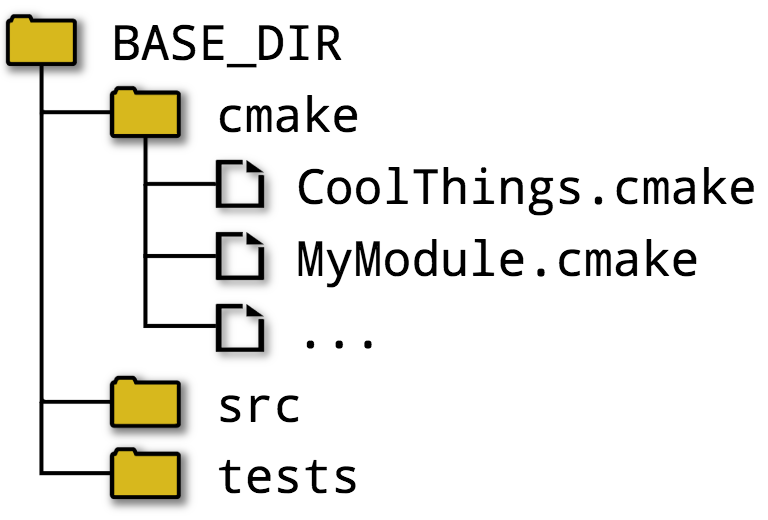

然后，相应的`CMakeLists.txt`文件只需要将`cmake目录添加到``CMAKE_MODULE_PATH` 中，就可以在加载每个模块时仅使用基本文件名来调用`include() 。`

The corresponding `CMakeLists.txt` file then only needs to add the `cmake` directory to the `CMAKE_MODULE_PATH` and it can then call `include()` using just the base file name when loading each of the modules.

*CMakeLists.txt：*

```
cmake_minimum_required(VERSION 3.0)
project(Example)

list(APPEND CMAKE_MODULE_PATH
    "${CMAKE_CURRENT_SOURCE_DIR}/cmake"
)

# Inject code from project-provided modules
include(CoolThings)
include(MyModule)
```

CMake 查找模块的搜索顺序有一个例外。如果调用 `include()`的文件本身位于 CMake 的内部模块目录中，则 CMake 会先搜索内部模块目录，*然后再* 查找`CMAKE_MODULE_PATH`。这可以防止项目代码意外（或故意）用自定义模块替换官方模块，从而改变文档中描述的行为。

There is one exception to the search order used by CMake to find a module. If the file calling `include()` is itself inside CMake’s own internal module directory, then the internal module directory will be searched first *before* consulting `CMAKE_MODULE_PATH`. This prevents project code from accidentally (or deliberately) replacing an official module with one of their own and changing the documented behavior.

使用模块的另一种方法是使用`find_package()命令。`第 24.5 节“查找包”对此进行了详细讨论，但现在，一个不包含任何可选关键字的简化版命令示例可以演示其基本用法：

The other way to employ modules is with the `find_package()` command. This is discussed in detail in Section 24.5, “Finding Packages”, but for the moment, a simplified form of that command without any of the optional keywords demonstrates its basic usage:

```
find_package(PackageName)
```

`以这种方式使用时，其行为与include()`非常相似，区别在于 CMake 会查找名为`FindPackageName.cmake`的文件，而不是 `PackageName.cmake`。这种方法通常用于将外部包的详细信息引入构建过程，包括导入的目标、定义相关文件、库或程序位置的变量、可选组件信息、版本详情等等。find_package `()提供的选项和功能比``include()`丰富得多，第 24 章*“查找内容”*专门详细介绍了这一主题。

When used in this way, the behavior is very similar to `include()` except CMake will search for a file called `FindPackageName.cmake` rather than `PackageName.cmake`. This is the method by which details about an external package are often brought into the build, including things like imported targets, variables defining locations of relevant files, libraries or programs, information about optional components, version details and so on. The set of options and features associated with `find_package()` is considerably richer than what is provided for `include()` and Chapter 24, *Finding Things* is dedicated to covering the topic in detail.

本章剩余部分将介绍一些包含在 CMake 版本中的有趣模块。这并非全部模块，但足以展现 CMake 提供的功能类型。后续章节将介绍其他与本章主题密切相关的模块。CMake 文档提供了所有可用模块的完整列表，每个模块都有自己的帮助文档，解释其功能和使用方法。但需要注意的是，不同模块的文档质量参差不齐。

The remainder of this chapter introduces a number of interesting modules that are included as part of a CMake release. This is by no means a comprehensive set, but they do give a flavor of the sort of functionality that is available. Other modules are introduced in subsequent chapters where their functionality is closely related to the topic of discussion. The CMake documentation provides a complete list of all available modules, each with its own help section explaining what the module provides and how it can be used. Be forewarned though that the quality of the documentation does vary from module to module.

## 11.1 检查存在性和支持情况

## 11.1. Checking Existence And Support

CMake 模块涵盖的较全面的领域之一是检查各种功能是否存在或是否受支持。这类模块的基本工作原理相同：编写一小段测试代码，然后尝试编译，并可能链接和运行生成的可执行文件，以确认代码中测试的功能是否受支持。所有这些模块的名称都以`“Check”`开头。

One of the more comprehensive areas covered by CMake’s modules is checking for the existence of or support for various things. This family of modules all work in fundamentally the same way, writing a short amount of test code and then attempting to compile and possibly link and run the resultant executable to confirm whether what is being tested in the code is supported. All of these modules have a name beginning with `Check`.

一些更基础的`检查`模块会将一个简短的测试文件编译并链接成可执行文件，并返回成功/失败的结果。在 CMake 3.19 或更高版本中，`CheckSourceCompiles`模块提供了此功能。它定义了`check_source_compiles()`命令：

Some of the more fundamental `Check…` modules are those that compile and link a short test file into an executable and return a success/fail result. With CMake 3.19 or later, the `CheckSourceCompiles` module provides this capability. It defines the `check_source_compiles()` command:

```
include(CheckSourceCompiles)
check_source_compiles(lang code resultVar
    [FAIL_REGEX regexes...]
    [SRC_EXT extension]
)
```

lang`指`的是 CMake 支持的语言之一，例如`C`、`C++`、 `CUDA`等。在早期的 CMake 版本中，每个语言都有单独的模块提供相同的功能，但支持的语言种类要少得多。这些模块的名称格式为`Check<LANG>SourceCompiles`，每个模块都提供一个执行测试的关联命令：

The `lang` would be one of the languages CMake supports, such as `C`, `CXX`, `CUDA` and so on. With earlier CMake versions, separate per-language modules provide the same capabilities, but the set of supported languages is much smaller. These modules have names of the form `Check<LANG>SourceCompiles` and each one provides an associated command that performs the test:

```
include(CheckCSourceCompiles)
check_c_source_compiles(code resultVar
    [FAIL_REGEX regexes...]
)

include(CheckCXXSourceCompiles)
check_cxx_source_compiles(code resultVar
    [FAIL_REGEX regexes...]
)

include(CheckFortranSourceCompiles)
check_fortran_source_compiles(code resultVar
    [FAIL_REGEX regexes...]
    [SRC_EXT extension]
)
```

对于所有这些命令， `code`参数应为包含源代码的字符串，该源代码应生成相应语言的可执行文件。编译和链接代码的尝试结果将作为缓存变量存储在 `resultVar`中，true 表示成功。false 值可以是空字符串、错误消息等，具体取决于实际情况。测试执行一次后，后续的 CMake 运行将使用缓存结果，而无需再次执行测试。即使被测代码发生更改，情况也是如此。要强制重新评估，必须手动从缓存中删除该变量。

For all of these commands, the `code` argument is expected to be a string containing source code that should produce an executable for the corresponding language. The result of an attempt to compile and link the code is stored in `resultVar` as a cache variable, with true indicating success. False values could be an empty string, an error message, etc. depending on the situation. After the test has been performed once, subsequent CMake runs will use the cached result rather than performing the test again. This is the case even if the code being tested is changed. To force re-evaluation, the variable has to be manually removed from the cache.

如果指定了`FAIL_REGEX`选项，则会应用一个附加条件。如果测试编译和链接的输出与任何指定的正 `则表达式`（正则表达式列表）匹配，即使代码编译和链接成功，检查也会被视为失败。

If the `FAIL_REGEX` option is specified, then an additional criteria applies. If the output of the test compilation and linking matches any of the specified `regexes` (a list of regular expressions), the check will be deemed to have failed, even if the code compiles and links successfully.

```
include(CheckCSourceCompiles)
check_c_source_compiles("int main() { int myVar; }"
    unusedNotDetected
    FAIL_REGEX "[Ww]arn"
)
if(unusedNotDetected)
    message("Unused variables do not generate warnings")
endif()
```

对于 Fortran 来说，文件扩展名会影响编译器处理源文件的方式，因此可以使用 `SRC_EXT选项显式指定文件扩展名以获得预期行为。在使用旧版``Check<LANG>SourceCompiles`模块时， C 或 C++ 没有等效选项 ，但新版`CheckSourceCompiles` 模块支持所有语言的此选项。

In the case of Fortran, the file extension can affect how compilers treat source files, so the file extension can be explicitly specified with the `SRC_EXT` option to obtain the expected behavior. There is no equivalent option for the C or C++ cases when using the older `Check<LANG>SourceCompiles` modules, but the newer `CheckSourceCompiles` module supports it for all languages.

在调用任何编译测试命令之前，可以设置一些形如`CMAKE_REQUIRED_…` 的变量，以影响代码的编译方式：

A number of variables of the form `CMAKE_REQUIRED_…` can be set before calling any of the compilation test commands to influence how they compile the code:

**`CMAKE_REQUIRED_FLAGS`**

**`CMAKE_REQUIRED_FLAGS`**

`在相关的CMAKE_<LANG>_FLAGS`和 `CMAKE_<LANG>_FLAGS_<CONFIG>`变量的内容之后，需要将其他标志传递给编译器命令行（参见第 15.4 节“编译器和链接器变量”）。这必须是一个字符串，多个标志之间用空格分隔，这与下面所有其他 CMake 列表变量不同。

Additional flags to pass to the compiler command line after the contents of the relevant `CMAKE_<LANG>_FLAGS` and `CMAKE_<LANG>_FLAGS_<CONFIG>` variables (see Section 15.4, “Compiler And Linker Variables”). This must be a single string with multiple flags being separated by spaces, unlike all the other variables below which are CMake lists.

**`CMAKE_REQUIRED_DEFINITIONS`**

**`CMAKE_REQUIRED_DEFINITIONS`**

CMake 编译器定义列表，每个定义都以`-DFOO`或`-DFOO=bar`的形式指定。

A CMake list of compiler definitions, each one specified in the form `-DFOO` or `-DFOO=bar`.

**`CMAKE_REQUIRED_INCLUDES`**

**`CMAKE_REQUIRED_INCLUDES`**

指定要搜索头文件的目录。多个路径必须以 CMake 列表的形式指定，空格将被视为路径的一部分。

Specifies directories to search for headers. Multiple paths must be specified as a CMake list, with spaces being treated as part of a path.

**`CMAKE_REQUIRED_LIBRARIES`**

**`CMAKE_REQUIRED_LIBRARIES`**

CMake 链接阶段要添加的库列表。不要在库名称前添加任何`-l`选项或类似选项，只需提供库名称或 CMake 导入的目标名称（详见第 17 章*“目标类型*”）。

A CMake list of libraries to add to the linking stage. Do not prefix the library names with any `-l` option or similar, provide just the library name or the name of a CMake imported target (discussed in Chapter 17, *Target Types*).

**`CMAKE_REQUIRED_LINK_OPTIONS`**

**`CMAKE_REQUIRED_LINK_OPTIONS`**

CMake 的一个选项列表，用于指定构建可执行文件时传递给链接器的选项，或构建静态库时传递给归档器的选项。此变量仅在 CMake 3.14 或更高版本中受支持。

A CMake list of options to be passed to the linker if building an executable, or to the archiver if building a static library. Support for this variable is only available with CMake 3.14 or later.

**`CMAKE_REQUIRED_QUIET`**

**`CMAKE_REQUIRED_QUIET`**

如果启用此选项，则该命令不会打印任何状态消息。

If this option is present, no status messages will be printed by the command.

这些变量用于构建内部调用`try_compile()`函数执行检查的参数。CMake 文档中关于 `try_compile()` 函数的说明讨论了可能影响检查的其他变量，而与工具链选择和要构建的目标类型相关的`try_compile()函数的其他行为则在`第 22.5 节“编译器检查”中进行了介绍。

These variables are used to construct arguments to the `try_compile()` call made internally to perform the check. The CMake documentation for `try_compile()` discusses additional variables which may have an effect on the checks, while other aspects of `try_compile()` behavior relating to toolchain selection and the type of target to build are covered in Section 22.5, “Compiler Checks”.

除了检查代码是否可以构建之外，CMake 还提供了用于测试构建的可执行文件是否可以成功运行的模块。成功与否取决于从提供的源代码创建的可执行文件的退出代码，0 表示成功，所有其他值表示失败。在 CMake 3.19 或更高版本中，一个模块即可提供适用于所有语言的命令：

In addition to checking whether code can be built, CMake also provides modules that test whether the built executable can be run successfully. Success is measured by the exit code of the executable created from the source provided, with 0 being treated as success and all other values indicating failure. With CMake 3.19 or later, a single module provides a command for all languages:

```
include(CheckSourceRuns)
check_source_runs(lang code resultVar
    [SRC_EXT extension]
)
```

同样，在早期的 CMake 版本中，单独的语言模块提供了相同的功能，但支持的语言较少：

Again, with earlier CMake versions, separate per-language modules provide the same capabilities, but with fewer supported languages:

```
# Supported by all CMake versions
include(CheckCSourceRuns)
check_c_source_runs(code resultVar)

include(CheckCXXSourceRuns)
check_cxx_source_runs(code resultVar)

# Requires CMake 3.14 or later
include(CheckFortranSourceRuns)
check_fortran_source_runs(code resultVar
    [SRC_EXT extension]
)
```

这些命令没有`FAIL_REGEX`选项，因为成功或失败完全由测试过程的退出代码决定。如果代码无法构建，也视为失败。所有影响 `check_source_compiles()`或`check_<lang>_source_compiles()`代码构建方式的变量，对这些模块的命令也同样有效。

There is no `FAIL_REGEX` option for these commands, as success or failure is determined purely by the exit code of the test process. If the code cannot be built, this is also treated as a failure. All the same variables that affect how the code is built for `check_source_compiles()` or `check_<lang>_source_compiles()` also have the same effect for these modules’ commands as well.

对于需要交叉编译到不同目标平台的构建， `check_source_runs()`和`check_<lang>_source_runs()`命令的行为截然不同。如果提供了必要的细节，它们可能会在模拟器下运行代码，但这很可能会显著降低 CMake 阶段的执行速度。如果没有提供模拟器细节，这些命令会期望通过一组变量提供预先设定的结果，而不会尝试运行任何代码。这个相当高级的主题在 CMake 的 try_run() 命令文档中有详细介绍，模块命令内部正是使用 try_run() 命令来执行检查的`。`

For builds that are cross-compiling to a different target platform, the `check_source_runs()` and `check_<lang>_source_runs()` commands behave quite differently. They may run the code under a simulator if the necessary details have been provided, which would likely slow down the CMake stage considerably. If simulator details have not been provided, the commands will instead expect a predetermined result to be provided through a set of variables and will not try to run anything. This fairly advanced topic is covered in CMake’s documentation for the `try_run()` command, which is what the module commands use internally to perform the checks.

某些类型的检查非常常见，以至于 CMake 提供了专门的模块来处理它们。这些模块简化了定义测试代码的大量样板代码，并允许项目仅指定最少的检查信息。它们通常只是对上述模块提供的命令的封装，因此用于自定义测试代码构建方式的同一组变量仍然适用。这些更专业的模块可以检查编译器标志、预处理器符号、函数、变量、头文件等等。

Certain categories of checks are so common that CMake provides dedicated modules for them. These remove much of the boilerplate of defining the test code and allow projects to specify a minimal amount of information for the check. These are typically just wrappers around the commands provided by one of the modules mentioned above, so the same set of variables used for customizing how the test code is built still apply. These more specialized modules check compiler flags, pre-processor symbols, functions, variables, header files and more.

与上述模块类似，CMake 3.19 或更高版本为所有支持的语言提供了一个统一的模块和命令。对于更早的 CMake 版本，则必须使用一组针对每种语言的模块。

Just as for the modules above, CMake 3.19 or later provides a single module and command for all supported languages. For earlier CMake versions, a set of per-language modules must be used instead.

```
# Requires CMake 3.19 or later
include(CheckCompilerFlag)
check_compiler_flag(lang flag resultVar)
```

```
# Supported by all CMake versions
include(CheckCCompilerFlag)
check_c_compiler_flag(flag resultVar)

include(CheckCXXCompilerFlag)
check_cxx_compiler_flag(flag resultVar)

# Requires CMake 3.3 or later
include(CheckFortranCompilerFlag)
check_fortran_compiler_flag(flag resultVar)
```

标志检查命令会在内部更新`CMAKE_REQUIRED_DEFINITIONS`变量，以便在调用 `check_source_compiles()`函数并使用一个简单的测试文件 时包含该`标志。此外，还会传递一组内部失败正则表达式作为``FAIL_REGEX`选项，用于测试该标志是否会导致发出诊断消息。如果没有发出匹配的诊断消息，则调用结果为真。请注意，这意味着任何会导致编译器警告但编译成功的标志仍将被视为检查失败。另请注意，这些命令假定相关的`CMAKE_<LANG>_FLAGS`变量（参见第 15.4 节“编译器和链接器变量”）中已存在的任何标志本身不会生成任何编译器警告。如果它们会生成警告，则每个标志测试命令的逻辑都将失效，并且所有此类检查的结果都将是失败。

The flag-checking commands update the `CMAKE_REQUIRED_DEFINITIONS` variable internally to include `flag` in a call to `check_source_compiles()` with a trivial test file. An internal set of failure regular expressions is also passed as the `FAIL_REGEX` option, testing whether the flag results in a diagnostic message being issued or not. The result of the call will be a true value if no matching diagnostic message is issued. Note that this means any flag that results in a compiler warning but successful compilation will still be deemed to have failed the check. Also be aware that these commands assume that any flags already present in the relevant `CMAKE_<LANG>_FLAGS` variables (see Section 15.4, “Compiler And Linker Variables”) do not themselves generate any compiler warnings. If they do, then the logic for each of these flag-testing commands will be defeated and the result of all such checks will be failure.

CMake 3.18 还引入了`CheckLinkerFlag`模块。它提供了类似的命令`check_linker_flag()`，该命令主要是对`check_source_compiles() 的`一个便捷封装。因此，它支持与之前讨论的所有相同变量，只是接管了`CMAKE_REQUIRED_LINK_OPTIONS`变量的处理。

CMake 3.18 also introduced the `CheckLinkerFlag` module. It provides the analogous command `check_linker_flag()`, which is mostly just a convenience wrapper around `check_source_compiles()`. As such, it supports all the same variables as previously discussed, except that it takes over handling of the `CMAKE_REQUIRED_LINK_OPTIONS` variable.

```
include(CheckLinkerFlag)
check_linker_flag(language flag resultVar)
```

指定的`标志`不会直接传递给链接器。链接器是通过编译器调用的，编译器会在内部添加额外的语言特定标志、库等，以确保链接器能够成功链接到指定的`语言`。原始的链接器标志通常不起作用，它通常需要像`-Wl,…`或`-Xlinker`这样的前缀来告诉编译器将其传递给链接器。这个前缀是编译器特定的，但可以使用特殊的前缀`LINKER:`，CMake 会自动替换为正确的编译器特定前缀。有关相关讨论，请参阅第 15.1.2 节“链接器标志”和第 15.1.3 节“目标属性命令”中的 `target_link_options()命令。`

The specified `flag` is not passed directly to the linker. The linker is invoked via the compiler, which internally adds extra language-specific flags, libraries, etc. needed to successfully link for the specified `language`. A raw linker flag will usually not work, it typically needs some sort of prefix like `-Wl,…` or `-Xlinker` to tell the compiler to pass it through to the linker. This prefix is compiler-specific, but the special prefix `LINKER:` can be used and CMake will substitute the correct compiler-specific prefix automatically. See Section 15.1.2, “Linker Flags” and the `target_link_options()` command in Section 15.1.3, “Target Property Commands” for related discussions.

```
include(CheckLinkerFlag)
check_linker_flag(CXX LINKER:-stats LINKER_STATS_SUPPORTED)
```

另外两个值得注意的模块是`CheckSymbolExists`和 `CheckCXXSymbolExists`。前者提供了一个命令，用于构建一个测试用的 C 可执行文件；后者则生成一个 C++ 可执行文件。这两个模块都会检查特定符号是否存在，检查的对象可以是预处理器符号（即可以通过`#ifdef`语句测试的符号）、函数或变量。

Two other notable modules are `CheckSymbolExists` and `CheckCXXSymbolExists`. The former provides a command which builds a test C executable and the latter does the same as a C++ executable. Both check whether a particular symbol exists as either a pre-processor symbol (i.e. something that can be tested via an `#ifdef` statement), a function or a variable.

```
include(CheckSymbolExists)
check_symbol_exists(symbol headers resultVar)

include(CheckCXXSymbolExists)
check_cxx_symbol_exists(symbol headers resultVar)
```

`对于头文件`中指定的每个项（如果需要指定多个头文件，则使用 CMake 列表），都会在测试源代码中添加相应的`#include`指令。大多数情况下，被检查的符号将由这些头文件之一定义。测试结果将以常规方式存储在`resultVar缓存变量中。`

For each of the items specified in `headers` (a CMake list if more than one header needs to be given), a corresponding `#include` will be added to the test source code. In most cases, the symbol being checked will be defined by one of these headers. The result of the test is stored in the `resultVar` cache variable in the usual way.

对于函数和变量，符号必须解析为测试可执行文件中的某个部分。如果函数或变量由库提供，则必须将该库链接到测试中，这可以通过`CMAKE_REQUIRED_LIBRARIES`变量来实现。

In the case of functions and variables, the symbol needs to resolve to something that is part of the test executable. If the function or variable is provided by a library, that library must be linked as part of the test, which can be done using the `CMAKE_REQUIRED_LIBRARIES` variable.

```
include(CheckSymbolExists)
check_symbol_exists(sprintf stdio.h HAVE_SPRINTF)

include(CheckCXXSymbolExists)
set(CMAKE_REQUIRED_LIBRARIES SomeCxxSDK)
check_cxx_symbol_exists(SomeCxxInitFunc
    somecxxsdk.h
    HAVE_SOMECXXSDK
)
```

这些命令对可检查的函数和变量类型存在限制。只有满足预处理器符号命名要求的符号才能被使用。对于 `check_cxx_symbol_exists()`命令，限制更为显著，因为它意味着只能检查全局命名空间中的非模板函数或变量，因为任何作用域标记（ `::` ）或模板标记（`<>`）对于预处理器符号都无效。此外，也无法区分同一函数的不同重载版本，因此这些重载版本也无法被检查。

There are limitations on the sort of functions and variables that can be checked by these commands. Only those symbols that satisfy the naming requirements for a preprocessor symbol can be used. The implications are stronger for `check_cxx_symbol_exists()`, since it means only non-template functions or variables in the global namespace can be checked because any scoping (`::`) or template markers (`<>`) would not be valid for a preprocessor symbol. It is also impossible to distinguish between different overloads of the same function, so these cannot be checked either.

`还有其他一些模块旨在提供与CheckSymbolExists`类似或其子集的功能。这些模块要么来自早期版本的 CMake，要么是为 C 或 C++ 以外的语言编写的。CheckFunctionExists模块已被记录为已弃用，而`CheckVariableExists`模块提供的功能 `CheckSymbolExists`已经具备。CheckFortranFunctionExists模块可能对使用 Fortran 的项目有用，但请注意，没有`CheckFortranVariableExists`模块。为了保持一致性，`Fortran` 项目可能需要使用`CheckFortranSourceCompiles 模块``。`

There are other modules which aim to provide functionality that is similar to or a subset of that covered by `CheckSymbolExists`. These other modules are either from earlier versions of CMake or are for a language other than C or C++. The `CheckFunctionExists` module is already documented as being deprecated and the `CheckVariableExists` module offers nothing that `CheckSymbolExists` doesn’t already provide. The `CheckFortranFunctionExists` module may be useful for those projects working with Fortran, but note that there is no `CheckFortranVariableExists` module. Fortran projects may want to use `CheckFortranSourceCompiles` for consistency instead.

其他模块提供了更详细的检查。例如，可以使用`CheckStructHasMember测试结构体成员，可以使用``CheckPrototypeDefinition`测试特定的 C 或 C++ 函数原型 ，可以使用`CheckTypeSize`测试非用户类型的大小。此外，还可以使用 `CheckLanguage`、`CheckLibraryExists`和各种 `CheckIncludeFile…`模块进行更高级别的检查。随着 CMake 的发展，还会不断添加新的检查模块，因此请查阅 CMake 模块文档以了解所有可用功能。

More detailed checks are provided by other modules. For example, struct members can be tested with `CheckStructHasMember`, specific C or C++ function prototypes can be tested with `CheckPrototypeDefinition` and the size of non-user types can be tested with `CheckTypeSize`. Other higher level checks are also possible, as provided by `CheckLanguage`, `CheckLibraryExists` and the various `CheckIncludeFile…` modules. Further check modules continue to be added to CMake as it evolves, so consult the CMake module documentation to see the full set of available functionality.

在需要执行多项检查，或者需要将执行检查的影响彼此隔离，或与当前作用域的其他部分隔离的情况下，手动保存和恢复检查前后的状态会非常繁琐。特别是，各种`CMAKE_REQUIRED_…` 变量通常需要保存和恢复。为了简化此过程，CMake 提供了`CMakePushCheckState`模块，该模块定义了以下三个命令：

In situations where multiple checks are being made or where the effects of performing the checks need to be isolated from each other or from the rest of the current scope, it can be cumbersome to manually save and restore the state before and after the checks. In particular, the various `CMAKE_REQUIRED_…` variables often need to be saved and restored. To help with this, CMake provides the `CMakePushCheckState` module which defines the following three commands:

```
include(CMakePushCheckState)
cmake_push_check_state([RESET])
cmake_pop_check_state()
cmake_reset_check_state()
```

这些命令允许将各种`CMAKE_REQUIRED_…`变量视为一个集合，并允许它们的状态被压入和弹出到虚拟栈中。每次调用`cmake_push_check_state()时，它实际上会为``CMAKE_REQUIRED_…`变量（以及仅供`CheckTypeSize`模块使用的 `CMAKE_EXTRA_INCLUDE_FILES`变量）创建一个新的虚拟变量作用域。cmake_pop_check_state `()`则相反，它会丢弃`CMAKE_REQUIRED_…`变量的当前值，并将它们恢复到上一个栈级别的值。cmake_reset_check_state `()`命令方便地清除所有 `CMAKE_REQUIRED_…`变量，而`cmake_push_check_state()的``RESET`选项 也方便地在压栈时清除这些变量。但请注意，CMake 3.10 之前存在一个错误，导致 `RESET`选项被忽略，因此对于需要与 3.10 之前的版本一起使用的项目，最好改用单独调用 `cmake_reset_check_state()`。

These commands allow the various `CMAKE_REQUIRED_…` variables to be treated as a set and to have their state pushed and popped onto/from a virtual stack. Each time `cmake_push_check_state()` is called, it effectively begins a new virtual variable scope for just the `CMAKE_REQUIRED_…` variables (and also the `CMAKE_EXTRA_INCLUDE_FILES` variable which is only used by the `CheckTypeSize` module). `cmake_pop_check_state()` is the opposite, it discards the current values of the `CMAKE_REQUIRED_…` variables and restores them to the previous stack level’s values. The `cmake_reset_check_state()` command is a convenience for clearing all the `CMAKE_REQUIRED_…` variables and the `RESET` option to `cmake_push_check_state()` is also just a convenience for clearing the variables as part of the push. Note, however, that a bug existed prior to CMake 3.10 which resulted in the `RESET` option being ignored, so for projects that need to work with versions before 3.10, it is better to use a separate call to `cmake_reset_check_state()` instead.

```
# Start with a known state we can modify and undo later
include(CMakePushCheckState)
cmake_push_check_state()
cmake_reset_check_state()

set(CMAKE_REQUIRED_FLAGS -Wall)
include(CheckSymbolExists)
check_symbol_exists(FOO_VERSION foo/version.h HAVE_FOO)

if(HAVE_FOO)
  # Preserve -Wall and add more things for extra checks
  cmake_push_check_state()
  set(CMAKE_REQUIRED_INCLUDES foo/inc.h foo/more.h)
  set(CMAKE_REQUIRED_DEFINES -DFOOBXX=1)
  check_symbol_exists(FOOBAR "" HAVE_FOOBAR)
  check_symbol_exists(FOOBAZ "" HAVE_FOOBAZ)
  check_symbol_exists(FOOBOO "" HAVE_FOOBOO)
  cmake_pop_check_state()
  # Now back to just -Wall
endif()

# Clear CMAKE_REQUIRED_... variables for this last check
cmake_reset_check_state()
check_symbol_exists(__TIME__ "" HAVE_PPTIME)

# Restore all CMAKE_REQUIRED_... variables to their
# original values from the top of this example
cmake_pop_check_state()
```

## 11.2 其他模块

## 11.2. Other Modules

CMake 对某些语言（尤其是 C 和 C++）提供了出色的内置支持。它还包含许多模块，以更具可扩展性和可配置性的方式提供对语言的支持。这些模块允许通过定义相关的命令、变量和属性，将某些语言或与语言相关的包的功能引入到项目中。许多此类模块作为`find_package()`调用支持的一部分提供（参见 第 24.5 节“查找包”），而其他模块则旨在通过 `include()`更直接地将内容引入当前作用域。以下模块列表将展示可用的语言支持类型：

CMake has excellent built-in support for some languages, especially C and C++. It also includes a number of modules which provide support for languages in a more extensible and configurable way. These modules allow aspects of some languages or language-related packages to be made available to projects by defining relevant commands, variables and properties. Many of these modules are provided as part of the support for `find_package()` calls (see Section 24.5, “Finding Packages”), while others are intended to be used more directly via `include()` to bring things into the current scope. The following module list should give a taste of the sort of language support available:

- `C#实用程序`
- `CSharpUtilities`
- `FindCUDA`（但请注意，在最近的 CMake 版本中，CUDA 已作为一等语言得到支持，取代了 FindCUDA）
- `FindCUDA` (but note this has been superseded by support for CUDA as a first class language in its own right in recent CMake versions)
- `FindJava`、`FindJNI`、`UseJava`
- `FindJava`, `FindJNI`, `UseJava`
- `FindLua`
- `FindLua`
- `查找Matlab`
- `FindMatlab`
- `FindPerl`，`FindPerlLibs`
- `FindPerl`, `FindPerlLibs`
- `FindPython`
- `FindPython`
- `FindPHP4`
- `FindPHP4`
- `查找Ruby`
- `FindRuby`
- `FindSWIG`，`UseSWIG`
- `FindSWIG`, `UseSWIG`
- `查找TCL`
- `FindTCL`
- `FortranC接口`
- `FortranCInterface`

此外，还提供了用于与外部数据和项目交互的模块，这在第 28 章“*外部内容”*中有详细介绍。同时，也提供了一些模块来简化测试和打包的各个方面。这些模块与作为 CMake 套件一部分分发的 CTest 和 CPack 工具密切相关，并在第 25 章“*测试”*和第 27 章“*打包*`”中有详细介绍。CMakePrintHelpers模块`也提供了调试帮助（参见 13.2 节“打印辅助工具”）。

In addition, modules are also provided for interacting with external data and projects, a topic covered in depth in Chapter 28, *External Content*. A number of modules are also provided to facilitate various aspects of testing and packaging. These have a close relationship with the CTest and CPack tools distributed as part of the CMake suite and are covered in depth in Chapter 25, *Testing* and Chapter 27, *Packaging*. Debugging assistance is also provided by the `CMakePrintHelpers` module (see Section 13.2, “Print Helpers”).

## 11.3. 推荐做法

## 11.3. Recommended Practices

CMake 的模块集合提供了基于 CMake 核心语言的丰富功能。项目可以通过在特定目录下添加自定义模块，并将该路径添加到`CMAKE_MODULE_PATH变量中，轻松扩展可用功能集。相比在``include()`调用中硬编码跨复杂目录结构的绝对或相对路径，使用 `CMAKE_MODULE_PATH`更为可取，因为这有助于将通用的 CMake 逻辑与其应用位置解耦。这反过来又使得随着项目的演进，更容易将 CMake 模块迁移到不同的目录，或者在不同的项目之间重用逻辑。事实上，组织构建自己的模块集合（甚至可能将其存储在单独的存储库中）的情况并不少见。通过在每个项目中正确设置`CMAKE_MODULE_PATH`，这些可重用的 CMake 构建块就可以根据需要广泛使用。

CMake’s collection of modules provides a wealth of functionality built on top of the core CMake language. A project can easily extend the set of available functionality by adding their own custom modules under a particular directory and then adding that path to the `CMAKE_MODULE_PATH` variable. The use of `CMAKE_MODULE_PATH` should be preferred over hard-coding absolute or relative paths across complex directory structures in `include()` calls, since this will encourage generic CMake logic to be decoupled from the places where that logic may be applied. This in turn makes it easier to relocate CMake modules to different directories as a project evolves, or to re-use the logic across different projects. Indeed, it is not unusual for an organization to build up its own collection of modules, perhaps even storing them in their own separate repository. By setting `CMAKE_MODULE_PATH` appropriately in each project, those reusable CMake building blocks are then made available for use as widely as needed.

随着时间的推移，开发者通常会遇到越来越多的有趣场景，而 CMake 模块可以为这些场景提供便捷的捷径或现成的解决方案。有时，快速浏览一下可用的模块就能发现意想不到的宝藏，或者某个新模块可能提供了一个维护更完善的实现，弥补了项目此前实现的一些不足。CMake 模块的优势在于，它们拥有庞大的开发者和项目群体，涵盖各种平台和场景，因此在许多情况下，它们比项目自行编写逻辑更具吸引力。然而，模块的质量确实存在差异。有些模块诞生于 CMake 的早期，如果未能及时更新以适应 CMake 或其相关领域的变化，这些模块的实用性可能会降低。对于`Find…`模块来说尤其如此，它们可能无法像用户期望的那样紧密地跟踪所查找软件包的最新版本。另一方面，模块本质上只是普通的 CMake 代码，因此任何人都可以查看、学习、改进或更新它们，而无需学习超出项目中基本 CMake 使用范围之外的知识。事实上，对于希望参与 CMake 开发的开发者来说，模块是一个绝佳的起点。

Over time, a developer will typically be exposed to an increasing number of interesting scenarios for which a CMake module may provide useful shortcuts or ready-made solutions. Sometimes a quick scan of the available modules can yield an unexpected hidden gem, or a new module may offer a better maintained implementation of something a project has been implementing in an inferior way up to that point. CMake’s modules have the benefit of a potentially large pool of developers and projects using them across a diverse set of platforms and situations, so they may offer a more compelling alternative to projects doing their own manual logic in many cases. The quality does, however, vary from one module to another. Some modules began their life quite early on in CMake’s existence and these can sometimes become less useful if not kept up to date with changes to CMake or to the areas those modules relate to. This can be particularly true of `Find…` modules which may not track newer versions of the packages they are finding as closely as one might like. On the other hand, modules are just ordinary CMake code, so anyone can inspect them, learn from them, improve or update them without having to learn much beyond what is needed for basic CMake use in a project. In fact, they are an excellent starting point for developers wishing to get involved with working on CMake itself.

CMake 提供的丰富多样的`Check…`模块既是好事也是坏事。开发者可能会过度热衷于检查各种各样的东西，这会导致配置阶段速度变慢，而收益却有时并不显著。通常情况下，与这些检查相关的命令会占据 CMake 运行性能分析结果的大部分（参见13.5 节“CMake 调用分析”）。因此，要权衡利弊，考虑实现和维护这些检查所需的时间以及项目复杂性。有时，只需进行一些合理的检查，就能覆盖大多数常见情况，或者发现一些不易察觉的问题，避免后续出现难以追踪的故障。此外，如果使用任何`Check…`模块，应尽量将检查逻辑与其调用范围隔离。强烈建议 使用`CMakePushCheckState`模块，但如果需要支持 CMake 3.10 之前的版本，则应避免使用`cmake_push_check_state()的``RESET`选项。

The abundance of different `Check…` modules provided by CMake can be a mixed blessing. Developers can be tempted to get too over-zealous with checking all manner of things, which can result in slowing down the configure stage for sometimes questionable gains. It is common to see the commands related to these checks dominate the profiling results of a CMake run (see Section 13.5, “Profiling CMake Calls”). Consider whether the benefits outweigh the costs in terms of time to implement and maintain the checks and the complexity of the project. Sometimes a few judicious checks are sufficient for covering the most useful cases, or to catch a subtle problem that might otherwise cause hard to trace problems later. Furthermore, if using any of the `Check…` modules, aim to isolate the checking logic from the scope in which it may be invoked. Use of the `CMakePushCheckState` module is highly recommended, but avoid using the `RESET` option to `cmake_push_check_state()` if support for CMake versions before 3.10 is important.

当 CMake 最低版本可以设置为 3.20 或更高版本时，请避免使用曾经流行但现已弃用的`TestBigEndian`模块。该模块在 CMake 3.20 中已被弃用，取而代之的是新的 `CMAKE_<LANG>_BYTE_ORDER`变量，该变量也在同一 CMake 版本中引入。使用`TestBigEndian`的项目应尽可能迁移到新变量。

When the minimum CMake version can be set to 3.20 or later, avoid using the relatively popular but now deprecated `TestBigEndian` module. That module was deprecated in CMake 3.20 in favor of a new `CMAKE_<LANG>_BYTE_ORDER` variable, which was also introduced in the same CMake release. Projects that are using `TestBigEndian` should transition to the new variable where possible.

# 12. 政策

# 12. Policies

CMake 经过长期发展，不断引入新功能、修复漏洞，并改进某些特性的行为以弥补不足或提升性能。虽然新功能的引入不太可能对使用 CMake 构建的现有项目造成问题，但任何行为的改变都可能导致依赖于旧行为的项目出现故障。因此，CMake 开发人员非常谨慎地确保变更的实现方式能够保持向后兼容性，并为需要更新到新行为的项目提供简单、可控的迁移路径。

CMake has evolved over a long period, introducing new functionality, fixing bugs and changing the behavior of certain features to address shortcomings or introduce improvements. While the introduction of new capabilities is unlikely to cause problems for existing projects built with CMake, any change in behavior has the potential to break projects if they are relying on the old behavior. For this reason, the CMake developers are careful to ensure that changes are implemented in such a way as to preserve backward compatibility and to provide a straightforward, controlled migration path for projects to be updated to the new behavior.

CMake 的策略机制用于控制使用旧行为还是新行为。通常，开发者并不经常接触到策略，只有在 CMake 发出警告，提示项目依赖于旧版本的行为时才会用到。当开发者升级到更新的 CMake 版本时，新版本有时会发出此类警告，以提示项目应该如何更新才能使用新行为。

This control over whether old or new behavior should be used is done through CMake’s policy mechanisms. In general, policies are not something that developers are exposed to all that often, mostly just when CMake issues a warning about the project relying on an older version’s behavior. When developers move to a more recent CMake release, the newer CMake version will sometimes issue such warnings to highlight how the project should be updated to use a new behavior.

## 12.1. 政策控制

## 12.1. Policy Control

`CMake 的策略功能与cmake_minimum_required()`命令 紧密相关，该命令在第三章“*最小项目”* 中已介绍过。此命令不仅指定项目所需的最低 CMake 版本，还会将 CMake 的行为设置为与指定版本相匹配。因此，当项目以 `cmake_minimum_required(VERSION 3.2)`开头时，它表明至少需要 CMake 3.2，并且项目期望 CMake 的行为与 3.2 版本一致。这让项目开发者确信，他们可以随时根据需要更新到任何更新的 CMake 版本，而项目仍然可以像以前一样构建。

CMake’s policy functionality is closely tied to the `cmake_minimum_required()` command, which was introduced back in Chapter 3, *A Minimal Project*. Not only does this command specify the minimum CMake version a project requires, it also sets CMake’s behavior to match that of the version given. Thus, when a project starts with `cmake_minimum_required(VERSION 3.2)`, it says that at least CMake 3.2 is needed and also that the project expects CMake to behave like the 3.2 release. This gives projects confidence that developers should be able to update to any newer version of CMake at their convenience and the project will still build as it did before.

`然而，有时项目可能需要比cmake_minimum_required()`命令提供的更精细的控制 。请考虑以下场景：

Sometimes, however, a project may want more fine-grained control than what the `cmake_minimum_required()` command provides. Consider the following scenarios:

- 一个项目希望设置一个较低的 CMake 最低版本要求，但如果有更新的功能，也希望能够利用这些功能。
- A project wants to set a low minimum CMake version, but it also wants to take advantage of newer behavior if it is available.
- 项目的一部分无法修改（例如，它可能来自外部只读代码库），并且依赖于旧的行为，而这些行为在新版 CMake 中已经改变。然而，项目的其余部分希望迁移到新行为。
- A part of the project is not able to be modified (e.g. it might come from an external read-only code repository) and it relies on old behavior which has been changed in newer CMake versions. The rest of the project, however, wants to move to the new behavior.
- 一个项目严重依赖一些旧的行为，更新这些行为需要相当多的工作。项目的某些部分希望使用最新的 CMake 特性，但针对这些特定变更的旧行为需要保留，直到有时间进行项目更新为止。
- A project relies heavily on some old behavior which would require a non-trivial amount of work to update. Some parts of the project want to make use of recent CMake features, but the old behavior for that particular change needs to be preserved until time can be set aside to update the project.

`以下是一些常见示例，在这些示例中，仅靠cmake_minimum_required()`命令提供的高级控制 是不够的。更具体的策略控制可以通过`cmake_policy()`命令实现，该命令有多种形式，粒度各不相同。其中，粒度最粗的形式与`cmake_minimum_required()`非常相似：

These are some common examples where the high level control provided by the `cmake_minimum_required()` command alone is not enough. More specific control over policies is enabled through the `cmake_policy()` command, which has a number of forms acting at different degrees of granularity. The form acting at the coarsest level is a close relative to `cmake_minimum_required()`:

```
cmake_policy(VERSION major[.minor[.patch[.tweak]]])
```

在这种形式下，该命令会将 CMake 的行为更改为与指定的版本相匹配。cmake_minimum_required `()`命令会隐式调用此形式来设置 CMake 的行为。除了项目根目录外，这两种形式在很大程度上可以互换。在项目根目录，必须调用`cmake_minimum_required()`来强制执行最低 CMake 版本。除了顶层 `CMakeLists.txt`文件的开头之外，当项目需要对某个部分强制执行特定版本的行为时，使用`cmake_policy()`通常能更清晰地传达意图，如下例所示：

In this form, the command changes CMake’s behavior to match that of the specified version. The `cmake_minimum_required()` command implicitly calls this form to set CMake’s behavior. The two are largely interchangeable except for the top of the project where a call to `cmake_minimum_required()` is mandatory to enforce a minimum CMake version. Apart from the start of the top level `CMakeLists.txt` file, using `cmake_policy()` generally communicates the intent more clearly when a project needs to enforce a particular version’s behavior for a section of the project, as demonstrated by the following example:

```
cmake_minimum_required(VERSION 3.7)
project(WithLegacy)

# Uses recent CMake features
add_subdirectory(modernDir)

# Imported from another project, relies on old behavior
cmake_policy(VERSION 2.8.11)
add_subdirectory(legacyDir)
```

CMake 3.12 以向后兼容的方式扩展了此功能，允许项目在调用 `cmake_minimum_required()`或`cmake_policy(VERSION)时，选择性地指定版本`*范围*而非单个版本。版本范围使用三个点`...` 来指定，中间不能有空格。该范围表示所使用的 CMake 版本必须至少为最低版本，并且要使用的行为应为指定的最高版本和正在运行的 CMake 版本中较小的那个。这使得项目可以有效地声明“我至少需要 CMake X，但我可以安全地使用 CMake Y 及以下的策略”。以下示例展示了两种方法，使项目仅需要 CMake 3.7，但如果正在运行的 CMake 版本支持，则仍然支持 CMake 3.12 及以下所有策略的新行为：

CMake 3.12 extends this capability in a backward-compatible way by optionally allowing the project to specify a version *range* rather than a single version to either `cmake_minimum_required()` or `cmake_policy(VERSION)`. The range is specified using three dots `...` between the minimum and maximum version with no spaces. The range indicates that the CMake version in use must be at least the minimum and the behavior to use should be the lesser of the specified maximum and the running CMake version. This allows the project to effectively say "I need at least CMake X, but I am safe to use with policies from up to CMake Y". The following example shows two ways for a project to require only CMake 3.7, but still support the newer behavior for all policies up to CMake 3.12 if the running CMake version supports them:

```
cmake_minimum_required(VERSION 3.7...3.12)
cmake_policy(VERSION 3.7...3.12)
```

CMake 3.12 之前的版本实际上只会看到一个版本号，并忽略`...3.12`部分，而 3.12 及更高版本则会将其理解为版本范围。

CMake versions before 3.12 would effectively see just a single version number and would ignore the `...3.12` part, whereas 3.12 and later would understand it to mean a range.

`CMake 还提供了使用SET`表单单独控制每个行为更改的功能：

CMake also provides the ability to control each behavior change individually with the `SET` form:

```
cmake_policy(SET CMPxxxx NEW)
cmake_policy(SET CMPxxxx OLD)
```

每个行为变更都会被赋予一个格式为 `CMPxxxx 的`独立策略编号，其中`xxxx`始终为四位数字。通过指定`NEW`或`OLD`，项目可以告知 CMake 为该特定策略使用新行为还是旧行为。CMake 文档提供了完整的策略列表，以及对每个策略的 OLD 和 NEW 行为的解释。

Each individual behavior change is given its own policy number of the form `CMPxxxx`, where `xxxx` is always four digits. By specifying `NEW` or `OLD`, a project tells CMake to use the new or old behavior for that particular policy. The CMake documentation provides the full list of policies, along with an explanation of the OLD and NEW behavior of each one.

例如，在 3.0 版本之前，CMake 允许项目使用 不存在的目标名称调用`get_target_property()函数。在这种情况下，属性值会返回``-NOTFOUND`而不是报错，但很可能该项目包含错误的逻辑。因此，从 3.0 版本开始，如果遇到这种情况，CMake 会立即停止并报错。如果某个项目依赖于旧的行为，则可以使用策略`CMP0045`继续这样做，如下所示：

As an example, before version 3.0, CMake allowed a project to call `get_target_property()` with the name of a target that didn’t exist. In such a case, the value of the property was returned as `-NOTFOUND` rather than issuing an error, but in all likelihood, the project probably contained incorrect logic. Therefore, from version 3.0 onward, CMake halts with an error if such a situation is encountered. In the event that a project was relying on the old behavior, it could continue to do so using policy `CMP0045` like so:

```
# Allow non-existent target with get_target_property()
cmake_policy(SET CMP0045 OLD)

# Would halt with an error without the above policy change
get_target_property(outVar notExist COMPILE_DEFINITIONS)
```

将策略设置为`NEW 的`情况并不常见。一种情况是，项目希望设置较低的 CMake 最低版本要求，但同时又希望在使用更高版本时能够利用其新增功能。例如，CMake 3.2 引入了策略 `CMP0055` ，用于严格检查 `break()` 命令的使用情况。如果项目仍然希望支持使用早期 CMake 版本进行构建，则在使用更高 CMake 版本运行时，必须显式启用这些额外的检查。

The need for setting a policy to `NEW` is less common. One situation is where a project wants to set a low minimum CMake version, but still take advantage of later features if a later version is used. For example, in CMake 3.2, policy `CMP0055` was introduced to provide strict checking on usage of the `break()` command. If the project still wanted to support being built with earlier CMake versions, then the additional checks would have to be explicitly enabled when run with later CMake versions.

```
cmake_minimum_required(VERSION 3.0)
project(PolicyExample)

if(CMAKE_VERSION VERSION_GREATER 3.1)
    # Enable stronger checking of break() command usage
    cmake_policy(SET CMP0055 NEW)
endif()
```

检查`CMAKE_VERSION`变量是确定策略是否可用的一种方法，但`if()`命令提供了一种更直接的方法，即使用 `if(POLICY…)`形式。上述代码也可以这样实现：

Testing the `CMAKE_VERSION` variable is one way of determining whether a policy is available, but the `if()` command provides a more direct way using the `if(POLICY…)` form. The above could alternatively be implemented like so:

```
cmake_minimum_required(VERSION 3.0)
project(PolicyExample)

# Only set the policy if the version of CMake being used
# knows about that policy number
if(POLICY CMP0055)
    cmake_policy(SET CMP0055 NEW)
endif()
```

也可以获取特定策略的当前状态。通常需要在模块文件中读取当前策略设置，该模块文件可能是 CMake 自身提供的，也可能是项目提供的。然而，项目模块根据策略设置改变自身行为的情况并不常见。

It is also possible to get the current state of a particular policy. The main situation where the current policy setting may need to be read is in a module file, which may be one provided by CMake itself or by the project. It would be unusual, however, for a project module to change its behavior based on a policy setting.

```
cmake_policy(GET CMPxxxx outVar)
```

`outVar`中存储的值将是`OLD`、`NEW`或空值。cmake_minimum_required `(VERSION…)`和`cmake_policy(VERSION…)`命令会重置所有策略的状态。在指定的 CMake 版本或更早版本中引入的策略将被重置为`NEW 状态`。在指定版本之后添加的策略将被重置为空状态。

The value stored in `outVar` will be `OLD`, `NEW` or empty. The `cmake_minimum_required(VERSION…)` and `cmake_policy(VERSION…)` commands reset the state of all policies. Those policies introduced at the specified CMake version or earlier are reset to `NEW`. Those policies that were added after the specified version will effectively be reset to empty.

如果 CMake 检测到项目正在执行依赖于旧行为、与新行为冲突或行为不明确的操作，并且相关策略未设置，则可能会发出警告。这些警告是开发者接触 CMake 策略功能最常见的方式。它们的设计旨在提供清晰的信息，鼓励开发者将项目更新为新行为。在某些情况下，即使已显式设置策略，也可能发出弃用警告，但这通常仅适用于已被记录为已弃用很长时间（多个版本）的策略。

If CMake detects that the project is doing something that either relies on the old behavior, conflicts with the new behavior or whose behavior is ambiguous, it may warn if the relevant policy is unset. These warnings are the most common way developers are exposed to CMake’s policy functionality. They are designed to be noisy but informative, encouraging developers to update the project to the new behavior. In some cases, a deprecation warning may be issued even if the policy has been explicitly set, but this is typically only for a policy that has already been documented as deprecated for a long time (many releases).

有时策略警告无法立即解决，但这些警告可能并不理想。处理这种情况的首选方法是将策略显式设置为所需的行为（`OLD`或`NEW`），这样就能消除警告。然而，这并非总是可行，例如当项目更深层的部分调用了 `cmake_minimum_required(VERSION…)`或 `cmake_policy(VERSION…)`时，就会重置策略状态。为了临时解决此类问题，CMake 提供了 `CMAKE_POLICY_DEFAULT_CMPxxxx`和`CMAKE_POLICY_WARNING_CMPxxxx`变量，其中`xxxx`是通常的四位策略编号。这些变量并非由项目设置，而是由开发者临时设置作为缓存变量，用于启用/禁用警告或检查项目在启用特定策略时是否发出警告。最终，长期解决方案是解决警告所揭示的根本问题。然而，有时项目可能需要设置其中一个变量来屏蔽已知无害的警告。

Sometimes the policy warnings cannot be addressed immediately, but the warnings could be undesirable. The preferred way to handle this is to explicitly set the policy to the desired behavior (`OLD` or `NEW`), which stops the warning. This isn’t always possible though, such as when a deeper part of the project issues its own call to `cmake_minimum_required(VERSION…)` or `cmake_policy(VERSION…)`, thereby resetting the policy states. As a temporary way to work around such situations, CMake provides the `CMAKE_POLICY_DEFAULT_CMPxxxx` and `CMAKE_POLICY_WARNING_CMPxxxx` variables where `xxxx` is the usual four-digit policy number. These are not intended to be set by the project, but rather by the developer as a cache variable temporarily to enable/disable a warning or to check whether the project issues warnings with a particular policy enabled. Ultimately, the long term solution is to address the underlying problem highlighted by the warning. Nevertheless, it may occasionally be appropriate for a project to set one of these variables to silence a warning known to not be harmful.

## 12.2 政策范围

## 12.2. Policy Scope

有时，策略设置只需要应用于文件的特定部分。CMake 提供了一个策略栈，可以简化这个过程，而无需项目手动保存任何需要临时更改的策略的现有值：

Sometimes a policy setting only needs to be applied to a specific section of a file. Rather than requiring a project to manually save the existing value of any policies it wants to change temporarily, CMake provides a policy stack which can be used to simplify this process:

```
cmake_policy(PUSH)
cmake_policy(POP)
```

`所有策略的现有状态都可以通过PUSH`操作保存，而当前状态则可以通过相应的`POP`操作丢弃。每个`PUSH 操作`最终都必须有一个匹配的`POP 操作`。在此期间，项目可以修改任何需要的策略设置，而无需事先显式地保存每个策略。模块文件是操作策略堆栈的常见位置之一。一个简单的例子是，一个模块文件可以临时设置一些策略，如下所示：

The existing state of all policies can be saved with a `PUSH` operation and the current state discarded with a corresponding `POP`. Every `PUSH` is required to eventually have a matching `POP`. In between, the project can modify the settings of any policies it needs to without having to explicitly save each one first. Again, module files are one of the more common places where the policy stack might be manipulated like this. A simple example might be a module file which sets a few policies temporarily like so:

```
# Save existing policy state
cmake_policy(PUSH)

# Set some policies to OLD to preserve a few old behaviors
#   CMP0060: Library path linking behavior
#   CMP0021: Tolerate relative INCLUDE_DIRECTORIES
cmake_policy(SET CMP0060 OLD)
cmake_policy(SET CMP0021 OLD)

# Do various processing here...

# Restore earlier policy settings
cmake_policy(POP)
```

某些命令会隐式地将新的策略状态压入堆栈，并在稍后的某个特定时间点将其弹出。例如， `add_subdirectory()` 命令会在进入指定的子目录时将新的策略范围压入堆栈，并在命令返回时将其弹出。include `()` 命令也类似，它会在开始处理指定文件之前压入一个新的策略范围，并在文件处理完成后将其弹出。find_package `()命令也与``include()`类似，它会在开始处理其关联的`FindXXX.cmake`模块文件时压入策略范围，并在处理完成后弹出策略范围。

Some commands implicitly push a new policy state onto the stack and pop it again at a well defined point later. One example is the `add_subdirectory()` command which pushes a new policy scope onto the stack upon entering the specified subdirectory and pops it again when the command returns. The `include()` command does a similar thing, pushing a new policy scope before starting to process the specified file and popping it again when processing of that file is completed. The `find_package()` command also does a similar thing to `include()`, pushing and popping upon starting and finishing processing of its associated `FindXXX.cmake` module file respectively.

`include()`和`find_package()`命令还支持 `NO_POLICY_SCOPE` 选项，该选项会阻止策略栈的自动推送和弹出操作（ `add_subdirectory()`命令没有此选项）。在 CMake 的早期版本中， `include()`和`find_package()`不会自动将条目推送和弹出到策略栈中。添加`NO_POLICY_SCOPE`选项是为了让使用更高版本 CMake 的项目能够针对项目的特定部分恢复到旧的行为，但通常不建议使用此选项，对于新项目来说也应该是不必要的。

The `include()` and `find_package()` commands also support a `NO_POLICY_SCOPE` option which prevents the automatic push-pop of the policy stack (`add_subdirectory()` has no such option). In very early versions of CMake, `include()` and `find_package()` did not automatically push and pop an entry on the policy stack. The `NO_POLICY_SCOPE` option was added as a way for projects using later CMake versions to revert back to the old behavior for specific parts of the project, but its use is generally discouraged and should be unnecessary for new projects.

## 12.3. 推荐做法

## 12.3. Recommended Practices

在条件允许的情况下，项目应优先使用 CMake 版本级别的策略，而不是直接修改特定策略。将策略设置为与特定 CMake 版本的行为相匹配，可以使项目更易于理解和更新；而对单个策略的更改则难以在多个目录级别中进行追踪，尤其是在版本级别策略更改总是会被重置的情况下。

Where possible, projects should prefer to work with policies at the CMake version level rather than manipulating specific policies. Setting policies to match a particular CMake release’s behavior makes the project easier to understand and update, whereas changes to individual policies can be harder to trace through multiple directory levels, especially because of their interaction with version-level policy changes where they are always reset.

在选择如何指定要遵循的 CMake 版本时，通常会选择后者，而不是`cmake_minimum_required(``VERSION)`。主要有两个例外：一是项目顶层`CMakeLists.txt`文件的开头，二是可能在多个项目间复用的模块文件的开头。对于后一种情况，最好使用`cmake_minimum_required(VERSION)`，因为使用该模块的项目可能强制执行各自的最低 CMake 版本要求，而模块本身也可能存在特定的最低版本要求。除了这些情况之外，`cmake_policy(VERSION)`通常能更清晰地表达意图，但从策略角度来看，这两个命令实际上都能达到相同的效果。

When choosing how to specify the CMake version to conform to, the choice between `cmake_minimum_required(VERSION)` and `cmake_policy(VERSION)` would usually fall to the latter. The two main exceptions to this are at the start of the project’s top level `CMakeLists.txt` file and at the top of a module file that could be re-used across multiple projects. For the latter case, it is preferable to use `cmake_minimum_required(VERSION)` because the projects using the module may enforce their own minimum CMake version, but the module may have specific minimum version requirements of its own. Aside from these cases, `cmake_policy(VERSION)` usually expresses the intent more clearly, but both commands will effectively achieve the same thing from a policy perspective.

如果项目确实需要操作特定策略，则应使用`if(POLICY…)` 检查策略是否可用，而不是检查 `CMAKE_VERSION`变量。这样可以提高代码的一致性。比较以下两种设置策略行为的方法，并注意检查和执行是如何采用一致方法的：

In cases where a project does need to manipulate a specific policy, it should check whether the policy is available using `if(POLICY…)` rather than testing the `CMAKE_VERSION` variable. This leads to greater consistency of the code. Compare the following two ways of setting policy behavior and note how the check and the enforcement use a consistent approach:

```
# Version-level policy enforcement
if(NOT CMAKE_VERSION VERSION_LESS 3.4)
    cmake_policy(VERSION 3.4)
endif()

# Individual policy-level enforcement
if(POLICY CMP0055)
    cmake_policy(SET CMP0055 NEW)
endif()
```

如果项目需要在本地操作多个策略，请将相关部分用`cmake_policy(PUSH)`和`cmake_policy(POP)`调用包裹起来，以确保其余作用域不受这些更改的影响。特别注意任何可能退出该代码段的`return()`语句，并确保所有推送操作都对应一个弹出操作。另请注意， `add_subdirectory()`、`include()`和`find_package()`都会自动推送和弹出策略栈上的条目，因此除非需要针对被拉取文件的一小部分进行本地策略设置更改，否则无需显式地进行推送和弹出操作。项目应避免使用这些命令的`NO_POLICY_SCOPE`关键字，因为它仅用于解决早期 CMake 版本的行为变更，很少适用于新项目。

If a project needs to manipulate multiple individual policies locally, surround that section with calls to `cmake_policy(PUSH)` and `cmake_policy(POP)` to ensure that the rest of the scope is isolated from the changes. Pay special attention to any possible `return()` statements that exit that section of code and ensure no push is left without a corresponding pop. Note also that `add_subdirectory()`, `include()` and `find_package()` all push and pop an entry on the policy stack automatically, so no explicit push and pop is needed unless policy settings need to be changed locally for a small section of the file being pulled in. Projects should avoid the `NO_POLICY_SCOPE` keyword of these commands, as it is intended only for addressing a change in behavior of very early CMake versions and its use is rarely appropriate for new projects.

尽量避免在函数内部修改策略设置。由于函数不会引入新的策略作用域，因此如果策略更改没有使用适当的推送/弹出逻辑进行有效隔离，则可能会影响调用者。此外，函数实现的策略设置取自定义函数的作用域*，*而不是调用函数的作用域。因此，最好在定义函数的作用域中调整策略设置，而不是在函数内部进行调整。

Aim to avoid modifying policy settings inside a function. Since functions do not introduce a new policy scope, a policy change can affect the caller if the change is not properly isolated using the appropriate push-pop logic. Furthermore, the policy settings for the function implementation are taken from the scope in which the function was *defined*, not the one from which it is called. Therefore, prefer to adjust any policy settings in the scope that defines the function rather than within the function itself.

作为最后的手段，`CMAKE_POLICY_DEFAULT_CMPxxxx`和 `CMAKE_POLICY_WARNING_CMPxxxx`变量可能允许开发者或项目绕过某些特定的策略相关情况。开发者可以使用这些变量临时更改特定策略设置的默认值，或阻止有关特定策略的警告。项目通常应避免设置这些变量，以便开发者在本地拥有控制权。但在某些情况下，可以使用这些变量来确保即使在调用`cmake_minimum_required()`或 `cmake_policy(VERSION)`之后，有关特定策略的行为或警告仍然有效。如果可能，项目应尝试更新到更新的行为，而不是依赖这些变量。

As a last resort, the `CMAKE_POLICY_DEFAULT_CMPxxxx` and `CMAKE_POLICY_WARNING_CMPxxxx` variables may allow a developer or project to work around some specific policy-related situations. Developers may use these to temporarily change a specific policy setting’s default or to prevent warnings about a particular policy. Projects should generally avoid setting these variables so that developers have control locally, but in certain situations, they can be used to ensure the behavior or warning about a particular policy persists even through calls to `cmake_minimum_required()` or `cmake_policy(VERSION)`. Where possible, projects should instead try to update to the newer behavior rather than relying on these variables.

# 13. 调试和诊断

# 13. Debugging And Diagnostics

当构建过程运行正常时，用户通常不会太关注 CMake 生成的输出。然而，对于项目开发人员来说，诊断输出和调试功能至关重要。CMake 一直提供基本的打印功能，但 3.15 到 3.18 版本新增的增强功能显著扩展了其可用功能。

When a build is behaving well, users tend not to pay much attention to the output generated by CMake. For developers working on a project, however, diagnostic output and debugging capabilities are essential. CMake has always provided basic printing functionality, but enhancements added in versions 3.15 to 3.18 significantly extended the available capabilities.

## 13.1. 日志消息

## 13.1. Log Messages

CMake 一直支持使用`message()命令记录任意文本，该命令在`5.6 节“打印变量值” 中已简要介绍过。该命令的更通用形式为：

CMake has always supported logging arbitrary text using the `message()` command, which was introduced briefly back in Section 5.6, “Printing Variable Values”. The more general form of that command is:

```
message([mode] msg1 [msg2]...)
```

如果指定了多个`消息`，它们将被合并成一个字符串，不带分隔符。要保留空格、分号或换行符，请用引号将消息括起来（有关原因的详细解释，请参阅第 8.8 节“参数处理问题” ）。

If more than one `msg` is specified, they will be joined into a single string with no separators. To preserve spaces, semicolons or newlines, surround the message with quotes (see Section 8.8, “Problems With Argument Handling” for a detailed explanation of why).

消息输出会受到可选的`模式`参数、`cmake` 命令行选项以及调用时某些变量值的影响。接下来的几个小节将详细介绍这些内容。

The message output can be affected by the optional `mode` argument, `cmake` command-line options and the value of a few variables at the time of the call. The next few subsections cover these in detail.

### 13.1.1. 日志级别

### 13.1.1. Log Levels

message `()` 命令接受一个可选的`mode`关键字，用于提供有关所提供消息类型的信息。它会影响消息的输出方式和位置，甚至决定是否输出消息，在某些情况下，它还会导致该 CMake 运行停止后续处理。按重要性排序，可识别的`mode值如下：`

The `message()` command accepts an optional `mode` keyword which provides information about the type of message being provided. It affects how and where the message is output, whether it is output at all and in some cases can halt further processing for that CMake run. Recognized `mode` values in order of importance are:

**`致命错误`**

**`FATAL_ERROR`**

`表示发生严重错误。程序会在打印此消息后立即停止，日志通常还会记录致命消息()`命令的位置。

Denotes a hard error. Processing will stop immediately after the message is printed and the log will also normally record the location of the fatal `message()` command.

**`发送错误`**

**`SEND_ERROR`**

`与FATAL_ERROR`类似，区别在于处理过程会持续到配置阶段完成，但不会执行生成操作。这可能会让用户感到困惑，因此项目应避免使用此模式，而应优先使用`FATAL_ERROR`。

Like `FATAL_ERROR` except processing will continue until the configure stage completes, but generation will not be performed. This can be quite confusing for users, so projects should avoid this mode and prefer to use `FATAL_ERROR` instead.

**`警告`**

**`WARNING`**

表示警告。日志通常还会记录引发警告的`message()命令的位置。处理将继续进行。`

Denotes a warning. The log will also normally record the location of the `message()` command raising the warning. Processing will continue.

**`作者警告`**

**`AUTHOR_WARNING`**

类似于`警告信息`，但仅在启用开发者警告时显示（使用`cmake命令行中的``-Wno-dev`选项禁用开发者警告）。项目通常不会使用这种类型的消息，它们通常由 CMake 本身生成。

Like `WARNING`, but only shown if developer warnings are enabled (use the `-Wno-dev` option on the `cmake` command line to disable them). Projects do not often use this particular type of message, they are usually generated by CMake itself.

**`折旧`**

**`DEPRECATION`**

用于记录弃用消息的特殊类别。如果`CMAKE_ERROR_DEPRECATED`变量设置为 true，则该消息将被视为错误。如果`CMAKE_WARN_DEPRECATED`变量设置为 true，则该消息将被视为警告。如果这两个变量均未设置，则该消息将在 CMake 3.5 或更高版本中显示，在早期版本中隐藏。

Special category used to log a deprecation message. If the `CMAKE_ERROR_DEPRECATED` variable is set to true, the message will be treated as an error. If the `CMAKE_WARN_DEPRECATED` variable is set to true, the message will be treated as a warning. If neither variable is set, the message will be shown for CMake 3.5 or later and hidden for earlier versions.

**`注意`**

**`NOTICE`**

此关键字仅在 CMake 3.15 或更高版本中可用，但对于所有版本，当未提供 mode 关键字时，此为默认日志级别。添加此关键字是为了保持一致性，并使项目能够更清晰地理解此类消息的含义。如果消息不需要用户执行任何操作（详见下文），请避免使用此日志级别。

This keyword is only recognized with CMake 3.15 or later, but for all versions, this is the default log level when no mode keyword is provided. The keyword was added for consistency and to allow projects to be clearer about the meaning of such messages. Avoid using this log level if the message doesn’t require any action from the user (see further below).

**`地位`**

**`STATUS`**

简洁的状态信息，通常只需一行即可。对于纯粹的信息性消息，建议使用此消息模式，而不是`NOTICE 模式`。

Concise status information, generally expected to be a single line. Prefer to use this message mode rather than `NOTICE` for purely informational messages.

**`详细`**

**`VERBOSE`**

（仅限 CMake 3.15 或更高版本）通常情况下用户不会感兴趣的更详细信息，但在寻求更深入了解正在发生的事情时，这些信息可能会有所帮助。

(CMake 3.15 or later only) More detailed information that wouldn’t normally be of interest, but could be helpful to project users when seeking a deeper understanding of what is happening.

**`调试`**

**`DEBUG`**

（仅限 CMake 3.15 或更高版本）本文档并非面向项目用户，而是面向参与项目开发的开发者。其中可能记录了一些内部实现细节，这些细节对于只想构建项目的开发者来说并不重要。

(CMake 3.15 or later only) Not intended for project users, but rather for developers working on the project itself. These may record internal implementation details that would not be of interest to those simply wanting to build the project.

**`痕迹`**

**`TRACE`**

（仅限 CMake 3.15 或更高版本）非常底层的细节，几乎完全用于项目开发期间的临时消息。

(CMake 3.15 or later only) Very low level details, used almost exclusively for temporary messages during project development.

`STATUS`到`TRACE`级别的消息将输出到`标准输出 (stdout)`，而`NOTICE`及以上级别的消息将输出到标准错误输出`(stderr)`。这可能导致不同日志级别的消息在输出中出现顺序错乱。此外，`stderr`上的消息通常表示存在问题或需要用户调查的内容，因此`NOTICE`通常不适合用于无需后续跟进的纯粹信息性消息。对于此类消息，请使用`STATUS或更低级别的日志级别。`

Messages of `STATUS` through to `TRACE` level will be printed to `stdout`, whereas `NOTICE` and above are printed to `stderr`. This can result in messages of different log levels sometimes appearing out of order in the output. Furthermore, messages on `stderr` usually imply a problem or something that the user should investigate, so `NOTICE` is generally a poor choice for purely informational messages that don’t require follow-up. Use `STATUS` or below for such messages.

`状态（STATUS）`到`跟踪（TRACE）`级别的消息可能会自动添加两个连字符和一个空格作为前缀。CMake GUI 应用程序和`ccmake`工具不会添加此前缀，而当前版本的`cmake`工具会添加。未来的 CMake 版本可能会完全移除此前缀，因此请勿依赖其存在。`通知（NOTICE）`及以上级别的消息不会添加此类前缀。

Messages of `STATUS` through to `TRACE` may also have two hyphens and a space automatically prepended. The CMake GUI application and the `ccmake` tool do not prepend this prefix, whereas the current version of the `cmake` tool will. Future CMake versions may drop this prefix completely, so do not rely on it being present. No such prefix is prepended for messages of `NOTICE` level and above.

`CMake 3.15 新增了使用--loglevel=…`命令行选项设置最低日志级别的功能 。出于一致性考虑，CMake 3.16将此选项重命名为`--log-level ，但为了向后兼容，仍然接受``--loglevel`。该选项指定所需的日志级别，并且只会显示该级别或更高级别的消息。如果没有指定`--log-level`选项，则只会记录`STATUS级别或更高级别的消息。`

CMake 3.15 also added the ability to set a minimum logging level with the `--loglevel=…` command-line option. This option was renamed to `--log-level` in CMake 3.16 for consistency reasons, but `--loglevel` is still accepted for backward compatibility. The option specifies the desired log level and only messages of that level or higher will be shown. When no `--log-level` option is given, only messages of `STATUS` level or higher will be recorded.

```
cmake --log-level=VERBOSE ...
```

`CMake 3.17 新增了使用CMAKE_MESSAGE_LOG_LEVEL`变量指定默认日志级别的功能 。如果同时存在`--log-level`命令行选项，则 --log-level 会覆盖 CMAKE_MESSAGE_LOG_LEVEL的值。缓存变量仅供开发人员使用，项目不应尝试读取或修改它。

CMake 3.17 added the ability to specify the default log level with the `CMAKE_MESSAGE_LOG_LEVEL` variable. It is overridden by the `--log-level` command line option if both are present. The cache variable is intended for developer use only, projects should not try to read or modify it.

### 13.1.2. 消息缩进

### 13.1.2. Message Indenting

当项目输出大量信息时，添加一些结构可以帮助用户更好地理解每条消息与项目的哪些部分相关。一种方法是使用 `CMAKE_MESSAGE_INDENT变量。在使用 CMake 3.16 或更高版本时，调用``message()`时该变量的内容将被连接起来，并添加到日志级别为`NOTICE`及以下的消息前面。如果消息包含嵌入的换行符，则缩进内容将添加到输出的每一行前面。

When a project logs a non-trivial amount of output, adding some structure can help the user better understand which parts of the project each message relates to. One way to do that is to make use of the `CMAKE_MESSAGE_INDENT` variable. When using CMake 3.16 or later, the contents of this variable at the time of the call to `message()` will be concatenated and prepended to the message for log levels of `NOTICE` and below. If the message contains embedded newlines, the indentation contents will be prepended to each line of the output.

```
set(CMAKE_MESSAGE_INDENT aa bb)  # Don't do this, see below
message("First line\nSecond line")
```

```
aabb第一行
aabb第二行
```

虽然上述示例演示了该功能的工作原理，但它存在一些问题。通常情况下，`CMAKE_MESSAGE_INDENT`中的列表元素 只包含空格，通常每个元素包含两个空格。这并非强制要求，但偏离此规则可能会给用户带来不便。此外，项目不应使用 `set()`函数设置变量，而应仅向其追加内容，通常通过调用 `list(APPEND) 函数`来实现。这样可以避免对变量内容做出任何假设，并始终保留现有的缩进。这对于层级式项目的输出（详见第 28.2 节“FetchContent”）或在函数调用中使用缩进的情况尤为重要。以下示例演示了这些准则及其在实践中的应用。

While the above example demonstrates how the feature works, it has problems. The general expectation is that the list elements in `CMAKE_MESSAGE_INDENT` will only contain whitespace, typically two spaces each. This isn’t a requirement, but deviating from it will likely be annoying for users. Projects should also never `set()` the variable, they should only append to it, typically by calling `list(APPEND)`. This avoids any assumption about the contents of the variable and always preserves the existing indenting. This is especially important for the output of hierarchical projects (discussed in detail in Section 28.2, “FetchContent”) or when using indenting within function calls. The following example demonstrates these guidelines and how they can be applied in practice.

```
function(funcA)
    list(APPEND CMAKE_MESSAGE_INDENT "  ")
    message("${CMAKE_CURRENT_FUNCTION}")
endfunction()

function(funcB)
    list(APPEND CMAKE_MESSAGE_INDENT "  ")
    message("${CMAKE_CURRENT_FUNCTION}")
    funcA()
endfunction()

function(funcC)
    list(APPEND CMAKE_MESSAGE_INDENT "  ")
    message("${CMAKE_CURRENT_FUNCTION}")
    funcB()
endfunction()

message("Top level")
funcA()
funcB()
funcC()
```

```
顶级
  funcA
  funcB
    funcA
  函数C
    funcB
      funcA
```

`注意funcA()`和`funcB()`的输出缩进会根据调用栈的不同而变化。该示例的另一个特点是，由于函数会引入自己的变量作用域，因此无需在返回前从列表末尾弹出缩进。调用者拥有`CMAKE_MESSAGE_INDENT`变量的独立副本，因此从调用者的角度来看，该变量的值不会因函数调用而改变。

Note how the indenting of output from both `funcA()` and `funcB()` varies depending on the call stack. Another feature of the example is that because functions introduce their own variable scope, it is not necessary to pop the indent off the end of the list before returning. The caller has its own separate copy of the `CMAKE_MESSAGE_INDENT` variable, so from its perspective, the value of the variable doesn’t change as a result of the function call.

即使项目的最低 CMake 版本低于 3.16，也可以添加对缩进的支持。较旧的 CMake 版本将忽略缩进，输出将保持不变。

Projects can add support for indenting even if their minimum CMake version is less than 3.16. Older CMake versions will simply ignore the indenting and output will be unchanged.

### 13.1.3. 消息上下文

### 13.1.3. Message Contexts

CMake 3.17 进一步扩展了对消息元数据的支持。与`CMAKE_MESSAGE_INDENT`可用于设置缩进类似，`CMAKE_MESSAGE_CONTEXT`变量可用于提供有关每条消息生成上下文的信息。例如，它可用于记录项目名称或项目中的某些逻辑部分。用户可以通过在`cmake命令行中添加``--log-context`选项，指示 CMake 在每条消息中打印上下文信息。

CMake 3.17 extended the support for message metadata even further. In the same way that `CMAKE_MESSAGE_INDENT` can be used to provide indenting, the `CMAKE_MESSAGE_CONTEXT` variable can be used to provide information about the context in which each message is generated. This can be used to record things like the project name or some logical part within the project, for example. Users can then instruct CMake to print context information with each message by including the `--log-context` option on the `cmake` command line.

当使用`--log-context选项且``CMAKE_MESSAGE_CONTEXT不为空时，``message()`函数每次输出都会生成一个前缀。该前缀由`CMAKE_MESSAGE_CONTEXT`中各项连接而成，每项之间用点号分隔。连接后的结果会被方括号括起来，并在前缀末尾添加一个空格。对于`STATUS`级别或更低级别的日志消息，上下文信息会跟在`cmake`添加的任何前导连字符之后。

When the `--log-context` option is given and `CMAKE_MESSAGE_CONTEXT` is not empty, a prefix is generated for each line of output from a call to `message()`. This prefix will be the concatenation of the items in `CMAKE_MESSAGE_CONTEXT`, with each item separated by a dot. The result of that will be enclosed in square brackets and a space added to the end of the prefix. For messages logged at `STATUS` level or below, the context follows after any leading hyphens that may be added by `cmake`.

以下示例最能体现此功能的用法：

An example best demonstrates the usage of this feature:

*CMakeLists.txt：*

*CMakeLists.txt:*

```
cmake_minimum_required(VERSION 3.17)
list(APPEND CMAKE_MESSAGE_CONTEXT Coolio)
project(Coolio)

message("Adding features\nHere we go:")

add_subdirectory(networking)
add_subdirectory(graphics)

message("All done")
```

*networking/CMakeLists.txt：*

*networking/CMakeLists.txt:*

```
list(APPEND CMAKE_MESSAGE_CONTEXT net)
message("Doing something")
```

*graphics/CMakeLists.txt：*

*graphics/CMakeLists.txt:*

```
list(APPEND CMAKE_MESSAGE_CONTEXT graphics)
message("Doing something else")
```

对上述命令运行`cmake --log-context`将产生如下输出：

Running `cmake --log-context` on the above would result in output like the following:

```
-- [Coolio] C 编译器标识为 GNU 9.3.0
-- [Coolio] CXX 编译器标识为 GNU 9.3.0
-- [Coolio] 检测 C 编译器 ABI 信息
-- [Coolio] 检测 C 编译器 ABI 信息 - 完成
-- [Coolio] 检查 C 编译器是否可用：/.../cc - 已跳过
-- [Coolio] 检测 C 编译特性
-- [Coolio] 检测 C 编译特性 - 完成
-- [Coolio] 检测 CXX 编译器 ABI 信息
-- [Coolio] 检测 CXX 编译器 ABI 信息 - 完成
-- [Coolio] 检查 C++ 编译器是否正常工作：/.../c++ - 已跳过
-- [Coolio] 检测 CXX 编译特性
-- [Coolio] 检测 CXX 编译特性 - 完成
[Coolio] 添加功能
[Coolio] 开始了：
[Coolio.net] 正在做某事
[Coolio.graphics] 做其他事
[Coolio] 全部完成
配置完成
生成完成
构建文件已写入：/...
```

`编译器特性检查由project()`调用触发，因此在调用 project() 之前，会将`Coolio` 添加到`CMAKE_MESSAGE_CONTEXT`中，以确保检查输出包含上下文信息。输出末尾记录运行各个阶段完成情况的最后几行始终不包含上下文信息。

Compiler feature checks are triggered by the call to `project()`, so `Coolio` is appended to `CMAKE_MESSAGE_CONTEXT` before that call to ensure that the check output includes context information. The final few lines at the end of the output which record the completion of the different stages of the run will always have no context.

通常情况下，启用上下文信息输出后，这些输出会经过某种形式的后处理，而不是直接显示给用户。例如，IDE 工具可能会利用这些信息来理解输出的结构，并为用户提供筛选功能。IDE 可能支持用户根据自身需求展开、折叠或显示、隐藏`CMake输出的某些部分。`

The general expectation is that when the output of context information is enabled, that output is going to undergo further post-processing of some sort rather than being shown directly to the user. For example, an IDE tool might use this to gain understanding of the structure of the output and offer filtering capabilities to the user. The IDE might support the user expanding and collapsing or showing and hiding parts of the `cmake` output according to their interest.

另一个应用场景是脚本化构建。这类构建可能会使用类似`tee`和`awk 的`Unix 命令将带注释的日志保存到文件中，但仍然显示不带上下文信息的输出，以便实时监控。之后可以搜索保存的文件，找到感兴趣的特定行。以下是在类 Unix 系统的`bash` shell 中实现此目的的一种方法（它还会去除任何前导连字符前缀以及上下文信息）：

Another use case would be scripted builds. These might use Unix commands like `tee` and `awk` to save an annotated log to a file, but still show the output without context details to allow it to be monitored in real time. The saved file can then be searched later to find specific lines of interest. The following is one way of accomplishing this within a `bash` shell on a Unix-like system (it also strips off any leading hyphen prefix along with the context information):

```
cmake . --log-context |& \
        tee out.log | \
        awk 'sub("^((--)?(\\[[^\\]]*\\]))?", "")'
```

`然后，可以使用类似grep 的`工具从保存的日志文件中提取与网络相关的消息：

One could then extract just the messages associated with networking from the saved log file using a tool like `grep`:

```
grep -E '^(-- )?\[.*Coolio\.net\] ' out.log
```

CMake 对项目可以使用的上下文名称有一些限制。有效的上下文名称（即`CMAKE_MESSAGE_CONTEXT`列表中的每个项）是指可以用作 CMake 变量名称的名称。在大多数情况下，这基本上意味着字母、数字和下划线。此外，CMake 会将以`cmake_`或以下划线开头的上下文名称视为其自身保留的名称。

CMake places certain restrictions on what a project may use as context names. Valid context names (i.e. each item in the `CMAKE_MESSAGE_CONTEXT` list) are those that could be used as the name of a CMake variable. For the most part, this essentially means letters, numbers and underscores. In addition, CMake considers context names that begin with `cmake_` or a leading underscore to be reserved for its own use.

`当message()` 调用指定合适的日志级别时，消息上下文尤其有效。例如，项目可以使用`VERBOSE日志级别提供更详细的信息，但在``STATUS`或更高级别 仅输出少量信息。这样，默认输出将保持简洁，但使用`--log-level 参数指定` `VERBOSE`则可在需要时提供额外细节。用户随后可以通过搜索感兴趣的消息上下文，专注于他们想要了解的详细信息。

Message contexts are particularly effective when `message()` calls specify appropriate log levels. For example, projects may provide more detailed information using a `VERBOSE` log level, but only fairly minimal output at `STATUS` level or higher. That would make the default output uncluttered, but using a `--log-level` of `VERBOSE` would provide extra detail when needed. Users could then focus in on just the details they want by searching for the message context(s) of interest.

### 13.1.4. 检查消息

### 13.1.4. Check Messages

`CMake 3.17 或更高版本提供的另一个实用功能是支持记录某种检查状态的消息。其语法与message()`命令的主要形式基本相同，但第一个参数的含义有所不同：

Another useful feature available with CMake 3.17 or later is support for messages that record the status of some form of check. The syntax is essentially the same as the main form of the `message()` command, but the meaning of the first argument is different:

```
message(checkState msg1 [msg2]...)
```

checkState`参数`应为以下值之一：

The `checkState` argument is expected to be one of the following values:

**`检查开始`**

**`CHECK_START`**

表示检查开始。信息应简短，最好不超过几个字。此信息将在检查结束时作为通过或失败信息的一部分重复显示。

Signifies the start of the check. The message should be short, ideally not more than a few words. It will be repeated as part of the pass or fail message at the end of the check.

**`检查通过`**

**`CHECK_PASS`**

检查已成功完成。

The check completed successfully.

**`检查失败`**

**`CHECK_FAIL`**

检查完成，但结果失败。

The check completed with a failure.

`启动、通过和失败消息始终以STATUS`日志级别输出。成功或失败的含义取决于项目，失败并不一定意味着错误。例如，项目可能需要检查多个相关事项，并在找到第一个成功事项后停止。

Start, pass and fail messages are always output with a `STATUS` log level. The meaning of success or failure is up to the project and failure does not necessarily imply an error. For example, the project may want to check for a number of related things and stop upon the first successful one it finds.

检查完成后（无论通过或失败），`message()`命令会重复最近一次`CHECK_START`中的消息，然后“忘记”该消息。这样，嵌套检查的输出就能以最直观的方式呈现，无需过多操作。如果结合使用`CMAKE_MESSAGE_INDENT`进行适当的缩进，输出的可读性和一致性将得到显著提升。

Upon completion of the check (pass or fail), the `message()` command will repeat the message from the most recent `CHECK_START` and then "forget" that message. Output from nested checks then work intuitively with minimal effort. When combined with appropriate indenting using `CMAKE_MESSAGE_INDENT`, the readability and consistency of the output is particularly good.

```
# Functions just to demonstrate pass/fail behavior
function(checkSomething resultVar)
    set(${resultVar} YES PARENT_SCOPE)
endfunction()

function(checkSomethingElse resultVar)
    set(${resultVar} NO PARENT_SCOPE)
endfunction()

# Outer check starts here
message(CHECK_START "Checking things")
list(APPEND CMAKE_MESSAGE_INDENT "  ")

# Inner check 1
message(CHECK_START "Checking support for something")
checkSomething(successVar1)
if(successVar1)
    message(CHECK_PASS "supported")
else()
    message(CHECK_FAIL "not supported")
endif()

# Inner check 2
message(CHECK_START "Checking support for something else")
checkSomethingElse(successVar2)
if(successVar2)
    message(CHECK_PASS "supported")
else()
    message(CHECK_FAIL "not supported")
endif()

# Outer check finishes here
list(POP_BACK CMAKE_MESSAGE_INDENT)
if(successVar1 OR successVar2)
    message(CHECK_PASS "ok")
else()
    message(CHECK_FAIL "failed")
endif()
```

上述命令的输出结果将包含类似以下几行：

Output from the above would contain lines like the following:

```
——检查事项
正在检查是否支持某些功能
-- 检查是否支持某项功能 - 已支持
——正在检查是否支持其他功能
-- 检查是否支持其他功能 - 不支持
检查完毕——一切正常
```

## 13.2. 打印辅助工具

## 13.2. Print Helpers

`CMakePrintHelpers` 模块提供了两个宏，使在开发过程中打印属性和变量的值更加便捷。它们并非用于永久保存，而是旨在帮助开发人员快速轻松地临时记录信息，以便调查项目中的问题。

The `CMakePrintHelpers` module provides two macros which make printing the values of properties and variables more convenient during development. They are not intended for permanent use, but are more aimed at helping developers quickly and easily log information temporarily to help investigate problems in the project.

```
cmake_print_properties(
    [TARGETS target1 [target2...]]
    [SOURCES source1 [source2...]]
    [DIRECTORIES dir1 [dir2...]]
    [TESTS test1 [test2...]]
    [CACHE_ENTRIES var1 [var2...]]
    PROPERTIES property1 [property2...]
)
```

此命令本质上是将`get_property()`和`message() 函数`合并为一个调用。必须指定其中一种属性类型，并且会打印出列出的每个实体对应的所有指定属性。当需要记录多个实体和/或属性的信息时，此命令尤其方便。例如：

This command essentially combines `get_property()` with `message()` into a single call. Exactly one of the property types must be specified and each of the named properties will be printed for each entity listed. It is particularly convenient when logging information for multiple entities and/or properties. For example:

```
add_executable(MyApp main.c)
add_executable(MyAlias ALIAS MyApp)
add_library(MyLib STATIC src.cpp)

include(CMakePrintHelpers)
cmake_print_properties(TARGETS MyApp MyLib MyAlias
    PROPERTIES TYPE ALIASED_TARGET
)
```

上述操作的输出结果为：

The output of the above would be:

```
目标 MyApp 的属性：
  MyApp.TYPE = "可执行文件"
  MyApp.ALIASED_TARGET = <NOTFOUND>
目标 MyLib 的属性：
  MyLib.TYPE = "STATIC_LIBRARY"
  MyLib.ALIASED_TARGET = <未找到>
目标 MyAlias 的属性：
  MyAlias.TYPE = "可执行文件"
  MyAlias.ALIASED_TARGET = "MyApp"
```

该模块还提供了类似的功能，用于记录一个或多个变量的值：

The module also provides a similar function for logging the value of one or more variables:

```
cmake_print_variables(var1 [var2...])
```

无论变量是项目显式设置的、CMake 自动设置的还是根本没有设置的，此方法都适用。

This works for all variables regardless of whether they have been explicitly set by the project, are automatically set by CMake or have not been set at all.

```
set(foo "My variable")
unset(bar)

include(CMakePrintHelpers)
cmake_print_variables(foo bar CMAKE_VERSION)
```

上述操作的输出结果将类似于以下内容：

The output for the above would be something similar to the following:

```
foo="我的变量" ; bar="" ; CMAKE_VERSION="3.8.2"
```

## 13.3. 跟踪变量访问

## 13.3. Tracing Variable Access

另一种用于调试变量使用的机制是 `variable_watch()`命令。它适用于更复杂的项目，在这些项目中，变量的具体值可能并不明确。启用 variable_watch() 后，所有读取或修改变量的操作都会被记录下来。

Another mechanism provided for debugging variable use is the `variable_watch()` command. This is intended for more complex projects where it may not be clear how a variable ended up with a particular value. When a variable is watched, all attempts to read or modify it are logged.

```
variable_watch(myVar [command])
```

绝大多数情况下，只需列出要监视的变量（无需使用可选`命令）`即可，因为它会记录对指定变量的所有访问。如果需要更精细的控制，可以指定一个命令，该命令会在每次读取或修改变量时执行。该命令必须是 CMake 函数或宏的名称，并接收以下参数：

For the vast majority of cases, listing the variable to be watched without the optional `command` is sufficient, as it logs all accesses to the nominated variable. For a more customized degree of control, a command can be given which will be executed every time the variable is read or modified. The command is expected to be the name of a CMake function or macro, which will receive the following arguments:

- 变量名称。
- The name of the variable.
- 访问类型。
- The type of access.
- 变量的值。
- The variable’s value.
- 当前列表文件的名称。
- The name of the current list file.
- 列表文件堆栈。
- The list file stack.

实际上，使用`variable_watch()`指定命令的情况非常少见。默认消息通常足以帮助诊断 `variable_watch()的典型使用场景。此外，默认消息包含的调用堆栈信息也比传递给自定义监视器``命令的`最后一个参数中的信息更详细。

In practice, specifying a command with `variable_watch()` would be very uncommon. The default message is usually enough to help diagnose the situations where `variable_watch()` is typically used. The default message also contains more detail in the call stack than is available in the last argument passed to a custom watcher `command`.

## 13.4. 调试生成器表达式

## 13.4. Debugging Generator Expressions

生成器表达式很快就会变得复杂，而且很难验证其正确性。由于它们仅在生成时求值，因此在配置阶段无法获得其结果，也就无法使用 `message()`命令打印出来。

Generator expressions can quickly become complicated and it can be difficult to confirm their correctness. Because they are only evaluated at generation time, their results are not available during the configure stage and therefore cannot be printed using the `message()` command.

调试生成器表达式值的一种方法是使用 `file(GENERATE)`命令，该命令在 19.3 节“直接读写文件”中进行了介绍。生成器表达式可以写入临时文件，并在 CMake 执行完成后进行检查。例如：

One way to debug the value of a generator expression is to use the `file(GENERATE)` command, which is covered in Section 19.3, “Reading And Writing Files Directly”. The generator expression can be written to a temporary file and inspected when CMake finishes execution. For example:

```
add_executable(someTarget ...)
target_include_directories(someTarget ...)

set(incDirs
    $<TARGET_PROPERTY:someTarget,INCLUDE_DIRECTORIES>
)
set(genex "-I$<JOIN:${incDirs}, -I>")

file(GENERATE OUTPUT genex.txt CONTENT "${genex}\n")
```

另一种方法是创建一个临时的自定义构建目标，该目标的命令会打印生成器表达式的值（参见第 18.1 节“自定义目标”）。然后，构建该目标会打印表达式的结果。

Another approach is to create a temporary custom build target whose command prints the value of the generator expression (see Section 18.1, “Custom Targets”). Building that target then prints the result of the expression.

```
add_custom_target(printGenex
    COMMENT "Result of generator expression:"
    COMMAND ${CMAKE_COMMAND} -E echo "${genex}"
    VERBATIM
)
```

实现该目标并生成一些代表性成果可能如下所示：

Building that target and some representative output might look like this:

```
cmake --build . --target printGenex
[1/1] 生成器表达式的结果：
-I/some/路径 -I/some/其他/路径
```

这种技术对于特定于配置的生成器表达式以及使用 Xcode、Visual Studio 和 Ninja Multi-Config 等多配置生成器时尤其有用：

This technique is especially useful for configuration-specific generator expressions and when using multi-config generators like Xcode, Visual Studio and Ninja Multi-Config:

```
set(genex "$<IF:$<CONFIG:Debug>,is debug,not debug>")

add_custom_target(printGenex
    COMMENT "Result of generator expression:"
    COMMAND ${CMAKE_COMMAND} -E echo "${genex}"
    VERBATIM
)
```

对于多配置生成器，可以使用构建命令指定配置：

For multi-configuration generators, the configuration can be specified with the build command:

```
cmake --build . --target printGenex --config Release
[1/1] 生成器表达式的结果：
未调试
```

```
cmake --build . --target printGenex --config Debug
[1/1] 生成器表达式的结果：
是调试
```

## 13.5. CMake 调用分析

## 13.5. Profiling CMake Calls

CMake 3.18 新增了分析 CMake 项目处理过程的功能。对于配置阶段耗时较长的大型复杂项目，此功能可以帮助用户深入了解时间都消耗在了哪些环节。启用性能分析后，每次 CMake 命令调用都会被记录在性能分析输出中。

CMake 3.18 added the ability to profile CMake’s own processing of a project. For large, complicated projects where the configure stage takes a long time, this can provide valuable insights into where time is being spent. When profiling is enabled, every CMake command invocation is recorded in the profiling output.

要启用性能分析，需要提供以下两个命令行选项：

Both of the following command line options need to be provided to enable profiling:

**`--profiling-output=fileName`**

**`--profiling-output=fileName`**

分析数据将写入指定的`文件名`。

The profiling data will be written to the specified `fileName`.

**`--profiling-format=fmt`**

**`--profiling-format=fmt`**

这指定了性能分析数据的格式。fmt 目前仅支持`google-trace`格式，但未来的 CMake 版本可能会扩展其支持范围，以包含其他格式`。`

This specifies the format of the profiling data. The only supported value for `fmt` is `google-trace`, but future CMake versions may expand this to include other formats.

对于`google-trace`格式，输出文件可以直接加载到 Chrome 浏览器（访问`about:tracing`）或某些 IDE（例如 Qt Creator）中。使用`.json`扩展名作为输出文件名，可以更方便地找到并将其加载到支持`google-trace`格式的工具中。

For the `google-trace` format, the output file can be loaded directly into a Chrome web browser (navigate to the URL `about:tracing`) or some IDEs (e.g. Qt Creator). Using a `.json` extension for the output file name may make it easier to find and load into tools that understand the `google-trace` format.

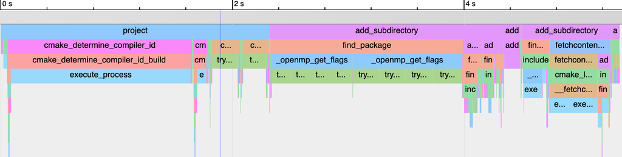

性能分析结果通常显示，诸如`try_compile()`和 `execute_process()`之类的调用消耗了大部分执行时间。与其仅仅关注这两个调用，不如检查导致这些命令的调用栈。通过避免在调用栈的上层使用不必要或过于保守的逻辑，或许可以减少这两个命令的调用频率。

The profiling results often show calls like `try_compile()` and `execute_process()` as consuming the majority of the execution time. Rather than focusing on those two calls specifically, inspect the call stacks that led up to those commands. There may be opportunities for reducing how often these two commands are called by avoiding unnecessary or overly pessimistic logic higher in the call stack.

## 13.6. 推荐做法

## 13.6. Recommended Practices

许多项目普遍存在一个问题，即在配置步骤中记录过多的输出。这往往会导致用户忽略这些输出，进而容易错过重要的消息和警告。如果输出非常精简，并且确实出现了警告，用户通常会注意到并调查原因。因此，应尽量减少`STATUS日志级别的输出，将更详细的输出保留到``VERBOSE`或更低的日志级别。如果支持低于 3.15 的 CMake 版本（这些版本不支持低于`STATUS 的`日志级别 ），请考虑将详细日志记录放在项目特定的缓存选项之后，该选项默认应关闭。

A common problem with many projects is that they log an excessive amount of output during the configure step. This tends to train users to ignore the output, which in turn means that important messages and warnings are easily missed. When the output is fairly minimal and a warning does occur, users tend to take note and investigate the cause. Therefore, aim to minimize the amount of output at the `STATUS` log level, saving more detailed output for a log level of `VERBOSE` or lower. If supporting CMake versions older than 3.15 where log levels below `STATUS` are not available, consider putting detailed logging behind a project-specific cache option, which should be off by default.

对于打算保留在构建过程中的日志消息，请务必在 `message()`命令的第一个参数中指定日志级别。如果消息属于一般信息性质，建议使用`STATUS` 而不是完全不指定关键字，这样消息输出就不会在构建日志中出现乱序。临时调试消息为了方便起见，通常省略日志级别，但如果它们可能会在项目中保留一段时间，最好也指定一个日志级别。

For log messages intended to remain as part of the build, aim to always specify a log level as the first argument to the `message()` command. If the message is of a general informational nature, prefer to use `STATUS` rather than no keyword at all so that message output does not appear out of order in the build log. Temporary debugging messages frequently omit specifying a log level for convenience, but if they are likely to remain part of the project for any length of time, it is better that they too specify a log level.

对于较为复杂的项目，建议添加消息上下文信息，以便用户能够筛选日志输出，专注于他们感兴趣的消息。切勿丢弃`CMAKE_MESSAGE_CONTEXT`变量的现有内容，在创建新的消息上下文时，务必使用`list(APPEND)`。如果消息上下文需要在当前变量作用域结束之前结束，请使用`list(POP_BACK)` 。除了可以使用这种追加/弹出模式之外，不要对变量的内容做任何假设。建议在顶层`CMakeLists.txt文件中，在第一个``project()`调用之前，紧接着添加项目名称作为消息上下文，以便编译器特性检查也能拥有消息上下文。

For non-trivial projects, consider adding message context information to allow users to filter log output and focus on just those messages that are of interest to them. Never discard existing contents of the `CMAKE_MESSAGE_CONTEXT` variable, always use `list(APPEND)` when starting a new message context. If the message context should end before the end of the current variable scope, use `list(POP_BACK)`. Make no assumptions about what the variable contains other than that this append / pop back pattern can be used. Consider appending the project name as a message context immediately before the first `project()` call in the top level `CMakeLists.txt` file so that compiler feature checks also have a message context.

类似地，也可以考虑使用`CMAKE_MESSAGE_INDENT`变量为消息输出提供一些逻辑结构。建议使用两个空格作为缩进。虽然也允许其他缩进方式，但遵循此约定将使输出更加一致，尤其是在使用外部依赖项的层级式项目中。使用`list(APPEND)向现有缩进添加内容，切勿替换或丢弃``CMAKE_MESSAGE_INDENT`变量的现有内容。如有必要，可以使用`list(POP_BACK)`在当前变量作用域结束前再次减少缩进。

In a similar manner, also consider using the `CMAKE_MESSAGE_INDENT` variable to provide some logical structure to the message output. Prefer to append two spaces for an indent. While other indents are permitted, following this convention will make the output more consistent, especially in hierarchical projects that make use of external dependencies. Use `list(APPEND)` to add to the existing indent, never replace or discard the existing contents of the `CMAKE_MESSAGE_INDENT` variable. If required, `list(POP_BACK)` can be used to reduce the indent again before the end of the current variable scope.

`无论项目支持的最低 CMake 版本是多少， CMAKE_MESSAGE_CONTEXT`和`CMAKE_MESSAGE_INDENT`变量都可以由项目填充。如果使用不识别这些变量的早期 CMake 版本，它将忽略这些变量，输出不会受到影响。因此，即使项目需要支持更早的 CMake 版本，也建议使用这些特性。请注意，`list(POP_BACK)`命令需要 CMake 3.15 或更高版本，因此如果项目需要支持更早的版本，则必须使用其他命令来实现相同的效果。不过，在大多数情况下，新的消息上下文或缩进级别会应用到当前变量作用域的末尾，在这种情况下，无需从列表变量的末尾弹出最后一个值。

Both the `CMAKE_MESSAGE_CONTEXT` and `CMAKE_MESSAGE_INDENT` variables can be populated by the project regardless of the minimum supported CMake version. When an earlier CMake version that doesn’t know about these variables is used, it will simply ignore them and the output will be unaffected. Therefore, consider using these features even if the project needs to support earlier CMake versions. Note that the `list(POP_BACK)` command requires CMake 3.15 or later, so if the project needs to support versions earlier that that, it must use alternative commands to achieve the same effect where that is needed. In most cases though, a new message context or indentation level will apply through to the end of the current variable scope, in which case popping the last value from the end of the list variable won’t be necessary.

建议使用`message()命令的``CHECK_START`、`CHECK_PASS`和`CHECK_FAIL`形式 来记录检查详情。这可以减少消息重复，提高可读性。尤其当与`CMAKE_MESSAGE_INDENT`变量提供的缩进支持结合使用时，效果更佳。

Consider using the `CHECK_START`, `CHECK_PASS` and `CHECK_FAIL` form of the `message()` command to record details of checks. This reduces duplication of messages and provides improved readability. It is especially effective when used in conjunction with the indenting support provided by the `CMAKE_MESSAGE_INDENT` variable.

如果项目的配置阶段耗时过长，可以考虑使用 `--profiling-output`和`--profiling-format选项运行``CMake`，以分析时间都消耗在了哪里。这些选项在 CMake 3.18 及更高版本中可用，它们可以生成命令行级别的性能分析信息，这些信息可以使用 Chrome 浏览器或 Qt Creator 等 IDE 查看。

If the configure stage of a project takes a long time to complete, consider running `cmake` with the `--profiling-output` and `--profiling-format` options to investigate where the time is being spent. Available with CMake 3.18 or later, these options enable the generation of command-level profiling information which can be viewed with tools like the Chrome web browser or IDEs like Qt Creator.

第 24.6 节“调试 find_…() 调用”还讨论了 CMake 3.18 中添加的更多调试功能。这些功能与查找文件、包和其他内容有关，第 24 章“*查找内容”*对此进行了详细介绍。

Section 24.6, “Debugging find_…() Calls” also discusses further debugging features added in CMake 3.18. Those features relate to finding files, packages and other things, which is covered in detail in Chapter 24, *Finding Things*.

# 第二部分：深入构建

# Part II: Builds In Depth

前几章逐步介绍了CMake最基本的方面。核心语言特性、关键概念和重要构建模块都已阐述，为深入探索CMake的功能奠定了坚实的基础。

In the preceding chapters, the most fundamental aspects of CMake were progressively introduced. Core language features, key concepts and important building blocks were presented, providing a solid foundation for a deeper exploration of CMake’s functionality.

本书的这一部分将重点放在构建产品上。各章节涵盖了工具链和构建配置、不同类型的目标、执行自定义任务以及处理平台特定功能。深入理解这些方面，是打造一个稳健易维护的项目，而非脆弱复杂项目的关键所在。

In this part of the book, the build products become the focus. Chapters cover the toolchain and build configuration, different types of targets, carrying out custom tasks and handling platform-specific features. Understanding these areas well can be the difference between a fragile, complex project and a robust, easy to maintain one.

# 14. 建造类型

# 14. Build Type

本章和下一章将涵盖两个密切相关的主题。构建类型（在某些 IDE 工具中也称为构建配置或构建方案）是一个高级控制项，用于选择不同的编译器和链接器行为。本章将重点介绍如何操作构建类型，而下一章将更详细地介绍如何控制编译器和链接器选项。这两章的内容涵盖了除最简单的项目之外，每个 CMake 开发人员通常都会用到的知识。

This chapter and the next cover two closely related topics. The build type (also known as the build configuration or build scheme in some IDE tools) is a high level control which selects different sets of compiler and linker behavior. Manipulation of the build type is the subject of this chapter, while the next chapter presents more specific details of controlling compiler and linker options. Together, these chapters cover material every CMake developer will typically use for all but the most trivial projects.

## 14.1. 构建类型基础知识

## 14.1. Build Type Basics

构建类型几乎会以某种方式影响构建过程的方方面面。虽然它主要直接影响编译器和链接器的行为，但也会影响项目使用的目录结构。这反过来又会影响开发人员如何设置本地开发环境，因此构建类型的影响范围可能相当广泛。

The build type has the potential to affect almost everything about the build in one way or another. While it primarily has a direct effect on the compiler and linker behavior, it also has an effect on the directory structure used for a project. This can in turn influence how a developer sets up their own local development environment, so the effects of the build type can be quite far reaching.

开发者通常将构建版本分为两种：调试版本和发布版本。对于调试版本，编译器会启用一些标志来记录调试器可以用来将机器指令与源代码关联起来的信息。这类版本通常会禁用优化，以便在单步执行程序时，机器指令到源代码位置的映射关系能够直接且易于追踪。而发布版本则通常会启用所有优化，并且不会生成任何调试信息。

Developers commonly think of builds as being one of two arrangements: debug or release. For a debug build, compiler flags are used to enable the recording of information that debuggers can use to associate machine instructions with the source code. Optimizations are frequently disabled in such builds so that the mapping from machine instruction to source code location is direct and easy to follow when stepping through program execution. A release build, on the other hand, generally has full optimizations enabled and no debug information generated.

这些是 CMake 所说的*构建类型*的示例。虽然项目可以定义任何所需的构建类型，但 CMake 提供的默认构建类型通常足以满足大多数项目的需求：

These are examples of what CMake refers to as the *build type*. While projects are able to define whatever build types they want, the default build types provided by CMake are usually sufficient for most projects:

**调试**

**Debug**

由于没有进行任何优化，并且提供了完整的调试信息，因此这种方案常用于开发和调试过程中，因为它通常能提供最快的构建速度和最佳的交互式调试体验。

With no optimizations and full debug information, this is commonly used during development and debugging, as it typically gives the fastest build times and the best interactive debugging experience.

**发布**

**Release**

这种构建类型通常会提供全面的速度优化，但不包含调试信息，尽管某些平台在特定情况下仍可能生成调试符号。它通常用于构建最终生产版本软件。

This build type typically provides full optimizations for speed and no debug information, although some platforms may still generate debug symbols in certain circumstances. It is generally the build type used when building software for final production releases.

**RelWithDebInfo**

**RelWithDebInfo**

这算是前两种方案的折衷方案。它旨在提供接近`发布版本性能的版本，同时仍允许一定程度的调试。通常会应用大多数速度优化，但也会启用大多数调试功能。因此，当``调试`版本即使在调试会话中也无法接受的性能时，这种构建类型最为有用。请注意， `RelWithDebInfo`的默认设置会禁用断言。

This is somewhat of a compromise of the previous two. It aims to give performance close to a `Release` build, but still allow some level of debugging. Most optimizations for speed are typically applied, but most debug functionality is also enabled. This build type is therefore most useful when the performance of a `Debug` build is not acceptable even for a debugging session. Note that the default settings for `RelWithDebInfo` will disable assertions.

**MinSizeRel**

**MinSizeRel**

这种构建类型通常仅用于资源受限的环境，例如嵌入式设备。代码优化侧重于体积而非速度，并且不会生成调试信息。

This build type is typically only used for constrained resource environments such as embedded devices. The code is optimized for size rather than speed and no debug information is created.

每种构建类型都会产生不同的编译器和链接器标志。它还可能改变其他行为，例如改变要编译的源文件或要链接的库。这些细节将在接下来的几节中介绍，但在深入讨论之前，必须了解如何选择构建类型以及如何避免一些常见问题。

Each build type results in a different set of compiler and linker flags. It may also change other behaviors, such as altering which source files get compiled or what libraries to link to. These details are covered in the next few sections, but before launching into those discussions, it is essential to understand how to select the build type and how to avoid some common problems.

### 14.1.1. 单一配置生成器

### 14.1.1. Single Configuration Generators

在2.3 节“生成项目文件”中，我们介绍了不同类型的项目生成器。有些生成器，例如 Makefile 和 Ninja，每个构建目录只支持一种构建类型。对于这些生成器，必须通过设置`CMAKE_BUILD_TYPE`缓存变量来选择构建类型。例如，要使用 Ninja 配置并构建项目，可以使用如下命令：

Back in Section 2.3, “Generating Project Files”, the different types of project generators were introduced. Some, like Makefiles and Ninja, support only a single build type per build directory. For these generators, the build type has to be chosen by setting the `CMAKE_BUILD_TYPE` cache variable. For example, to configure and then build a project with Ninja, one might use commands like this:

```
cmake -G Ninja -DCMAKE_BUILD_TYPE:STRING=Debug ../source
cmake --build .
```

`CMAKE_BUILD_TYPE`缓存变量也可以在 CMake GUI 应用程序中更改，而无需通过命令行，但最终效果相同。不过，除了在不同的构建类型之间切换之外，另一种策略是为每种构建类型设置单独的构建目录，所有目录仍然使用相同的源代码。这样的目录结构可能如下所示：

The `CMAKE_BUILD_TYPE` cache variable can also be changed in the CMake GUI application instead of from the command line, but the end effect is the same. Rather than switching between different build types, however, an alternative strategy is to set up separate build directories for each build type, all still using the same sources. Such a directory structure might look something like this:

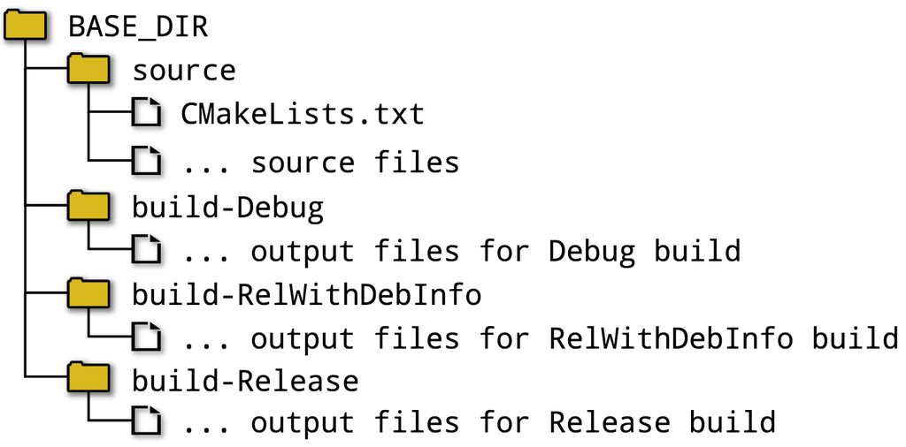

如果频繁切换构建类型，这种安排可以避免因编译器标志更改而不断重新编译相同的源代码。它还允许单个配置生成器有效地充当多配置生成器，像 Qt Creator 这样的 IDE 环境可以像 Xcode 或 Visual Studio 一样轻松地切换构建目录。

If frequently switching between build types, this arrangement avoids having to constantly recompile the same sources just because compiler flags change. It also allows a single configuration generator to effectively act like a multi configuration generator, with IDE environments like Qt Creator supporting switching between build directories just as easily as Xcode or Visual Studio allow switching between build schemes or configurations.

### 14.1.2. 多种配置生成器

### 14.1.2. Multiple Configuration Generators

一些生成器，特别是 Xcode 和 Visual Studio，支持在单个构建目录中使用多个配置。从 CMake 3.17 开始，还提供了 Ninja Multi-Config 生成器。这些多配置生成器会忽略`CMAKE_BUILD_TYPE`缓存变量，而是要求开发者在 IDE 中或通过命令行选项在构建时选择构建类型。配置和构建此类项目通常如下所示：

Some generators, notably Xcode and Visual Studio, support multiple configurations in a single build directory. From CMake 3.17, the Ninja Multi-Config generator is also available. These multi-config generators ignore the `CMAKE_BUILD_TYPE` cache variable and instead require the developer to choose the build type within the IDE or with a command line option at build time. Configuring and building such projects would typically look something like this:

```
cmake -G Xcode ../source
cmake --build . --config Debug
```

在 Xcode IDE 中构建时，构建类型由构建方案控制；而在 Visual Studio IDE 中，构建类型则由当前解决方案配置控制。两种环境都为不同的构建类型维护独立的目录，因此切换构建类型不会导致频繁重新构建。实际上，这与上述针对单配置生成器的多构建目录安排机制相同，只是 IDE 代表开发者处理了目录结构。

When building within the Xcode IDE, the build type is controlled by the build scheme, while within the Visual Studio IDE, the current solution configuration controls the build type. Both environments keep separate directories for the different build types, so switching between builds doesn’t cause constant rebuilds. In effect, the same thing is being done as the multiple build directory arrangement described above for single configuration generators, it’s just that the IDE is handling the directory structure on the developer’s behalf.

对于命令行构建，Ninja Multi-Config 生成器相比其他多配置生成器具有更高的灵活性。可以使用`CMAKE_DEFAULT_BUILD_TYPE`缓存变量来更改在构建命令行中未指定配置时使用的默认配置。Xcode 和 Visual Studio 生成器则使用各自固定的逻辑来确定此场景下的默认配置。Ninja Multi-Config 生成器还支持一些高级功能，允许将自定义命令作为一种配置执行，而将其他目标使用一个或多个其他配置进行构建。大多数项目通常不需要或无法从这些高级功能中受益，但 Ninja Multi-Config 生成器的 CMake 文档提供了必要的细节和示例。

For command-line builds, the Ninja Multi-Config generator has a little more flexibility compared to the other multi-config generators. The `CMAKE_DEFAULT_BUILD_TYPE` cache variable can be used to change the default configuration to use when no configuration is specified on the build command line. The Xcode and Visual Studio generators have their own fixed logic for determining the default configuration in this scenario. The Ninja Multi-Config generator also supports advanced features that allow custom commands to execute as one configuration, but other targets to be built with one or more other configurations. Most projects would not typically need or benefit from these more advanced features, but the CMake documentation for the Ninja Multi-Config generator provides the essential details, with examples.

## 14.2. 常见错误

## 14.2. Common Errors

请注意，对于单配置生成器，构建类型是在 *配置*时指定的；而对于多配置生成器，构建类型是在*构建时指定的。这种区别至关重要，因为它意味着 CMake 在处理项目的*`CMakeLists.txt`文件时，并非总是知道构建类型 。请看以下这段 CMake 代码，这段代码虽然很常见，但却展示了一种错误的模式：

Note how for single configuration generators, the build type is specified at *configure* time, whereas for multi configuration generators, the build type is specified at *build* time. This distinction is critical, as it means the build type is not always known when CMake is processing a project’s `CMakeLists.txt` file. Consider the following piece of CMake code, which unfortunately is rather common, but demonstrates an incorrect pattern:

```
# WARNING: Do not do this!
if(CMAKE_BUILD_TYPE STREQUAL "Debug")
    # Do something only for debug builds
endif()
```

上述方法对于基于 Makefile 的生成器和 Ninja 来说效果不错，但对于 Xcode、Visual Studio 或 Ninja Multi-Config 则不然。实际上，除非通过检查确认只使用了一个配置生成器，否则项目中几乎所有基于`CMAKE_BUILD_TYPE`的逻辑都值得怀疑。对于多配置生成器，该变量很可能为空，即使不为空，其值也应被视为不可靠，因为构建过程会忽略它。项目不应在`CMakeLists.txt文件中引用``CMAKE_BUILD_TYPE`，而应使用其他更可靠的替代技术，例如基于`$<CONFIG:…> 的`生成器表达式。

The above would work fine for Makefile-based generators and Ninja, but not for Xcode, Visual Studio or Ninja Multi-Config. In practice, just about any logic based on `CMAKE_BUILD_TYPE` within a project is questionable unless it is protected by a check to confirm a single configuration generator is being used. For multi configuration generators, this variable is likely to be empty, but even if it isn’t, its value should be considered unreliable because the build will ignore it. Rather than referring to `CMAKE_BUILD_TYPE` in the `CMakeLists.txt` file, projects should instead use other more robust alternative techniques, such as generator expressions based on `$<CONFIG:…>`.

编写构建脚本时，一个常见的缺陷是假定使用了特定的生成器，或者没有正确处理单配置生成器和多配置生成器之间的差异。理想情况下，开发人员应该能够在脚本的一处更改生成器，而脚本的其余部分仍然能够正常运行。方便的是，单配置生成器会忽略任何构建时规范，而多配置生成器会忽略 `CMAKE_BUILD_TYPE`变量，因此通过同时指定两者，脚本可以兼顾这两种情况。例如：

When scripting builds, a common deficiency is to assume a particular generator is used or to not properly account for differences between single and multi configuration generators. Developers should ideally be able to change the generator in one place and the rest of the script should still function correctly. Conveniently, single configuration generators will ignore any build-time specification and multi configuration generators will ignore the `CMAKE_BUILD_TYPE` variable, so by specifying both, a script can account for both cases. For example:

[output not shown]

以上述示例为例，开发人员只需更改`-G`参数指定的生成器名称，脚本的其余部分即可保持不变。

With the above example, a developer could simply change the generator name given to the `-G` parameter and the rest of the script would work unchanged.

对于单配置生成器，不显式设置`CMAKE_BUILD_TYPE`也很常见，但这通常并非开发者的本意。单配置生成器的一个独特之处在于，如果 未设置`CMAKE_BUILD_TYPE`，则构建类型通常为空。这有时会导致一些开发者误认为空构建类型等同于 Debug 构建类型，但事实并非如此。空构建类型是一种独特的、无名称的构建类型。在这种情况下，不会使用任何特定于配置的编译器或链接器标志，这通常会导致编译器和链接器以最少的标志调用。此时，其行为由编译器和链接器自身的默认值决定。虽然这通常可能类似于 Debug 构建类型的行为，但这绝非必然。

Not explicitly setting the `CMAKE_BUILD_TYPE` for single configuration generators is also common, but usually not what the developer intended. A behavior unique to single configuration generators is that if `CMAKE_BUILD_TYPE` is not set, the build type will usually be empty. This occasionally leads to a misunderstanding by some developers that an empty build type is equivalent to Debug, but this is not the case. An empty build type is its own unique, nameless build type. In such cases, no configuration-specific compiler or linker flags are used, which often results in invoking the compiler and linker with minimal flags. The behavior is then determined by the compiler’s and linker’s own defaults. While this may often be similar to the Debug build type’s behavior, it is by no means guaranteed.

使用 Visual Studio 编译器和单个配置生成器是一种特殊情况。对于该工具链，调试版本和非调试版本使用不同的运行时库。如果生成类型为空，则无法明确应该使用哪个运行时。为了避免这种歧义，对于此组合，生成类型将默认为“调试”。

Using the Visual Studio compilers with a single configuration generator is somewhat of a special case. For that toolchain, there are different runtime libraries for debug and non-debug builds. An empty build type would make it unclear which runtime should be used. To avoid this ambiguity, the build type will default to Debug for this combination.

## 14.3. 自定义构建类型

## 14.3. Custom Build Types

有时，项目可能希望将构建类型限制为默认类型的子集，或者希望添加具有特定编译器和链接器标志的自定义构建类型。后者的一个很好的例子是添加用于性能分析或代码覆盖率的构建类型，这两种构建类型都需要特定的编译器和链接器设置。

Sometimes a project may want to limit the set of build types to a subset of the defaults, or it may want to add other custom build types with a special set of compiler and linker flags. A good example of the latter is adding a build type for profiling or code coverage, both of which require specific compiler and linker settings.

开发者可以在两个主要地方查看构建类型集。在使用 Xcode 和 Visual Studio 等多配置生成器的 IDE 环境时，IDE 会提供一个下拉列表或类似选项，供开发者选择要构建的配置。对于 Makefile 或 Ninja 等单配置生成器，构建类型直接输入到`CMAKE_BUILD_TYPE`缓存变量中，但 CMake GUI 应用程序可以配置为显示一个包含有效选项的组合框，而不是简单的文本编辑框。这两种情况背后的机制不同，因此必须分别处理。

There are two main places where a developer may see the set of build types. When using IDE environments for multi configuration generators like Xcode and Visual Studio, the IDE provides a drop-down list or similar from which the developer selects the configuration they wish to build. For single configuration generators like Makefiles or Ninja, the build type is entered directly for the `CMAKE_BUILD_TYPE` cache variable, but the CMake GUI application can be made to present a combo box of valid choices instead of a simple text edit field. The mechanisms behind these two cases are different, so they must be handled separately.

多配置生成器已知的构建类型集合由缓存变量`CMAKE_CONFIGURATION_TYPES`控制，更准确地说，是由顶层 `CMakeLists.txt` 文件处理完毕后该变量的值控制。首次遇到的`project()`命令会使用默认列表填充缓存变量（如果尚未定义），但之后项目可以修改同名的非缓存变量（修改缓存变量是不安全的，因为它可能会丢弃开发人员所做的更改）。可以通过将自定义构建类型添加到 `CMAKE_CONFIGURATION_TYPES`来定义它们，也可以从该列表中删除不需要的构建类型。

The set of build types known to multi configuration generators is controlled by the `CMAKE_CONFIGURATION_TYPES` cache variable, or more accurately, by the value of this variable at the end of processing the top level `CMakeLists.txt` file. The first encountered `project()` command populates the cache variable with a default list if it has not already been defined, but projects may modify the non-cache variable of the same name after that point (modifying the cache variable is unsafe since it may discard changes made by the developer). Custom build types can be defined by adding them to `CMAKE_CONFIGURATION_TYPES` and unwanted build types can be removed from that list.

然而，需要注意的是，如果`CMAKE_CONFIGURATION_TYPES` 尚未定义，则应避免设置它。在 CMake 3.9 之前，判断是否使用了多配置生成器的一个常见方法是检查`CMAKE_CONFIGURATION_TYPES`是否为空。甚至在 CMake 3.11 版本之前，CMake 本身的部分代码也采用了这种方法。虽然这种方法通常是准确的，但项目即使只使用单个配置生成器，也常常会单方面地设置`CMAKE_CONFIGURATION_TYPES`。这可能会导致对所使用的生成器类型做出错误的判断。为了解决这个问题，CMake 3.9 添加了一个新的 全局属性`GENERATOR_IS_MULTI_CONFIG`，当使用多配置生成器时，该属性会被设置为 true，从而提供了一种获取此信息的明确方法，而无需依赖从 `CMAKE_CONFIGURATION_TYPES`推断。即便如此，检查`CMAKE_CONFIGURATION_TYPES`仍然是一种非常普遍的做法，因此项目应该继续仅在其存在的情况下对其进行修改，而不应自行创建。还应注意的是，在 CMake 3.11 之前的版本中，向`CMAKE_CONFIGURATION_TYPES`添加自定义构建类型在技术上并不安全。CMake 的某些部分仅考虑默认构建类型，但即便如此，项目仍然可以使用早期版本的 CMake 来定义自定义构建类型，具体取决于它们的使用方式。也就是说，为了提高健壮性，如果要定义自定义构建类型，仍然建议至少使用 CMake 3.11。

Care needs to be taken, however, to avoid setting `CMAKE_CONFIGURATION_TYPES` if it is not already defined. Prior to CMake 3.9, a very common approach for determining whether a multi configuration generator was being used was to check if `CMAKE_CONFIGURATION_TYPES` was non-empty. Even parts of CMake itself did this prior to 3.11. While this method is usually accurate, it is not unusual to see projects unilaterally set `CMAKE_CONFIGURATION_TYPES` even if using a single configuration generator. This can lead to wrong decisions being made regarding the type of generator in use. To address this, CMake 3.9 added a new `GENERATOR_IS_MULTI_CONFIG` global property which is set to true when a multi configuration generator is being used, providing a definitive way to obtain that information instead of relying on inferring it from `CMAKE_CONFIGURATION_TYPES`. Even so, checking `CMAKE_CONFIGURATION_TYPES` is still such a prevalent pattern that projects should continue to only modify it if it exists and never create it themselves. It should also be noted that prior to CMake 3.11, adding custom build types to `CMAKE_CONFIGURATION_TYPES` was not technically safe. Certain parts of CMake only accounted for the default build types, but even so, projects may still be able to usefully define custom build types with earlier CMake versions, depending on how they are going to be used. That said, for better robustness, it is still recommended to use at least CMake 3.11 if custom build types are going to be defined.

`这个问题还涉及另一个方面：开发者可能会向CMAKE_CONFIGURATION_TYPES`缓存变量中添加自定义类型 ，或者移除他们不感兴趣的类型。因此，项目不应假设哪些配置类型已定义或未定义。

Another aspect of this issue is that developers may add their own types to the `CMAKE_CONFIGURATION_TYPES` cache variable and/or remove those they are not interested in. Projects should therefore not make any assumptions about what configuration types are or are not defined.

考虑到以上几点，以下模式展示了项目为多配置生成器添加自定义构建类型的首选方式：

Taking the above points into account, the following pattern shows the preferred way for projects to add their own custom build types for multi configuration generators:

```
cmake_minimum_required(3.11)
project(Foo)

get_property(isMultiConfig GLOBAL
    PROPERTY GENERATOR_IS_MULTI_CONFIG
)
if(isMultiConfig)
    if(NOT "Profile" IN_LIST CMAKE_CONFIGURATION_TYPES)
        list(APPEND CMAKE_CONFIGURATION_TYPES Profile)
    endif()
endif()

# Set relevant Profile-specific flag variables as needed...
```

对于单配置生成器，只有一个构建类型，它由缓存变量`CMAKE_BUILD_TYPE`指定，该变量是一个字符串。在 CMake GUI 中，它通常显示为一个文本编辑框，开发者可以编辑它以包含任何所需的内容。然而，正如我们在9.6 节“缓存变量属性”中讨论的那样，缓存变量的`STRINGS`属性可以定义为一组有效值。这样，CMake GUI 应用程序就会将该变量显示为一个包含有效值的组合框，而不是文本编辑框。

For single configuration generators, there is only one build type and it is specified by the `CMAKE_BUILD_TYPE` cache variable, which is a string. In the CMake GUI, this is normally presented as a text edit field, so the developer can edit it to contain whatever arbitrary content they wish. As discussed back in Section 9.6, “Cache Variable Properties”, however, cache variables can have their `STRINGS` property defined to hold a set of valid values. The CMake GUI application will then present that variable as a combo box containing the valid values instead of as a text edit field.

```
set_property(CACHE CMAKE_BUILD_TYPE PROPERTY
    STRINGS Debug Release Profile
)
```

属性只能在项目的`CMakeLists.txt`文件中进行更改，因此开发者可以安全地设置`STRINGS`属性，而无需担心会保留任何更改。但是请注意，设置缓存变量的`STRINGS` 属性并不能保证该缓存变量会包含已定义的值之一，它仅控制变量在 CMake GUI 应用程序中的显示方式。开发者仍然可以在`cmake命令行中将``CMAKE_BUILD_TYPE`设置为任何值，或者手动编辑`CMakeCache.txt`文件。为了严格要求变量必须包含已定义的值之一，项目必须显式地执行该测试。

Properties can only be changed from within the project’s `CMakeLists.txt` files, so they can safely set the `STRINGS` property without having to worry about preserving any developer changes. Note, however, that setting the `STRINGS` property of a cache variable does not guarantee that the cache variable will hold one of the defined values, it only controls how the variable is presented in the CMake GUI application. Developers can still set `CMAKE_BUILD_TYPE` to any value at the `cmake` command line or edit the `CMakeCache.txt` file manually. In order to rigorously require the variable to have one of the defined values, a project must explicitly perform that test itself.

```
set(allowedBuildTypes Debug Release Profile)

# WARNING: This logic is not sufficient
if(NOT CMAKE_BUILD_TYPE IN_LIST allowedBuildTypes)
    message(FATAL_ERROR
        "${CMAKE_BUILD_TYPE} is not a known build type"
    )
endif()
```

`CMAKE_BUILD_TYPE`的默认值为空字符串，因此，除非开发者显式设置，否则上述代码对于单配置生成器和多配置生成器都会导致致命错误。这尤其对于根本不使用`CMAKE_BUILD_TYPE`变量值的多配置生成器而言是不理想的。可以通过让项目在 未设置`CMAKE_BUILD_TYPE`时提供一个默认值来解决这个问题。此外，可以而且应该将单配置生成器和多配置生成器的技术结合起来，以确保所有生成器类型都能获得稳健的行为。最终结果可能如下所示：

The default value for `CMAKE_BUILD_TYPE` is an empty string, so the above would cause a fatal error for both single and multi configuration generators unless the developer explicitly set it. This is undesirable, especially for multi configuration generators which don’t even use the `CMAKE_BUILD_TYPE` variable’s value. This can be handled by having the project provide a default value if `CMAKE_BUILD_TYPE` hasn’t been set. Furthermore, the techniques for multi and single configuration generators can and should be combined to give robust behavior across all generator types. The end result would look something like this:

```
cmake_minimum_required(3.11)
project(Foo)

get_property(isMultiConfig GLOBAL
    PROPERTY GENERATOR_IS_MULTI_CONFIG
)
if(isMultiConfig)
    if(NOT "Profile" IN_LIST CMAKE_CONFIGURATION_TYPES)
        list(APPEND CMAKE_CONFIGURATION_TYPES Profile)
    endif()
else()
    set(allowedBuildTypes Debug Release Profile)
    set_property(CACHE CMAKE_BUILD_TYPE PROPERTY
        STRINGS "${allowedBuildTypes}"
    )
    if(NOT CMAKE_BUILD_TYPE)
        set(CMAKE_BUILD_TYPE Debug CACHE STRING "" FORCE)
    elseif(NOT CMAKE_BUILD_TYPE IN_LIST allowedBuildTypes)
        message(FATAL_ERROR
            "Unknown build type: ${CMAKE_BUILD_TYPE}"
        )
    endif()
endif()

# Set relevant Profile-specific flag variables as needed...
```

以上讨论的所有技术仅仅允许选择自定义构建类型，它们并不定义该构建类型的任何具体细节。从根本上讲，选择构建类型后，它会指定 CMake 应该使用哪些特定于配置的变量，并且还会影响任何逻辑依赖于当前配置的生成器表达式（例如`$<CONFIG>`和`$<CONFIG:…>` ）。这些变量和生成器表达式将在下一章详细讨论，但现在，我们主要关注以下两类变量：

All of the techniques discussed above merely allow a custom build type to be selected, they don’t define anything about that build type. Fundamentally, when a build type is selected, it specifies which configuration-specific variables CMake should use and it also affects any generator expressions whose logic depends on the current configuration (i.e. `$<CONFIG>` and `$<CONFIG:…>`). These variables and generator expressions are discussed in detail in the next chapter, but for now, the following two families of variables are of primary interest:

- `CMAKE_<LANG>_FLAGS_<CONFIG>`
- `CMAKE_<LANG>_FLAGS_<CONFIG>`
- `CMAKE_<TARGETTYPE>_LINKER_FLAGS_<CONFIG>`
- `CMAKE_<TARGETTYPE>_LINKER_FLAGS_<CONFIG>`

`这些参数可用于在不带_<CONFIG>`后缀的同名变量提供的默认标志集之外，添加额外的编译器和链接器标志 。例如，可以按如下方式定义自定义`Profile构建类型的标志：`

These can be used to add additional compiler and linker flags over and above the default set provided by the same-named variables without the `_<CONFIG>` suffix. For example, flags for a custom `Profile` build type could be defined as follows:

```
set(CMAKE_C_FLAGS_PROFILE
    "-p -g -O2"
    CACHE STRING ""
)
set(CMAKE_CXX_FLAGS_PROFILE
    "-p -g -O2"
    CACHE STRING ""
)
set(CMAKE_EXE_LINKER_FLAGS_PROFILE
    "-p -g -O2"
    CACHE STRING ""
)
set(CMAKE_SHARED_LINKER_FLAGS_PROFILE
    "-p -g -O2"
    CACHE STRING ""
)
set(CMAKE_STATIC_LINKER_FLAGS_PROFILE
    ""
    CACHE STRING ""
)
set(CMAKE_MODULE_LINKER_FLAGS_PROFILE
    "-p -g -O2"
    CACHE STRING ""
)
```

以上示例假设使用 GCC 兼容的编译器，并启用性能分析、调试符号以及大多数优化。另一种方法是基于其他构建类型设置编译器和链接器标志，并添加所需的额外标志。只要此操作在 `project()`命令之后执行即可，因为该命令会填充默认的编译器和链接器标志变量。对于性能分析，默认的`RelWithDebInfo`构建类型是一个不错的选择，因为它同时启用了调试和大多数优化。

The above assumes a GCC-compatible compiler to keep the example simple and turns on profiling as well as enabling debugging symbols and most optimizations. An alternative is to base the compiler and linker flags on one of the other build types and add the extra flags needed. This can be done as long as it comes after the `project()` command, since that command populates the default compiler and linker flag variables. For profiling, the `RelWithDebInfo` default build type is a good one to choose as the base configuration since it enables both debugging and most optimizations:

```
set(CMAKE_C_FLAGS_PROFILE
    "${CMAKE_C_FLAGS_RELWITHDEBINFO} -p"
    CACHE STRING ""
)
set(CMAKE_CXX_FLAGS_PROFILE
    "${CMAKE_CXX_FLAGS_RELWITHDEBINFO} -p"
    CACHE STRING ""
)
set(CMAKE_EXE_LINKER_FLAGS_PROFILE
    "${CMAKE_EXE_LINKER_FLAGS_RELWITHDEBINFO} -p"
    CACHE STRING ""
)
set(CMAKE_SHARED_LINKER_FLAGS_PROFILE
    "${CMAKE_SHARED_LINKER_FLAGS_RELWITHDEBINFO} -p"
    CACHE STRING ""
)
set(CMAKE_STATIC_LINKER_FLAGS_PROFILE
    "${CMAKE_STATIC_LINKER_FLAGS_RELWITHDEBINFO}"
    CACHE STRING ""
)
set(CMAKE_MODULE_LINKER_FLAGS_PROFILE
    "${CMAKE_MODULE_LINKER_FLAGS_RELWITHDEBINFO} -p"
    CACHE STRING ""
)
```

每个自定义配置都应该定义相关的编译器和链接器标志变量。对于某些多配置生成器类型，CMake 会检查所需的变量是否存在，如果未设置，则会报错。

Each custom configuration should have the associated compiler and linker flag variables defined. For some multi configuration generator types, CMake will check that the required variables exist and will fail with an error if they are not set.

另一个有时会为自定义构建类型定义的变量是 `CMAKE_<CONFIG>_POSTFIX`。它用于初始化 每个库目标的`<CONFIG>_POSTFIX`属性，其值会在为指定配置构建时附加到这些目标的文件名。这样，来自多个构建类型的库就可以放在同一个目录中，而不会相互覆盖。CMAKE_DEBUG_POSTFIX通常设置为`d``或``_debug`之类的值，尤其是在 Visual Studio 构建中，因为调试版本和非调试版本必须使用不同的运行时 DLL，所以包可能需要包含两种构建类型的库。对于上面定义的自定义`Profile`构建类型，示例可能是：

Another variable which may sometimes be defined for a custom build type is `CMAKE_<CONFIG>_POSTFIX`. It is used to initialize the `<CONFIG>_POSTFIX` property of each library target, with its value being appended to the file name of such targets when built for the specified configuration. This allows libraries from multiple build types to be put in the same directory without overwriting each other. `CMAKE_DEBUG_POSTFIX` is often set to values like `d` or `_debug`, especially for Visual Studio builds where different runtime DLLs must be used for Debug and non-Debug builds, so packages may need to include libraries for both build types. In the case of the custom `Profile` build type defined above, an example might be:

```
set(CMAKE_PROFILE_POSTFIX _profile)
```

如果创建的软件包包含多种构建类型，强烈建议为每种构建类型设置 `CMAKE_<CONFIG>_POSTFIX`。按照惯例，Release 构建的后缀通常为空。但请注意，在 Apple 平台上， `<CONFIG>_POSTFIX` target 属性会被忽略。

If creating packages that contain multiple build types, setting `CMAKE_<CONFIG>_POSTFIX` for each build type is highly recommended. By convention, the postfix for Release builds is typically empty. Note though that the `<CONFIG>_POSTFIX` target property is ignored on Apple platforms.

`出于历史原因，传递给target_link_libraries()` 命令的项可以带有`debug`或`optimized`关键字 前缀，分别表示该项仅应链接用于调试或非调试构建。如果构建类型列在全局属性`DEBUG_CONFIGURATIONS中，则被视为``调试`构建；否则，被视为`优化`构建。对于自定义构建类型，如果在此场景中应将其视为`调试`构建，则应将其名称添加到此全局属性中。例如，如果一个项目定义了自己的自定义构建类型 `StrictChecker`，并且该构建类型应被视为非优化调试构建类型，则可以（并且应该）像这样明确说明：

For historical reasons, the items passed to the `target_link_libraries()` command can be prefixed with the `debug` or `optimized` keywords to indicate that the named item should only be linked in for debug or non-debug builds respectively. A build type is considered to be a `debug` build if it is listed in the `DEBUG_CONFIGURATIONS` global property, otherwise it is considered to be `optimized`. For custom build types, they should have their name added to this global property if they should be treated as a `debug` build in this scenario. As an example, if a project defines its own custom build type called `StrictChecker` and that build type should be considered a non-optimized debug build type, it can (and should) make this clear like so:

```
set_property(GLOBAL APPEND PROPERTY
    DEBUG_CONFIGURATIONS StrictChecker
)
```

新项目通常应该优先使用生成器表达式，而不是使用 `target_link_libraries()命令中的``debug`和`optimized`关键字。下一章将更详细地讨论这方面的内容。

New projects should normally prefer to use generator expressions instead of the `debug` and `optimized` keywords with the `target_link_libraries()` command. The next chapter discusses this area in more detail.

## 14.4. 推荐做法

## 14.4. Recommended Practices

开发者不应假定某个特定的 CMake 生成器用于构建他们的项目。同一项目中的其他开发者可能更倾向于使用不同的生成器，因为它与他们的 IDE 工具集成得更好；或者，CMake 的未来版本可能会添加对新生成器类型的支持，从而带来其他好处。某些构建工具可能存在 bug，项目日后可能会受到影响，因此，准备一些备用生成器以备不时之需会很有帮助，直到这些 bug 得到修复。如果假定某个特定的 CMake 生成器，则扩展项目支持的平台集也会受到阻碍。

Developers should not assume a particular CMake generator is being used to build their project. Another developer on the same project may prefer to use a different generator because it integrates better with their IDE tool, or a future version of CMake may add support for a new generator type which might bring other benefits. Certain build tools may contain bugs which a project may later be affected by, so it can be useful to have alternative generators to fall back on until such bugs are fixed. Expanding a project’s set of supported platforms can also be hindered if a particular CMake generator has been assumed.

在使用 Makefile 或 Ninja 等单配置生成器时，建议使用多个构建目录，每个目录对应一个所需的构建类型。这样可以在不同的构建类型之间切换，而无需每次都强制重新编译。这种方法提供的行为与多配置生成器本身提供的行为类似，并且可以有效地使 Qt Creator 等 IDE 工具模拟多配置功能。

When using single configuration generators like Makefiles or Ninja, consider using multiple build directories, one for each build type of interest. This allows switching between build types without forcing a complete recompile each time. This provides similar behavior to that inherently offered by multi configuration generators and can be a useful way to enable IDE tools like Qt Creator to simulate multi configuration functionality.

对于单配置生成器，如果`CMAKE_BUILD_TYPE`为空，请考虑将其设置为更合适的默认值。虽然空构建类型在技术上是有效的，但开发人员经常会将其误解为调试构建，而不是其自身独特的构建类型。此外，除非事先确认使用的是单配置生成器，否则请避免基于`CMAKE_BUILD_TYPE`创建逻辑。即使如此，此类逻辑也可能不够稳定，或许可以使用生成器表达式来更通用、更健壮地表达。

For single configuration generators, consider setting `CMAKE_BUILD_TYPE` to a better default value if it is empty. While an empty build type is technically valid, it is also often misunderstood by developers to mean a Debug build rather than its own distinct build type. Furthermore, avoid creating logic based on `CMAKE_BUILD_TYPE` unless it is first confirmed that a single configuration generator is being used. Even then, such logic is likely to be fragile and could probably be expressed with more generality and robustness using generator expressions instead.

仅当已知正在使用多配置生成器或该变量已存在时，才考虑修改`CMAKE_CONFIGURATION_TYPES`变量。如果添加自定义构建类型或移除某个默认构建类型，请勿修改缓存变量，而应修改同名的常规变量（常规变量的优先级高于缓存变量）。此外，建议逐个添加或删除条目，而不是完全替换列表。这两种措施都有助于避免干扰开发人员对缓存变量所做的更改。

Only consider modifying the `CMAKE_CONFIGURATION_TYPES` variable if it is known that a multi configuration generator is being used or if the variable already exists. If adding a custom build type or removing one of the default build types, do not modify the cache variable but instead change the regular variable of the same name (it will take precedence over the cache variable). Also prefer to add and remove individual items rather than completely replacing the list. Both of these measures will help avoid interfering with changes made to the cache variable by the developer.

如果需要 CMake 3.9 或更高版本，请使用`GENERATOR_IS_MULTI_CONFIG全局属性来明确查询生成器类型，而不是依赖``CMAKE_CONFIGURATION_TYPES`的存在来执行不太可靠的检查。

If requiring CMake 3.9 or later, use the `GENERATOR_IS_MULTI_CONFIG` global property to definitively query the generator type instead of relying on the existence of `CMAKE_CONFIGURATION_TYPES` to perform a less robust check.

一种常见但错误的做法是查询`LOCATION`目标属性来确定目标的输出文件名。另一个相关的错误是在自定义命令中假定特定的构建输出目录结构（参见 第 18 章*“自定义任务*”）。这些方法并非适用于所有构建类型，因为 对于多配置生成器， `LOCATION`在配置时是未知的，而且不同 CMake 生成器类型的构建输出目录结构通常也不同。应该改用类似`$<TARGET_FILE:…>`的生成器表达式 ，因为它们能够可靠地为所有生成器（无论是单配置还是多配置）提供所需的路径。

A common but incorrect practice is to query the `LOCATION` target property to work out a target’s output file name. A related error is to assume a particular build output directory structure in custom commands (see Chapter 18, *Custom Tasks*). These methods do not work for all build types, since `LOCATION` is not known at configure time for multi configuration generators and the build output directory structure is typically different across the various CMake generator types. Generator expressions like `$<TARGET_FILE:…>` should be used instead, as they robustly provide the required path for all generators, whether they be single or multi configuration.

# 15. 编译器和链接器基础知识

# 15. Compiler And Linker Essentials

上一章讨论了构建类型及其与选择特定编译器和链接器行为之间的关系。本章将探讨如何控制这些编译器和链接器行为的基本原理。本章内容涵盖了每位 CMake 开发人员都应该熟悉的一些最重要的主题和技术。

The previous chapter discussed the build type and how it relates to selecting a particular set of compiler and linker behavior. This chapter discusses the fundamentals of how that compiler and linker behavior is controlled. The material presented here covers some of the most important topics and techniques with which every CMake developer should become familiar.

在继续之前，请注意，随着 CMake 的发展，控制编译器和链接器行为的方法也得到了改进。重点已从全局构建视角转向对每个目标的需求进行控制，以及控制这些需求如何应用于依赖于它的其他目标。这是一个重要的思维转变，因为它影响着项目如何最有效地定义目标的构建方式。CMake 更成熟的功能可以用于粗略地控制行为，但代价是失去了定义目标之间关系的能力。因此，应该优先选择最新的、以目标为中心的功能，因为它们极大地提高了构建的健壮性，并提供了对编译器和链接器行为更精确的控制。此外，这些新功能在行为和使用方式上也往往更加一致。

Before proceeding, note that as CMake has evolved, the available methods for controlling the compiler and linker behavior have also improved. The focus has shifted from a more build-global view to one where the requirements of each individual target can be controlled, along with how those requirements should or should not be applied to other targets that depend on it. This is an important shift in thinking, as it affects how a project can most effectively define the way targets should be built. CMake’s more mature features can be used to control behavior at a coarse level at the expense of losing the ability to define relationships between targets. The more recent target-focused features should be preferred instead, since they greatly improve the robustness of the build and offer much more precise control over compiler and linker behavior. The newer features also tend to be more consistent in their behavior and the way they are meant to be used.

## 15.1. 目标属性

## 15.1. Target Properties

在 CMake 的属性系统中，目标属性是控制编译器和链接器标志的主要机制。一些属性允许指定任意标志，而另一些属性则专注于特定功能，从而抽象化平台或编译器之间的差异。本章重点介绍更常用和通用的属性，后续章节将涵盖一些更具体的属性。

Within CMake’s property system, the target properties form the primary mechanism by which compiler and linker flags are controlled. Some properties provide the ability to specify any arbitrary flag, whereas others focus on a specific capability so they can abstract away platform or compiler differences. This chapter focuses on the more commonly used and general purpose properties, with later chapters covering a number of the more specific ones.

在继续之前，需要注意的是，以下章节讨论的目标属性通常不会被直接修改。CMake 提供了专门的命令，这些命令通常比直接操作属性更方便、更可靠。尽管如此，了解所涉及的底层属性仍然有助于开发人员理解这些命令的一些特性和限制。

Before proceeding, it should be noted that the target properties discussed in the following sections are not usually modified directly. CMake provides dedicated commands which are generally more convenient and more robust than direct property manipulation. Nevertheless, understanding the underlying properties involved can help developers understand some of the features and restrictions of those commands.

### 15.1.1. 编译器标志

### 15.1.1. Compiler Flags

控制编译器标志的最基本目标属性如下，每个属性都包含一个项目列表：

The most fundamental target properties for controlling compiler flags are the following, each of which hold a list of items:

**`包含目录`**

**`INCLUDE_DIRECTORIES`**

这是一个用作头文件搜索路径的目录列表，所有路径都必须是绝对路径。CMake 会为每个路径添加一个编译器标志，并在其前加上适当的前缀（通常为`-I`或 `/I`）。创建目标时，此目标属性的初始值取自同名目录属性。

This is a list of directories to be used as header search paths, all of which must be absolute paths. CMake will add a compiler flag for each path with an appropriate prefix prepended (typically `-I` or `/I`). When a target is created, the initial value of this target property is taken from the directory property of the same name.

**`编译定义`**

**`COMPILE_DEFINITIONS`**

此列表包含要在编译命令行中设置的定义。定义采用`VAR`或`VAR=VALUE 的`形式，CMake 会将其转换为适用于所用编译器的相应形式（通常为`-DVAR…`或`/DVAR…`）。创建目标时，此目标属性的初始值为空。虽然存在一个同名的目录属性，但它并不*用于*为该目标属性提供初始值。目录属性和目标属性会在最终的编译器命令行中*合并*。

This holds a list of definitions to be set on the compile command line. A definition has the form `VAR` or `VAR=VALUE`, which CMake will convert to the appropriate form for the compiler being used (typically `-DVAR…` or `/DVAR…`). When a target is created, the initial value of this target property will be empty. There is a directory property of the same name, but it is *not* used to provide an initial value for this target property. Rather, the directory and target properties are *combined* in the final compiler command line.

**`编译选项`**

**`COMPILE_OPTIONS`**

此属性中提供了既非头文件搜索路径也非符号定义的任何编译器标志。创建目标时，此目标属性的初始值取自同名的目录属性。请注意，此属性也会进行去重（ 更多详情请参见第 15.3 节“去重选项” ）。

Any compiler flags that are neither header search paths nor symbol definitions are provided in this property. When a target is created, the initial value of this target property is taken from the directory property of the same name. Note that this property is also subject to de-duplication (see Section 15.3, “De-duplicating Options” for further details).

INCLUDE_DIRECTORIES和`COMPILE_DEFINITIONS`属性实际上只是为了方便起见，它们处理了项目中最常用的一些编译器特定标志。所有剩余的编译器特定标志都由`COMPILE_OPTIONS``属性`提供。

The `INCLUDE_DIRECTORIES` and `COMPILE_DEFINITIONS` properties are really just conveniences, taking care of the compiler specific flags for the most common things projects often want to set. All remaining compiler specific flags are then provided in the `COMPILE_OPTIONS` property.

上述三个目标属性各自都有一个同名但前缀为`INTERFACE_ 的`相关目标属性。这些接口属性的功能完全相同，区别在于它们并非应用于目标本身，而是应用于任何直接链接到该目标的其他目标。换句话说，它们用于指定使用这些*属性的*目标应该继承的编译器标志。因此，它们通常被称为*使用要求*，与有时被称为*构建要求的非*`INTERFACE属性形成对比。`第 17 章*“目标类型”*将讨论 两种特殊的库类型：`IMPORTED`和`INTERFACE`。这些特殊的库类型仅支持`INTERFACE_…` 目标属性，而不支持非`INTERFACE_…`属性。

Each of the three target properties above has a related target property with the same name, but with `INTERFACE_` prepended. These interface properties do exactly the same thing, except instead of applying to the target itself, they apply to any other target which links directly to it. In other words, they are used to specify compiler flags which *consuming* targets should inherit. For this reason, they are often referred to as *usage requirements*, in contrast to the non-`INTERFACE` properties which are sometimes called *build requirements*. Two special library types `IMPORTED` and `INTERFACE` are discussed later in Chapter 17, *Target Types*. These special library types support only the `INTERFACE_…` target properties and not the non-`INTERFACE_…` properties.

与非接口属性不同，上述所有`INTERFACE_…` 属性均不从目录属性初始化。它们初始状态均为空，因为只有项目才知道应该将哪些头文件搜索路径、宏定义和编译器标志传递给目标。

Unlike their non-interface counterparts, none of the above `INTERFACE_…` properties are initialized from directory properties. They instead all start out empty, since only the project has knowledge of what header search paths, defines and compiler flags should propagate to consuming targets.

除了`COMPILE_FLAGS`属性之外，上述所有目标属性都支持生成器表达式。生成器表达式对于`COMPILE_OPTIONS` 属性尤其有用，因为它允许仅在满足某些条件（例如仅针对特定编译器）时才添加特定标志。

With the exception of `COMPILE_FLAGS`, all of the above target properties support generator expressions. Generator expressions are particularly useful for the `COMPILE_OPTIONS` property, since it enables adding a particular flag only if some condition is met, such as only for one particular compiler.

如果需要对单个源文件级别的编译器标志进行操作，目标属性的粒度就不够细了。针对这种情况，CMake 提供了 `COMPILE_DEFINITIONS`、`COMPILE_FLAGS`和`COMPILE_OPTIONS`这三个源文件属性（ `COMPILE_OPTIONS`属性是在 CMake 3.11 版本中添加的）。这些属性与同名的目标属性类似，区别在于它们仅应用于设置它们的单个源文件。需要注意的是，它们对生成器表达式的支持落后于目标属性， `COMPILE_DEFINITIONS`属性在 CMake 3.8 版本中才支持生成器表达式，其他属性则在 3.11 版本中才支持。此外，Xcode 项目文件格式完全不支持特定于配置的源文件属性，因此，如果目标平台是 Apple，则不应在源文件属性中使用`$<CONFIG>`或 `$<CONFIG:…>` 。还要记住第 9.5 节“源属性”中讨论的警告，这些警告涉及使用源文件属性时可能导致性能问题的实现细节。

If compiler flags need to be manipulated at the individual source file level, target properties are not granular enough. For such cases, CMake provides the `COMPILE_DEFINITIONS`, `COMPILE_FLAGS` and `COMPILE_OPTIONS` source file properties (the `COMPILE_OPTIONS` source file property was only added in CMake 3.11). These are each analogous to their same-named target properties except that they apply only to the individual source file on which they are set. Note that their support for generator expressions has lagged behind that of the target properties, with the `COMPILE_DEFINITIONS` source file property gaining generator expression support in CMake 3.8 and the others in 3.11. Furthermore, the Xcode project file format does not support configuration specific source file properties at all, so if targeting Apple platforms, `$<CONFIG>` or `$<CONFIG:…>` should not be used in source file properties. Also keep in mind the warnings discussed back in Section 9.5, “Source Properties” regarding implementation details leading to performance issues when source file properties are used.

### 15.1.2. 链接器标志

### 15.1.2. Linker Flags

链接器标志的目标属性与编译器标志的目标属性类似，但其中一些属性仅在较新的 CMake 版本中添加。特别是 CMake 3.13，它对链接器控制进行了许多改进。另请注意，只有部分链接器相关属性具有关联的接口属性，并且并非所有属性都支持生成器表达式。

The target properties associated with linker flags have similarities to those for compiler flags, but some were only added in more recent CMake versions. CMake 3.13 in particular added a number of improvements for linker control. Also note that only some of the linker-related properties have an associated interface property and that not all properties support generator expressions.

**`链接库`**

**`LINK_LIBRARIES`**

此目标属性保存目标应直接链接的所有库的列表。目标创建时，此属性初始为空，并且支持生成器表达式。支持关联的接口属性`INTERFACE_LINK_LIBRARIES`。列出的每个库可以是以下类型之一：

- 库文件的路径，通常指定为绝对路径。
- 只有库名称，没有路径，通常也没有任何特定于平台的文件名前缀（例如`lib`）或后缀（例如`.a`、`.so`、 `.dll`）。
- CMake 库目标的名称。CMake 在生成链接器命令时会将此名称转换为已构建库的路径，并根据平台为文件名添加相应的前缀或后缀。由于 CMake 会代表项目处理各种平台差异和路径，因此通常建议使用 CMake 目标名称。

CMake 将使用相应的链接器标志来链接 `LINK_LIBRARIES`属性中列出的每个项。在某些情况下，链接器标志也可以出现在此属性中，但通常建议将这些选项保存在下面的其他目标属性中。

This target property holds a list of all libraries the target should link to directly. It is initially empty when the target is created and it supports generator expressions. An associated interface property `INTERFACE_LINK_LIBRARIES` is supported. Each library listed can be one of the following:

- A path to a library, usually specified as an absolute path.
- Just the library name without a path, usually also without any platform-specific file name prefix (e.g. `lib`) or suffix (e.g. `.a`, `.so`, `.dll`).
- The name of a CMake library target. CMake will convert this to a path to the built library when generating the linker command, including supplying any prefix or suffix to the file name as appropriate for the platform. Because CMake handles all the various platform differences and paths on the project’s behalf, using a CMake target name is generally the preferred method.

CMake will use the appropriate linker flags to link each item listed in the `LINK_LIBRARIES` property. In some circumstances, linker flags may also be present in this property, but the other target properties below are generally preferred for holding such options.

**`链接选项`**

**`LINK_OPTIONS`**

CMake 3.13 新增了对该属性的支持。它包含一个标志列表，用于在构建可执行文件、共享库或模块库目标时传递给链接器。对于构建为静态库的目标，此属性将被忽略。此属性旨在用于通用的链接器标志，而非用于指定要链接的其他库的标志。创建目标时，此目标属性的初始值取自同名的目录属性。该属性支持生成器表达式，并且支持去重（更多详情请参见第 15.3 节“去重选项” ）。

此外，还支持关联的接口属性`INTERFACE_LINK_OPTIONS 。请注意，即使设置了``INTERFACE_LINK_OPTIONS`的目标是一个静态库，此接口属性的内容也会应用于使用该属性的目标。这是因为该接口属性指定了*使用者*应该使用的链接器标志 ，因此被使用者的库类型无关紧要。

Support for this property was added in CMake 3.13. It holds a list of flags to be passed to the linker for targets that are executables, shared libraries or module libraries. It is ignored for targets being built as a static library. This property is intended for general linker flags, not those flags which specify other libraries to link to. When a target is created, the initial value of this target property is taken from the directory property of the same name. Generator expressions are supported and the property is also subject to de-duplication (see Section 15.3, “De-duplicating Options” for further details).

An associated interface property `INTERFACE_LINK_OPTIONS` is also supported. Note that the contents of this interface property will be applied to consuming targets even if the target on which `INTERFACE_LINK_OPTIONS` is set is a static library. This is because the interface property is specifying linker flags that the *consumer* should use, so the type of the library being consumed is not a factor.

**`链接标志`**

**`LINK_FLAGS`**

`此属性与LINK_OPTIONS`的作用类似，但两者之间存在一些差异。首先，它包含一个字符串，该字符串将直接添加到链接器命令行中，而不是链接器标志列表。其次，它不支持生成器表达式。此外，它没有关联的接口属性，并且在创建目标时会被初始化为空值。总的来说，`LINK_OPTIONS`更健壮，功能更全面，因此只有在需要支持 CMake 3.13 之前的版本时才应使用`LINK_FLAGS 。`

This property serves a similar purpose to `LINK_OPTIONS`, but there are a number of differences. The first key difference is that it holds a single string that will be placed directly on the linker command line rather than a list of linker flags. Another difference is that it does not support generator expressions. Furthermore, there is no associated interface property and it is initialized to an empty value when the target is created. In general, `LINK_OPTIONS` is more robust and offers a broader set of features, so only use `LINK_FLAGS` if CMake versions earlier than 3.13 must be supported.

**`静态库选项`**

**`STATIC_LIBRARY_OPTIONS`**

`这是LINK_OPTIONS`的对应项。它仅对构建为静态库的目标有效，并将用于库管理器或归档工具。它包含一个选项列表，支持生成器表达式，并且会进行去重（参见第 15.3 节“选项去重”）。与`LINK_OPTIONS类似，对``STATIC_LIBRARY_OPTIONS`的支持也是在 CMake 3.13 中添加的，但请注意，它没有关联的接口属性。目标不能指定其使用者的库管理器/归档工具标志，只能指定链接器标志（参见上文关于`INTERFACE_LINK_OPTIONS 的`注释）。

This is the counterpart to `LINK_OPTIONS`. It only has meaning for targets being built as a static library and will be used for the librarian or archiver tool. It holds a list of options, generator expressions are supported and it is subject to de-duplication (see Section 15.3, “De-duplicating Options”). Like `LINK_OPTIONS`, support for `STATIC_LIBRARY_OPTIONS` was only added in CMake 3.13, but note that there is no associated interface property. A target cannot dictate librarian/archiver flags of its consumers, only linker flags (see the comments regarding `INTERFACE_LINK_OPTIONS` above).

**`STATIC_LIBRARY_FLAGS`**

**`STATIC_LIBRARY_FLAGS`**

`这是LINK_FLAGS`的对应项，仅当需要支持 CMake 3.13 之前的版本时才应使用。它是一个字符串而不是列表，并且不支持生成器表达式。它没有关联的接口属性。

This is the counterpart to `LINK_FLAGS` and should only be used if CMake versions earlier than 3.13 must be supported. It is a single string rather than a list and it does not support generator expressions. There is no associated interface property.

`在一些较旧的项目中，可能会偶尔遇到名为LINK_INTERFACE_LIBRARIES`的目标属性 ，它是`INTERFACE_LINK_LIBRARIES`的旧版本 。该旧属性自 CMake 2.8.12 起已被弃用，但如果需要，可以使用策略`CMP0022`赋予其更高的优先级。新项目应优先使用`INTERFACE_LINK_LIBRARIES`。

In some older projects, one may occasionally encounter a target property named `LINK_INTERFACE_LIBRARIES`, which is an older version of `INTERFACE_LINK_LIBRARIES`. This older property has been deprecated since CMake 2.8.12, but policy `CMP0022` can be used to give the old property precedence if needed. New projects should prefer to use `INTERFACE_LINK_LIBRARIES` instead.

LINK_FLAGS和`STATIC_LIBRARY_FLAGS`属性不支持生成器表达式。但是，它们具有相关的特定于配置的属性`：`

The `LINK_FLAGS` and `STATIC_LIBRARY_FLAGS` properties do not support generator expressions. They do, however, have related configuration-specific properties:

- `LINK_FLAGS_<配置>`
- `LINK_FLAGS_<CONFIG>`
- `STATIC_LIBRARY_FLAGS_<CONFIG>`
- `STATIC_LIBRARY_FLAGS_<CONFIG>`

`当<CONFIG>`与正在构建的配置匹配时，除了非配置特定的标志外，还将使用这些标志。这些标志仅应在项目必须支持 CMake 3.13 之前的版本时使用。对于 3.13 或更高版本，建议使用`LINK_OPTIONS`和`STATIC_LIBRARY_OPTIONS`，并使用生成器表达式来表达配置特定的内容。

These flags will be used in addition to the non-configuration-specific flags when the `<CONFIG>` matches the configuration being built. These should only be used if the project must support CMake versions earlier than 3.13. For 3.13 or later, prefer to use `LINK_OPTIONS` and `STATIC_LIBRARY_OPTIONS` and express configuration-specific content using generator expressions.

向链接器传递标志的难点之一在于，链接器通常通过编译器前端调用，但每个编译器都有其自身的链接器选项传递语法。例如，通过`gcc调用``ld链接器需要使用``-Wl,…`的形式指定链接器标志，而`clang 则需要``-Xlinker …`的形式 。在 CMake 3.13 或更高版本中，可以通过在`LINK_OPTIONS`和 `INTERFACE_LINK_OPTIONS`属性中为每个链接器标志添加 `LINKER:`前缀来自动处理这种差异。这将使链接器标志转换为所用编译器前端所需的格式。例如：

One of the difficulties of passing flags to the linker is that the linker is usually invoked via the compiler front end, but each compiler has its own syntax for how to pass through linker options. For example, invoking the `ld` linker via `gcc` requires specifying linker flags using the form `-Wl,…`, whereas `clang` expects the form `-Xlinker …`. With CMake 3.13 or later, this difference can be handled automatically by adding a `LINKER:` prefix to each linker flag in the `LINK_OPTIONS` and `INTERFACE_LINK_OPTIONS` properties. This will result in the linker flag being transformed into the required form for the compiler front end being used. For example:

```
set_target_properties(Foo PROPERTIES
    LINK_OPTIONS LINKER:-stats
)
```

使用`gcc`编译器，这将添加`-Wl,-stats 参数`；而使用`clang 编译器`，则会添加`-Xlinker -stats`参数。有关`LINKER:` 前缀的更多相关讨论，请参阅第 15.3 节“去重选项” 。

Using the `gcc` compiler, this would add `-Wl,-stats`, whereas with `clang` it would add `-Xlinker -stats`. See Section 15.3, “De-duplicating Options” for further related discussion of the `LINKER:` prefix.

### 15.1.3. 目标属性命令

### 15.1.3. Target Property Commands

如前所述，上述目标属性通常不会被直接操作。CMake 提供了专门的命令，可以更方便、更稳健地修改这些属性，同时也鼓励清晰地指定目标之间的依赖关系和传递行为。在4.3 节“链接目标”中，我们介绍了 `target_link_libraries()`命令，并解释了如何使用`PRIVATE`、`PUBLIC`和`INTERFACE`规范来表达目标间的依赖关系。之前的讨论侧重于目标之间的依赖关系，但结合上述对目标属性的讨论，现在可以更精确地说明这些关键字的具体作用。

As mentioned earlier, the above target properties are not normally manipulated directly. CMake provides dedicated commands for modifying them in a more convenient and robust manner which also encourage clear specification of dependencies and transitive behavior between targets. Back in Section 4.3, “Linking Targets”, the `target_link_libraries()` command was presented, along with an explanation of how inter-target dependencies are expressed using `PRIVATE`, `PUBLIC` and `INTERFACE` specifications. That earlier discussion focused on the dependency relationships between targets, but following the above discussion of target properties, the exact effects of those keywords can now be made more precise.

```
target_link_libraries(targetName
     <PRIVATE|PUBLIC|INTERFACE> item1 [item2 ...]
    [<PRIVATE|PUBLIC|INTERFACE> item3 [item4 ...]]
    ...
)
```

**`私人的`**

**`PRIVATE`**

`PRIVATE`之后列出的项目仅影响`targetName`本身的行为。这些项目会被添加到`LINK_LIBRARIES`目标属性中。

Items listed after `PRIVATE` only affect the behavior of `targetName` itself. The items are added to the `LINK_LIBRARIES` target property.

**`界面`**

**`INTERFACE`**

`这是PRIVATE`的补充， `INTERFACE`关键字后面的项 将被添加到目标对象的`INTERFACE_LINK_LIBRARIES`属性中。任何链接到`targetName 的目标`对象都会应用这些项，就像这些项列在它们自己的`LINK_LIBRARIES`属性中一样。

This is the complement to `PRIVATE`, with items following the `INTERFACE` keyword being added to the target’s `INTERFACE_LINK_LIBRARIES` property. Any target that links to `targetName` will have these items applied to them as though the items were listed in their own `LINK_LIBRARIES` property.

**`民众`**

**`PUBLIC`**

这相当于将`PRIVATE`和`INTERFACE`的效果结合起来。

This is equivalent to combining the effects of `PRIVATE` and `INTERFACE`.

大多数情况下，开发人员可能会觉得4.3 节“链接目标”中的解释 更直观，但上述更精确的描述有助于解释更复杂项目中属性可能以不寻常方式操作的行为。上述描述也恰好与其他操作编译器和链接器标志的`target_…()`命令的行为非常接近。事实上，它们都遵循相同的模式，并以相同的方式 应用`PRIVATE`、`PUBLIC`和 `INTERFACE关键字。`

Most of the time, developers will probably find the explanation in Section 4.3, “Linking Targets” more intuitive, but the above more precise description can help explain the behavior in more complex projects where properties may be manipulated in unusual ways. The above description also happens to map very closely to the behavior of the other `target_…()` commands which manipulate compiler and linker flags. In fact, they all follow the same pattern and apply the `PRIVATE`, `PUBLIC` and `INTERFACE` keywords in the same way.

```
target_link_options(targetName [BEFORE]
     <PRIVATE|PUBLIC|INTERFACE> item1 [item2 ...]
    [<PRIVATE|PUBLIC|INTERFACE> item3 [item4 ...]]
    ...
)
```

`target_link_options()` 命令是在 CMake 3.13 中新增的。它不再像以前那样在`target_link_libraries()`中指定链接器选项，而是允许项目更清晰、更准确地传达正在添加链接器选项的信息。此外，它避免了在`LINK_LIBRARIES`属性中填充链接器标志，而是将信息填充到专门用于这些标志的相关目标属性中。target_link_options `()`命令会将`私有项填充到``LINK_OPTIONS`目标属性中，将接口项填充到`INTERFACE_LINK_OPTIONS`目标属性中。正如预期的那样，`公共`项也会添加到这两个目标属性中。由于这些属性支持生成器表达式，因此 `target_link_options()`命令也支持生成器表达式。

The `target_link_options()` command was added in CMake 3.13. Instead of specifying linker options in `target_link_libraries()`, it allows projects to more clearly and accurately communicate that linker options are being added. It also avoids populating the `LINK_LIBRARIES` property with linker flags and instead populates the relevant target properties set aside for such flags. The `target_link_options()` command populates the `LINK_OPTIONS` target property with the `PRIVATE` items and the `INTERFACE_LINK_OPTIONS` target property with the `INTERFACE` items. As one would expect, `PUBLIC` items are added to both target properties. Since these properties support generator expressions, so does the `target_link_options()` command.

通常情况下，每次调用`target_link_options()时，指定的选项都会添加到相应的目标属性中。这样可以轻松地以自然、渐进的方式添加多个选项。如有需要，可以使用``BEFORE`关键字将列出的选项添加到目标属性的现有内容之前。

Normally, each time `target_link_options()` is called, the specified items are appended to the relevant target properties. This makes it easy to add multiple options in a natural, progressive manner. If required, the `BEFORE` keyword can be used to prepend the listed options to existing contents of the target properties instead.

`即使targetName`是静态库，也可以使用此命令，但请注意， `PRIVATE`和`PUBLIC`项会填充`LINK_OPTIONS`，而不是 `STATIC_LIBRARY_OPTIONS`。要填充`STATIC_LIBRARY_OPTIONS`，目前只能使用 `set_property()`或`set_target_properties()`直接修改目标属性。使用`target_link_options()`向静态库目标添加`INTERFACE项仍然有用，因为``INTERFACE_LINK_OPTIONS`的内容会应用到*使用*该目标的静态库。

This command can be used even if `targetName` is a static library, but note that `PRIVATE` and `PUBLIC` items will populate `LINK_OPTIONS`, not `STATIC_LIBRARY_OPTIONS`. In order to populate `STATIC_LIBRARY_OPTIONS`, there is currently no alternative other than to modify the target property directly with `set_property()` or `set_target_properties()`. Using `target_link_options()` to add `INTERFACE` items to a static library target is still useful, since the contents of `INTERFACE_LINK_OPTIONS` are applied to the *consuming* target.

由于`target_link_options()会向``LINK_OPTIONS`和 `INTERFACE_LINK_OPTIONS`属性添加项，因此该命令也支持在项前添加`LINKER:`前缀，以处理编译器前端的差异。因此，上一节中的示例可以更好地实现为：

Since `target_link_options()` adds items to the `LINK_OPTIONS` and `INTERFACE_LINK_OPTIONS` properties, the command also supports items being prefixed with `LINKER:` to handle the compiler front end differences. The example from the previous section can therefore be better implemented as:

```
target_link_options(Foo PRIVATE LINKER:-stats)
```

有许多命令可用于管理目标的编译器相关属性。

A number of commands are available for managing a target’s compiler-related properties.

```
target_include_directories(targetName [AFTER|BEFORE] [SYSTEM]
     <PRIVATE|PUBLIC|INTERFACE> dir1 [dir2 ...]
    [<PRIVATE|PUBLIC|INTERFACE> dir3 [dir4 ...]]
    ...
)
```

`target_include_directories()` 命令会将头文件搜索路径添加到 `INCLUDE_DIRECTORIES`和`INTERFACE_INCLUDE_DIRECTORIES`这两个目标属性中。以`PRIVATE`关键字开头的目录会被添加到 `INCLUDE_DIRECTORIES`目标属性中，而以 `INTERFACE`关键字开头的目录会被添加到`INTERFACE_INCLUDE_DIRECTORIES`目标属性中。以`PUBLIC关键字开头``的`目录则会同时添加到这两个属性中。BEFORE关键字的作用与`target_link_options()`相同，它会将指定的目录添加到相关属性的前面，而不是后面。CMake 3.20 添加了对`AFTER`关键字的支持以实现对称性，但由于默认行为已经是后面添加，因此无需使用 AFTER 关键字。

The `target_include_directories()` command adds header search paths to the `INCLUDE_DIRECTORIES` and `INTERFACE_INCLUDE_DIRECTORIES` target properties. Directories following a `PRIVATE` keyword are added to the `INCLUDE_DIRECTORIES` target property, while directories following an `INTERFACE` keyword are added to the `INTERFACE_INCLUDE_DIRECTORIES` target property. Directories following a `PUBLIC` keyword are added to both. The `BEFORE` keyword has the same effect as for `target_link_options()`, causing the specified directories to be prepended to the relevant properties instead of appending. CMake 3.20 added support for the `AFTER` keyword for symmetry, but it doesn’t need to be used since appending is the default behavior already.

如果指定了`SYSTEM`关键字，编译器在某些平台上会将列出的目录视为系统包含路径。这可能会导致某些编译器警告被忽略，或者改变文件依赖关系的处理方式。此外，它还会影响某些编译器搜索头文件路径的顺序。开发人员有时会倾向于使用 `SYSTEM`来屏蔽来自头文件的警告，而不是直接处理这些警告。如果这些头文件是项目的一部分，通常不宜使用`SYSTEM 。一般来说，``SYSTEM`适用于项目外部的路径，但即使如此，也很少需要用到它。

If the `SYSTEM` keyword is specified, the compiler will treat the listed directories as system include paths on some platforms. The effects of this can include skipping certain compiler warnings or changing how the file dependencies are handled. It can also affect the order in which header paths are searched for some compilers. Developers are sometimes tempted to use `SYSTEM` to silence warnings coming from headers rather than addressing those warnings directly. If such headers are part of the project, `SYSTEM` is not typically an appropriate option to use. In general, `SYSTEM` is intended for paths outside of the project, but even then it should rarely be needed.

值得注意的是，导入*目标*的 `INTERFACE_INCLUDE_DIRECTORIES`属性指定的路径，默认情况下会被使用该目标的后续目标视为`系统`路径。这是因为系统假定导入目标来自项目外部，因此其关联的头文件应与其他系统提供的头文件以类似的方式处理。项目可以通过*将后续* 目标的 `NO_SYSTEM_FROM_IMPORTED`属性设置为 true 来覆盖此行为，这将阻止所有被其使用的导入目标被视为`系统路径。`第 17 章*“目标类型”*将详细介绍导入目标。

It is also worth noting that paths specified by an *imported* target’s `INTERFACE_INCLUDE_DIRECTORIES` property will be treated by consuming targets as though they were `SYSTEM` paths by default. This is because imported targets are assumed to be coming from outside the project and therefore their associated headers should be treated in a similar way to other system-provided headers. The project can override this behavior by setting the *consuming* target’s `NO_SYSTEM_FROM_IMPORTED` property to true, which will prevent all of the imported targets it consumes from being treated as `SYSTEM`. Imported targets are covered in detail in Chapter 17, *Target Types*.

target_include_directories `()`命令相比直接操作目标属性还有另一个优势。项目不仅可以指定绝对路径，还可以指定相对路径。相对路径会在需要时自动转换为绝对路径（下文将讨论一种例外情况），路径将被视为相对于当前源目录。

The `target_include_directories()` command offers another advantage over manipulating the target properties directly. Projects can specify relative directories too, not just absolute directories. Relative paths will be automatically converted to absolute paths where needed (with one exception discussed below), with paths being treated as relative to the current source directory.

由于 `target_include_directories()`命令本质上只是填充相关的目标属性，因此这些属性的所有常规特性都适用。特别是，可以使用生成器表达式，这在安装目标和创建软件包时尤为重要。 `$<BUILD_INTERFACE:…>`和`$<INSTALL_INTERFACE:…>`生成器表达式允许为构建和安装指定不同的路径。对于已安装的目标，通常使用相对路径，并且这些路径会被解释为相对于基本安装位置而不是源目录。第 26.2.1 节“接口属性”更详细地介绍了指定头文件搜索路径的这一方面。对于构建目标， `$<BUILD_INTERFACE:…>` 生成器表达式的展开发生在相对路径检查之后，因此此类表达式必须计算为绝对路径，否则 CMake 将发出错误。

Since the `target_include_directories()` command is basically just populating the relevant target properties, all the usual features of those properties apply. In particular, generator expressions can be used, a feature which becomes much more important when installing targets and creating packages. The `$<BUILD_INTERFACE:…>` and `$<INSTALL_INTERFACE:…>` generator expressions allow different paths to be specified for building and installing. For installed targets, relative paths are normally used and they would be interpreted as relative to the base install location rather than the source directory. Section 26.2.1, “Interface Properties” covers this aspect of specifying header search paths in more detail. For building targets, the expansion of the `$<BUILD_INTERFACE:…>` generator expression takes place after the check for relative paths, so such expressions must evaluate to an absolute path or CMake will issue an error.

```
target_compile_definitions(targetName
     <PRIVATE|PUBLIC|INTERFACE> item1 [item2 ...]
    [<PRIVATE|PUBLIC|INTERFACE> item3 [item4 ...]]
    ...
)
```

target_compile_definitions `()`命令非常简单，每个项都采用`VAR`或`VAR=VALUE 的`形式。`私有`项填充 `COMPILE_DEFINITIONS`目标属性，`接口`项填充 `INTERFACE_COMPILE_DEFINITIONS`目标属性，`公共`项则同时填充这两个目标属性。虽然可以使用生成器表达式，但通常无需区别处理构建和安装情况。

The `target_compile_definitions()` command is quite straightforward, with each item having the form `VAR` or `VAR=VALUE`. `PRIVATE` items populate the `COMPILE_DEFINITIONS` target property, while `INTERFACE` items populate the `INTERFACE_COMPILE_DEFINITIONS` target property. `PUBLIC` items populate both target properties. Generator expressions can be used, but there would usually be no need to handle build and install situations differently.

```
target_compile_options(targetName [BEFORE]
     <PRIVATE|PUBLIC|INTERFACE> item1 [item2 ...]
    [<PRIVATE|PUBLIC|INTERFACE> item3 [item4 ...]]
    ...
)
```

target_compile_options `()`命令也相当简单明了。每个选项都被视为一个编译器选项，其中`PRIVATE`选项填充到 `COMPILE_OPTIONS`目标属性中，`INTERFACE`选项填充到 `INTERFACE_COMPILE_OPTIONS`目标属性中。与往常一样，`PUBLIC`选项会同时填充这两个目标属性。在所有情况下，每个选项都会附加到现有的目标属性值之后，但也可以使用`BEFORE`关键字将其添加到目标属性值之前。所有情况下都支持生成器表达式，通常无需区别对待构建和安装情况。

The `target_compile_options()` command is also quite straightforward. Each item is treated as a compiler option, with `PRIVATE` items populating the `COMPILE_OPTIONS` target property and `INTERFACE` items populating the `INTERFACE_COMPILE_OPTIONS` target property. As usual, `PUBLIC` items populate both target properties. For all cases, each item is appended to existing target property values, but the `BEFORE` keyword can be used to prepend instead. Generator expressions are supported in all cases and there would usually be no need to handle build and install situations differently.

## 15.2. 目录属性和命令

## 15.2. Directory Properties And Commands

从 CMake 3.0 及更高版本开始，由于目标属性能够定义编译器和链接器标志与相互链接的目标之间的交互方式，因此强烈建议使用目标属性来指定这些标志。在早期版本的 CMake 中，目标属性并不那么重要，属性通常是在目录级别指定的。这些目录属性以及通常用于操作它们的命令缺乏目标属性所展现的一致性，这也是项目应尽可能避免使用它们的原因之一。尽管如此，由于许多在线教程和示例仍然使用它们，开发人员至少应该了解目录级别的属性和命令。

With CMake 3.0 and later, target properties are strongly preferred for specifying compiler and linker flags due to their ability to define how they interact with targets that link to one another. In earlier versions of CMake, target properties were much less prominent and properties were often specified at the directory level instead. These directory properties and the commands typically used to manipulate them lack the consistency shown by their target-based equivalents, which is another reason they should generally be avoided by projects where possible. That said, since many online tutorials and examples still use them, developers should at least be aware of the directory level properties and commands.

```
include_directories([AFTER | BEFORE] [SYSTEM]
    dir1 [dir2...]
)
```

简单来说，`include_directories()`命令会将头文件搜索路径添加到当前目录及其子目录中创建的目标。默认情况下，路径会追加到现有目录列表中，但可以通过将 `CMAKE_INCLUDE_DIRECTORIES_BEFORE`变量设置为`ON来更改此默认行为。此外，还可以使用``BEFORE`和`AFTER`选项来逐个控制每次调用，从而显式地指定如何处理该调用的路径。项目应谨慎设置`CMAKE_INCLUDE_DIRECTORIES_BEFORE`，因为大多数开发人员可能会假定默认行为（即追加目录）仍然有效。SYSTEM`关键字`的作用与 `target_include_directories()`命令相同。

Simplistically, the `include_directories()` command adds header search paths to targets created in the current directory scope and below. By default, paths are appended to the existing list of directories, but that default can be changed by setting the `CMAKE_INCLUDE_DIRECTORIES_BEFORE` variable to `ON`. It can also be controlled on a per call basis with the `BEFORE` and `AFTER` options to explicitly direct how the paths for that call should be handled. Projects should be wary about setting `CMAKE_INCLUDE_DIRECTORIES_BEFORE`, as most developers will likely assume that the default behavior of directories being appended will apply. The `SYSTEM` keyword has the same effect as for the `target_include_directories()` command.

`传递给include_directories() 函数`的路径可以是相对路径，也可以是绝对路径。相对路径会自动转换为绝对路径，并被视为相对于当前源目录。路径还可以包含生成器表达式。

The paths provided to `include_directories()` can be relative or absolute. Relative paths are converted to absolute paths automatically and are treated as relative to the current source directory. Paths may also contain generator expressions.

`include_directories()` 函数的实际作用比上面简单的解释要复杂得多。总的来说，调用`include_directories()`函数主要有两个作用：

The details of what `include_directories()` actually does is more complex than the simplistic explanation above. Primarily, there are two main effects of calling `include_directories()`:

- 列出的路径将被添加到当前`CMakeLists.txt文件的``INCLUDE_DIRECTORIES目录属性中。这意味着在当前目录及其子目录中创建的所有目标，其``INCLUDE_DIRECTORIES`目标属性中都将包含这些目录 。
- The listed paths are added to the `INCLUDE_DIRECTORIES` directory property of the current `CMakeLists.txt` file. This means all targets created in the current directory and below will have the directories added to their `INCLUDE_DIRECTORIES` target property.
- 当前`CMakeLists.txt文件（更准确地说，是当前目录作用域）中创建的任何目标，其``INCLUDE_DIRECTORIES`属性都会添加路径 ，即使这些目标是在调用`include_directories()之前创建的。这仅适用于当前``CMakeLists.txt文件或通过``include()`引入的其他文件中创建的目标，而不适用于在父目录或子目录作用域中创建的任何目标。
- Any target created in the current `CMakeLists.txt` file (or more accurately, the current directory scope) will also have the paths added to their `INCLUDE_DIRECTORIES` target property, even if those targets were created before the call to `include_directories()`. This applies strictly only to the targets created in the current `CMakeLists.txt` file or other files pulled in via `include()`, but not to any targets created in parent or child directory scopes.

上述第二点往往会让许多开发者感到惊讶。为了避免造成此类混淆，如果 必须使用`include_directories()命令，最好在``CMakeLists.txt`文件中尽早调用它 ，在创建任何目标或使用`include()`或`add_subdirectory()`引入任何子目录之前。

It is the second of the above points which tends to surprise many developers. To avoid creating situations which may lead to such confusion, if the `include_directories()` command must be used, prefer to call it early in a `CMakeLists.txt` file before any targets have been created or any subdirectories have been pulled in with `include()` or `add_subdirectory()`.

```
add_definitions(-DSomeSymbol /DFoo=Value ...)
remove_definitions(-DSomeSymbol /DFoo=Value ...)
```

add_definitions `()`和`remove_definitions()命令分别用于在``COMPILE_DEFINITIONS`目录属性中添加和删除条目。每个条目都应以`-D`或`/D`开头，这是绝大多数编译器最常用的两种标志格式。CMake 会在将定义存储到`COMPILE_DEFINITIONS`目录属性之前移除此标志前缀，因此无论使用哪个编译器或平台构建项目，使用哪个前缀都无关紧要。

The `add_definitions()` and `remove_definitions()` commands add and remove entries in the `COMPILE_DEFINITIONS` directory property. Each entry should begin with either `-D` or `/D`, the two most prevalent flag formats used by the vast majority of compilers. This flag prefix is stripped off by CMake before the define is stored in the `COMPILE_DEFINITIONS` directory property, so it doesn’t matter which prefix is used, regardless of the compiler or platform on which the project is built.

`与include_directories()`类似，这两个命令会影响当前`CMakeLists.txt`文件中创建的所有目标，即使是在 调用`add_definitions()`或`remove_definitions()之前创建的目标。在子目录作用域中创建的目标只有在调用`*之后*才会受到影响。这是CMake 使用`COMPILE_DEFINITIONS`目录属性的直接结果。

Just as for `include_directories()`, these two commands affect all targets created in the current `CMakeLists.txt` file, even those created before the `add_definitions()` or `remove_definitions()` call. Targets created in child directory scopes will only be affected if created *after* the call. This is a direct consequence of how the `COMPILE_DEFINITIONS` directory property is used by CMake.

虽然不推荐，但也可以使用这些命令指定编译器标志（而非定义）。如果 CMake 无法识别某个项是否为编译器定义，则该项将原封不动地添加到`COMPILE_OPTIONS`目录属性中。此行为出于历史原因而保留，但新项目应避免此行为（有关替代方案，请参见下文的`add_compile_options()命令）。`

Although not recommended, it is also possible to specify compiler flags other than definitions with these commands. If CMake does not recognize a particular item as looking like a compiler define, that item will instead be added unmodified to the `COMPILE_OPTIONS` directory property. This behavior is present for historical reasons, but new projects should avoid this behavior (see the `add_compile_options()` command a little further below for an alternative).

由于底层目录属性支持生成器表达式，因此这两个命令也支持生成器表达式，但有一些注意事项。生成器表达式只能用于定义的值部分，而不能用于名称部分（例如，只能在 `-DVAR=VALUE项的 "=" 之后使用，或者在``-DVAR`项中完全不能使用）。这与 CMake 如何解析每个项以检查其是否为编译器定义有关。另请注意，这些命令仅修改目录属性，不会影响 `COMPILE_DEFINITIONS`目标属性。

Since the underlying directory properties support generator expressions, so do these two commands, with some caveats. Generator expressions should only be used for the value part of a definition, not for the name part (i.e. only after the "=" in a `-DVAR=VALUE` item or not at all for a `-DVAR` item). This relates to how CMake parses each item to check if it is a compiler definition or not. Note also that these commands only modify directory properties, they do not affect the `COMPILE_DEFINITIONS` target property.

add_definitions `()` 命令存在一些缺陷。它要求每个项都必须以`-D`或`/D`为前缀才能被视为定义，这与其他 CMake 行为不一致。此外，省略前缀会导致该项被视为通用选项，这与命令名称相悖。而且，生成器表达式仅支持 `KEY=VALUE定义中的``VALUE`部分， 这也是前缀要求的直接后果。鉴于此，CMake 3.12 引入了 `add_compile_definitions()` 命令来替代 `add_definitions()`。

The `add_definitions()` command has a number of shortcomings. The requirement to prefix each item with `-D` or `/D` to have it treated as a definition is not consistent with other CMake behavior. The fact that omitting the prefix makes the command treat the item as a generic option instead is also counter-intuitive given the command’s name. Furthermore, the restriction on generator expressions only being supported for the `VALUE` part of a `KEY=VALUE` definition is also a direct consequence of the prefix requirement. In recognition of this, CMake 3.12 introduced the `add_compile_definitions()` command as a replacement for `add_definitions()`:

```
add_compile_definitions(SomeSymbol Foo=Value ...)
```

新命令仅处理编译定义，它不要求每个定义项带有任何前缀，并且生成器表达式可以不受 “仅限`VALUE”的限制。新命令的名称和对定义项的处理方式与类似的``target_compile_definitions()`命令一致 。add_compile_definitions `()`仍然会影响同一目录作用域内创建的所有目标，无论这些目标是在调用`add_compile_definitions()之前还是之后创建的，因为这是该命令所操作的底层``COMPILE_DEFINITIONS`目录属性的特性，而不是命令本身的特性。

The new command handles only compile definitions, it does not require any prefix on each item and generator expressions can be used without the `VALUE`-only restriction. The new command’s name and treatment of the definition items is consistent with the analogous `target_compile_definitions()` command. `add_compile_definitions()` still affects all targets created in the same directory scope regardless of whether those targets are created before or after `add_compile_definitions()` is called, as this is a characteristic of the underlying `COMPILE_DEFINITIONS` directory property the command manipulates, not of the command itself.

```
add_compile_options(opt1 [opt2 ...])
```

`add_compile_options()`命令用于提供任意编译器选项。与`include_directories()`、`add_definitions()`、 `remove_definitions()`和`add_compile_definitions()`命令不同，它的行为非常直接且可预测。传递给 `add_compile_options() 的`每个选项都会添加到`COMPILE_OPTIONS`目录属性中。之后在当前目录及其子目录范围内创建的每个目标都会在其自身的`COMPILE_OPTIONS`目标属性中继承这些选项。在此调用之前创建的任何目标都不会受到影响。与其他目录属性命令相比，这种行为更符合开发人员的直觉预期。此外，底层目录和目标属性支持生成器表达式，因此 `add_compile_options()` 命令也支持生成器表达式。

The `add_compile_options()` command is used to provide arbitrary compiler options. Unlike the `include_directories()`, `add_definitions()`, `remove_definitions()` and `add_compile_definitions()` commands, its behavior is very straightforward and predictable. Each option given to `add_compile_options()` is added to the `COMPILE_OPTIONS` directory property. Every target subsequently created in the current directory scope and below will then inherit those options in their own `COMPILE_OPTIONS` target property. Any targets created before the call are not affected. This behavior is much closer to what developers would intuitively expect compared to the other directory property commands. Furthermore, generator expressions are supported by the underlying directory and target properties, so the `add_compile_options()` command also supports them.

```
link_libraries(item1 [item2 ...]
    [ [debug | optimized | general] item] ...
)
link_directories( [ BEFORE | AFTER ] dir1 [dir2 ...])
```

在早期 CMake 版本中，这两个命令是指示 CMake 将库链接到其他目标的主要方式。它们会影响当前目录及其下级目录中创建的所有目标，但不会影响任何已存在的目标（类似于 `add_compile_options()的行为）。link_libraries``()`命令中指定的项可以是 CMake 目标、库名称、库的完整路径，甚至是链接器标志。

In early CMake versions, these two commands were the primary way to tell CMake to link libraries into other targets. They affect all targets created in the current directory scope and below after the commands are called, but any existing targets remain unaffected (i.e. similar to the behavior of `add_compile_options()`). The items specified in the `link_libraries()` command can be CMake targets, library names, full paths to libraries or even linker flags.

简单来说，可以通过在项目前添加关键字 `debug来使其仅适用于``Debug`构建类型，或者 通过在项目前添加关键字 `optimized来使其适用于除``Debug`之外的所有构建类型。项目前可以添加关键字`general`来表示它适用于所有构建类型，但由于 `general`本身就是默认值，因此这样做意义不大。这三个关键字都只会影响其后的单个项目，而不会影响到下一个关键字之前的所有项目。强烈建议不要使用这些关键字，因为生成器表达式可以更好地控制何时添加项目。为了支持自定义构建类型， 如果构建类型列在全局属性`DEBUG_CONFIGURATIONS中，则该构建类型被视为``调试配置。`

Loosely speaking, an item can be made to apply to just the `Debug` build type by preceding it with the keyword `debug`, or to all build types except `Debug` by preceding it with the keyword `optimized`. An item can be preceded by the keyword `general` to indicate that it applies to all build types, but since `general` is the default anyway, there is little benefit to doing so. All three keywords only affect the single item following it, not all items up to the next keyword. The use of these keywords is strongly discouraged, since generator expressions provide much better control over when an item should be added. To account for custom build types, a build type is considered to be a `debug` configuration if it is listed in the `DEBUG_CONFIGURATIONS` global property.

`link_directories()`添加的目录仅在 CMake 被提供要链接的库的裸名时才生效。CMake 会将提供的路径添加到链接器命令行，并让链接器自行查找这些库。提供的目录路径应该是绝对路径，尽管在 CMake 3.13 之前也允许使用相对路径（参见策略`CMP0081，`该策略控制 CMake 在遇到相对路径时是否因错误而停止）。BEFORE和`AFTER关键字是在 CMake 3.13 中添加的，它们的作用与``include_directories()`类似，包括如果两个关键字都未指定，则其默认行为等同于`AFTER 。`

The directories added by `link_directories()` only have an effect when CMake is given a bare library name to link to. CMake adds the supplied paths to the linker command line and leaves the linker to find such libraries on its own. The directories given should be absolute paths, although relative paths were permitted prior to CMake 3.13 (see policy `CMP0081` which controls whether CMake halts with an error if a relative path is encountered). The `BEFORE` and `AFTER` keywords were added in CMake 3.13 and have a similar effect as they do for `include_directories()`, including the default behavior being equivalent to `AFTER` if neither keyword is present.

为了保证代码的健壮性，在使用`link_libraries()`时，建议提供库的完整路径或 CMake 目标的名称。这两种情况下都不需要链接器搜索目录，链接器会直接获取库的确切位置。此外，一旦通过 `link_directories()`添加了链接器搜索目录，项目就无法方便地移除该搜索路径。因此，通常应该避免添加链接器搜索目录，而且通常情况下也没有必要这样做。

For robustness reasons, when using `link_libraries()`, prefer to provide a full path or the name of a CMake target. No linker search directory is necessary for either of those cases and the exact location of the library will be given to the linker. Furthermore, once a linker search directory has been added by `link_directories()`, projects have no convenient way to remove that search path if they need to. Adding linker search directories should generally be avoided and is usually not necessary.

CMake 3.13 还引入了`add_link_options()`命令。它类似于`target_link_options()`命令，但作用于目录属性而不是目标属性。

CMake 3.13 also introduced the `add_link_options()` command. It is analogous to the `target_link_options()` command, acting instead on a directory property rather than on target properties.

```
add_link_options(item1 [item2...])
```

此命令会将条目添加到`LINK_OPTIONS`目录属性中，该属性用于初始化当前目录及其下级目录中所有后续创建的同名目标属性。与其他目录级命令一样，通常应避免使用`add_link_options() 命令`，而应优先使用目标级命令。

This command appends items to the `LINK_OPTIONS` directory property, which is used to initialize the same-named target property of all targets subsequently created in the current directory scope and below. As with other directory level commands, `add_link_options()` should generally be avoided in favor of the target level command.

## 15.3. 去重选项

## 15.3. De-duplicating Options

当 CMake 构建最终的编译器和链接器命令行时，它会对命令行选项执行去重操作。这可以大大缩短命令行长度，对实现和试图理解最终命令行选项集的开发人员都有好处。然而，在某些情况下，去重并不可取。例如，某个选项可能需要使用不同的第二个参数重复出现，例如在使用 Clang 时传递多个链接器选项：

When CMake constructs the final compiler and linker command lines, it performs a de-duplication step on the command line options. This can greatly reduce the length of command lines, which has benefits for both the implementation and for developers trying to understand the final set of command line options used. In some cases though, de-duplication will be undesirable. For example, an option might need to be repeated with different second arguments, such as passing multiple linker options with Clang:

```
# This won't work as expected
target_link_options(SomeTarget PRIVATE
    -Xlinker -z
    -Xlinker defs
)
```

去重后，第二个`-Xlinker 参数`会被移除，导致命令行选项集错误，变为`-Xlinker -z defs`。编译器也存在类似情况：

After de-duplication, the second `-Xlinker` would be removed, resulting in the incorrect set of command line options `-Xlinker -z defs`. A similar case exists for the compiler:

```
# This won't work as expected either
target_compile_options(SomeTarget PRIVATE
    -Xassembler --keep
    -Xassembler --no_esc
)
```

CMake 提供`SHELL:`前缀来防止选项组因去重而被拆分。CMake 3.12 及更高版本支持编译器选项，3.13 及更高版本支持链接器选项。要强制将两个或多个选项视为一个组而不进行拆分，应在它们前面加上`SHELL:`前缀，并以单引号括起来的字符串形式给出，选项之间用空格分隔。

CMake provides the `SHELL:` prefix as a way of preventing groups of options from being split up by de-duplication. It is supported since CMake 3.12 for compiler options and 3.13 for linker options. To force two or more options to be treated as a group that should not be split, they should be prefixed by `SHELL:` and given as a single quoted string with options separated by spaces.

```
target_link_options(SomeTarget PRIVATE
    "SHELL:-Xlinker -z"
    "SHELL:-Xlinker defs"
)
target_compile_options(SomeTarget PRIVATE
    "SHELL:-Xassembler --keep"
    "SHELL:-Xassembler --no_esc"
)
```

重复选项的存在并不总是显而易见的。有时，CMake 会在转换项目规范时自动生成这些选项。以下是一种更通用的添加上述链接器选项的方法，它适用于 Clang 和 gcc：

The presence of duplicated options isn’t always obvious. Sometimes they are generated by CMake as part of translating what the project specifies. Consider the following more generic way of adding the above linker options, which is intended to work for both Clang and gcc:

```
# This won't work as expected for some compiler front ends
target_link_options(SomeTarget PRIVATE
    "LINKER:-z,defs"
)
```

使用 Clang 时，`LINKER:-z,defs`表达式会展开为与上述示例中相同的链接器选项，其中`-Xlinker`出现了两次。为了防止去重操作删除第二个`-Xlinker`选项，需要将`LINKER:`和`SHELL:合并：`

When using Clang, the `LINKER:-z,defs` expression expands to the same linker options as in the above example where `-Xlinker` appears twice. To prevent de-duplication from removing the second `-Xlinker` option in this situation, `LINKER:` and `SHELL:` need to be combined:

```
target_link_options(SomeTarget PRIVATE
    "LINKER:SHELL:-z defs"
)
```

SHELL `:`、`LINKER:`和`LINKER:SHELL:`前缀在目标属性级别处理。这意味着它们可以与任何操作目标属性的命令一起使用。LINK_OPTIONS 和`INTERFACE_LINK_OPTIONS`支持所有这些前缀。COMPILE_OPTIONS 、`INTERFACE_COMPILE_OPTIONS`和`STATIC_LIBRARY_OPTIONS` 仅支持`SHELL: 前缀``。`由于所有这些目标属性都是从同名的目录属性初始化的，因此这些目录属性也可以使用这些前缀`。`

The `SHELL:`, `LINKER:` and `LINKER:SHELL:` prefixes are handled at the target property level. This means they can be used with any of the commands that manipulate target properties. `LINK_OPTIONS` and `INTERFACE_LINK_OPTIONS` support all of the prefixes. `COMPILE_OPTIONS`, `INTERFACE_COMPILE_OPTIONS` and `STATIC_LIBRARY_OPTIONS` only support `SHELL:`. Since all of these target properties are initialized from directory properties of the same names, those directory properties can also use the prefixes.

## 15.4. 编译器和链接器变量

## 15.4. Compiler And Linker Variables

属性是项目影响编译器和链接器标志的主要方式。最终用户无法直接操作属性，因此项目完全控制着属性的设置方式。然而，在某些情况下，用户可能希望添加自己的编译器或链接器标志。例如，他们可能希望添加更多警告选项、启用特殊的编译器功能（如代码清理器或调试开关）等等。对于这些情况，使用变量更为合适。

Properties are the main way that projects should seek to influence compiler and linker flags. End users cannot manipulate properties directly, so the project is in full control of how the properties are set. There are situations, however, where the user will want to add their own compiler or linker flags. They may wish to add more warning options, turn on special compiler features such as sanitizers or debugging switches, and so on. For these situations, variables are more appropriate.

CMake 提供了一组变量，用于指定编译器和链接器标志，这些标志将与各种目录、目标和源文件属性提供的标志合并。这些变量通常是缓存变量，方便用户查看和修改，但也可以将它们设置为项目`CMakeLists.txt`文件中的常规 CMake 变量（项目应尽量避免这样做）。CMake 会在首次在构建目录中运行时为缓存变量赋予合适的默认值。

CMake provides a set of variables that specify compiler and linker flags to be merged with those provided by the various directory, target and source file properties. They are normally cache variables to allow the user to easily view and modify them, but they can also be set as regular CMake variables within the project’s `CMakeLists.txt` files (something projects should aim to avoid). CMake gives the cache variables suitable default values the first time it runs in a build directory.

直接影响编译器标志的主要变量具有以下形式：

The primary variables directly affecting the compiler flags have the following form:

- `CMAKE_<LANG>_FLAGS`
- `CMAKE_<LANG>_FLAGS`
- `CMAKE_<LANG>_FLAGS_<CONFIG>`
- `CMAKE_<LANG>_FLAGS_<CONFIG>`

`<LANG>`对应于正在编译的语言，典型值为 `C`、`CXX`、`Fortran`、`Swift`等。 `<CONFIG>`部分是一个大写字符串，对应于一种构建类型，例如`DEBUG`、`RELEASE`、`RELWITHDEBINFO`或`MINSIZEREL`。第一个变量将应用于所有构建类型，包括`CMAKE_BUILD_TYPE为空的单配置生成器。第二个变量仅应用于由``<CONFIG>`指定的构建类型。因此，使用 Debug 配置构建的 C++ 文件将同时具有来自`CMAKE_CXX_FLAGS`和`CMAKE_CXX_FLAGS_DEBUG 的`编译器标志。

`<LANG>` corresponds to the language being compiled, with typical values being `C`, `CXX`, `Fortran`, `Swift` and so on. The `<CONFIG>` part is an uppercase string corresponding to one of the build types, such as `DEBUG`, `RELEASE`, `RELWITHDEBINFO` or `MINSIZEREL`. The first variable will be applied to all build types, including single configuration generators with an empty `CMAKE_BUILD_TYPE`. The second variable is only applied to the build type specified by `<CONFIG>`. Thus, a C++ file being built with a Debug configuration would have compiler flags from both `CMAKE_CXX_FLAGS` and `CMAKE_CXX_FLAGS_DEBUG`.

遇到的第一个`project()`命令会为这些变量创建缓存（如果它们尚不存在）（这里做了一些简化，更完整的解释请参见第 22 章“*工具链和交叉编译*”）。因此，在 CMake 首次运行后，可以在 CMake GUI 应用程序中轻松查看这些变量的值。例如，对于某个特定的编译器，默认情况下定义了以下 C++ 语言变量：

The first `project()` command encountered will create cache variables for these if they don’t already exist (this is a bit of a simplification, a more complete explanation is given in Chapter 22, *Toolchains And Cross Compiling*). Therefore, after the first time CMake has been run, their values are easy to check in the CMake GUI application. As an example, for one particular compiler, the following variables for the C++ language are defined by default:

| `CMAKE_CXX_FLAGS` `CMAKE_CXX_FLAGS` |  |
| --- | --- |
| `CMAKE_CXX_FLAGS_DEBUG` `CMAKE_CXX_FLAGS_DEBUG` | `-g -O0` `-g -O0` |
| `CMAKE_CXX_FLAGS_RELEASE` `CMAKE_CXX_FLAGS_RELEASE` | `-O3 -DNDEBUG` `-O3 -DNDEBUG` |
| `CMAKE_CXX_FLAGS_RELWITHDEBINFO` `CMAKE_CXX_FLAGS_RELWITHDEBINFO` | `-O2 -g -DNDEBUG` `-O2 -g -DNDEBUG` |
| `CMAKE_CXX_FLAGS_MINSIZEREL` `CMAKE_CXX_FLAGS_MINSIZEREL` | `-Os -DNDEBUG` `-Os -DNDEBUG` |

链接器标志的处理方式类似。它们由以下几类变量控制：

The handling of linker flags is similar. They are controlled by the following family of variables:

- `CMAKE_<目标类型>_链接器标志`
- `CMAKE_<TARGETTYPE>_LINKER_FLAGS`
- `CMAKE_<TARGETTYPE>_LINKER_FLAGS_<CONFIG>`
- `CMAKE_<TARGETTYPE>_LINKER_FLAGS_<CONFIG>`

这些针对特定类型的目标，每种目标都在第 4 章*“构建简单目标”*中介绍过。变量名中的`<TARGETTYPE>`部分必须是以下之一：

These are specific to a particular type of target, each of which was introduced back in Chapter 4, *Building Simple Targets*. The `<TARGETTYPE>` part of the variable name must be one of the following:

**`EXE文件`**

**`EXE`**

`使用add_executable()`创建的目标。

Targets created with `add_executable()`.

**`共享`**

**`SHARED`**

`使用add_library(name SHARED …)`或等效方法创建的目标，例如省略`SHARED`关键字，但将`BUILD_SHARED_LIBS`变量设置为 true。

Targets created with `add_library(name SHARED …)` or equivalent, such as omitting the `SHARED` keyword but with the `BUILD_SHARED_LIBS` variable set to true.

**`静止的`**

**`STATIC`**

`使用add_library(name STATIC …)`或等效方法创建的目标，例如省略`STATIC`关键字，但将`BUILD_SHARED_LIBS`变量设置为 false 或未定义。

Targets created with `add_library(name STATIC …)` or equivalent, such as omitting the `STATIC` keyword but with the `BUILD_SHARED_LIBS` variable set to false or not defined.

**`模块`**

**`MODULE`**

使用`add_library(name MODULE …)`创建的目标。

Targets created with `add_library(name MODULE …)`.

与编译器标志类似，`CMAKE_<TARGETTYPE>_LINKER_FLAGS`标志用于链接任何构建配置，而 `CMAKE_<TARGETTYPE>_LINKER_FLAGS_<CONFIG>标志仅针对相应的``CONFIG`添加。在某些平台上，部分或全部链接器标志为空字符串的情况并不少见。

Just like for the compiler flags, the `CMAKE_<TARGETTYPE>_LINKER_FLAGS` are used when linking any build configuration, whereas the `CMAKE_<TARGETTYPE>_LINKER_FLAGS_<CONFIG>` flags are only added for the corresponding `CONFIG`. It is not unusual for some or all of the linker flags to be empty strings on some platforms.

CMake 教程和示例代码经常使用上述变量来控制编译器和链接器标志。这在 CMake 3.0 之前的时代相当普遍，但随着 CMake 3.0 及更高版本转向以目标为中心的模型，此类示例不再适用。它们往往会导致许多常见的错误，以下列举了一些比较常见的错误。

CMake tutorials and example code frequently use the above variables to control the compiler and linker flags. This was fairly common practice in the pre CMake 3.0 era, but with the focus shifting to a target-centric model with CMake 3.0 and later, such examples are no longer a good model to follow. They often lead to a number of very common mistakes, with some of the more prevalent ones presented below.

### 15.4.1. 编译器和链接器变量是单个字符串，而不是列表

### 15.4.1. Compiler And Linker Variables Are Single Strings, Not Lists

如果需要设置多个编译器标志，则必须将它们指定为单个字符串，而不是列表。如果标志变量的内容包含分号，CMake 将无法正确处理这些变量，而项目会将列表转换为分号。

If multiple compiler flags need to be set, they need to be specified as a single string, not as a list. CMake will not properly handle flag variables if their contents contain semicolons, which is what a list would be turned into if specified by the project.

```
# Wrong, list used instead of a string
set(CMAKE_CXX_FLAGS -Wall -Werror)

# Correct, but see later sections for why appending
# would be preferred
set(CMAKE_CXX_FLAGS "-Wall -Werror")

# Appending to existing flags the correct way
# (two methods)
set(CMAKE_CXX_FLAGS "${CMAKE_CXX_FLAGS} -Wall -Werror")
string(APPEND CMAKE_CXX_FLAGS " -Wall -Werror")
```

### 15.4.2. 区分缓存变量和非缓存变量

### 15.4.2. Distinguish Between Cache And Non-cache Variables

上述所有变量均为*缓存*变量。可以定义同名的非缓存变量，这些变量会覆盖当前目录及其子目录（即由 `add_subdirectory()` 创建的目录）的缓存变量。但是，当项目尝试强制更新缓存变量而非局部变量时，可能会出现问题。类似以下的代码往往会使项目更难维护，并且会让开发人员在通过 CMake GUI 应用程序或类似工具更改构建标志时，感觉像是在与项目作斗争：

All of the variables mentioned above are *cache* variables. Non-cache variables of the same name can be defined and they will override the cache variables for the current directory scope and its children (i.e. those created by `add_subdirectory()`). Problems can arise, however, when a project tries to force updating the cache variable instead of a local variable. Code like the following tends to make projects harder to work with and can lead to developers feeling like they are fighting the project when they want to change flags for their own build through the CMake GUI application or similar:

```
# Case 1: Only has an effect if the variable isn't
#         already in the cache
set(CMAKE_CXX_FLAGS "-Wall -Werror"
    CACHE STRING "C++ flags"
)

# Case 2: Using FORCE to always update the cache
#         variable, but this overwrites any changes
#         a developer might make to the cache
set(CMAKE_CXX_FLAGS "-Wall -Werror"
    CACHE STRING "C++ flags" FORCE
)

# Case 3: FORCE + append = recipe for disaster
#         (see discussion below)
set(CMAKE_CXX_FLAGS "${CMAKE_CXX_FLAGS} -Wall -Werror"
    CACHE STRING "C++ flags" FORCE
)
```

上述第一个案例凸显了 CMake 新手开发者常犯的一个错误。如果没有`FORCE`关键字，`set()`命令只会在缓存变量尚未定义时才更新它。因此，CMake 的首次运行可能看起来符合开发者的预期（如果将其放在任何`project()` 命令之前），但如果之后修改该行代码以指定其他标志，则该更改不会应用于现有构建，因为此时变量已存在于缓存中。

The first case above highlights a common oversight made by developers new to CMake. Without the `FORCE` keyword, the `set()` command only updates a cache variable if it is not already defined. The first run of CMake may therefore appear to do what the developer intended (if placed before any `project()` command), but if the line is ever changed to specify something else for the flags, that change won’t be applied to an existing build because the variable will already be in the cache at that point.

通常发现这个问题后，会使用`FORCE`来确保缓存变量始终保持更新，如第二个示例所示，但这又会引发另一个问题。缓存是开发人员无需编辑项目文件即可在本地更改变量的主要途径。如果项目使用`FORCE`以这种方式单方面设置缓存变量，那么开发人员对该缓存变量所做的任何更改都将丢失。

The usual reaction to discovering this is to then use `FORCE` to ensure the cache variable is always updated, as shown in the second case, but this then creates another problem. The cache is a primary means for developers to change variables locally without having to edit project files. If a project uses `FORCE` to unilaterally set cache variables in this manner, any change made by the developer to that cache variable will be lost.

第三种情况问题更大，因为每次运行 CMake 时，这些标志都会被重新添加，导致标志集合不断增长且重复出现。像这样使用`FORCE`来更新编译器和链接器标志的缓存通常不是一个好主意。

The third case is even more problematic because every time CMake is run, the flags will be appended again, leading to an ever growing and repeating set of flags. Using `FORCE` to update the cache like this for compiler and linker flags is rarely a good idea.

正确的做法并非简单地移除`FORCE`关键字，而是设置一个非缓存变量，而不是缓存变量。这样，就可以安全地将标志附加到当前值，因为缓存变量不会被修改。无论 CMake 调用多少次，每次运行都会使用缓存变量中的同一组标志。开发者对缓存变量所做的任何更改也会被保留。

Rather than simply removing the `FORCE` keyword, the correct behavior is to set a non-cache variable rather than the cache variable. It is then safe to append flags to the current value because the cache variable is left untouched. Every CMake run will start with the same set of flags from the cache variable, regardless of how often CMake is invoked. Any changes the developer chooses to make to the cache variable will also be preserved.

```
# Preserves the cache variable contents, appends new
# flags safely
set(CMAKE_CXX_FLAGS "${CMAKE_CXX_FLAGS} -Wall -Werror")
```

### 15.4.3. 优先追加标志位而非替换标志位

### 15.4.3. Prefer Appending Over Replacing Flags

如上所述，开发人员有时会忍不住在`CMakeLists.txt`文件中单方面设置编译器标志，如下所示：

As touched on above, developers are sometimes tempted to unilaterally set compiler flags in their `CMakeLists.txt` files like so:

```
# Not ideal, discards any developer settings from cache
set(CMAKE_CXX_FLAGS "-Wall -Werror")
```

由于这种方法会丢弃缓存变量设置的所有值，开发者将无法轻松地注入自定义标志。这迫使开发者在项目中四处查找并修改相关的代码行。对于包含众多子目录的复杂项目来说，这会非常繁琐。因此，项目应尽可能将标志附加到现有值上。

Because this discards any value set by the cache variable, developers lose their ability to easily inject their own flags. This forces developers to go hunting through the project to find and modify the offending lines. For a complex project with many subdirectories, this can be tedious. Where possible, projects should prefer to append flags to the existing value.

如果项目需要强制执行一组特定的编译器或链接器标志，则此准则的一个合理例外情况可能是：在项目必须强制执行一组特定的编译器或链接器标志时，可以采取一种可行的折衷方案， 即尽早 设置顶层`CMakeLists.txt文件中的变量值，理想情况下，最好是在``cmake_minimum_required()`命令之后（或者更好的是，如果使用了工具链，则在工具链文件中设置——详见第 22 章*“工具链和交叉编译*”）。但请记住，随着时间的推移，项目本身可能会成为另一个项目的子项目，届时它将不再是构建的顶层，这种折衷方案的适用性可能会降低。

One reasonable exception to this guideline may be if a project is required to enforce a mandated set of compiler or linker flags. In such cases, a workable compromise may be to set the variable values in the top level `CMakeLists.txt` file as early as possible, ideally at the very top just after the `cmake_minimum_required()` command (or even better, in the toolchain file if one is being used - see Chapter 22, *Toolchains And Cross Compiling* for further details). Keep in mind though that over time, the project may itself become a child of another project, at which point it would no longer be the top level of the build and the suitability of this compromise may be reduced.

### 15.4.4. 了解何时使用变量值

### 15.4.4. Understand When Variable Values Are Used

编译器和链接器标志变量的一个比较晦涩的方面是，它们的值在构建过程中究竟何时被实际使用。人们可能会合理地预期以下代码的行为与内联注释中所述一致：

One of the more obscure aspects of the compiler and linker flag variables is the point in the build process at which their value actually gets used. One might reasonably expect the following code to behave as noted in the inline comments:

```
# Save the original set of flags so we can
# restore them later
set(oldCxxFlags "${CMAKE_CXX_FLAGS}")

# This library has stringent build requirements, so
# enforce them just for it alone.
# WARNING: This doesn't do what it may appear to do!
set(CMAKE_CXX_FLAGS "${CMAKE_CXX_FLAGS} -Wall -Werror")
add_library(StrictReq STATIC ...)

# Less strict requirements from here, so restore the
# original set of compiler flags
set(CMAKE_CXX_FLAGS "${oldCxxFlags}")
add_library(RelaxedReq STATIC ...)
```

令人惊讶的是，在上述配置下，`StrictReq` 库*不会*使用`-Wall 和 -Werror标志进行构建。直觉上，人们可能会认为 CMake 使用的是调用``add_library()`时变量的值，但实际上，CMake 使用的是该目录作用域处理结束后变量的值。换句话说，重要的是该目录对应的`CMakeLists.txt`文件末尾变量的值。对于不了解这一点的用户来说，这在各种情况下都可能导致意想不到的结果。

It may be surprising to learn that with the arrangement above, the `StrictReq` library will *not* be built with `-Wall -Werror` flags. Intuitively, one may expect that the variable’s value at the time of the call to `add_library()` is what CMake uses, but in fact it is the variable’s value at the end of processing for that directory scope that gets used. In other words, what matters is the value the variable holds at the end of the `CMakeLists.txt` file for that directory. This can lead to unexpected results in a variety of situations for the unaware.

开发者容易被这种行为误导的一个主要原因是，他们误以为编译器和链接器变量会立即应用于所有创建的目标。另一个相关的陷阱是，在目标创建之后使用 `include()` 函数，而包含的文件会修改编译器或链接器变量。这也会改变当前目录作用域内已定义目标的编译器和链接器标志。编译器和链接器变量的这种延迟特性使得它们非常脆弱。理想情况下，项目应该尽可能只在顶层 `CMakeLists.txt`文件中修改它们，以最大程度地减少误用和开发者意外操作的可能性。

One of the main ways developers get caught out by this behavior is to treat the compiler and linker variables as though they apply immediately to any targets that are created. Another related trap is when an `include()` is used after targets have been created and the included file(s) modify the compiler or linker variables. This would also alter the compiler and linker flags for the already defined targets in the current directory scope. This delayed nature of compiler and linker variables makes them fragile to work with. Ideally, a project would only modify them early in the top level `CMakeLists.txt` file, if at all, so as to minimize opportunities for misuse and developer surprise.

## 15.5. 特定语言的编译器标志

## 15.5. Language-specific Compiler Flags

设置仅适用于特定语言的编译器标志时，需要注意一些限制。可以使用生成器表达式为特定目标设置特定语言的编译器标志，如下例所示（为简单起见，假设编译器支持 `-fno-exceptions`选项）：

There are limitations to be aware of when it comes to setting compiler flags that should only apply for specific languages. It is possible to set language-specific compiler flags for a particular target using generator expressions, as the following example shows (for simplicity, the compiler is assumed to support the `-fno-exceptions` option):

```
target_compile_options(Foo PRIVATE
    $<$<COMPILE_LANGUAGE:CXX>:-fno-exceptions>
)
```

遗憾的是，这种方法在 Visual Studio 或 Xcode 中无法按预期工作。这些生成器的实现不支持在目标级别为不同语言设置不同的标志。相反，它们会根据目标语言来评估生成器表达式：如果目标包含任何 C++ 源文件，则假定目标语言为 C++；否则，假定目标语言为 C。这不仅适用于编译选项，也适用于编译定义和包含目录。这种限制是为了避免显著降低构建性能而做出的妥协。如果项目可以接受较慢的构建速度，则可以改用源文件属性来应用编译器标志。例如：

Unfortunately, this will not work as expected for Visual Studio or for Xcode. Those generators’ implementations do not support setting different flags for different languages at the target level. Instead, they evaluate generator expressions with the target language assumed to be C++ if the target has any C++ sources, or as C otherwise. This applies not just to compile options, but also to compile definitions and include directories. This limitation is a result of a compromise needed to avoid considerably degrading the build performance. If projects are willing to accept slower builds, compiler flags can be applied using source file properties instead. For example:

```
add_executable(Foo src1.c src2.cpp)

set_property(SOURCE src2.cpp APPEND PROPERTY
    COMPILE_OPTIONS -fno-exceptions
)
```

源文件属性也有其自身的局限性，正如我们在 9.5节“源属性”中讨论的那样。尤其需要注意的是，Xcode生成器存在一些限制，使其无法支持特定于配置的源文件属性，因此需要避免使用类似`$<CONFIG>`这样的生成器表达式。

Source file properties also have their own limitations, as discussed back in Section 9.5, “Source Properties”. In particular, note that the Xcode generator has restrictions which prevent it from supporting configuration-specific source file properties, so generator expressions like `$<CONFIG>` would need to be avoided.

解决这些限制的更好方法是将不同的语言拆分到各自独立的目标中，而不是将它们合并到同一个目标中。这样，编译器标志就可以应用于整个目标，适用于所有 CMake 生成器，并且不会降低构建性能。

A better way to work around these limitations is to split out the different languages to their own separate targets rather than combining them in the same target. The compiler flags can then be applied to the whole target, which will work for all CMake generators and will not degrade build performance.

```
add_library(Foo_c src1.c)
add_executable(Foo src2.cpp)

target_link_libraries(Foo PRIVATE Foo_c)
target_compile_options(Foo PRIVATE -fno-exceptions)
```

一个不太理想的解决方法是使用`CMAKE_<LANG>_FLAGS`变量，Visual Studio 和 Xcode 可以正确处理这些变量，但它们会不加区分地应用于目录范围内的所有目标，最好不要动它们，让开发人员自行操作。

A less ideal workaround is to use the `CMAKE_<LANG>_FLAGS` variables which are handled correctly by Visual Studio and Xcode, but they will apply indiscriminately to all targets in a directory scope and should preferably be left alone for developers to manipulate.

## 15.6. 推荐做法

## 15.6. Recommended Practices

本章介绍了 CMake 中自早期版本以来改进最为显著的部分。读者可能会在网上或其他地方看到大量示例和教程，其中仍然推荐使用变量和目录属性命令等旧方法。需要注意的是， 在 CMake 3.0 及更高版本中`，target_…()`命令才是首选方法。

This chapter has covered areas of CMake which have undergone some of the most significant improvements since earlier versions. The reader should expect to encounter plenty of examples and tutorials online and elsewhere which still recommend patterns and approaches employing the older methods using variables and directory property commands. It should be understood that the `target_…()` commands should be the preferred approach in the CMake 3.0+ era.

`项目应使用target_link_libraries()`命令定义目标之间的所有依赖关系 。这能清晰地表达目标之间的关系，并明确地向项目的所有开发人员传达目标之间的关联方式。target_link_libraries `()` 命令应优于`link_libraries()`命令或直接操作目标或目录属性。同样，其他`target_…()` 命令也提供了一种比使用变量、目录属性命令或直接操作属性更简洁、更一致、更健壮的方式来操作编译器和链接器标志。

Projects should seek to define all dependencies between targets with the `target_link_libraries()` command. This clearly expresses the nature of the relationships between targets and communicates unambiguously to all of a project’s developers how targets are related. The `target_link_libraries()` command should be preferred over `link_libraries()` or manipulating target or directory properties directly. Similarly, the other `target_…()` commands offer a cleaner, more consistent and more robust way to manipulate compiler and linker flags than variables, directory property commands or direct manipulation of properties.

CMake 3.13 引入了许多与链接器选项相关的新命令和属性，其中一些是为了保持一致性或解决特定用例而添加的。项目通常应避免使用目录级别的`add_link_options()`命令，而应优先使用 `target_link_options()`命令。CMake 3.13 还引入了一个新的目标级别命令 `target_link_directories() ，它是现有目录级别命令``link_directories()`的补充。出于健壮性的考虑，应避免使用这两个链接目录的命令。建议项目链接到目标名称，或者在库不在默认链接器搜索路径的目录中时，使用库的完整路径。

CMake 3.13 introduced a number of new commands and properties related to linker options, some of which were added for consistency reasons or to address specific use cases. Projects should generally avoid the new `add_link_options()` directory level command and prefer to use the new `target_link_options()` command instead. CMake 3.13 also introduced a new target level command `target_link_directories()`, which is a complement to the existing directory level `link_directories()` command. Both of these link directory commands should be avoided for robustness reasons. Projects are advised to link to target names or use full paths to libraries where those libraries are not in directories expected to be on the default linker search path.

以下一般性指导原则可能有助于确定在特定情况下哪种方法更合适：

The following general guide may be useful in deciding which methods are more appropriate in given situations:

- 尽可能使用`target_…()`命令来描述目标之间的关系，并修改编译器和链接器的行为。
- Where possible, prefer to use the `target_…()` commands to describe relationships between targets and to modify compiler and linker behavior.
- 一般来说，最好避免使用目录属性命令。虽然它们在某些特定情况下可能很方便，但始终使用 `target_…() 命令可以建立清晰的模式，供项目中所有开发人员遵循。如果必须使用目录属性命令，请尽可能在``CMakeLists.txt`文件中尽早使用，以避免前面章节中描述的一些不太直观的行为。
- In general, prefer to avoid the directory property commands. While they can be convenient in a few specific circumstances, consistent use of the `target_…()` commands instead will establish clear patterns that all developers in a project can follow. If directory property commands must be used, do so as early in the `CMakeLists.txt` file as possible to avoid some of the less intuitive behavior described in the preceding sections.
- 避免直接操作会影响编译器和链接器行为的目标和目录属性。了解这些属性的作用以及不同命令如何操作它们，但尽可能使用更专业的、针对特定目标和目录的命令。不过，在调查意外的编译器或链接器命令行标志时，查询目标属性有时也很有用。
- Avoid direct manipulation of the target and directory properties that affect compiler and linker behavior. Understand what the properties do and how the different commands manipulate them, but prefer to use the more specialized target and directory specific commands where possible. Querying the target properties can, however, be useful from time to time when investigating unexpected compiler or linker command line flags.
- 尽量避免修改各种`CMAKE_…_FLAGS`变量及其配置对应的变量。这些变量应保留给开发者，以便他们根据需要在本地进行修改。如果需要对整个项目进行更改，请考虑在项目根目录下使用一些策略性的目录属性命令，但也要考虑是否真的应该单方面应用这些设置。工具链文件是一个例外，其中可以定义初始默认值（有关此方面的详细讨论，请参阅第 22 章*“工具链和交叉编译*”）。
- Prefer to avoid modifying the various `CMAKE_…_FLAGS` variables and their configuration specific counterparts. Consider these to be reserved for the developer who may wish to change them locally at will. If changes need to be applied on a whole-of-project basis, consider using a few strategic directory property commands at the top level of the project instead, but consider whether such settings really should be unilaterally applied. A partial exception to this is in toolchain files where initial defaults may be defined (see Chapter 22, *Toolchains And Cross Compiling* for a detailed discussion of this area).

开发者应该熟悉`PRIVATE`、`PUBLIC`和 `INTERFACE关系的概念。它们是``target_…()`命令集的重要组成部分 ，在项目的安装和打包阶段尤为重要。可以理解为`PRIVATE`指的是目标本身， `INTERFACE 指`的是链接到目标的组件，而`PUBLIC`则指的是两者的结合。虽然将所有内容都标记为 `PUBLIC`可能很诱人，但这可能会不必要地将依赖项暴露给目标之外的其他目标。这会影响构建时间，并且可能会强制其他目标了解私有依赖项。反过来，这会对符号可见性等其他方面产生重大影响（详见 21.5 节“符号可见性”）。因此，最好先将依赖项标记为 `PRIVATE`，只有当明确链接到目标的组件需要该依赖项时才将其标记为`PUBLIC 。`

Developers should become familiar with the concepts of `PRIVATE`, `PUBLIC` and `INTERFACE` relationships. They are a critical part of the `target_…()` command set and they become even more important for the install and packaging stages of a project. Think of `PRIVATE` as meaning for the target itself, `INTERFACE` for things that link against the target and `PUBLIC` as meaning both behaviors combined. While it may be tempting to just mark everything as `PUBLIC`, this may unnecessarily expose dependencies out beyond targets they need to. Build times can be impacted and private dependencies can be forced onto other targets which should not have to know about them. This in turn has a strong impact on other areas such as symbol visibility (discussed in detail in Section 21.5, “Symbol Visibility”). Therefore, prefer to start with a dependency as `PRIVATE` and only make it `PUBLIC` when it is clear that the dependency is needed by those linking to the target.

`INTERFACE`关键字通常用于导入或接口库目标，有时也用于为项目中开发者可能无法修改的部分定义的目标添加缺失的依赖项。例如，项目中某些子部分是为旧版 CMake 编写的，因此未使用 target_ `…()`命令；或者导入了目标但缺少一些目标链接所需的关键标志的外部库。CMake 3.13 取消了`target_link_libraries()`不能用于操作在不同目录作用域中定义的目标的限制。对于所有其他`target_…()`命令，之前没有此类限制，因此它们始终可用于扩展项目中其他位置定义的目标的接口属性。 第 29.5.1 节“目标源”将重新探讨此主题，并演示如何利用这些功能来促进更模块化的项目结构。

The `INTERFACE` keyword tends to be used mostly for imported or interface library targets, or occasionally for adding missing dependencies to a target defined in a part of the project which the developer may not be allowed to change. Examples of this include sub-parts of the project that were written for older CMake versions and therefore don’t use the `target_…()` commands, or external libraries with imported targets that omit some important flags needed by targets linking to them. CMake 3.13 removed the restriction that `target_link_libraries()` could not be called to operate on a target defined in a different directory scope. For all other `target_…()` commands, there was no such restriction previously and so they can always be used to extend the interface properties of targets defined elsewhere in the project. Section 29.5.1, “Target Sources” revisits this topic, demonstrating how these capabilities can also be used to promote a more modular project structure.

# 16. 语言要求

# 16. Language Requirements

随着 C 和 C++ 语言的不断发展，开发人员越来越需要了解编译器和链接器标志，以便启用代码所使用的 C 和/或 C++ 版本。不同的编译器使用不同的标志，即使使用相同的编译器和链接器，也可以通过标志来选择标准库的不同实现。

With the ongoing evolution of the C and C++ languages, developers are increasingly required to understand the compiler and linker flags that enable support for the C and/or C++ version their code uses. Different compilers use different flags, but even when using the same compiler and linker, flags can be used to select different implementations of the standard library.

在 C++11 支持还比较新的时期，CMake 并没有直接支持选择使用哪个标准，因此项目需要自行解决所需的标志问题。CMake 3.1 引入了一些特性，使得 C 和 C++ 标准的选择更加一致和便捷，并抽象化了各种编译器和链接器之间的差异。后续版本进一步扩展了这一支持，从 CMake 3.6 开始，它涵盖了大多数常用编译器（CMake 3.2 增加了大部分编译器支持，3.6 增加了对 Intel 编译器的支持）。

In the days where C++11 support was relatively new, CMake had no direct support for choosing which standard to use, so projects were left to work out the required flags on their own. In CMake 3.1, features were introduced to allow the C and C++ standard to be selected in a consistent and convenient way, abstracting away the various compiler and linker differences. This support has been extended in subsequent versions and from CMake 3.6 covers most common compilers (CMake 3.2 added most of the compiler support, 3.6 added the Intel compiler).

CMake 提供了两种指定语言需求的主要方法。第一种方法是直接设置语言标准，第二种方法是允许项目指定所需的语言特性，并由 CMake 选择合适的语言标准。虽然该功能主要基于 C 和 C++ 语言，但也支持其他语言和伪语言，例如 CUDA 和 Objective-C/C++。

Two main methods are provided by CMake for specifying language requirements. The first is to set the language standard directly and the second is to allow projects to specify the language features they need and let CMake select the appropriate language standard. While the functionality has largely been driven by the C and C++ languages, other languages and pseudo-languages such as CUDA and Objective C/C++ are also supported.

## 16.1. 直接制定语言标准

## 16.1. Setting The Language Standard Directly

项目控制构建所用语言标准的最简单方法是直接设置。使用这种方法，开发人员无需了解或指定代码使用的具体语言特性，只需设置一个数字来指示代码假定支持的标准即可。这不仅易于理解和使用，而且还具有确保整个项目使用相同标准的优势。这在链接阶段尤为重要，因为所有链接的库和目标文件都应该使用一致的标准库。如果头文件根据所使用的语言标准而定义不同，那么在编译时也需要注意这一点。

The simplest way for a project to control the language standards used by a build is to set them directly. Using this approach, developers do not need to know or specify the individual language features used by the code, they just need to set a single number indicating the standard the code assumes is supported. Not only is this easy to understand and use, it also has the advantage that it is relatively straightforward to ensure that the same standard is used throughout a project. This becomes important at the link stage where a consistent standard library should be used across all the linked libraries and object files. It can also be important at compile time if headers define things differently depending on what language standard is being used.

与 CMake 的通常模式一样，目标属性控制在构建目标源代码以及链接最终可执行文件或共享库时使用哪个标准。对于给定的语言，有三个目标属性与指定标准相关。在下文中，`<LANG>`通常是`C`或`CXX`，但 较新的 CMake 版本也支持`CUDA`、`OBJC`和`OBJCXX 。`

As is the usual pattern with CMake, target properties control which standard will be used when building that target’s sources and when linking the final executable or shared library. For a given language, there are three target properties related to specifying the standard. In the following, `<LANG>` will most commonly be either `C` or `CXX`, but `CUDA`, `OBJC` and `OBJCXX` are also supported with more recent CMake versions.

**`<LANG>_STANDARD`**

**`<LANG>_STANDARD`**

指定项目希望为指定目标使用的语言标准。

- `C_STANDARD`支持值 90、99 和 11，CMake 3.21 又增加了 17 和 23。
- `CXX_STANDARD`支持值 98、11 和 14。自 CMake 3.8 起也支持值 17，自 CMake 3.12 起支持值 20，自 CMake 3.20 起支持值 23。
- `CUDA_STANDARD`是 CUDA 特有的版本，它与通常由`CXX_STANDARD`控制的版本有所不同。如果未定义 `CUDA_STANDARD ，则会回退到``CXX_STANDARD。CUDA_STANDARD``的`支持值至少为 98 和 11。CMake 3.10 及更高版本支持 14，而 CMake 3.18 及更高版本支持 03、17 和 20。
- 从 CMake 3.16 开始，`OBJC_STANDARD`和`OBJCXX_STANDARD`遵循类似的模式。如果未定义它们，则分别使用`C_STANDARD`和`CXX_STANDARD作为回退标准。实际上，设置``OBJC_STANDARD`或`OBJCXX_STANDARD 的`情况并不常见，因为通常需要回退到`C_STANDARD`和`CXX_STANDARD`，以确保 C/C++ 代码使用与 Objective-C/C++ 代码一致的语言标准。

人们可以合理地推测，随着其他语言标准的不断发展，后续的 CMake 版本会添加对这些标准的支持。创建目标时，`<LANG>_STANDARD`属性的初始值取自`CMAKE_<LANG>_STANDARD`变量。

Specifies the language standard the project wants to use for the specified target.

- `C_STANDARD` supports the values 90, 99 and 11, with CMake 3.21 adding 17 and 23.
- `CXX_STANDARD` supports the values 98, 11 and 14. The value 17 is also supported since CMake 3.8, 20 since CMake 3.12 and 23 since CMake 3.20.
- `CUDA_STANDARD` is a CUDA-specific version of what `CXX_STANDARD` would normally control. If `CUDA_STANDARD` is not defined, it effectively falls back to `CXX_STANDARD`. Supported values for `CUDA_STANDARD` are at least 98 and 11. 14 is supported since CMake 3.10, while 03, 17 and 20 are supported since CMake 3.18.
- From CMake 3.16, `OBJC_STANDARD` and `OBJCXX_STANDARD` follow a similar pattern. If they are not defined, then `C_STANDARD` and `CXX_STANDARD` are used as fallbacks respectively. In practice, it would be unusual to set `OBJC_STANDARD` or `OBJCXX_STANDARD`, since the fallback to `C_STANDARD` and `CXX_STANDARD` would typically be desirable to ensure that C/C++ code uses language standards consistent with the Objective C/C++ code.

One would reasonably presume that later CMake versions would add support for other language standards as they evolve over time. When a target is created, the initial value of this `<LANG>_STANDARD` property is taken from the `CMAKE_<LANG>_STANDARD` variable.

**`<LANG>_STANDARD_REQUIRED`**

**`<LANG>_STANDARD_REQUIRED`**

`<LANG>_STANDARD`属性指定项目所需的语言标准， 而`<LANG>_STANDARD_REQUIRED`则决定该语言标准是作为最低要求还是仅作为“可用时使用”的指导原则。人们可能会直觉地认为 `<LANG>_STANDARD`默认是必需的，但实际上，`<LANG>_STANDARD_REQUIRED`属性默认是`关闭的。当设置为``关闭`时，如果编译器不支持所请求的标准，CMake 会将请求降级为更早的标准，而不是报错停止。这种降级行为对于新手开发者来说往往出乎意料，并且在实践中容易造成混淆。因此，对于大多数项目而言，在指定 `<LANG>_STANDARD` 属性时，几乎总是需要将其对应的`<LANG>_STANDARD_REQUIRED`属性也设置为 true，以确保所请求的特定标准被视为强制性要求。创建目标时，此属性的初始值取自 `CMAKE_<LANG>_STANDARD_REQUIRED`变量。

While the `<LANG>_STANDARD` property specifies the language standard the project wants, `<LANG>_STANDARD_REQUIRED` determines whether that language standard is treated as a minimum requirement or as just a "use if available" guideline. One might intuitively expect that `<LANG>_STANDARD` would be a requirement by default, but for better or worse, the `<LANG>_STANDARD_REQUIRED` properties are `OFF` by default. When `OFF`, if the requested standard is not supported by the compiler, CMake will decay the request to an earlier standard rather than halting with an error. This decaying behavior is often unexpected for new developers and in practice can be a cause of confusion. Thus, for most projects, when specifying a `<LANG>_STANDARD` property, its corresponding `<LANG>_STANDARD_REQUIRED` property will almost always need to be set to true as well to ensure the particular requested standard is treated as a firm requirement. When a target is created, the initial value of this property is taken from the `CMAKE_<LANG>_STANDARD_REQUIRED` variable.

**`<LANG>_EXTENSIONS`**

**`<LANG>_EXTENSIONS`**

许多编译器支持对语言标准的扩展，通常会提供编译器和/或链接器标志来启用或禁用这些扩展。 `<LANG>_EXTENSIONS`目标属性控制是否为特定目标启用这些扩展。请注意，对于许多编译器，同一个标志既用于控制语言标准，也用于控制是否启用扩展。因此，如果项目设置了 `<LANG>_EXTENSIONS` 属性，则还应设置 `<LANG>_STANDARD`属性，否则 `<LANG>_EXTENSIONS`属性可能会被忽略。创建目标时，`<LANG>_EXTENSIONS`属性的初始值取自`CMAKE_<LANG>_EXTENSIONS`变量。

Many compilers support their own extensions to the language standard and a compiler and/or linker flag is usually provided to enable or disable those extensions. The `<LANG>_EXTENSIONS` target property controls whether those extensions are enabled for that particular target. Be aware that for many compilers, the same flag is used to control both the language standard and whether or not extensions are enabled. One consequence of this is that if a project sets the `<LANG>_EXTENSIONS` property, it should also set the `<LANG>_STANDARD` property or else `<LANG>_EXTENSIONS` may effectively be ignored. When a target is created, the initial value of the `<LANG>_EXTENSIONS` property is taken from the `CMAKE_<LANG>_EXTENSIONS` variable.

在实践中，项目通常会设置提供上述目标属性默认值的变量，而不是直接设置目标属性本身。这样可以确保项目中的所有目标都以一致的方式构建，并具有兼容的设置。此外，建议项目设置所有三个变量，而不是只设置其中的一部分。对于许多开发人员来说， `<LANG>_STANDARD_REQUIRED`和`<LANG>_EXTENSIONS`的默认值相对来说不太直观。通过显式设置这些变量，项目可以明确其期望的标准行为。

In practice, projects would more typically set the variables that provide the defaults for the above target properties rather than setting the target properties directly. This ensures that all targets in a project are built in a consistent manner with compatible settings. It is also recommended that projects set all three rather than just some of them. The defaults for `<LANG>_STANDARD_REQUIRED` and `<LANG>_EXTENSIONS` have proven to be relatively unintuitive for many developers. By explicitly setting them, a project makes clear the standard behavior it expects.

```
# Require C++11 and disable extensions for all targets
set(CMAKE_CXX_STANDARD          11)
set(CMAKE_CXX_STANDARD_REQUIRED ON)
set(CMAKE_CXX_EXTENSIONS        OFF)
```

使用 GCC 或 Clang 时，上述命令通常会添加 `-std=c++11`标志。对于 VS2015 Update 3 之前的 Visual Studio 编译器，不会添加任何标志，因为这些编译器要么默认支持 C++11，要么根本不支持 C++11。从 Visual Studio 15 Update 3 开始，编译器支持指定 C++14 或更高版本的 C++ 标准，如果未指定，则默认使用 C++14。

When using GCC or Clang, the above would typically add the `-std=c++11` flag. For Visual Studio compilers before VS2015 Update 3, no flags would be added since the compiler either supports C++11 by default or it has no support for C++11 at all. From Visual Studio 15 Update 3, the compiler supports specifying a C++ standard of C++14 or later, with C++14 being the default if not set.

相比之下，以下示例请求更高版本的 C++ 并启用编译器扩展，从而生成类似 `-std=gnu++14`的 GCC/Clang 编译器标志。Visual Studio 编译器是否默认支持所请求的标准，取决于编译器版本。如果当前使用的编译器不支持所请求的 C++ 标准，CMake 会将编译器配置为使用其支持的最新 C++ 标准。

In comparison, the following example requests a later C++ version and enables compiler extensions, resulting in a GCC/Clang compiler flag like `-std=gnu++14` instead. Visual Studio compilers again may support the requested standard by default or not, depending on compiler version. If the compiler in use does not support the requested C++ standard, CMake will configure the compiler to use the most recent C++ standard it supports.

```
# Use C++14 if available and allow compiler extensions
# for all targets
set(CMAKE_CXX_STANDARD          14)
set(CMAKE_CXX_STANDARD_REQUIRED OFF)
set(CMAKE_CXX_EXTENSIONS        ON)
```

以下示例展示了如何仅为特定目标设置 C 标准详细信息：

The following example shows how to set the C standard details for a specific target only:

```
# Build target Foo with C99, no compiler extensions
set_target_properties(Foo PROPERTIES
    C_STANDARD          99
    C_STANDARD_REQUIRED ON
    C_EXTENSIONS        OFF
)
```

请注意，`<LANG>_STANDARD`指定的是最低标准，而非绝对要求。CMake 可能会根据编译特性需求（下文将讨论）选择更新的标准。

Note that `<LANG>_STANDARD` specifies a minimum standard, not necessarily an exact requirement. CMake may select a more recent standard due to compile feature requirements (discussed next).

## 16.2. 根据功能需求设定语言标准

## 16.2. Setting The Language Standard By Feature Requirements

直接为目标或整个项目设置语言标准是管理标准需求的最简单方法。当项目开发者清楚项目代码所使用的特性由哪个语言版本提供时，这种方法最为合适。当使用大量语言特性时，这种方法尤其方便，因为无需显式指定每个特性。然而，在某些情况下，开发者可能更倾向于声明代码使用的语言特性，并让 CMake 自动选择合适的语言标准。这样做的好处在于，与直接指定标准不同，编译特性需求可以作为目标接口的一部分，因此可以强制其他链接到该目标的开发者执行这些需求。

Directly setting the language standard for a target or for a whole project is the simplest way to manage standard requirements. It is the most suitable approach when the project’s developers know which language version provides the features used by the project’s code. It is particularly convenient when a large number of language features are being used, since each feature does not have to be explicitly specified. In some cases, however, developers may prefer to state which language features their code uses and leave CMake to select the appropriate language standard. This has the advantage that, unlike specifying the standard directly, compile feature requirements can be part of a target’s interface and therefore can be enforced on other targets linking to it.

`编译特性需求由目标属性COMPILE_FEATURES`和`INTERFACE_COMPILE_FEATURES`控制 ，但这些属性通常使用`target_compile_features()`命令填充，而不是直接操作。该命令的形式与CMake 提供的其他各种`target_…()命令非常相似：`

Compile feature requirements are controlled by the target properties `COMPILE_FEATURES` and `INTERFACE_COMPILE_FEATURES`, but these properties are typically populated using the `target_compile_features()` command rather than being manipulated directly. This command follows a very similar form to the various other `target_…()` commands provided by CMake:

```
target_compile_features(targetName
     <PRIVATE|PUBLIC|INTERFACE> feature1 [feature2 ...]
    [<PRIVATE|PUBLIC|INTERFACE> feature3 [feature4 ...]]
    ...
)
```

PRIVATE 、`PUBLIC`和`INTERFACE关键字具有其通常含义，用于控制所列功能``的`应用方式。PRIVATE`功能`会填充`COMPILE_FEATURES`属性，该属性应用于目标本身。使用`INTERFACE`关键字指定的功能会填充 `INTERFACE_COMPILE_FEATURES`属性，该属性应用于链接到`targetName`的任何目标。PUBLIC 指定的功能`将`同时添加到这两个属性中，因此将同时应用于目标本身以及链接到它的任何其他目标。

The `PRIVATE`, `PUBLIC` and `INTERFACE` keywords have their usual meanings, controlling how the listed features should be applied. `PRIVATE` features populate the `COMPILE_FEATURES` property, which is applied to the target itself. Those features specified with the `INTERFACE` keyword populate the `INTERFACE_COMPILE_FEATURES` property, which is applied to any target that links to `targetName`. Features specified as `PUBLIC` will be added to both properties and will therefore be applied to both the target itself and to any other target which links to it.

每个特性都必须是底层编译器支持的特性之一。CMake 提供了两个已知特性列表：`CMAKE_<LANG>_KNOWN_FEATURES` ，其中包含该语言的所有已知特性；以及 `CMAKE_<LANG>_COMPILE_FEATURES`，其中仅包含编译器支持的特性。如果请求的特性不受编译器支持，CMake 将报告错误。开发人员可能会发现`CMAKE_<LANG>_KNOWN_FEATURES`变量的 CMake 文档非常有用，因为它不仅列出了特定 CMake 版本所支持的特性，还包含指向与每个特性相关的标准文档的引用。请注意，并非特定语言版本提供的所有功能都可以使用编译特性显式指定。例如，新的 C++ STL 类型、函数等没有关联的特性。

Each feature must be one of the features supported by the underlying compiler. CMake provides two lists of known features: `CMAKE_<LANG>_KNOWN_FEATURES` which contains all known features for the language and `CMAKE_<LANG>_COMPILE_FEATURES` which contains only those features supported by the compiler. If a requested feature is not supported by the compiler, CMake will report an error. Developers may find the CMake documentation for the `CMAKE_<LANG>_KNOWN_FEATURES` variables to be a particularly useful resource, since it not only lists the features understood by that particular version of CMake, it also contains references to standard documents relating to each feature. Note that not all functionality provided by a particular language version can be explicitly specified using compile features. For example, new C++ STL types, functions, etc. have no associated feature.

从 CMake 3.8 开始，可以使用语言元特性来指定特定的语言标准，而不是具体的编译特性。这些元特性采用`<lang>_std_<value>`的形式，当被列为必需的编译特性时，CMake 会确保使用启用该语言标准的编译器标志。例如，要添加一个编译特性，确保目标及其链接的所有依赖项都启用了 C++14 支持，可以使用以下代码：

From CMake 3.8, a per language meta-feature is available to indicate a particular language standard rather than a specific compile feature. These meta-features take the form `<lang>_std_<value>` and when listed as a required compile feature, CMake will ensure compiler flags are used which enable that language standard. For example, to add a compile feature which ensures that a target and anything that links against it has C++14 support enabled, the following could be used:

```
target_compile_features(targetName PUBLIC cxx_std_14)
```

如果项目需要支持 CMake 3.8 之前的版本，则上述元特性将不可用。在这种情况下，每个编译特性都必须单独列出，这既不切实际，也可能导致信息不完整。这往往会限制编译特性的实用性，因此项目通常会选择通过上一节中描述的目标属性来设置语言标准。

If a project needs to support CMake versions earlier than 3.8, then the above meta-feature will not be available. In such cases, each compile feature would have to be listed out individually, which can be impractical and would likely be incomplete. This tends to limit the usefulness of compile features in general, with projects frequently choosing to set the language standard through the target properties described in the previous section instead.

如果目标既设置了 `<LANG>_STANDARD`属性，又指定了编译特性（直接指定或通过 其链接的`接口`特性间接指定），CMake 将强制执行更严格的标准要求。在以下示例中， `Foo将使用 C++14 构建，``Bar`将 使用 C++17构建，而`Guff`将使用 C++14 构建：

In situations where a target has both its `<LANG>_STANDARD` property set and compile features specified (directly or transitively as a result of `INTERFACE` features from something it links to), CMake will enforce the stronger standard requirement. In the following example, `Foo` would be built with C++14, `Bar` with C++17 and `Guff` with C++14:

```
set_target_properties(Foo PROPERTIES CXX_STANDARD 11)
target_compile_features(Foo PUBLIC cxx_std_14)

set_target_properties(Bar PROPERTIES CXX_STANDARD 17)
target_compile_features(Bar PRIVATE cxx_std_11)

set_target_properties(Guff PROPERTIES CXX_STANDARD 11)
target_link_libraries(Guff PRIVATE Foo)
```

请注意，这可能意味着使用了比项目预期更新的语言标准，在某些情况下会导致编译错误。例如，C++17 移除了`std::auto_ptr`，因此，如果代码预期使用较旧的语言标准进行编译，但仍然使用了`std::auto_ptr`，而工具链严格执行此移除操作，则代码可能会编译失败。

Note that this may mean a more recent language standard could be used than what the project expected, which in some cases can result in compilation errors. For example, C++17 removed `std::auto_ptr`, so if code expects to be compiled with an older language standard and still uses `std::auto_ptr`, it could fail to compile if the toolchain strictly enforces this removal.

CUDA 、`OBJC`和`OBJCXX`语言比较特殊，因为它们基于 C 或 C++。`OBJC``和`OBJCXX`语言`目前还没有自己独立的编译特性集，但可以使用对应基础语言的编译特性。在 CMake 3.16 或更早版本中，`CUDA`语言也没有自己独立的编译特性集，而是依赖于 C++ 的编译特性。CMake 3.17 为`CUDA`添加了专用的编译特性支持。

The `CUDA`, `OBJC` and `OBJCXX` languages are a little unusual in that they are based off C or C++. The `OBJC` and `OBJCXX` languages do not as yet have their own separate set of compile features, but the compile features for the corresponding base language can be used instead. In CMake 3.16 or earlier, the `CUDA` language also did not have its own separate set of compile features and relied on the C++ compile features. CMake 3.17 added dedicated compile feature support for `CUDA`.

### 16.2.1. 可选语言特征的检测和使用

### 16.2.1. Detection And Use Of Optional Language Features

有些项目能够处理特定语言特性是否受支持的情况。例如，它们可能会提供备用实现，或者仅在编译器支持的情况下才定义某些函数重载。项目可能支持某些编译特性为可选，例如旨在指导开发人员或增强编译器捕获常见错误能力的关键字。C++ 关键字`final`和`override` 就是常见的例子。

Some projects have the ability to handle a particular language feature being supported or not. They may provide a fall back implementation, for example, or only define certain function overloads if they are supported by the compiler. A project may support some compile features being optional, such as keywords intended to guide the developer or provide an increased ability for the compiler to catch common mistakes. C++ keywords such as `final` and `override` are common examples of this.

CMake 提供了多种方法来处理上述场景。一种方法是使用生成器表达式，根据特定编译特性的可用性来有条件地设置编译器定义或包含目录。这种方法可能略显冗长，但它提供了极大的灵活性，并支持对基于特性的功能进行非常精确的处理。请看以下示例：

CMake provides a number of ways to handle the above scenarios. One approach is to use generator expressions to conditionally set compiler defines or include directories based on the availability of a particular compile feature. These can be a little verbose, but they offer a great deal of flexibility and support very precise handling of feature-based functionality. Consider the following example:

```
add_library(Foo ...)

# Make override a feature requirement only if available
target_compile_features(Foo PUBLIC
    $<$<COMPILE_FEATURES:cxx_override>:cxx_override>
)

# Define the foo_OVERRIDE symbol so it provides the
# override keyword if available or empty otherwise
set(withKeyword -Dfoo_OVERRIDE=override)
set(noKeyword   -Dfoo_OVERRIDE)
target_compile_definitions(Foo PUBLIC
    $<$<COMPILE_FEATURES:cxx_override>:${withKeyword}>
    $<$<NOT:$<COMPILE_FEATURES:cxx_override>>:${noKeyword}>
)
```

上述方法将允许如下代码在任何 C++ 编译器上编译，无论该编译器是否支持`override`关键字：

The above would allow code such as the following to compile for any C++ compiler, regardless of whether or not it supported the `override` keyword:

```
class MyClass : public Base
{
public:
    void func() foo_OVERRIDE;
    ...
};
```

其他特性也可以使用类似的条件定义符号，其用法大致相同。C++ 关键字如`final`、`constexpr`和`noexcept，`如果编译器支持，可以使用它们；如果编译器不支持，则可以省略，并且仍然能够生成有效的代码。其他关键字如`nullptr`和`static_assert` 也有替代实现，如果该关键字不受支持，则可以使用这些替代实现。

Other features can also have a similar conditionally defined symbol used in much the same way. C++ keywords like `final`, `constexpr` and `noexcept` can potentially be used if available or omitted if not supported by the compiler and still produce valid code. Other keywords such as `nullptr` and `static_assert` have alternative implementations which can be used if the keyword is not supported.

为每个特性指定生成器表达式以涵盖支持和不支持的情况既繁琐又容易出错。使用诸如`WriteCompilerDetectionHeader`模块（该模块已从 CMake 3.20 开始弃用）之类的技术可以帮助减少这些缺点，但从长远来看，在标准级别而不是在单个特性上切换行为可能是更好的方法。

Specifying generator expressions for each feature to cover the supported and unsupported cases can be both tedious and fragile. Techniques such as using the `WriteCompilerDetectionHeader` module (which is deprecated as of CMake 3.20) can help reduce the drawbacks, but in the long run, switching behavior at the standard level rather than on individual features is likely to be the better approach.